[figure not shown]

## **长期循环**

## **SECULAR CYCLES**

**彼得·图尔钦 (Peter Turchin) 和谢尔盖·A·内费多夫 (Sergey A. Nefedov)**

**Peter Turchin and Sergey A. Nefedov**

**普林斯顿大学出版社** 普林斯顿大学和牛津大学

**PRINCETON UNIVERSITY PRESS** PRINCETON AND OXFORD

版权所有 © 2009 普林斯顿大学出版社

Copyright © 2009 by Princeton University Press

由普林斯顿大学出版社出版，地址：威廉街 41 号

Published by Princeton University Press, 41 William Street,

普林斯顿, 新泽西州 08540

Princeton, New Jersey 08540

英国：普林斯顿大学出版社，牛津街 6 号，

In the United Kingdom: Princeton University Press, 6 Oxford Street,

牛津郡伍德斯托克 OX20 1TW

Woodstock, Oxfordshire OX20 1TW

版权所有

All Rights Reserved

美国国会图书馆出版数据编目

Library of Congress Cataloging-in-Publication Data

彼得·图尔钦，1957 年–

Turchin, Peter, 1957–

世俗周期 / Peter Turchin 和 Sergey A. Nefedov。

Secular cycles / Peter Turchin and Sergey A. Nefedov.

p。厘米。

p. cm.

包括参考书目和索引。

Includes bibliographical references and index.

ISBN 978-0-691-13696-7（精装：碱性纸）

ISBN 978-0-691-13696-7 (hardcover : alk. paper)

1. 人口——数学模型。2.人口统计学——数学模型。  
3. 经济周期——数学模型。4.经济发展——  
数学模型。I. Nefedov, SA（谢尔盖·亚历山德罗维奇）标题。

1. Population—Mathematical models. 2. Demography—Mathematical models.  
3. Business cycles—Mathematical models. 4. Economic development—  
Mathematical models. I. Nefedov, S. A. (Sergei Aleksandrovich) II. Title.

HB849.51.T87 2009

HB849.51.T87 2009

304.6—dc22

304.6—dc22

2008050576

2008050576

大英图书馆出版编目数据可用

British Library Cataloging-in-Publication Data is available

本书由 Janson 撰写

This book has been composed in Janson

采用无酸纸印刷。

Printed on acid-free paper.

[普林斯顿大学出版社](http://www.press.princeton.edu/)

press.princeton.edu

美国印刷

Printed in the United States of America

10 9 8 7 6 5 4 3 2 1

10 9 8 7 6 5 4 3 2 1

## **内容**

## **Contents**

**第1章**

**Chapter 1**

引言：理论背景

Introduction: The Theoretical Background

*1.1 人口周期思想的发展*

*1.1 Development of Ideas about Demographic Cycles*

*1.2 长期周期的综合理论*

*1.2 A Synthetic Theory of Secular Cycles*

*1.3 变化和扩展*

*1.3 Variations and Extensions*

*1.4 实证方法*

*1.4 Empirical Approaches*

中世纪英格兰：金雀花王朝周期（1150–1485）

Medieval England: The Plantagenet Cycle (1150–1485)

*2.1 周期概述*

*2.1 Overview of the Cycle*

*2.2 扩张阶段（1150-1260）*

*2.2 The Expansion Phase (1150–1260)*

*2.3 滞胀（1260–1315）*

*2.3 Stagflation (1260–1315)*

*2.4 危机（1315–1400）*

*2.4 Crisis (1315–1400)*

*2.5 萧条（1400–1485）*

*2.5 Depression (1400–1485)*

*2.6 结论*

*2.6 Conclusion*

早期现代英国：都铎王朝-斯图亚特王朝周期（1485-1730）

Early Modern England: The Tudor-Stuart Cycle (1485–1730)

*3.1 周期概述*

*3.1 Overview of the Cycle*

*3.2 扩张（1485–1580）*

*3.2 Expansion (1485–1580)*

*3.3 滞胀（1580–1640）*

*3.3 Stagflation (1580–1640)*

*3.4 危机（1640–60）*

*3.4 Crisis (1640–60)*

*3.5 萧条（1660-1730）*

*3.5 Depression (1660–1730)*

*3.6 结论*

*3.6 Conclusion*

*第三章附录*

*Appendix to Chapter 3*

中世纪法国：卡佩周期（1150–1450）

Medieval France: The Capetian Cycle (1150–1450)

*4.1 周期概述*

*4.1 Overview of the Cycle*

*4.2 扩张（1150-1250）*

*4.2 Expansion (1150–1250)*

*4.3 滞胀（1250–1315）*

*4.3 Stagflation (1250–1315)*

*4.4 危机（1315–65）*

*4.4 Crisis (1315–65)*

*4.5 萧条（1365–1450）*

*4.5 Depression (1365–1450)*

*4.6 结论：“近乎完美的多世周期”*

*4.6 Conclusion: “A Near Perfect Multi-secular Cycle”*

早期现代法国：瓦卢瓦循环（1450–1660）

Early Modern France: The Valois Cycle (1450–1660)

*5.1 概述*

*5.1 Overview*

*5.2 扩张（1450–1520）*

*5.2 Expansion (1450–1520)*

*5.3 滞胀（1520–70）*

*5.3 Stagflation (1520–70)*

*5.4 危机（1570-1600）*

*5.4 Crisis (1570–1600)*

*5.5 案例研究：诺曼贵族*

*5.5 A Case Study: The Norman Nobility*

*5.6 萧条（1600–1660）*

*5.6 Depression (1600–1660)*

*5.7 结论*

*5.7 Conclusion*

罗马：共和周期（公元前 350 年至公元前 30 年）

Rome: The Republican Cycle (350–30 BCE)

*6.1 周期概述*

*6.1 Overview of the Cycle*

*6.2 异常漫长的扩张（公元前 350 年至公元前 180 年）*

*6.2 An Unusually Long Expansion (350–180 BCE)*

*6.3 滞胀（公元前180-130年）*

*6.3 Stagflation (180–130 BCE)*

*6.4 共和后期危机（公元前 130-30 年）*

*6.4 The Late Republican Crisis (130–30 BCE)*

*6.5 分裂趋势的终结*

*6.5 The End of the Disintegrative Trend*

*6.6 结论*

*6.6 Conclusion*

罗马：元首制周期（公元前 30 年至公元 285 年）

Rome: The Principate Cycle (30 BCE–285 CE)

*7.1 周期概述*

*7.1 Overview of the Cycle*

*7.2 扩张（公元前 27 年至公元 96 年）*

*7.2 Expansion (27 BCE–96 CE)*

*7.3 滞胀（公元 96-165 年）*

*7.3 Stagflation (96–165 CE)*

*7.4 危机（公元 165–97 年）*

*7.4 Crisis (165–97 CE)*

*7.5 萧条（公元 197-285 年）*

*7.5 Depression (197–285 CE)*

*7.6 结论*

*7.6 Conclusion*

俄罗斯：莫斯科周期（1460–1620）

Russia: The Muscovy Cycle (1460–1620)

*8.1 十五世纪的危机*

*8.1 The Fifteenth-Century Crisis*

*8.2 扩张（1460-1530）*

*8.2 Expansion (1460–1530)*

*8.3 滞胀（1530–65）*

*8.3 Stagflation (1530–65)*

*8.4 危机（1565–1615）*

*8.4 Crisis (1565–1615)*

*8.5 结论*

*8.5 Conclusion*

俄罗斯：罗曼诺夫周期（1620–1922）

Russia: The Romanov Cycle (1620–1922)

*9.1 扩张（1620-1800）*

*9.1 Expansion (1620–1800)*

*9.2 滞胀（1800-1905）*

*9.2 Stagflation (1800–1905)*

*9.3 危机（1905-22）*

*9.3 Crisis (1905–22)*

*9.4 结论*

*9.4 Conclusion*

一般结论

General Conclusions

*10.1 人口数量*

*10.1 Population Numbers*

*10.2 精英动态*

*10.2 Elite Dynamics*

*10.3 国家*

*10.3 The State*

*10.4 社会政治不稳定*

*10.4 Sociopolitical Instability*

*10.5 历史动态存在一般规律吗？*

*10.5 Are There General Laws of Historical Dynamics?*

**致谢**

**Acknowledgments**

## **单位和货币**

## **Units and Currencies**

| *单元* | *缩写。* | *解释* *Explanation* |
| --- | --- | --- |
| **公制** |  |  |
| 1公顷 | 哈 | 10,000 m <sup>2</sup> = 0.01 km <sup>2</sup> 10,000 m<sup>2</sup> = 0.01 km<sup>2</sup> |
| 1 公担 |  | 100公斤 100 kg |
| 1百升 | HL | 100 升 (l) = 0.75 公担谷物<sup>a</sup> 100 liters (l) = 0.75 quintals of grain<sup>a</sup> |
| **英国** |  |  |
| 1英亩 | 交流。 | 0.4公顷 0.4 ha |
| 1 virgate（庭院） |  | 30 英亩 =12 公顷 30 acres =12 ha |
| 1 季度 | q | 8 蒲式耳 = 2.9 hl = 2.18 公担谷物<sup>a</sup> 8 bushels = 2.9 hl = 2.18 quintals of grain<sup>a</sup> |
| 1 蒲式耳 | 公共汽车 | 0.352 百升 0.352 hl |
| 1英镑 | 英镑 | 20先令 20 shillings |
| 1先令 | s。 | 12 便士 (d.) 12 pence (d.) |
| 1 便士 | d. | 1300 盎司含 1.33 克银；1500 粒中含 0.72 克；1700 年 0.46 克 1.33 g silver in 1300; 0.72 g in 1500; 0.46 g in 1700 |
| **法国** |  |  |
| 1 塞蒂尔 |  | 1.56 HL 1.56 hl |
| 1 里弗图尔努 | 其 | 1300 年 67 克银，1500 年 21.7 克，1700 年 7.65 克 67 g silver in 1300, 21.7 g in 1500, 7.65 g in 1700 |
| 1 里弗 |  | 20苏 20 sou |
| 1 苏 (sol) | s。 | 12 旦 (d.) 12 denier (d.) |
| 1 旦尼尔 | d. |  |
| **罗马（和埃及）** |  |  |
| 1 模数 |  | 8.62升 8.62 l |
| 1 尤格鲁姆 |  | 0.25公顷 0.25 ha |
| 1 磅（罗马） |  | 327.45克 327.45 g |
| 1 作为（自由派） |  | 1 罗马磅青铜（公元前 220 年之前） 1 Roman pound of bronze (before 220 BCE) |
| 1 作为（六分仪） |  | 2 盎司或六分之一磅青铜（约公元前 200 年） 2 ounces or one-sixth pound of bronze (ca. 200 BCE) |
| 1第纳尔 |  | 3.9 克银（公元前二世纪） 3.9 g of silver (second century BCE) |
| 1 塞斯特提乌斯 | HS | 0.25 第纳尔 0.25 denarii |
| 1 米迪姆诺斯 |  | 52升 52 l |
| 1 阿尔塔巴 |  | 4.5 修改 4.5 modii |
| **俄罗斯** |  |  |
| 1 去斯亚汀 |  | 1.09公顷 1.09 ha |
| 1 维特' |  | 15 德赛廷斯 15 desyatins |
| 1 个普德 |  | 16.4公斤 16.4 kg |
| 1 季度（切沃特） |  | 16世纪的4个普德，17世纪的6个普德，17世纪末的8个普德 4 puds in 16th century, 6 puds in 17th century, 8 puds from end of 17th century |
| 1 英尺' |  | 1 四分之一黑麦加 1 四分之一燕麦 1 quarter of rye plus 1 quarter of oats |
| 1卢布 |  | 1535年银币67.5克，1700年银币24.7克，1900年银币18克 67.5 g silver in 1535, 24.7 g in 1700, 18 g in 1900 |
| 1 登加 |  | 卢布的 1/200 1/200th of ruble |

<sup>a</sup>在整本书中，我们使用小麦体积和重量之间的换算系数 0.75（即 1 hl = 0.75 公担）。这是一个非常粗略的近似值，因为换算系数随谷物品种的不同而变化，因此在历史地区和时期之间也会变化。

<sup>a</sup> Throughout the book we use the conversion factor of 0.75 between the volume and weight of wheat (that is, 1 hl = 0.75 quintals). This is a very rough approximation, because the conversion factor varies with the grain variety, and thus between historical regions and periods.

## **第1章**

## **Chapter 1**

## 引言：理论背景

## Introduction: The Theoretical Background

## 1.1 人口周期思想的发展

## 1.1 Development of Ideas about Demographic Cycles

*现代人口动态科学始于 1798 年《人口原理论文》*的出版托马斯·罗伯特·马尔萨斯。马尔萨斯指出，当人口增长超出生存手段时，食品价格上涨，实际工资下降，人均消费，特别是较贫困阶层的人均消费下降。经济困境常常伴随着饥荒、瘟疫和战争，导致繁殖率下降和死亡率上升，导致人口增长放缓（甚至下降），从而使生存手段“迎头赶上”。对生育的限制放松，人口恢复增长，最终导致另一场生存危机。因此，人口的自然增长趋势与粮食供应所施加的限制之间的冲突导致了人口数量的波动趋势。

The modern science of population dynamics begins with the publication in 1798 of *An Essay on the Principle of Population* by Thomas Robert Malthus. Malthus pointed out that when population increases beyond the means of subsistence, food prices increase, real wages decline, and per capita consumption, especially among the poorer strata, drops. Economic distress, often accompanied by famine, plague, and war, leads to lower reproduction and higher mortality rates, resulting in a slower population growth (or even decline) that, in turn, allows the subsistence means to “catch up.” The restraints on reproduction are loosened and population growth resumes, leading eventually to another subsistence crisis. Thus, the conflict between the population's natural tendency to increase and the limitations imposed by the availability of food results in the tendency of population numbers to oscillate. Malthus's theory was extended and further developed by David Ricardo in his theories of diminishing returns and rent (Ricardo 1817).

根据马尔萨斯的观点，人口数量的波动应该伴随着某些经济变量的系统性变化，尤其是食品价格。幸运的是，历史来源中的价格数据相当丰富，并且可以构建记录很长一段时间内价格波动的时间序列。价格趋势汇编早在十六世纪就出现了。例如，Ruggiero Romano (1967) 报告称，*La Patria del Friuli Restaurata的附录中出现了 1500 至 1593 年间谷物价格的时间序列*雅各布·斯坦内罗 (Jacopo Stainero) 于 1595 年在威尼斯出版。索罗尔德·罗杰斯 (Thorold Rogers，1862) 向历史学家提供了中世纪和近代早期英格兰的价格数据。到了 1930 年代，经验材料已经积累到了非常明显的地步，即欧洲价格在 1200 年至 1900 年间经历了多次非常缓慢的波动（Simiand 1932，Griziotti-Kretschmann 1935，Abel 1980）。

According to the Malthusian argument, the oscillation in population numbers should be accompanied by systematic changes in certain economic variables, most notably food prices. Fortunately, data on prices are reasonably abundant in historical sources, and it is possible to construct time series documenting price fluctuations over very long periods of time. Compilations of price trends appeared as early as the sixteenth century. For example, Ruggiero Romano (1967) reports that a time series of grain prices between 1500 and 1593 appeared in an appendix of *La Patria del Friuli Restaurata* by Jacopo Stainero, published in 1595 in Venice. The data on prices in medieval and early modern England were made available to historians by Thorold Rogers (1862). By the 1930s the empirical material had accumulated to the point where it became very clear that European prices had gone through a number of very slow swings between 1200 and 1900 (Simiand 1932, Griziotti-Kretschmann 1935, Abel 1980).

最重要和最持久的贡献是威廉·阿贝尔 (Wilhelm Abel) 的《*Agrarkrisen und Agrarkonjunktur》*，其第一版德文版于 1935 年出版。阿贝尔编制了丰富的数据集，其中包含西欧和中欧的价格、工资、租金和人口流动的时间序列信息从十三世纪到二十世纪，确保直到今天，他的工作的经验重要性仍然很高。最引人注目的模式是粮食价格的波动（以白银克数表示）。共有三种浪潮或“长期趋势”（Abel 1980：1）：

A most important and lasting contribution was Wilhelm Abel's *Agrarkrisen und Agrarkonjunktur*, the first German edition of which was published in 1935. Abel compiled a rich data set containing time-series information about prices, wages, rents, and population movements in Western and Central Europe from the thirteenth to the twentieth centuries, ensuring that the empirical importance of his work would remain high to this day. The most striking pattern to emerge was the wavelike movement of grain prices (expressed in terms of grams of silver). There were three waves or “secular trends” (Abel 1980:1):

**1** . 十三世纪和十四世纪初出现上升趋势，随后在中世纪晚期下降

**1**. An upward movement during the thirteenth century and early fourteenth century, followed by a decline in the late Middle Ages

**2** . 十六世纪的另一次高潮，随后十七世纪的衰退或明显的平衡（取决于国家）

**2**. Another upsurge in the sixteenth century, followed by a decline or apparent equilibrium (depending on the country) during the seventeenth century

**3** . 十八世纪期间第三次增加，随后十九世纪期间出现不规则波动，最终收敛到二十世纪初的最低值

**3**. A third increase during the eighteenth century, followed by irregular fluctuations during the nineteenth century, eventually converging to an early twentieth-century minimum

二十世纪出现了另一个（上个千年中的第四次）价格通胀时期（Fischer 1996）。

The twentieth century saw another (fourth during the last millennium) period of price inflation (Fischer 1996).

根据观察到的模式，阿贝尔认为货币流通的波动不能充分解释谷物价格的长期趋势。相比之下，人口的变动或多或少与食品价格的变动方向相同，且与工资成反比（Abel 1980：292-93）。阿贝尔的结论是，马尔萨斯-李嘉图理论比货币主义理论对数据提供了更好的解释。此外，马尔萨斯-李嘉图理论预测，人口增长将导致特定的效应进展。租金首先上涨，粮价滞后于租金，工业品价格滞后于粮价，工人工资紧随其后。

On the basis of the observed patterns, Abel argued that the fluctuations in the circulation of money could not adequately explain the long-term trends in the price of grain. By contrast, population moved more or less in the same direction as the food prices and in an inverse ratio to wages (Abel 1980:292–93). Abel concluded that the Malthusian-Ricardian theory provided a better explanation of the data than the monetarist theory. Furthermore, the Malthusian-Ricardian theory predicted that an increasing population would result in a specific progression of effects. Rents would rise first, with grain prices lagging behind rents, the price of industrial goods lagging behind grain prices, and workers’ wages bringing up the rear. The evidence showed that this was precisely what happened (until the whole system was dramatically changed in the nineteenth century).

阿贝尔的结论很快得到了其他历史学家的支持和扩展，其中最有影响力的贡献是在英国工作的迈克尔·波斯坦（Michael Postan）和在法国工作的伊曼纽尔·勒罗伊·拉杜里（Emmanuel Le Roy Ladurie）。在 1950 年的一次演讲中，波斯坦拒绝了货币主义对中世纪长期价格变动的解释，并坚定地主张人口因素的首要地位（Hilton 1985）。勒罗伊·拉杜里 (Le Roy Ladurie) 是马尔萨斯更加坚定的追随者。*在《朗格多克的农民》*中于 1966 年首次以法文出版，他认为法国南部经历了从 15 世纪末到 18 世纪初持续的大农业周期（Le Roy Ladurie 1974：289）。尽管勒罗伊·拉杜里并没有完全忽视周期的社会和政治方面，但他对周期背后原因的解释却是坚定的马尔萨斯主义。他在 1973 年的讲话中说，“我们必须在经济、社会关系，甚至更根本的生物学事实中寻找历史的动力，而不是在阶级斗争中”（希尔顿 1985 年引述： 4).

Abel's conclusions were soon supported and extended by other historians, with the most influential contributions made by Michael Postan, working in England, and Emmanuel Le Roy Ladurie, in France. In a talk given in 1950, Postan rejected a monetarist explanation of long-term price movements during the Middle Ages and firmly asserted the primacy of the demographic factor (Hilton 1985). Le Roy Ladurie was an even more consistent follower of Malthus. In *The Peasants of Languedoc*, first published in French in 1966, he argued that southern France went through a great agrarian cycle lasting from the end of the fifteenth century to the beginning of the eighteenth (Le Roy Ladurie 1974:289). Although Le Roy Ladurie did not completely ignore the social and political aspects of the cycle, his explanation of the causes underlying the cycle was firmly Malthusian. Speaking in 1973, he said, “it is in the economy, in social relations and, even more fundamentally, in biological facts, rather than in the class struggle, that we must seek the motive force of history” (quoted in Hilton 1985:4).

Such a radical Malthusian position could not but provoke a reaction from scholars working within the Marxist tradition. Although some Marxist historians doubted the very fact of a drastic and prolonged population decline from 1350 to 1450 (Kosminsky 1956), others accepted it but preferred to explain it as the “crisis of feudalism.” In an influential book first published in 1946, Maurice Dobb argued that the cause of the crisis was the inefficiency of feudalism as a system of production, coupled with the growing needs of the ruling class for revenue (Dobb 1963:42–47). The “feudal lust for expanded revenue” was a result of two processes: growth in the size of the parasitic class and the increasing extravagance of noble consumption. These two tendencies, working synergistically, resulted in an intensification of feudal pressure on the peasantry to the point where it destroyed the goose that laid the golden eggs. Dobb's theory occasioned an extensive discussion. One interesting contribution to the theory was Paul Sweezy's proposition that the growing extravagance of the feudal ruling class was a result of the rapid expansion of trade from the eleventh century onward, which brought an ever-increasing variety of goods within its reach (Sweezy et al. 1976:38–39). Thus, Sweezy sees the root cause of the fourteenth century crisis in the impact of this exogenous force on the structure of feudalism (Sweezy et al. 1976:106).

罗伯特·布伦纳 (Robert Brenner) 1974 年对波斯坦 (Postan) 和勒罗伊·拉杜里 (Le Roy Ladurie) 理论的批评可能被视为 20 世纪 50 年代多布-斯威齐辩论的延续（“布伦纳辩论”论文收集于 Aston 和 Philpin 1985、Hilton 1985）。布伦纳并不否认马尔萨斯模型具有某种令人信服的逻辑（Brenner 1985a：14）。然而，它试图解释经济增长和收入分配的长期趋势从一开始就注定要失败，因为它忽视了（“抽离”了）社会结构，而社会结构中最重要的部分是直接生产者之间的剩余榨取关系。和统治阶级（Brenner 1985a：10-11）。

Robert Brenner's 1974 critique of Postan's and Le Roy Ladurie's theories might be regarded as a continuation of the Dobb-Sweezy debate of the 1950s (the “Brenner debate” papers are collected in Aston and Philpin 1985, Hilton 1985). Brenner did not deny that the Malthusian model had a certain compelling logic (Brenner 1985a:14). However, its attempt to explain long-term trends in economic growth and income distribution was doomed from the start because it ignored (“abstracted away”) the social structure, the most important part of which was the surplus-extraction relationship between the direct producers and the ruling class (Brenner 1985a:10–11).

布伦纳认为，马尔萨斯理论的一个缺陷是，根据经验观察，欧洲不同的社会，从黑死病之后相似的人口和经济条件出发，随后遵循了不同的轨迹。例如，农奴制在某些西欧国家（英国、法国）完全消失，而在中欧（波兰、普鲁士）则强势卷土重来。因此，不同的财产结构（土地占有制度）和不同的权力平衡（统治阶级的凝聚力和组织）可能导致人口灾难后社会走不同的道路。

One deficiency of the Malthusian theory, according to Brenner, was the empirical observation that different societies within Europe, starting from similar demographic and economic conditions obtaining after the Black Death, subsequently followed divergent trajectories. For example, serfdom completely disappeared from certain Western European countries (England, France) while making a strong comeback in Central Europe (Poland, Prussia). Thus, different property structures (the landholding system) and different balances of power (the cohesiveness and organization of the ruling class) could result in different paths followed by societies after the demographic catastrophe.

反对马尔萨斯模型的第二个甚至更具破坏性的论点是观察到大多数传统欧洲经济在中世纪晚期持续停滞（Brenner 1985a：18）。为了例如，黑死病在 14 世纪中叶夺走了英国约三分之一的人口，到本世纪末，人口进一步减少至 1300 人高峰时期的一半。按照马尔萨斯的逻辑，如此急剧的人口减少本应导致更高的农业生产率、更低的食品价格和更高的实际工资，并恢复人口的强劲增长。事实上，价格和工资的动态在很大程度上符合马尔萨斯的预测。然而人口停滞了一个多世纪，直到十五世纪末才恢复增长。布伦纳认为，这种长期停滞的时期只能被理解为既定的阶级关系结构的产物（Brenner 1985a：18）。直接生产者数量的减少减少了领主的收入。为了维持他们的收入，领主试图从每个农民身上榨取更多的钱，并试图相互剥夺（通过抢劫和内战）。结果是生产中断，导致人口进一步下降，而不是像马尔萨斯模型预测的那样恢复平衡（Brenner 1985b：224）。

The second and even more damaging argument against the Malthusian model is the observation of continuous stagnation of most of the traditional European economies in the late medieval period (Brenner 1985a:18). For example, the Black Death removed about one-third of the English population in the mid-fourteenth century, and by the end of the century the population had been further reduced to one-half of its 1300 peak. According to Malthusian logic, such a drastic population decrease should have led to higher agrarian productivity, low food prices and high real wages, and the resumption of vigorous population growth. Indeed, the dynamics of prices and wages were largely in line with the Malthusian predictions. Yet population stagnated for more than a century, with growth resuming only in the late fifteenth century. Brenner argued that such episodes of long-term stagnation could only be understood as the product of established structures of class relations (Brenner 1985a:18). A decline in the number of direct producers reduced the income of the lords. To maintain their income, the lords attempted to extract a greater amount from each peasant, as well as trying to dispossess one another (via brigandage and internal warfare). The result was the disruption of production, leading to a further demographic decline, rather than a return to equilibrium as the Malthusian model would predict (Brenner 1985b:224).

In their responses to Brenner's critique, Postan and Le Roy Ladurie were unable to effectively account for the prolonged post–Black Death depression phase within the Malthusian theory. Postan and Hatcher acknowledged the problem: “Indeed the reason why the recovery was so belated and so sluggish is still one of the incompletely resolved difficulties inherent in the medieval hypotheses Brenner disagrees with” (1985:69). On the other hand, the extreme version of the Marxist thesis (perhaps found in the purest form in Sweezy), which assigns class relations the alldetermining role in the economic development of medieval and early modern Europe, would also fail to account for empirical facts. For example, such a purely class-struggle-based theory is unable to explain the secular cycles in population, prices, and wages, as well as why exploitation of peasants also fluctuated cyclically.

最后，布伦纳和其他一些人，尤其是盖伊·博伊斯（Guy Bois，1984）的批评发挥了建设性作用，指出马尔萨斯模型忽略了一个重要的解释变量。我们需要的是一种综合理论，涵盖人口机制（及其相关的经济后果）和权力关系（剩余抽取机制）。在动力系统框架中，将其中一个或另一个称为“主要因素”是没有意义的。这两个因素动态地相互作用，互相影响，也互相影响。我们将在下一节中探讨这个想法。

In the end, the critique of Brenner and certain others, most notably Guy Bois (1984), played a constructive role by pointing out that the Malthusian model neglects an important explanatory variable. What we need is a synthetic theory that encompasses both demographic mechanisms (with the associated economic consequences) and power relations (surplusextraction mechanisms). In the dynamical systems framework, it does not make sense to speak of one or the other as “the primary factor.” The two factors interact dynamically, each affecting and being affected by the other. We pursue this idea in the next section.

奇怪的是，布伦纳辩论的双方几乎完全忽视了国家的作用。这种遗漏是可以理解的。马克思主义者倾向于将国家仅仅视为传达统治阶级利益的工具，而马尔萨斯主义者则关注经济变量。然而，历史社会学家中存在着一场“让国家回归”的重大运动（Skocpol 1979）。国家不仅仅是由统治阶级创建和操纵的；他们本身就是代理人，并与精英竞争从经济中获取资源。

It is curious that both sides in the Brenner debate almost entirely ignored the role of the state. This omission is understandable. The Marxists tend to treat the state as merely a vehicle for conveying interests of the ruling class, while the Malthusians’ focus has been on the economic variables. There is, however, a significant movement among historical sociologists “to bring the state back in” (Skocpol 1979). States are not simply created and manipulated by dominant classes; they are agents in their own right, and they compete with the elites in appropriating resources from the economy.

历史学家早就认识到，欧洲历史上反复出现过国家崩溃和政治危机的浪潮：“灾难性的”14世纪（Tuchman 1978）、1550-1660年的“铁世纪”（Kamen 1971）以及“革命时代”。 1789-1849 年（Hobsbawm 1962）。每一个时期之前都有一个人口持续大幅增长的时期。杰克·戈德斯通（Jack Goldstone，1991）在一本开创性的书中指出，人口增长与国家崩溃之间存在因果关系。这一理论的种子已经包含在马尔萨斯的著作中。然而，戈德斯通并不认为人口增长是国家崩溃的直接原因（事实上，他小心翼翼地与严格的马尔萨斯学说保持距离）。相反，人口增长通过影响社会制度间接导致社会危机，进而影响社会政治稳定。因此，戈德斯通将他的理论称为人口结构理论：*人口结构*是因为根本驱动力是人口增长；*结构性*因素是因为直接导致国家危机的不是人口趋势本身，而是其对经济、政治和社会结构的影响（Goldstone 1991：xxvi）。我们将在下一节中更详细地讨论这一理论，但在这里我们应该提到，历史社会学家对戈德斯通工作的评价是非常积极的（例如，参见 Collins 1993、Wickham-Crowley 1997、Li 2002）。

Historians have long recognized that there were recurrent waves of state breakdown and political crises in European history: the “calamitous” fourteenth century (Tuchman 1978), the “iron century” of 1550–1660 (Kamen 1971), and the “age of revolutions” of 1789–1849 (Hobsbawm 1962). Each of these periods was preceded by a period of sustained and substantial population growth. In a pathbreaking book, Jack Goldstone (1991) argued that there is a causal connection between population growth and state breakdown. The seeds of this theory were already contained in the work of Malthus. Goldstone, however, does not argue that population growth is a direct cause of state collapse (in fact, he carefully distances himself from the strict Malthusian doctrine). Instead, population growth causes social crisis indirectly, by affecting social institutions, which in turn affect sociopolitical stability. For this reason, Goldstone refers to his theory as demographic-structural: *demographic* because the underlying driving force is population growth, *structural* because it is not the demographic trend itself that directly causes the state crisis but its impact on economic, political, and social structures (Goldstone 1991:xxvi). We discuss this theory in more detail in the next section, but here we should mention that the verdict on Goldstone's work among historical sociologists has been highly positive (see, e.g., Collins 1993, Wickham-Crowley 1997, Li 2002).

总而言之，来自不同领域的专家——人口学家、历史经济学家、社会历史学家和政治学家——越来越清楚地认识到，欧洲社会在公元第二个千年期间经历了反复出现的长期振荡（Braudel 1988，Cameron 1989，费舍尔 1996）。此外，经济、社会和政治动态波动的概念并不是欧洲人发现的。柏拉图、亚里士多德和韩非子将人口过剩与土地稀缺、粮食供应不足、贫困、饥饿和农民叛乱联系起来（Parsons 2005）。例如，中国人传统上将他们的历史解释为一系列王朝循环（Reischauer 1960，Meskill 1965，Usher 1989，Chu and Lee 1994）。十四世纪的阿拉伯社会学家伊本·赫勒敦（Ibn Khaldun）提出了一种原创的政治周期理论，解释了马格里布的历史（Inayatullah 1997）。这些乍一看似乎非常不同的现象实际上是相关的吗？在本书中，我们研究了这样一个假设：世俗周期——很长一段时间（几个世纪之久）的人口社会政治波动——在大型农业国家和帝国中是规则而不是例外。

To summarize, it is becoming increasingly clear to specialists from very diverse fields—demographers and historical economists, social historians, and political scientists—that European societies were subjected to recurrent long-term oscillations during the second millennium CE (Braudel 1988, Cameron 1989, Fischer 1996). Furthermore, the concept of oscillations in economic, social, and political dynamics was not discovered by the Europeans. Plato, Aristotle, and Han Fei-Tzu connected overpopulation to land scarcity, insufficient food supply, poverty, starvation, and peasant rebellions (Parsons 2005). The Chinese, for example, have traditionally interpreted their history as a series of dynastic cycles (Reischauer 1960, Meskill 1965, Usher 1989, Chu and Lee 1994). The fourteenth-century Arab sociologist Ibn Khaldun developed an original theory of political cycles explaining the history of the Maghreb (Inayatullah 1997). Are these phenomena, which at first glance seem very diverse, actually related? In this book we examine the hypothesis that secular cycles—demographicsocial-political oscillations of very long period (centuries long)—are the rule rather than the exception in large agrarian states and empires.

## 1.2 长期周期的综合理论

## 1.2 A Synthetic Theory of Secular Cycles

上一节的简要回顾主要集中于各种过程作为主导影响的倡导者之间的争议。然而，在激烈的辩论中，对立双方往往会简化和讽刺对方的观点。例如，很明显，在面对数据时，对长期周期的纯粹人口统计或纯粹阶级冲突解释都不太有效。另一方面，结合了这两个（以及其他一些）过程的综合理论可以为我们提供一个可以用数据检验的可行假设。这个想法是，长期周期只能被理解为几个相互关联的变量之间相互作用的结果——经济（包括人口）、社会结构（特别是精英如何与生产人口和国家相互作用）、和政治（国家稳定或崩溃）。在下面的段落中，我们概述了这种综合解释的轮廓。我们明确关注的是农业社会，即 50% 以上的人口（通常高于 80-90%）从事农业的社会。

The brief review in the previous section focused mainly on the controversies between advocates of various processes as dominant influences. In the heat of the debate, however, the opposing sides tend to simplify and caricature the views of each other. For example, it is clear that neither purely demographic nor purely class conflict explanations of secular cycles work very well when confronted with data. On the other hand, a synthetic theory that incorporates both of these (and some other) processes may provide us with a viable hypothesis that can be tested with data. The idea is that secular cycles can only be understood as a result of the interaction between several interlinked variables—economic (including demography), social structure (particularly, how the elites interact with the producing population and the state), and political (state stability or collapse). In the following paragraphs we sketch the outlines of such a synthetic explanation. Our explicit focus is on agrarian societies, that is, those in which more than 50 percent of the population (and typically above 80–90 percent) is involved in agriculture.

## **人口组成部分**

## **The Demographic Component**

该理论的人口组成部分很大程度上基于马尔萨斯和李嘉图的原始见解，并由勒罗伊·拉杜里和波斯坦等新马尔萨斯主义者进一步发展。关键变量是人口密度与当地区域承载能力的关系。*承载能力*的概念是生态学家在逻辑模型的背景下发展起来的，该模型由 Paul Verhulst 发明并由 Raymond Pearl 推广（Pearl 和 Reed 1920）。承载能力被定义为栖息地资源可以长期支持的人口密度（从生态学家的角度对人类承载能力进行了精彩的讨论，参见Cohen 1995）。*资源*通常指食物，尽管在某些环境中限制资源可能是水或燃料的可用性。因此，承载能力是人口增长的上限。从经济学的角度来看，这种限制的出现是因为生产中的劳动力投入受到边际收益递减的影响。

The demographic component of the theory is based very much on the original insights of Malthus and Ricardo, further developed by neo-Malthusians such as Le Roy Ladurie and Postan. The key variable is the population density in relation to the carrying capacity of the local region. The concept of *carrying capacity* was developed by ecologists in the context of the logistic model, invented by Paul Verhulst and popularized by Raymond Pearl (Pearl and Reed 1920). Carrying capacity is defined as the population density that the resources of the habitat can support in the long term (for an excellent discussion of human carrying capacity from an ecologist's point of view, see Cohen 1995). *Resources* usually refer to food, although in some environments the limiting resource may be the availability of water or fuel. Carrying capacity thus is an upper ceiling on population growth. From the point of view of economics, this limit arises because labor inputs into production suffer from diminishing marginal returns.

很明显，特定区域的承载能力受到其自然地理特征（适合农业的土地的可用性、供水、土壤特性、生长季节的长度等）的强烈影响。它还受到气温和降雨量的逐年波动以及气候逐渐变化的影响。换句话说，承载能力是一个随空间和时间变化的变量。最后，也是最重要的，承载能力既受到现有农业技术水平的影响，也受到该技术的影响。受雇。正如 Ester Boserup (1966, 1981) 著名的论点，人口增长可以对经济创新产生积极影响。

It is clear that the carrying capacity of a specific region is strongly affected by its physiographic features (the availability of land suitable for agriculture, water supply, soil characteristics, length of the growing season, and so on). It is also affected by year-to-year fluctuations in the temperature and the amount of rainfall, as well as by gradual changes in the climate. In other words, carrying capacity is a variable that changes in both space and time. Finally, and most important, carrying capacity is affected both by the existing level of agricultural technology and by how this technology is employed. As Ester Boserup (1966, 1981) famously argued, population growth can have a positive effect on economic innovation.

Although Boserup is widely regarded as being anti-Malthusian, both her insights and those of Malthus can be comfortably combined within the same general theoretical framework (Lee 1986, Wood 1998). Thus, adverse effects of population growth on the standard of living can provide strong inducements for the adoption of new means of production. However, in agrarian societies, economic change can win only a temporary respite from marginal immiseration (Wood 1998, Clark 2007a). For example, a society that approaches the current limits of population growth can invest in clearing forests, draining swamps, irrigation, and flood control. All these measures will result in an increase in the carrying capacity. However, at some point there are no more forests to cut or swamps to drain, and if the population continues to grow, eventually it will again begin pressing against the Malthusian limits.

随着人口密度接近承载能力，一些相关的变化会影响社会。土地和粮食短缺，劳动力供过于求。结果，食品价格上涨，实际工资下降，人均消费（尤其是较贫困阶层）下降。经济困境导致生育率下降和死亡率上升，从而导致人口增长放缓。如果人口密度达到承载能力，食物仅够维持和替代一个人；出生率和死亡率将趋于平衡，人口密度将达到平衡。至少，这是 Logistic 等简单模型的预测结果；事实上，纯粹的人口模型未考虑到的其他因素将妨碍稳定均衡的出现。

As population density approaches the carrying capacity, a number of related changes affect the society. There are shortages of land and food, and an oversupply of labor. As a result, food prices increase, real wages decline, and per capita consumption, especially among the poorer strata, drops. Economic distress leads to lower reproduction and higher mortality rates, resulting in a slower population growth. Should population density reach the carrying capacity, there would be just enough food to sustain and replace one individual; birth and death rates would equalize, and population density would be at an equilibrium. At least, this is what simple models such as the logistic predict; in actuality, other factors not taken into account by a purely demographic model would preclude the emergence of a stable equilibrium.

人口增长超过土地生产力增长对社会结构产生根本性影响。人口增长带来的典型变化是租金和地价高涨、农民财产分散化加剧或失地农民数量增加以及失地农民向城市迁移。城市化（以城镇人口比例衡量）增加。廉价劳动力导致贸易和手工艺蓬勃发展。对制成品的需求增加，因为精英阶层从高土地租金和较低劳动力成本中获利。城市化进程的加快和精英阶层的炫耀性消费促进了区域和国际贸易。富人和穷人之间的差距越来越大。在农村地区，人口过剩意味着在农作物歉收的情况下没有粮食储备。因此，在经济好的时候很难注意到的多年歉收现在会导致大量死亡，最坏的情况下会导致灾难性的饥荒。长期营养不良为流行病的传播创造了有利条件。

Population growth in excess of the productivity gains of the land has a fundamental effect on society's structures. The typical changes accompanying population growth are high rents and land prices, increasing fragmentation of peasant holdings or high numbers of landless peasants, and increased migration of landless peasants to cities. Urbanization (measured by the proportion of population inhabiting towns and cities) increases. Cheap labor results in a flowering of trades and crafts. The demand for manufactures increases, because the elites profit from high rents on land and lower labor costs. Increased urbanization and conspicuous consumption by the elites promote regional and international trade. The gap between the well-to-do and the poor grows. In rural areas overpopulation means that no food reserves are available in case of crop failure. Accordingly, years of poor harvest that would hardly be noticed in better times now result in significant mortality and, at worst, in catastrophic famines. Chronic undernourishment creates conditions conducive to the spread of epidemics.

城市聚集了无地农民和失业工匠，他们加入了日益壮大的乞丐和流浪者行列。粮食骚乱和工资抗议活动频繁发生。最终，日益加深的经济苦难导致农民和城市起义。然而，只要精英团结起来，国家保持对军队的控制，这种民众起义成功的机会就很小。杰克·戈德斯通最近重申了这一基本点：

The cities accumulate landless peasants and jobless artisans, who join the growing ranks of paupers and vagrants. Food riots and wage protests become frequent. Eventually, deepening economic misery leads to peasant and urban uprisings. However, as long as the elites are united and the state maintains control of the military, such popular uprisings have small chance of success. This fundamental point was recently reiterated by Jack Goldstone:

这是一个深刻且反复的发现，即贫困和不平等的事实，甚至这些条件的加剧，不会*导致*政治或种族暴力（Gurr 1980，Goldstone 1998，2002b）。为了让民众的不满或痛苦引发大规模冲突，必须有一些精英领导来动员民众群体并在他们之间建立联系。国家也一定存在一些脆弱性，表现为内部分裂和经济或政治倒退。否则，民众的不满就会被无声地表达出来，民众的反对就会被镇压。（戈德斯通 2002a）

## **社会结构：平民、精英和社会流动性**

## **Social Structure: Commoners, Elites, and Social Mobility**

收益递减定律的一个重要推论是，耕种者生产的剩余量与其数量呈非线性关系。剩余是总产量与生活所需资源（即每个农户维持和再生产所需的最低资源量乘以农户数量）之间的差额。生存所需的资源量随人口数量线性增加，而由于收益递减规律，总产品的增长速度低于线性（图1.1a））。因此，在某个临界人口密度（我们将其定义为承载能力）处，两条曲线相交。这就是剩余为零的点（如果人口增长超过承载能力，剩余就会变成负值，结果是农户没有足够的资源进行再生产，人口密度必然下降）。

One important consequence of the law of diminishing returns is that the amount of surplus produced by cultivators is nonlinearly related to their numbers. Surplus is the difference between the total production and what is needed for subsistence (that is, the minimum amount of resources needed to support and reproduce each peasant household multiplied by the number of households). The amount of resources needed for subsistence increases linearly with population, while the total product grows slower than linearly as a result of the law of diminishing returns (figure 1.1a). As a result, at a certain critical population density, which we have defined as the carrying capacity, the two curves intersect. This is the point where the surplus becomes zero (and should population increase beyond the carrying capacity, the surplus becomes negative, with the consequence that peasant households do not get enough resources to reproduce themselves, and population density must decline).

将剩余产量与人口密度联系起来的曲线在人口密度为零和人口密度等于承载能力的情况下都过零，并且在这两个临界点之间存在一个驼峰（图1.1b ）。因此，当人口从低水平增加时，最初剩余量会增加（更多的农民意味着更多的剩余）。然而，在一定的中等密度下，剩余达到最大值：这就是农业劳动力投入收益递减效应开始显现的地方。在那之后，顺差开始下降。

The curve relating the amount of surplus produced to population density crosses zero both where population density equals zero and where it equals carrying capacity, and there is a hump somewhere between these two critical points (figure 1.1b). Thus, when population increases from a low level, initially the amount of surplus increases (more peasants means more surplus). At some intermediate density, however, the surplus reaches a maximum: this is where the effects of diminishing returns on labor inputs into agriculture begin to be felt. After that point, the surplus begins to decline.

农民生产的剩余并不会自动提供给精英（和国家）；放任不管，农民会高兴地消费它本身（或者干脆减少工作，将其“消耗”为额外的休闲时间）。有多少生产最终掌握在精英手中取决于许多经济和政治因素。一个重要的动态是，精英通常能够在人口增长的后期获取更多的剩余。具体机制取决于土地所有制。例如，农村劳动力供过于求会提高租金，从而增加土地所有者的利润。在以农奴制为基础的制度中，领主可以将榨取的程度几乎任意设定得高，因为受压迫的农奴无处可逃——周围的整个景观都处于饱和状态，唯一的选择就是流浪汉或土匪的生活。一直是野蛮而短暂的。因此，大多数农奴除了屈服之外没有其他现实的选择。

The surplus produced by peasants is not made available to the elites (and the state) automatically; left alone, peasants would happily consume it themselves (or simply work less, “consuming” it as extra leisure time). How much of the production ends up in the hands of the elites depends on many economic and political factors. One important dynamic is that the elites are usually able to extract a larger amount of surplus during the late stages of population growth. Specific mechanisms depend on the landholding system. For example, an oversupply of rural labor elevates rents and therefore increases a landowner's profits. In a serfdom-based system lords can set the level of extraction almost arbitrarily high, because oppressed serfs have nowhere to flee—the whole surrounding landscape is at the saturation level, and the only alternative is the life of a vagabond or a bandit, which has always been brutish and short. Thus, most serfs have no realistic alternative to submission.

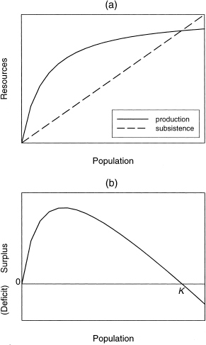

图 1.1 人口增长对 (a) 总生产、生存需求和 (b) 剩余生产的影响。*K*为承载能力。

Figure 1.1 Effect of population growth on (a) total production, subsistence needs, and (b) the production of the surplus. *K* is the carrying capacity.

对于自由但没有土地的劳动力来说，前景同样黯淡，他们必须找到工作来养活自己和家人。劳动力供给过剩导致工资低迷和相当一部分人口长期失业或就业不足。另一方面，无论是农村还是城市的雇主，都从这种经济形势中获益匪浅。

Prospects are equally bleak for free but landless laborers who must secure employment to support themselves and their families. Oversupply of labor leads to depressed wages and chronic unemployment or underemployment for a substantial part of population. On the other hand, employers, both rural and urban, profit greatly from this economic situation.

These considerations suggest that during the late stages of population growth, when commoners are already suffering from economic difficulties, the elites are enjoying a golden age. Both the reproduction of the existing elites and the recruitment of new elites from commoners will be fastest when the amount of extractable surplus is greatest. The expansion of elite numbers should take place during the “stagflation” phase (see below for the definitions of the phases of a secular cycle), when fast-rising prices and land rents offer the greatest opportunities for rapid accumulation of wealth by current and aspiring elites, and when state fiscal problems lead rulers to increase the sale of privilege and rank; both factors tend to accelerate social mobility into the elite ranks. As a result, the peak of elite numbers often lags behind that of the general population (the important exception of societies with widespread polygyny is discussed in section 1.3).

这种（对精英来说）幸福的状态不可能持续太久。首先，精英数量的扩大意味着精英人均资源数量开始下降。即使盈余总量保持不变，这个过程也会发生。但是，其次，随着总人口越来越接近承载能力，剩余生产逐渐减少。这两种趋势的结合导致精英平均收入加速下降。

Such a happy state of events (for the elites) cannot continue for long. First, expansion of elite numbers means that the amount of resources per elite capita begins to decline. This process would occur even if the total amount of surplus stayed constant. But, second, as general population grows closer to the carrying capacity, surplus production gradually declines. The combination of these two trends results in an accelerating fall of average elite incomes.

上述动态过程也具有社会心理学方面。在繁荣时期，精英们习惯并学会期待高水平的消费（这就是多布和斯威齐的“贵族家庭的日益奢侈”）。正如斯威齐所指出的，另一个因素是，由于城市化、手工艺的增长和贸易的扩大（这些因素本身就是人口增长的结果），精英阶层可以获得的商品数量和种类不断增加。 ）。对消费水平预期的现代研究表明，人们通常旨在匹配（如果可能的话超过）其父母的消费水平（Easterlin 1980，1996）。因此，重要的不是消费的绝对水平，而是相对于上一代人的消费水平。换句话说，*惯性*变量（惯性是因为它在代际时间尺度上变化缓慢）。如果我们可以将现代消费者的研究结果推断为前工业化的精英（至少，这可能是一个合理的工作假设），那么我们可以预测，在繁荣时期，精英们很容易习惯于消费水平的提高，而这种扩张不会引起什么社会评论。相比之下，他们的消费水平是否会比以前下降？一代人中，精英们预计会对这一发展做出强烈反应。这一论点表明，当代社会评论家对精英阶层奢侈浪费的生活方式的严厉批评与精英阶层本身对贫困和债务的同样严厉的抱怨之间并不矛盾。

The dynamic processes described above also have a sociopsychological aspect. During the good times the elites become accustomed to, and learn to expect, a high level of consumption (this is the “growing extravagance of noble households” of Dobb and Sweezy). An additional element, as pointed out by Sweezy, is the ever-increasing quantity and variety of goods available to the elites as a result of urbanization, the growth of crafts, and the expansion of trade (factors that are themselves a consequence of population growth). Modern studies of consumption level expectations suggest that people generally aim at matching (and if possible exceeding) the consumption levels of their parents (Easterlin 1980, 1996). Thus, what is important is not the absolute level of consumption but the level in relation to the previous generation. In other words, expected “living standard” is a culturally determined *inertial* variable (inertial because it changes slowly, on a generational time scale). If we can extrapolate results obtained by studying modern consumers to preindustrial elites (at least, this may be a reasonable working hypothesis), then we would predict that during the good times the elites would easily become accustomed to elevated levels of consumption, and this expansion would occasion little social comment. By contrast, should their level of consumption decrease in relation to the previous generation's, the elites would be expected to react vehemently to this development. This argument suggests there is no contradiction between the bitter critique of the elites for their luxurious and wasteful way of life by contemporary social commentators and the equally bitter complaining of the elites themselves about their poverty and indebtedness.

The deteriorating economic conditions of the elites during the late stagflation phase of the secular cycle do not affect all aristocrats equally. While the majority are losing ground, a few lineages, by contrast, are able to increase their wealth. The growing economic inequality results from the operation of what some sociologists call the “Matthew effect” (Merton 1968). Poor aristocratic lineages tend to get poorer because they attempt to maintain their elite status on an inadequate economic basis. This forces them into growing indebtedness, which eventually has to be addressed by selling some of their assets (such as land). A wealthier lineage, by contrast, can maintain the level of consumption necessary for preserving its elite status and have some resources left over to acquire land from its impoverished neighbors. As a result, the poor get poorer while the rich get richer. The same dynamic operates on peasants during the stagflation phase. During periods of economic hardship, poor peasants must sell land or starve. As a result, at the same time that the majority are sliding into absolute misery, a small percentage of thrifty, hardworking, or simply lucky peasants are able to concentrate increasing amounts of land in their hands. At some point, such successful peasants usually attempt to translate their wealth into higher social status. This demand for upward social mobility is an important factor contributing to the elite overproduction that develops towards the end of a prolonged period of demographic expansion.

因此，在滞胀阶段，各个社会阶层——农民、中小贵族和权贵——内部的经济不平等加剧。日益严重的不平等给社会流动性带来了向上和向下的压力。社会流动性的增加会产生摩擦并破坏社会稳定。贫富之间日益扩大的差距也为拥护社会正义和经济再分配的激进意识形态的群众运动创造了温床。

During the stagflation phase, thus, economic inequality increases within each social stratum—peasants, minor and middle-rank nobility, and the magnates. Growing inequality creates pressure for social mobility, both upward and downward. Increased social mobility generates friction and destabilizes society. The growing gap between the poor and rich also creates a breeding ground for mass movements espousing radical ideologies of social justice and economic redistribution.

## **剩余提取的动态**

## **Dynamics of Surplus Extraction**

大多数贵族收入的下降带来两个重要后果：精英阶层对农民的压迫加剧，以及精英阶层内部对稀缺资源的竞争加剧。精英们将试图通过一切可用的手段，包括经济手段和超经济手段（强制手段），增加从生产者那里获取资源的比例。他们的成功将取决于社会的结构特征：精英相对于生产者和国家的相对军事实力、对剩余榨取的法律和文化限制、等等。如果成功，精英不仅可能剥夺平民的剩余，还可能削减生存资源，导致平民人口负增长率。“因此，领主的剩余榨取（租金）往往不仅会没收农民高于温饱（甚至可能超出）的收入，同时也会威胁到更新农民财产和防止其土地长期衰落所必需的资金。生产力”（Brenner 1985a：31）。看来，世俗周期的这一阶段可能就是动力学家所称的“分叉点”，在这个点上，系统可能遵循几种替代轨迹之一。这种不同轨迹的一个典型例子是中世纪后英国和法国农奴制的消失，并且在同一时期，普鲁士和波兰新农奴制的兴起。系统遵循哪一种替代轨迹可能取决于其结构特征，也可能是偶然事件的结果。我们本质上是用动力系统术语重新表述布伦纳在批评马尔萨斯理论时提出的观点。

The declining incomes of the majority of aristocrats have two important consequences: intensifying oppression of the peasants by the elites and increasing intraelite competition for scarce resources. The elites will attempt to increase the proportion of resource extracted from the producers by whatever means that are available to them, both economic and extraeconomic (coercive). Their success will depend on the structural characteristics of the society: the relative military strength of the elites with respect to the producers and the state, legal and cultural limits on surplus extraction, and so forth. If successful, elites may not only deprive the commoners of the surplus but may also cut into the subsistence resource, resulting in a negative growth rate for the commoner population. “Thus the lord's surplus extraction (rent) tended to confiscate not merely the peasant's income above subsistence (and potentially even beyond) but at the same time to threaten the funds necessary to refurbish the peasant's holding and to prevent the long-term decline of its productivity” (Brenner 1985a:31). It appears that this stage in the secular cycle may be what is known among dynamicists as a “bifurcation point,” a point at which the system may follow one of several alternative trajectories. A classic example of such divergent trajectories is the disappearance of serfdom in post-medieval England and France and, during the same period, the rise of new serfdom in Prussia and Poland. Which of the alternative trajectories the system follows may depend on its structural characteristics or may be a result of a chance event. We are essentially rephrasing, in dynamical systems terms, the point made by Brenner in his critique of the Malthusian theory.

Stuart Borsch (2005) 最近的研究对本论文进行了阐述，该研究比较了黑死病对英格兰和埃及的影响。黑死病后的英国工资上涨，租金和粮食价格下降，失业率下降，人均收入增长。尽管英国的经济复苏比马尔萨斯模型所预测的要晚，但到了1500年，它已全面展开。埃及人口减少的后果截然不同。工资下降，地租和粮价上涨，失业率上升。到 1500 年，经济还看不到复苏的迹象。事实上，农业产量在 1350 年至 1500 年间下降了 68%。博尔什令人信服地认为，黑死病后埃及的持续停滞是由结构性因素解释的。1250年后，埃及由一群特别有凝聚力和军事能力的精英统治：被称为马穆鲁克的专门奴隶战士（例如，他们在十三世纪下半叶成功击退了蒙古人的入侵就证明了这一点）。英国农民可以通过躲藏在山丘和森林中来抵抗精英，而在人口稀少的英格兰，山丘和森林资源丰富。此外，长弓抵消了精英通常享有的军事力量优势。相比之下，埃及在不适宜居住的沙漠之间有狭长的耕地，没有任何规避策略的余地。黑死病之后，马穆鲁克能够利用其巨大的强制力，维持瘟疫前从大大减少的农村人口中获取资源的水平。对个体农民的极度剥削阻碍了人口的复兴。因此，系统陷入了“恶性平衡”，对于内部扰动来说，这种平衡显然是稳定的。它最终被外部征服所摧毁（1517年被奥斯曼帝国征服）。

This thesis is illustrated by the recent study of Stuart Borsch (2005), which compared the effects of the Black Death in England and Egypt. In post–Black Death England wages rose, rents and grain prices dropped, unemployment decreased, and per capita incomes grew. Although the economic recovery of England occurred later than would be predicted by the Malthusian model, by the year 1500 it was in full swing. The consequences of depopulation in Egypt were profoundly different. Wages dropped, land rents and grain prices rose, and unemployment levels increased. No economic recovery was anywhere in sight by 1500. In fact, agricultural output declined between 1350 and 1500 by 68 percent. Borsch argues convincingly that the persistent stagnation of post–Black Death Egypt is explained by structural factors. After 1250 Egypt was ruled by a particularly cohesive and militarily capable group of elites: specialized slave-warriors known as Mamluks (as evidenced, for example, by their success at repelling the Mongol invasions in the second half of the thirteenth century). English peasants could resist elites by hiding in the hills and forests, of which there was an abundance in a depopulated England. Additionally, the longbow negated the advantage in military power usually enjoyed by the elites. By contrast, Egypt's narrow strip of arable land between uninhabitable desert left no room for evasive tactics. After the Black Death, Mamluks were able to use their tremendous coercive power to maintain the preplague level of resource extraction from a greatly diminished rural population. Extremely high levels of exploitation of individual peasants precluded any demographic revival. The system, thus, was caught in a “vicious equilibrium” that was apparently stable with respect to internal perturbations; it was finally destroyed by external conquest (the Ottomans in 1517).

精英收入下降的第二个后果是精英内部竞争加剧。这种竞争采取的形式将（再次）取决于社会的结构特征。也许最重要的因素是国家镇压公开暴力的能力。在这里，我们考虑在维持内部秩序的情况下，在国家存在的情况下精英内部竞争的形式。国家崩溃或严重削弱后的情况是稍后考虑的。

The second consequence of plunging elite incomes is increased intraelite competition. The forms that this competition takes will depend (again) on the structural characteristics of the society. Probably the most important factor is the capability of the state to suppress overt violence. Here we consider the forms of intraelite competition in the presence of the state when internal order is maintained. The situation after the state collapses or is seriously weakened is considered later.

面临农业收入下降的精英阶层的一种求助方式是在国家或教会官僚机构中寻求就业机会。因为培训提高了一个人的机会，所以这些职位竞争加剧的一个奇怪的副作用是“资格危机”（Collins 1979）——教育机构招生人数的迅速扩大（至少在那些为有志成为精英的人提供正规培训的社会中）职位）。因此，我们可以使用高等教育的趋势作为精英内部竞争的指标（Goldstone 1991：123）。精英内部冲突的另一个有用指标是民事诉讼的水平（Goldstone 1991：120）。

One recourse for elites facing declining incomes from agriculture was to seek employment with the state or church bureaucracy. Because training improved one's chances, a curious side effect of increased competition for such positions was the “credentialing crisis” (Collins 1979)—a rapid expansion of enrollments at the educational institutions (at least in those societies that offered formal training to aspirants for elite positions). Thus, we can use trends in higher education as an index of intraelite competition (Goldstone 1991:123). Another useful index of intraelite conflict is the level of civil litigation (Goldstone 1991:120).

Impoverished elites could also improve their incomes by attaching themselves to the retinues of powerful magnates. In fifteenth-century England this trend resulted in what is known as “bastard feudalism” (Dyer 1989:35). A large retinue was necessary to advance the lord's interests in government, litigation, and even civil war. However, limits on available land, civil and ecclesiastical offices, and royal patronage lead to increasingly polarized factional battles between patron-client groups for available spoils (Goldstone 1991:119). As a result, the elites tend to lose their unity and split along numerous fission lines: new elites versus old, one religious faction against the other, regional elites against the center, and so on. Because there are not enough resources for everybody, certain segments of elites, or groups aspiring to elite status, inevitably end up as the losers. We refer to them as the counterelites, or dissident elites. Usually, the counterelites do not constitute a true sociological group, because there is little that unifies them apart from hatred for the existing regime and a burning desire to bring it down. Incidentally, we are not implying here that the motivations of the counterelites are purely economical. The late stagflation phase, as we argued above, is typically characterized by a harsh oppression of the productive segments of the society and extreme social inequality, offering ample ideological justification for revolutionary action.

## **状态崩溃**

## **State Breakdown**

人口增长导致的社会趋势——剩余生产减少、民众贫困和精英内部竞争——对国家维持内部秩序甚至生存的能力产生深远影响（Goldstone 1991）。人口增长导致军队扩张和官僚主义，导致国家支出增加。越来越多的追求精英职位的人给国家带来了进一步的财政压力。因此，尽管精英和普通民众反对，国家别无选择，只能寻求扩大税收。然而，剩余生产量下降了（如上一节所述），国家必须与日益绝望的精英争夺日益减少的剩余。结果，增加收入的努力无法抵消不断上升的国家开支，尽管国家正在迅速提高税收，但它仍然面临着财政危机。请注意，*实际*收入的下降可能会被持续的价格通胀所掩盖，因此以实际价格表示所有财政流量非常重要。

Social trends resulting from demographic growth—declining surplus production, popular immiseration, and intraelite competition—have a profound impact on the ability of the state to maintain internal order, or even to survive (Goldstone 1991). Population growth leads to expansion of armies and bureaucracies, resulting in rising state expenditures. An increased number of aspirants for elite positions puts further fiscal strain on the state. Thus, states have no choice but to seek to expand taxation, despite resistance from the elites and the general populace. Yet the amount of surplus production declines (as discussed in the previous section), and the state must compete for this shrinking surplus with increasingly desperate elites. As a result, attempts to increase revenues cannot offset the spiraling state expenses, and even though the state is rapidly raising taxes, it is still headed for fiscal crisis. Note that declining *real* revenues may be masked by persistent price inflation, and it is therefore important to express all fiscal flows in real terms.

正如我们在上一节中讨论的那样，人口增长导致农村苦难、城市移民、实际工资下降以及粮食骚乱和工资抗议的频率增加。经过一定的滞后时间，人口扩张的负面影响开始影响到精英阶层，他们因日益加剧的竞争和派系斗争而分裂。人口快速增长的另一个后果是青年群体的扩大。这部分人口尤其受到缺乏就业机会的影响。最后，日益加剧的经济不平等、精英竞争和民众不满加剧了意识形态冲突。例如，在近代早期的欧洲，持不同政见的精英和心怀不满的工匠被广泛招募到异端宗教运动中。

As we discussed in the previous section, population growth leads to rural misery, urban migration, falling real wages, and an increased frequency of food riots and wage protests. After a certain lag time, the negative effects of population expansion begin to affect the elites, who become riven by increasing rivalry and factionalism. Another consequence of rapid population growth is the expansion of youth cohorts. This segment of the population is particularly impacted by lack of employment opportunities. Finally, growing economic inequality, elite competition, and popular discontent fuel ideological conflicts. For example, in early modern Europe, dissident elites and dissatisfied artisans were widely recruited into heterodox religious movements.

随着所有这些趋势的加剧，最终的结果是国家破产和随之而来的军事控制的丧失、地区和国家叛乱的精英运动，以及中央权威崩溃后精英动员和民众起义的结合（Goldstone 1991：25） 。政治派别之间的内战只是人际暴力增加的一方面。社会秩序的崩溃也伴随着土匪、凶杀和其他暴力犯罪的增加。在意识形态层面，社会悲观情绪普遍存在，国家权威的合法性处于最低点。这个社会正接近一种可以恰当地称为“霍布斯式”的状态（霍布斯本人就生活在这样一个时期）。我们将这些情况统称为社会政治高度不稳定。

As all these trends intensify, the end result is state bankruptcy and consequent loss of the military control, elite movements of regional and national rebellion, and a combination of elite-mobilized and popular uprisings following the breakdown of central authority (Goldstone 1991:25). Internal war among political factions is only one aspect of increased interpersonal violence. A breakdown of social order is also accompanied by increased banditry, homicides, and other kinds of violent crimes. On the ideological level, the feeling of social pessimism is pervasive and the legitimacy of the state authority is at its lowest point. The society approaches a condition that may appropriately be called “Hobbesian” (Hobbes himself lived during such a period). We refer to these conditions collectively as high sociopolitical instability.

## **社会政治不稳定对人口动态的影响**

## **The Effect of Sociopolitical Instability on Population Dynamics**

在前面的章节中，我们重点讨论了人口增长对社会各种结构的多重影响，包括一系列我们称之为社会政治不稳定的变量。这里我们考虑反馈效应：不稳定如何影响人口动态？我们可以设想两种一般的（实际上是相互关联的）方式：影响人口比率和影响社会的生产能力（Turchin 2003b：120-21）。

In the previous sections we focused on the manifold effects of population growth on various structures of the society, including a bundle of variables that we call sociopolitical instability. Here we consider the feedback effect: how does instability affect population dynamics? We can envision two general (and, actually, interrelated) ways: by affecting demographic rates and by affecting the productive ability of the society (Turchin 2003b:120–21).

最明显的是，当国家软弱或缺位时，民众将因犯罪、土匪行为和内战（内战）增加而遭受更高的死亡率。外部战争也可能发挥作用。尽管国家之间的外部战争一直是农业国家的一个持续特征，但它对人口的影响应该随着世俗周期的阶段而变化。国家强大时，战争是向外的，最受损害的地区是国家边境，以及外部地区，这些地区都是被征服的目标。国家的崩溃和随之而来的内战降低了社会对外来入侵的抵抗力。结果，从小股袭击者到敌对大国的内部战争和外部入侵可能变得难以区分（例如，法国百年战争期间发生的事情）。战争对死亡率也有间接影响，因为叛军或入侵军队的行动会传播流行病。

Most obviously, when the state is weak or absent, the populace will suffer from elevated mortality due to increased crime, banditry, and internal warfare (civil war). External war may also play a role. Although external warfare between states has been a constant feature of agrarian states, its effect on demography should change with the phase of the secular cycle. When the state is strong, warfare is directed outward, and the areas that suffer most are the state frontiers, as well as areas outside, which are targeted for conquest. Collapse of the state and the ensuing civil wars reduce the resistance of the society to external invasion. As a result, internal warfare and external invasions by groups ranging from small bands of raiders to rival great powers can become hard to separate (this is, for example, what happened during the Hundred Years’ War in France). Warfare has also an indirect effect on mortality, because movements of rebel or invading armies spread epidemics.

The times of trouble also cause increased migration: refugees flee from war-afflicted areas or areas whose productive potential has been destroyed. Migration has several effects. First, it can lead to emigration (and we can simply add that to mortality). Second, people on the move cannot afford to have children. Thus, birth rates decline. Third, migration leads to epidemics. Increased vagrancy spreads the disease by connecting areas that would stay isolated during better times. For example, in Ireland during 1810–44 (the period just before the Great Famine), harvests failed or partially failed in fifteen years out of thirty-five. These failures did not lead to starvation, but they were followed by outbreaks of “famine fevers”—typhus, dysentery, scurvy, cholera—which were spread throughout the isle by beggars and vagrants seeking charity and employment (Grigg 1980:138).

促进疾病传播的其他因素是军队的流动和国际贸易的扩大。后一个因素应该通过指出国际贸易在危机前时期（滞胀阶段）扩张，然后在社会陷入无政府状态后逐渐下降来加以限定。因此，大范围流行病（大流行病）最有可能在滞胀后期出现。事实上，流行病的到来是人口结构崩溃最常见的触发因素之一。

Additional factors facilitating the spread of disease are the movements of armies and the expansion of international trade. The latter factor should be qualified by noting that international trade expands in the precrisis period (stagflation phase) and then gradually declines after the society has descended into anarchy. Thus, the rise of widespread epidemics—pandemics—is most probable during the late stagflation phase. In fact, the arrival of a pandemic is one of the most frequent triggers of the demographicstructural collapse.

在更局部的范围内，流浪汉和乞丐聚集在城镇，人口规模不断增加。这可能会使当地人口密度超过流行病学阈值（临界密度，高于该密度，疾病就会传播，低于该密度，疾病就会消失）。

On a more local scale, vagabonds and beggars aggregate in towns and cities, increasing their population size. This may tip the local population density over the epidemiological threshold (a critical density above which a disease spreads and below which it dies out).

最后，政治不稳定导致生育率下降，因为生产能力下降导致个人消费大幅下降。由于缺乏有组织的方式来储存剩余物质，农民无法度过短期的生存危机。各个家庭积累的商店很容易成为掠夺军队和其他掠夺者的猎物。此外，在不确定时期，人们选择晚婚和少生孩子。顺便说一句，人们对家庭规模的选择可能不仅反映在出生率上，还反映在杀婴率上。因此，家庭限制做法可能被伪装成婴儿死亡率增加。

Finally, political instability causes lower reproduction rates, because personal consumption plummets as a result of lowered production capacity. In the absence of organized ways to store surplus, peasants are unable to weather short-term subsistence crises. What stores are accumulated by individual households are easy prey to the marauding armies and other predators. In addition, during times of uncertainty people choose to marry later and to have fewer children. Incidentally, people's choices about their family sizes may be reflected not only in birth rates but also in the rates of infanticide. Thus, family limitation practices may be disguised as increased infant mortality.

社会政治不稳定的第二个也许更重要的影响是对社会生产能力（承载能力）的影响。富有活力的国家经常通过修建灌溉渠和道路、实施防洪措施、清理森林、组织人口稀少地区的殖民等方式投资于提高农业生产力。这些措施的最终结果主要是耕地面积的增加，尽管有些措施也提高了土地的生产力。

The second and perhaps even more important effect of sociopolitical instability is on the productive capacity of the society (the carrying capacity). Vigorous states often invest in increasing the agricultural productivity by constructing irrigation canals and roads, implementing flood control measures, clearing land from forests, organizing the colonization of underpopulated regions, and so on. The end result of these measures is mainly an increase in cultivated area, although some measures also increase the productivity of land.

The other general mechanism is that the state offers protection. In a stateless society, people can live only in natural strongholds or in places that can be made defensible, such as walled cities. For example, at the height of the Roman Empire the overwhelming majority of the Italian population was to be found in the lowlands, where the most productive land was concentrated. After the collapse of Rome, settlements were moved to hilltops (Wickham 1981). An even more striking illustration comes from the Wanka hill fort chiefdoms in the Mantaro Valley of Peru (Earle 1997). Prior to Inka pacification of the region, the Wanka lived in crowded hilltop fortresses. After the conquest, the population moved down to lower elevations, where the best agricultural land was located. As a result, the diet and life span of both elite and commoner were dramatically improved (Johnson and Earle 2000:327).

第三个例子来自诺曼主教托马斯·巴辛 (Thomas Basin) 所著的*《查理七世史》*，他描述了 1420 年代法国西北部在百年战争爆发后的情况：

The third example comes from *Histoire de Charles VII* by the Norman bishop Thomas Basin, who described northwestern France during the 1420s, after a particularly virulent outbreak of the Hundred Years’ War:

一种毁灭性的状态，从卢瓦尔河到塞纳河，从那里到索姆河，农民都被杀害或逃走，几乎所有的田地都多年无人耕种，而且无人居住……。当时，该地区所有可耕种的作物都仅限于城镇或城堡的周围和内部，距离足够近，以便从塔楼或瞭望塔的顶部，瞭望员的眼睛可以看到进攻的强盗。然后，他用钟声、号角或其他乐器的声音，向所有在田野或葡萄园工作的人发出信号，要求他们撤到防御工事的地方。（引自 Dupâquier 等人，1988a:368）

换句话说，国家缺乏对内部暴力的有效镇压，造成了一种“恐惧景观”，其中很大一部分适合农业的土地因为距离发生地太远而被放弃。安全。相比之下，强大的国家保护生产人口免受外部和内部（土匪、内战）的威胁，从而允许整个耕地投入生产。

In other words, lack of effective suppression of internal violence by the state imposes a “landscape of fear,” in which a large proportion of agriculturally suitable lands is abandoned because they are too far from a place of security. By contrast, the strong state protects the productive population from external and internal (banditry, civil war) threats, and thus allows the whole cultivable area to be put into production.

## **抑郁阶段的精英动态**

## **Elite Dynamics during the Depression Phase**

社会政治不稳定对精英群体的影响与对平民的影响类似，尽管具体机制的相对重要性可能截然不同。因此，精英阶层可能很少受到生存危机的影响。他们也更容易逃避流行病的影响。这部分是由于他们有更好的营养以及在疾病期间获得更好护理的可能性，但更重要的是他们更高的流动性。城市精英可以在流行病初现的第一个迹象时撤退到他们的乡村庄园（就像薄卡丘的《*十日谈》*中那样）。在多个省份拥有庄园的高级贵族同样可以避免流行病袭击特定地区。

Sociopolitical instability affects elite numbers in a fashion that is similar to its effect on commoners, although the relative importance of specific mechanisms can be quite different. Thus, the elites may be little affected by subsistence crises. They also tend to escape more lightly the effect of epidemics. This is partly due to their better nutrition and the likelihood of getting better care during disease, but even more important is their higher mobility. Urban elites could withdraw to their country estates at the first sign of incipient epidemic (as in Bocaccio's *Decameron*). Higher nobility with estates in multiple provinces could similarly avoid an epidemic striking a particular region.

另一方面，由于他们更积极地参与政治，精英们遭受暴力死亡的风险要高得多。一些冲突中的死亡人数非同寻常。例如，Dupâquier 等人。(1988a:342)引用Philippe Contamine的估计，大约40%的法国精英可能在普瓦捷战役(1356年)中被屠杀，在阿金库尔战役(1415年)中也有同样的比例。在十六世纪末的宗教战争期间，仅一天之内就有 20,000 名胡格诺教徒被杀，即圣巴塞洛缪日大屠杀（Kamen 1971：39）。

On the other hand, by virtue of their more active participation in politics, the elites ran a much higher risk of violent death. The death toll in some conflicts was extraordinary. For example, Dupâquier et al. (1988a:342) quote an estimate by Philippe Contamine that around 40 percent of the French elite may have been slaughtered in the Battle of Poitiers (1356), and the same proportion at Agincourt (1415). During the Wars of Religion in the late sixteenth century, 20,000 Huguenots were killed in just one day, the St. Bartholomew's Day massacre (Kamen 1971:39).

国家清洗也可能导致生命或精英地位的丧失。例如，明朝第一位皇帝清洗了 10 万中国官员（Tignor et al. 2002:62）。苏拉的放逐消灭了三分之一的罗马统治阶级和元老，凯撒死后又通过放逐消灭了另外三分之一的人（见第六章）。

Loss of life or elite status could also result from state purges. For example, the first Ming emperor purged 100,000 Chinese officials (Tignor et al. 2002:62). Sulla's proscriptions eliminated a third of the Roman ruling class, senators, and another third was eliminated by proscriptions following Caesar's death (see chapter 6).

A much less spectacular but perhaps ultimately more important process reducing the elite numbers is downward mobility. The plunge in elite incomes, which begins in the precrisis period and is greatly exacerbated by the general population decline, affects most strongly the status of the lowest noble stratum. A specific example is given by Christopher Dyer for late medieval England. An esquire or gentlemen living on £10–20 a year who was employing only three servants and lived in one house, and whose meals were devoid of much luxury in terms of wine and spices, had little room to maneuver when his income plunged by up to 50 percent in the midfifteenth century: “They must have cut back, or even cut out completely, their occasional wine-bibbings, and avoided travel whenever possible, but too many economies of this kind might force them to drop out of the aristocracy and accept yeoman status” (Dyer 1989:108).

总之，存在许多可以减少精英剩余的社会机制：（1）内战造成的死亡，（2）新统治者对精英的故意清洗，（3）对继承人生产的限制（独身，长子继承权） ，（4）社会流动性下降，无论是自愿的还是国家强迫的，（5）由于征服或农业生产力的提高而增加的物质资源，以及（6）新的政治秩序的发展，将更多的资源分配给人民。精英。几种这样的机制通常结合起来运作；具体组合取决于社会的文化特性和历史事件。

In summary, a number of social mechanisms exist by which elite surpluses can be reduced: (1) deaths resulting from civil war, (2) deliberate purges of elites by new rulers, (3) limitations imposed on heir production (celibacy, primogeniture), (4) downward social mobility, voluntary or forced by the state, (5) increased material resources resulting from conquest or improvements in agricultural productivity, and (6) the development of a new political order that directs a greater share of resources to the elites. Several such mechanisms are usually operating in combination; the specific mix depends on cultural peculiarities of societies and historical accidents.

## **不稳定的结束和新周期的开始**

## **End of Instability and the Beginning of the New Cycle**

由于推动社会政治不稳定的三个主要因素是普遍人口过剩、精英生产过剩和国家破产，因此在瓦解阶段结束之前，所有这些趋势都必须得到扭转。这种趋势逆转可以通过多种方式发生，具体取决于社会特征、地缘政治环境和各种其他外生因素。因此，世俗周期的最后阶段尤其充满了分歧点，社会政治轨迹可能以一种非常不确定的方式表现。

Because the three main factors driving the rise of sociopolitical instability are general overpopulation, elite overproduction, and state insolvency, all these trends must be reversed before the disintegrative phase can end. Such trend reversal can occur in a variety of ways, depending on the characteristics of the society, its geopolitical environment, and various other exogenous factors. As a result, the last stages of the secular cycle are particularly rife with bifurcation points, and the sociopolitical trajectory can behave in a very nondeterministic fashion.

人口过剩问题通常在危机阶段就得到“处理”。人口崩溃最常见的直接机制之一是疾病，但并非所有人口下降都是由灾难性流行病造成的。长时间的内战也会导致人口水平急剧下降，尽管通常需要更多时间。最后，对一个不团结的社会的外部征服往往会导致人口灾难。

The problem of overpopulation is usually “dealt with” during the crisis phase. One of the most common proximate mechanisms of population collapse is disease, but not all population declines are accomplished by catastrophic epidemics. Prolonged periods of civil war can also cause drastic drops in population levels, although typically requiring more time. Finally, the external conquest of a disunited society often results in a demographic catastrophe.

人口崩溃的另一种选择是增加承载能力——毕竟，人口过剩不是因为绝对数量太大，而是因为与承载能力相比人口密度过高。由于技术进步，承载能力可以增加。这可能就是近代早期英国发生的事情。在十七世纪的危机期间，英国人口几乎没有减少，而每英亩的平均谷物产量可能翻了一番。最终结果是人口对资源的压力成倍下降。

An alternative to population collapse is an increase in the carrying capacity—after all, overpopulation results not from the absolute numbers being too large but from too high a population density in relation to the carrying capacity. The carrying capacity can increase as a result of technological progress. This is probably what happened in early modern England. During the crisis of the seventeenth century, the English population hardly declined, while the average yield of grain per acre probably doubled. The end result was a twofold decline in the population pressure on resources.

由于征服了新的人口稀少的领土，承载能力也可能会增加。一个例子是十六世纪莫斯科公国征服喀山汗国和阿斯特拉罕汗国，在随后的几个世纪中为俄罗斯殖民开辟了伏尔加河沿岸的大片地区。理论上，由于气候的大幅改善，承载能力也会增加，尽管目前来看我们无法举出一个有据可查、令人信服的例子来说明这一机制正在发挥作用。

The carrying capacity may also increase as a result of the conquest of new underpopulated territories. An example is the conquest of the Kazan and Astrakhan khanates by Muscovy in the sixteenth century, which opened up vast areas along the Volga for Russian colonization during the succeeding centuries. Theoretically, the carrying capacity can also increase as a result of a substantial amelioration of the climate, although at this point we cannot point to a well-documented, convincing example of this mechanism in action.

The processes leading to the reduction in the elite numbers and appetites were discussed in the previous section. The manner in which elite overproduction is abated depends very much on the military strength of the aristocracy. A nonmilitarized ruling class can be expropriated en masse by warlords, such as rebel generals or even peasant bandits. A rapid and comprehensive elite turnover results in a relatively short period of sociopolitical instability that follows state collapse. This is apparently what happened on several occasions during the Chinese imperial period, where the ruling class was dominated by the literate administrative elites rather than by military specialists. A rapid elite turnover can also result when there is a ready external source of potential elites, as was the case in the Maghreb described by Ibn Khaldun (we discuss Ibn Khaldun cycles in the next section).

一个相对于内部和外部对手都拥有军事力量优势的统治阶级只能通过各个精英派别之间的自相残杀来削弱。这可能会导致很长时间的社会政治不稳定，或者用我们的术语来说是“抑郁”阶段。

A ruling class that enjoys a preponderance of military power over both internal and external rivals can be reduced only by internecine fighting between various elite factions. This can result in very prolonged periods of sociopolitical instability, or “depression” phases, in our terminology.

因此，为了让新的世俗周期开始，普通民众对资源的压力以及精英对平民的压力必须比危机前的水平大幅减少。还有第三个条件。并非所有社会都有能力进行构建一个正常运转的国家所需的大规模合作，一些曾经有过帝国历史的社会也可能随着时间的推移而失去这种能力（Turchin 2003b，2006）。因此，内战完全有可能逐渐平息，但中央集权、一体化的趋势却未能形成。在这种情况下，相关地区可能会无限期地（或直到被外部征服）作为小规模政体的集合而处于支离破碎的状态。对于未能建立一个正常运作的国家的潜在解释超出了我们本书的范围。这里我们只是指出这是另一个可能的分叉点。

Thus, for a new secular cycle to get going, the pressures of the general population on resources and of the elites on commoners must be substantially reduced from their precrisis levels. There is also a third condition. Not all societies are capable of the broad-scale cooperation that is required to construct a functioning state, and some societies with a previous imperial history can also lose this ability with time (Turchin 2003b, 2006). Thus, it is entirely possible for the civil warfare to gradually die out but a centralizing, integrative trend nevertheless failing to take hold. In this case, the area in question may persist indefinitely (or until it is conquered from the outside) in a fragmented state as a collection of small-scale polities. The potential explanations of this failure to build a functioning state lie beyond the scope of our book. Here we simply indicate that it is yet another possible bifurcation point.

## **世俗周期的各个阶段**

## **Phases of the Secular Cycle**

振荡动力学不会经历具有明确标记断点的真正离散阶段，但为了方便讨论每个长期周期，我们需要将其划分为多个阶段。我们在这里给出的分类方案是基于这样的理解，即阶段之间的过渡很少是突然的，因此我们指定为一个阶段的结束和另一个阶段的开始的任何特定年份在某种程度上是任意的（因此，我们通常将日期到最近的十年）。

Oscillatory dynamics do not go through truly discrete phases with clearly marked breakpoints, but for convenience in talking about each secular cycle, we need to divide it in phases. Our classificatory scheme is given here with the understanding that transitions between phases are rarely abrupt, so that any particular year that we designate as an end to one phase and the beginning of another is to some degree arbitrary (for this reason, we usually round the date to the nearest decade).

最广泛地说，这个周期可以分为两个相反的趋势。在文献中，这些有时被称为积极的“A 阶段”和负面的“B 阶段”，但我们更喜欢更具描述性的术语“*整合”*和*“分解”*趋势。从政治上看，一体化阶段的特点是集权倾向、精英统一以及维护秩序和内部稳定的强大国家。内部凝聚力常常导致对外征服战争的大力进行，这可能会导致国家领土的扩张（假设存在较弱的邻国，而国家可以以这些邻国为代价来扩张）。相比之下，瓦解阶段的特点是权力下放的趋势、精英的分裂、国家的软弱以及内战中周期性爆发的内部不稳定和政治混乱。在瓦解阶段，外部征服战争更加难以进行。如果发生的话，通常发生在内战之间的间隙，并且以同样弱小的对手为代价。

Most broadly the cycle can be divided into two opposite trends. In the literature these are sometimes called the positive “A phase” and the negative “B phase,” but we prefer the more descriptive terms *integrative* and *disintegrative* trends. Politically the integrative phase is characterized by a centralizing tendency, unified elites, and a strong state that maintains order and internal stability. Internal cohesion often results in the vigorous prosecution of external wars of conquest, which may result in the extension of the state territory (assuming there are weaker neighbors at whose expense the state can expand). The disintegrative phase, by contrast, is characterized by a decentralizing tendency, divided elites, a weak state, and internal instability and political disorder that periodically flare up in civil war. External wars of conquest are much more difficult to prosecute during the disintegrative phase. If they happen, they usually take place during the intervals between civil wars and at the expense of equally weak opponents. More frequently it is the external enemies that profit from the internal weakness of the state and society, resulting in an increased frequency of raids, invasions, and loss of territory.

人口在一体化阶段趋于增加，而在瓦解阶段则趋于下降或停滞。气候波动、流行病或被外部敌人蹂躏可能会导致短期（如果很严重）的人口损失。然而，一旦这些外来力量停止作用，人口就会恢复强劲增长。相比之下，在解体阶段，由于流行病、饥荒或战争造成的人口损失并不能通过持续的人口增长来弥补。即使当最接近的马尔萨斯力量（流行病、饥荒和战争）被搁置时，人口也常常无法增加，尽管远低于承载能力。

The population tends to increase during the integrative phase and decline or stagnate during the disintegrative one. Climatic fluctuations, epidemics, or being overrun by an external enemy can cause short-term (if significant) population losses. However, vigorous population growth resumes as soon as such exogenous forces stop acting. During the disintegrative phase, by contrast, population losses due to epidemics, famines, or wars are not made up by sustained population growth. Even when the proximate Malthusian forces (epidemics, famines, and wars) are in abeyance, the population often fails to increase, despite being much below the carrying capacity.

将广泛的整合期和瓦解期进一步划分为子阶段是有用的。在一体化趋势的第一个*扩张*阶段，人口增长尤其强劲。这是一个物价相对稳定且实际工资略有下降（如果有的话）的时期。然而，随着人口密度开始接近承载能力的极限，物价上涨或工资下降加速——这就是“停滞”或“压缩”，甚至更确切地说是滞胀（停滞加通货膨胀）*阶段*。尽管大多数平民在滞胀阶段经历了越来越多的经济困难，但精英阶层却享受着黄金时代，他们的人数和胃口不断扩大。

It is useful to further divide the broad integrative and disintegrative periods into subphases. Population growth is particularly vigorous during the first, *expansion* phase of the integrative trend. This is a time of relatively stable prices and modest real wage declines (if any). However, as the population density begins to approach the limits set by the carrying capacity, price increases or wage declines accelerate—this is the “stagnation” or “compression” or even more descriptively *stagflation* (stagnation plus inflation) phase. Although the majority of commoners experience increasing economic difficulties during the stagflation phase, the elites enjoy a golden age, and their numbers and appetites continue to expand.

滞胀阶段（以及总体一体化趋势）之后是一场全面危机。尽管扩张会平稳地进入停滞，但滞胀和危机之间的转变往往（但并非总是）突然。标志着危机到来的离散事件可以是流行病、极端饥荒或国家崩溃后发生的激烈内战（或任何此类事件的各种组合）。*我们术语中的危机阶段不是一个离散的、短暂的事件（这是危机*一词的含义之一），而是一个可以持续一代人或多代人的较长时期。这危机期间人口数量下降导致人均资源充足的情况。然而，这并不一定会结束分裂的趋势，因为精英和精英追求者通常过多，精英内部冲突不断产生内部不稳定。因此，危机顺利升级为*萧条*阶段，其特点是地方性的内战。激烈的内战之间的间隔期间，人口可能会增长，但这种增长通常不会持续，随后会出现下降（尽管不像危机阶段的典型情况那样造成灾难性的后果）。当精英阶层因内部冲突而减少到瓦解趋势可以逆转时，萧条阶段结束，新的世俗周期开始。或者，如果没有任何功能状态可以继续，那么抑郁阶段就会平滑地过渡到不确定长度的*交错*周期。

The stagflation phase (and the overall integrative trend) is succeeded by a general crisis. Whereas expansion grades smoothly into stagnation, the transition between stagflation and crisis is often (but not always) abrupt. Discrete events signaling the arrival of crisis can be pandemics, extreme episodes of famine, or state collapse followed by intense civil war (or any such events in various combinations). The crisis phase in our terminology is not a discrete, brief event (which is one meaning of the word *crisis*) but an extended period that can last for one or more human generations. The decline of population numbers during a crisis results in a situation of plentiful per capita resources. However, this does not necessarily end the disintegrative trend, because there are usually too many elites and elite aspirants, and intraelite conflict continues to generate internal instability. Thus, the crisis grades smoothly into a *depression* phase, characterized by endemic civil warfare. The population may grow during the intervals between intense civil wars, but such increases typically do not last and are followed by declines (although not as a catastrophic as those typical of the crisis phase). The depression phase ends when the ranks of elites are pruned by internal conflict to the point where the disintegrative trend can reverse itself, and a new secular cycle begins. Alternatively, if no functioning state can get going, then the depression phase grades smoothly into an *intercycle* of indeterminate length.

我们想再次强调，我们提出的分类方案是一种理想类型。能够用一个词来指示动力系统的粗略状态是有帮助的。然而，实际社会所遵循的轨迹存在很大差异。因此，各个阶段之间的界限应该被视为“模糊”而不是“硬性”。该书手稿的一位早期读者甚至建议，我们可以允许阶段重叠，而不是将我们研究的社会的时间线划分得太整齐。这个建议有一定的道理，因为不同的阶段由不同类型的社会过程主导，而且这些过程在时间上常常重叠。例如，政治危机的爆发并不总是与人口增长转向人口下降同时发生，因此，滞胀-危机过渡的日期可能存在问题。最后，我们选择保留不重叠的阶段，因为否则会让我们的读者感到困惑。但我们不会以普罗克拉斯特斯的方式将这些离散阶段强加于每个案例研究。

We wish to emphasize again that the classificatory scheme we propose is an ideal type. It is helpful to be able to indicate the rough state of the dynamical system with a single word. However, there is considerable variation in the trajectories followed by actual societies. Thus, the boundary between various phases should be taken as “fuzzy” rather than “hard.” An early reader of the book manuscript even suggested that, instead of dividing the timelines of the societies that we study too neatly, we could allow phases to overlap. There is some merit to this suggestion, because different phases are dominated by different kinds of social processes, and these processes often overlap in time. For example, the onset of political crisis does not always coincide with the shift from population growth to population decline, and therefore the dating of the stagflation-crisis transition may be problematic. In the end, we chose to stay with nonoverlapping phases, because doing otherwise would be too confusing to our readers. But we do not impose these discrete phases on each case study in a procrustean manner.

## 1.3 变化和扩展

## 1.3 Variations and Extensions

## **影响长期周期特征长度的因素**

## **Factors Affecting Characteristic Lengths of Secular Cycles**

我们在1.2节中对世俗周期一般理论的阐述和说明是以西欧为中心的，但原则上该理论应该适用于任何农业社会。在本节中，我们讨论社会的某些结构和文化特征如何影响人口结构动态，重点关注振荡动态最重要的特征之一，即周期的平均周期。

Our exposition and illustration of the general theory of secular cycles in section 1.2 was Western European–centric, but the theory should, in principle, be applicable to any agrarian society. In this section we discuss how certain structural and cultural characteristics of societies should affect the demographic-structural dynamics, with a focus on one of the most important characteristics of oscillatory dynamics, the average period of a cycle.

长期周期在严格的数学意义上并不是周期性的，其中每个后续周期都精确地重复前一个周期。尽管长期的涨跌是由两者之间的相互作用内生产生的。由于农业国家的各个组成部分（子系统），农业国家的宏观社会动态不可能是严格周期性的。至少有三个原因。首先，非线性动态反馈在理论上不仅可以产生严格的周期性（数学意义上的循环）动态，而且可以产生非周期性的混沌——看起来不稳定的行为，但完全是由内部、内生的原因产生的。系统越复杂（拥有的组件越多），组件之间的相互作用越非线性（例如阈值响应的存在），其动力学特征具有敏感依赖性（混沌的标志）的可能性就越大。社会系统是复杂的，反馈循环是非线性的，因此不能忽视发生混乱的可能性（Turchin 2003b）。

Secular cycles are not periodic in the strictly mathematical sense, in which each succeeding cycle repeats exactly the preceding one. Although the secular rises and falls are generated endogenously by interactions between various components (subsystems) of the agrarian state, macrosocial dynamics of agrarian states cannot be strictly periodic. There are at least three reasons for that. First, nonlinear dynamic feedbacks can in theory generate not only strictly periodic (cyclic in the mathematical sense) dynamics but also aperiodic chaos—erratic-looking behavior that is nevertheless produced entirely by internal, endogenous reasons. The more complex the system (the more components it has) and the more nonlinear the interactions between the components (such as the presence of threshold responses), the greater is the likelihood that its dynamics will be characterized by sensitive dependence, the hallmark of chaos. Social systems are complex and feedback loops are nonlinear, so the possibility of chaos cannot be discounted (Turchin 2003b).

其次，农业国家的动态不仅受到其内部运作的影响，还受到地缘政治和生态环境变化等外生力量的影响。与内生因素不同，外生因素是那些不属于反馈循环的因素（Turchin 2003a）：它们影响社会动态，但本身不受社会动态影响。

Second, the dynamics of agrarian states are affected not only by their internal workings but also by exogenous forces, such as changes in their geopolitical and ecological environment. Exogenous factors, unlike endogenous ones, are those that are not part of feedback loops (Turchin 2003a): they affect societal dynamics but are not themselves influenced by societal dynamics.

最后，个人拥有自由意志，可以以不可预测的方式行事。原则上，即使是一个人的行为，如果在正确的时间发生在正确的地点，也可能影响整个社会的轨迹。由于缺乏更好的理论方法，我们可以将微观层面上的个体行为建模为随机过程，这是一种布朗运动，也会导致宏观社会轨迹发生不稳定、不可预测的变化。

Finally, individuals possess free will and can act in unpredictable ways. In principle, even the act of a single person, if it takes place in the right place at the right time, may be able to influence the trajectory of a whole society. For lack of better theoretical approaches, we can model actions of individuals at the microlevel as a stochastic process, a kind of Brownian motion that also results in erratic, unpredictable changes in the macrosocial trajectory.

由于所有这些原因，我们预计长期动态不会出现严格的周期性。相反，动态应该有一个平均周期，一个特征时间尺度，并且围绕这个平均值有很大程度的变化。单一繁荣和萧条长期周期的平均周期是由其阶段的特征长度决定的，而特征长度又取决于各种社会、经济和政治参数。因此，扩张阶段的典型长度主要由（1）人均人口增长率和（2）周期开始时的人口密度与承载能力决定。例如，如果人口以每年 1% 的速度增长，则需要 70 年才能翻一番。这是对典型扩张阶段的一个不错的估计。

For all these reasons, we do not expect a strict periodicity in secular dynamics. Instead, dynamics should have an average period, a characteristic time scale, with a substantial degree of variation around this average. The mean period of a single—boom and bust—secular cycle is determined by the characteristic lengths of its phases, which in turn depend on various social, economic, and political parameters. Thus, the typical length of the expansion phase is primarily determined by (1) the per capita rate of population increase and (2) the population density in relation to carrying capacity at the beginning of the cycle. For example, if population grows at the rate of 1 percent per year, it takes seventy years for it to double. This is not a bad estimate of a typical expansion phase.

扩张阶段也受到地缘政治环境的影响。在世俗一体化趋势的中期，国家最有能力动员社会进行对外征服战争。成功的领土征服会导致异常漫长的扩张阶段，特别是当它伴随着被征服领土的殖民化时，这有助于减少大都市的人口压力。

Expansion phases are also affected by geopolitical environment. States enjoy the greatest ability to mobilize the society for a war of external conquest during the middle parts of integrative secular trends. Abnormally long expansion phases result from successful territorial conquest, especially when it is accompanied by colonization of conquered territories, which serves to reduce population pressure in the metropole.

危机阶段的持续时间更难以预测，因为虽然人口增长速度存在明确的生物学限制，但人口下降速度却没有类似的限制。根据变化的推动因素，人口可能会迅速下降（如在流行病中），或者由于持续的内战而更缓慢地下降。此外，影响历史人群的病原体的致死率也各不相同。相对温和的病原体可能会导致种群数量缓慢下降（可能是由于流行病反复出现），从而导致长期下降阶段。另一方面，严重的流行病会导致极短时期内的人口急剧下降，并导致更深程度的社会解体和更长的萧条阶段（就像黑死病后的欧洲所发生的那样）。

The length of the crisis phase is much less predictable, because while there is a definite biological limit on how fast a human population can grow, there is no comparable limit on how fast it can decline. Depending on the agent of change, population can decline very rapidly, as in a pandemic, or more slowly, due to incessant civil warfare. Furthermore, pathogens afflicting historical populations varied in their lethality. A relatively mild pathogen could drive population down slowly (perhaps as a result of recurrent epidemics), resulting in a long decline phase. A severe epidemic, on the other hand, would lead to a very short period of drastic population decline, and also to a deeper degree of social disintegration and longer depression phase (as happened in post–Black Death Europe).

滞胀和萧条阶段的特征长度更多地取决于国家，特别是精英动态，而不是普通民众的行为。特别是，精英的军事实力对萧条阶段的长度有很大影响，或者即使有这样一个阶段。针对西欧社会特征（主要是一夫一妻制的精英享有相对于内部和外部敌人的军事力量优势）量身定制的模型表明，这些社会的典型世俗周期周期应该在两到三个世纪的范围内（Turchin 2003b） ：138）。

The characteristic lengths of the stagflation and depression phases depend more on the state and, particularly, on elite dynamics than on what the general population does. In particular, the military strength of the elites has a large effect on the length of the depression phase, or even if there is such a phase at all. Models tailored to the characteristics of Western European societies (largely monogamous elites enjoying a preponderance of military power over their internal and external enemies) suggest that the typical periods of secular cycles in these societies should lie in the range of two to three centuries (Turchin 2003b:138).

## **Ibn Khaldun Cycles**

在某些伊斯兰社会中，情况却截然不同。典型的例子是中世纪马格里布的社会政治动态，伊本·赫勒敦（Ibn Khaldun，1958）对此进行了精彩的描述。从人口结构理论的角度来看，马格里宾国家与西欧国家在两个重要方面有所不同：（1）这些伊斯兰社会允许一夫多妻制；（2）附近有军事强大的反精英的现成来源。

A very different situation obtains in certain Islamic societies. The paradigmatic example is the sociopolitical dynamics in the medieval Maghreb, brilliantly described by Ibn Khaldun (1958). From the point of view of the demographic-structural theory, the Maghrebin states differ from Western European states in two important respects: (1) these Islamic societies permitted polygyny and (2) there was a ready source of militarily powerful counterelites nearby.

一夫多妻制很重要，因为妻子的数量是人类男性生殖成功的最重要预测因素（Betzig 1986）。由于贵族男性有能力养活多个妻子和妾，伊斯兰社会的精英人口增长率过去（现在也是如此）远高于基督教社会的精英人口增长率。确实，西欧实行了某种程度的精英一夫多妻制，贵族们经常通过拥有多个情妇然后承认他们的私生子来增强他们的生物适应性。尽管如此，事实仍然是，伊斯兰精英的生物繁殖率比基督教精英高出数倍。

Polygyny is important because the number of wives is the most significant predictor of male reproductive success in humans (Betzig 1986). Because aristocratic males could afford to support several wives and concubines, the rate of elite population growth in Islamic societies was (and is today) much greater than that for elites in Christian societies. It is true that some degree of elite polygyny was practiced in Western Europe, where aristocrats often increased their biological fitness by having multiple mistresses and then acknowledging their bastards. Nevertheless, the fact remains that the biological reproduction rate of Islamic elites was several times higher than that of Christian elites.

第二个因素是马格里宾社会位于地中海和沙漠之间的狭长耕地中。“沙漠”（或者更确切地说是干燥草原和半沙漠地带）地中海沿岸的农业社会和撒哈拉沙漠极度干旱的中部地区）被游牧民族（主要是柏柏尔人）占领。只要农业国家保持内部凝聚力，这些沙漠酋长国就不构成重大军事威胁。但一旦马格里宾社会经历了国家崩溃，它就变得极其容易受到沙漠的征服。

The second factor is the location of Maghrebin societies in the rather thin strip of arable land squeezed between the Mediterranean Sea and the desert. The “desert” (or rather dry steppe and semi-desert zone between the agrarian societies of the Mediterranean littoral and the extremely arid central regions of the Sahara) was occupied by nomadic pastoralists, primarily the Berbers. These desert chiefdoms were not a significant military threat as long the agrarian states maintained their internal cohesiveness. But as soon as a Maghrebin society experienced state collapse, it became extremely vulnerable to conquest from the desert.

当人口结构模型被修改以考虑这两个因素时，它们表现出非常不同的动态（Turchin 2003b）。精英阶层的高生育率意味着他们的增长速度比普通人口快得多。事实上，精英人数增长得如此之快，以至于平民人口过剩在导致国家崩溃方面的作用要小得多，甚至没有作用。因此，长期周期的整合趋势比针对西欧情况开发的标准模型要快得多。一旦崩溃发生，通常不会有漫长的萧条阶段，因为不需要太多时间就可以组织沙漠部落联盟收拾残局并建立新的王朝。

When demographic-structural models are modified to account for these two factors they exhibit very different dynamics (Turchin 2003b). High reproductive rate of the elites means that they increase much faster than the general population. Elite numbers, in fact, increase so rapidly that the commoner overpopulation plays a much lesser role or even no role in bringing about the state collapse. As a result, the integrative trend of the secular cycle is over much faster than in the standard model, developed for the Western European situation. Once the collapse occurs, there is usually no lengthy depression phase, because it does not take much time to organize a coalition of desert tribes to pick up the pieces and establish a new dynasty.

由于一体化趋势缩短和萧条阶段缺失，模型预测马格里宾型社会的世俗周期要快得多，约为一个世纪，而不是西欧国家的两到三个世纪。这一预测与伊本·赫勒敦的观察一致，即马格里布的王朝周期平均持续四代以上（人类的一代时间通常为二十至三十年）。请注意，这是一个真实的理论预测：模型没有以任何方式拟合马格里宾数据。较短的周期直接源于国家崩溃后精英繁殖率加快和精英更替速度加快的模型的结构假设。

As a result of a shortened integrative trend and a missing depression phase, models predict a much faster secular cycle for Maghrebin-type societies, on the order of one century, rather than the two to three centuries for Western European states. This prediction is in agreement with the observation of Ibn Khaldun that the dynastic cycle in the Maghreb extends, on average, over four generations (a generation time in humans is typically twenty to thirty years). Note that this is a true theoretical prediction: models were not fitted in any way to the Maghrebin data. The shorter cycle period follows directly from the structural assumptions of the models of a faster elite reproductive rate and rapid elite turnover after state collapse.

并非所有伊斯兰政体都预计会表现出伊本·赫勒敦周期。该理论确定的关键参数是精英人数的增长率。以某种方式控制精英增长率的伊斯兰社会预计会表现出较慢的周期，其周期与西欧观察到的周期相似。例如，在奥斯曼帝国，苏丹们基本上可以无限量地娶妻妾。然而，当旧统治者去世后，只允许一个儿子接替他的位置。其他人都被杀了。此外，官僚机构和军队的高层领导层不是从本土精英中招募的，而是通过德夫希尔姆（devshirme）招募的。换句话说，控制高级精英阶层规模的是国家，而不是生物。只有低等级的地主精英才被允许“从生物学角度”增加，并且，由于不是很富有，他们养不起太多的妻子。因此，我们可以预测，奥斯曼政体的世俗周期应该比马格里布政体的世俗周期长得多。

Not all Islamic polities are predicted to exhibit Ibn Khaldun cycles. The key parameter, identified by the theory, is the rate of growth of elite numbers. Islamic societies that controlled the elite growth rates in one way or another are predicted to exhibit slower cycles, with periods similar to those observed in Western Europe. For example, in the Ottoman Empire the sultans had access to an essentially unlimited supply of wives and concubines. However, when the old ruler died, only one son was allowed to replace him; all others were killed. Furthermore, top levels of bureaucracy and army leadership were recruited not from native elites but by means of devshirme. In other words, the state, not biology, controlled the size of the high-ranking elite stratum. Only lower-rank landed elites were permitted to increase “biologically,” and, being not very wealthy, they could not afford too many wives. As a result, we can predict that secular cycles in the Ottoman polity should be much longer than those in the Maghreb.

更极端的例子是中世纪埃及的马穆鲁克政体。它的统治阶级完全是从奴隶市场招募的。马穆鲁克的孩子不可能是马穆鲁克，因此自动退出统治阶级。原则上，这种安排应该彻底阻止伊本·赫勒敦的动态，并且在排除外来扰动的情况下，应该导致稳定的平衡。

An even more extreme case is the Mamluk polity in medieval Egypt. Its ruling class was recruited entirely from the slave markets. Children of Mamluks could not be Mamluks, and thus automatically dropped out of the ruling class. In principle, this arrangement should have stopped dead the Ibn Khaldun's dynamic and, barring exogenous perturbations, should have led to a stable equilibrium.

## **历史动态的分形本质**

## **The Fractal Nature of Historical Dynamics**

一般来说，不同的社会过程在不同的时间尺度上运作。较短的尺度包括每日、每周、每月和每年的周期。除此之外，我们还有人类的世代、在几个世纪的时间尺度上发生的过程（包括长期周期）以及社会和生物进化等长期现象。作为一个例子，我们可以考虑以道琼斯工业平均指数 (DJIA) 衡量的股票市场。道琼斯工业平均指数以多种规模波动：每日（因为证券交易所在夜间关闭）、每周（周末无交易）、年度（财政年度会计影响交易者行为）、多年（商业周期）和数十年（康德拉季耶夫周期，尽管并非所有经济学家都接受如此长周期的现实）。

In general, different social processes operate at a variety of temporal scales. The shorter scales include daily, weekly, monthly, and annual cycles. Beyond that we have human generations, processes occurring on the time scale of centuries (including secular cycles), and longer-term phenomena such as social and biological evolution. As an example we can consider the stock market, as measured by the Dow-Jones Industrial Average (DJIA). The DJIA fluctuates on a variety of scales: daily (because the stock exchange shuts down at night), weekly (no activity on weekends), annual (fiscal year accounting affects trader behavior), multi-annual (business cycles), and multidecadal (the Kondratieff cycle, although not all economists accept the reality of such long cycles). The DJIA trajectory looks “fractal” because the amount of fluctuation depends on the time scale at which the trajectory is viewed.

如果我们有兴趣了解经济周期对股票价格的影响，我们真的不关心短期波动。我们当然应该忽略一天内甚至一周内的价格变动。因此，我们想要研究多年振荡的时间序列可能会使用每周平均的道琼斯指数值。平均是最简单的平滑，所以我们所做的本质上是平滑掉所有“无趣”的短期波动——无趣，即从分析的主要问题的角度来看。另一方面，如果我们想知道假期期间如何影响股票价格走势，我们当然希望保留一周内的波动，也许还可以深入到每小时的走势（以了解交易模式在假期前短暂的日子里如何表现）。现在，商业周期引起的变化变得令人烦恼，通过去趋势化消除多年和长期波动的影响可能是一个好主意。关键是不同的问题需要在不同的时间尺度上进行分析。

If we are interested in understanding the effect of the business cycle on stock prices, we really do not care about short-term fluctuations. We certainly should ignore price movements within a single day, and probably even within a week. Thus, the time series with which we would want to investigate multi-annual oscillations would probably use DJIA values averaged for each week. Averaging is the simplest kind of smoothing, so what we have done is essentially smoothed away all “uninteresting” short-term fluctuations—uninteresting, that is, from the point of view of the main question of analysis. On the other hand, if we want to know how holiday periods affect stock price movements, we would certainly want to retain within-week fluctuations, and perhaps go down to hourly movements (to see how trading patterns behave during the short preholiday days). Now the variation due to the business cycle becomes a nuisance, and it might be a good idea to remove the effect of multi-annual and longer-term fluctuations by detrending. The point is that different questions require approaching an analysis at different time scales.

现在转向人口动态，我们观察到人口变化也发生在各种尺度上：每月（女性月经期）、每年（生存和流行周期）、世代（两到三十年之间）和长期（一、二年）。 ，或三个世纪，根据世俗周期理论）。如果我们对动态感兴趣的儿童疾病，那么适当的时间尺度将是几周或几个月，以捕捉每种流行病的年内进程（例如，麻疹的发病率在学年开始时儿童聚集在一起后开始增加，逐渐增加，并在冬季达到顶峰）。

Turning now to population dynamics, we observe that population changes also occur on a variety of scales: monthly (female menstrual periods), yearly (subsistence and epidemic cycles), generational (somewhere between two and three decades), and secular (one, two, or three centuries, according to the theory of secular cycles). If we are interested in the dynamics of childhood diseases, then the appropriate time scale would be weeks or months, to capture the within-year course of each epidemic (the incidence of measles, for example, begins to increase after children are brought together at the beginning of the school year, gradually building up to a peak in winter).

另一方面，如果我们想了解长期周期是如何展开的，我们当然不需要知道死亡率在每周或每月的时间尺度上如何波动，也不需要知道四旬斋后九个月可能由于虔诚的基督徒避免性交。所有此类年内甚至逐年波动与我们的调查目的无关。适当的时间步长是人类一代，我们需要对较小规模的波动进行平均。我们还需要对社会进化驱动的长期趋势采取一些措施。这需要某种方式消除千禧年趋势（Turchin 2005：153），例如对早期现代英国人口所做的那样（见第3 章附录））。通过平滑十年内的波动并消除千禧年的趋势，我们保留了两个感兴趣的时间尺度。较长的是一个周期的平均周期，这是需要解释的。较短的一个是人类的生成时间——这是动态过程的时间步长，被假定为长期循环的解释机制。

If we want to understand how secular cycles unfold, on the other hand, we certainly do not need to know how mortality fluctuates on a weekly or monthly time scale, or that there may be a deficit of births nine months after Lent as a result of devout Christians avoiding sexual intercourse. All such within-year or even year-to-year fluctuations are irrelevant for the purposes of our investigation. The appropriate time step is one human generation, and we need to average over smaller-scale fluctuations. We also need to do something about very long trends driven by social evolution. This requires some kind of removal of millennial trends (Turchin 2005:153), for example as was done for the early-modern English population (see appendix to chapter 3). By smoothing within-decade fluctuations and removing millennial trends, we retain two temporal scales of interest. The longer one is the average period of the secular cycle—this is what needs to be explained. The shorter one is the human generation time—this is the time step of the dynamical process that is postulated to be the explanatory mechanism of secular cycles.

重要的是要记住，人口数量是一个动态变量，在比人类一代人更短的时间尺度上具有很大的惯性。对于人口增长来说尤其如此：随着婴儿出生并长大进入成年人口，人口增长只能缓慢发生。即使在理想条件下，人口数量也至少需要一代人才能增加一倍。在人口平衡的另一边，即死亡率，理论上人口有可能在很短的时间内崩溃到非常低的水平（甚至灭绝）。然而，最典型的死亡率年度变化（例如由于农作物歉收）可能相当大，但在总人口数量水平上基本上得到了平滑（缓冲）。

It is important to remember that population numbers are a dynamic variable that has a lot of inertia on temporal scales shorter than a human generation. This is particularly true with respect to population increase: it can occur only slowly as babies are born and raised to enter the adult population. Even under ideal conditions, the human population needs at least one generation to double. On the other side of the demographic balance, mortality, it is theoretically possible for a population to collapse to a very low level (or even to go extinct) in a very short time. However, most typically annual variation in death rates, due for example to crop failures, can be quite substantial but is largely smoothed out—buffered—at the level of total population numbers.

总人口数量的这种缓冲能力对于理解气候变化如何影响人口动态非常重要。年度变化即使相当极端，对人口变化的影响也可能很小。如果人口远低于承载能力，农民可能有足够的储备来度过一两年的歉收，而不会对人口造成任何影响。相比之下，长期降温，即使降温不到一摄氏度，也可能通过降低承载能力对人口动态产生更实质性的影响。（这个论点只是说明为什么时间尺度很重要；在现实世界中，气候变化的影响取决于周期的阶段、农民可以转向的替代作物以及许多其他因素。）

This buffering ability of total population numbers is important in understanding how climate variability affects population dynamics. Annual variation, even if quite extreme, may have little effect on population change. If the population is well below carrying capacity, peasants may have sufficient stores to weather a year or two of bad crops without any demographic effect. In contrast, a long-term cooling, even if by less than one degree centigrade, may have a much more substantial effect on population dynamics by lowering carrying capacity. (This argument is just an illustration of why temporal scales are important; in the real world, the effect of climate change depends on the phase of the cycle, the alternative crops that peasants can switch to, and many other factors.)

## **Generation Cycles**

前面的讨论应该清楚地表明，我们远未采用单一因果的人类历史观。本书的主要假设是，人口结构过程在历史动态中非常重要，但我们不会认为它们是唯一正在发生的事情。然而，将人们能想到的一切都包含在模型中并不是一个好的研究策略。科学史一再表明，试图将太多解释因素纳入理论是弄巧成拙的。正如阿尔伯特·爱因斯坦曾经说过的，理论应该尽可能简单，但不能比这更简单。

The preceding discussion should make it clear that we are far from adopting a monocausal view of human history. The main hypothesis of this book is that demographic-structural processes are very important in historical dynamics, but we would be the last to argue that they are the only thing that goes on. However, it is not a good research strategy to include everything one can think of in the model. The history of science shows, over and over again, that an attempt to incorporate too many explanatory factors into theories is self-defeating. As Albert Einstein once said, a theory should be as simple as possible, but no simpler than that.

一个不属于人口结构理论但在研究长期周期时必须考虑的特殊过程是“父子”动态（Turchin 2003b，2006）。这种机制在长期瓦解的长期趋势中发挥作用，这是欧洲长期周期的特征。经验观察表明，分裂趋势并不是持续内战时期；而是分裂时期。事实上，有些时期社会政治不稳定程度特别高，其间穿插着相对平静的时期。

One particular process that is not part of the demographic-structural theory but has to be taken into account when studying secular cycles is the “fathers-and-sons” dynamic (Turchin 2003b, 2006). This mechanism operates during the prolonged disintegrative secular trends that are characteristic of secular cycles in Europe. The empirical observation is that disintegrative trends are not periods of continuous civil war; in fact, there are periods when sociopolitical instability is particularly high, interspersed with periods of relative pacification.

为了说明这种动态，在中世纪晚期法国的解体趋势（“百年敌对”）期间，好统治与坏统治交替出现。约翰二世（1350-64 年）统治时期是社会解体和国家崩溃的时期，而他的儿子查理五世（1364-80 年）统治时期是国家巩固和领土收复的时期。接下来的统治时期，即查理六世（1380-1422 年）的统治时期，又是一个社会解体和崩溃的时期。随后，查理七世（1422-61 年）领导下的一段内部巩固和民族复兴时期，最终使法国摆脱了中世纪晚期的萧条。这是在世俗瓦解阶段一次又一次观察到的非常动荡和相对和平时期之间交替的一般动态模式。

To illustrate this dynamic, during the disintegrative trend of late medieval France (“the Hundred Years of Hostility”), good reigns alternated with bad ones. The reign of John II (1350–64) was a period of social dissolution and state collapse, while that of his son Charles V (1364–80) was a time of national consolidation and territorial reconquest. The next reign, that of Charles VI (1380–1422), was another period of social disintegration and collapse. It was followed by a period of internal consolidation and national resurgence under Charles VII (1422–61), which finally lifted France out of the late medieval depression. This is a general dynamical pattern of alternation between very turbulent and relatively peaceful spells that is observed again and again during the secular disintegrative phases. A possible explanation of such swings in the collective mood lies in the social psychology.

内战的发生常常以类似于流行病或森林火灾的方式发展。冲突一开始，每一次暴力行为都会引发一连串的报复和反报复。随着时间的推移，参与者失去所有克制，暴行变得普遍，冲突以加速、爆炸性的方式升级。然而，在最初的爆炸之后，暴力事件会持续不断，有时长达数十年。大多数人迟早会开始渴望恢复稳定和结束战斗。最精神变态和暴力的领导人要么被杀，要么失去支持者。暴力就像流行病或森林火灾一样，会“消失”。尽管最初引发冲突的根本原因可能仍在发挥作用，但普遍的社会情绪却完全倾向于停止冲突成本，不稳定的休战逐渐形成。那些直接经历过内战的人，比如智者查理那一代人，对内战有了“免疫力”，在他们掌权的同时，他们保持了局势的稳定。和平时期持续人类一代人——二十到三十年。然而，最终，饱受冲突创伤的一代人死去或退休，而新的一批人出现了，他们没有经历过内战的恐怖，也没有免受内战的影响。如果导致第一次内部敌对爆发的长期社会力量仍在运作，社会将陷入第二次内战。因此，激烈冲突的时期往往会在大约两代人（四十到六十年）的时间内重复出现。

Episodes of internal warfare often develop in ways similar to epidemics or forest fires. At the beginning of the conflict, each act of violence triggers chains of revenge and counter-revenge. With time, participants lose all restraint, atrocities become common, and conflict escalates in an accelerating, explosive fashion. After the initial explosion, however, violence drags on and on, sometimes for decades. Sooner or later most people begin to yearn for the return of stability and an end to fighting. The most psychopathic and violent leaders are killed off or lose their supporters. Violence, like an epidemic or a forest fire, “burns out.” Even though the fundamental causes that brought the conflict on in the first place may still be operating, the prevailing social mood swings in favor of cessation of conflict at all costs, and an uneasy truce gradually takes hold. Those people, like the generation of Charles the Wise, who directly experienced civil war become “immunized” against it, and while they are in charge, they keep things stable. The peaceful period lasts for a human generation—between twenty and thirty years. Eventually, however, the conflict-scarred generation dies off or retires and a new cohort arises, people who did not experience the horrors of civil war and are not immunized against it. If the long-term social forces that brought about the first outbreak of internal hostilities are still operating, the society will slide into a second civil war. As a result, periods of intense conflict tend to recur with a period of roughly two generations (forty to sixty years).

这些社会情绪的波动可以被称为“世代周期”，因为它们涉及易发生冲突或不易发生冲突的世代交替。Arthur M. Schlesinger Jr. (1986) 指出了这种社会情绪动态的另一个例子。此外，发电周期在其他情况下不断出现。二十世纪美国的出生率以大约五十年的周期波动（Easterlin 1980，Macunovich 2002）。许多经济指标在大致相同的周期内振荡，这种现象称为康德拉季耶夫周期（Kondratieff 1984）。康德拉季耶夫循环和施莱辛格循环可能彼此相关；至少，它们似乎经常同步振荡（Berry 1991，Alexander 2002）。Kondratieff 波也可能与战争周期相关（Goldstein 1988）。我们对伊斯特林的了解，施莱辛格和康德拉季耶夫循环非常有缺陷，许多研究人员怀疑这些动力学的真实性。这里不是试图理解这个庞大而混乱的话题的地方，在本书的其余部分中，我们只关注社会政治不稳定的动态。即使我们需要了解为什么某些类型的社会的解体阶段往往会出现社会政治不稳定的多个高峰，我们也被迫将这一焦点放在我们身上。

These swings in the social mood may be termed “generation cycles” because they involve alternating generations that are either prone to conflict or not. Another example of such social mood dynamics has been noted, for example, by Arthur M. Schlesinger Jr. (1986). Furthermore, generation cycles keep cropping up in other contexts. The birth rates in twentieth century America oscillated with a period of approximately fifty years (Easterlin 1980, Macunovich 2002). Many economic indicators oscillate with roughly the same period, a phenomenon known as the Kondratieff cycle (Kondratieff 1984). The Kondratieff and Schlesinger cycles may be related to each other; at least, they often seem to oscillate in synchrony (Berry 1991, Alexander 2002). The Kondratieff wave may also be correlated with the war cycle (Goldstein 1988). Our understanding of Easterlin, Schlesinger, and Kondratieff cycles is very deficient, and many researchers doubt the reality of these dynamics. This is not the place to try to make sense of this vast and confused topic, and in the rest of the book we focus only on the dynamics of sociopolitical instability. Even that focus is forced on us by the need to understand why disintegrative phases in certain types of societies tend to have multiple peaks of sociopolitical instability.

## **外力**

## **Exogenous Forces**

1.2 节的标准人口结构模型侧重于代表人口、社会结构和不稳定等结构变量之间内部反馈的内生力量。现实生活中的社会系统也受到许多外生因素的影响，这些因素并不是模型中明确的部分。我们在本节中提到了其中一些；这里对重要的外部力量进行了更系统的讨论（另见 Turchin 和 Hall 2003 的讨论）。

The standard demographic-structural model of section 1.2 focuses on endogenous forces representing internal feedbacks between such structural variables as population, social structure, and instability. Real-life social systems are also affected by many exogenous factors that are not an explicit part of the model. We have alluded to some of them in this section; here is a more systematic discussion of the important external forces (see also the discussion in Turchin and Hall 2003).

- 地缘政治环境。强大而咄咄逼人的邻国可能会在周期的瓦解阶段利用国家内部的弱点。这种掠夺可能会加深社会崩溃的程度。在最坏的情况下，国家可能会被征服并吞并到附近的帝国（一个非常强大的扩张主义帝国，例如成吉思汗的帝国，可能会简单地推翻所研究的国家并消除其内生动力）。或者，弱邻国的存在可能会允许外部征服，从而缓解大都市的人口压力，并为剩余精英提供出路，从而延长一体化阶段。
- Geopolitical environment. Strong and aggressive neighbors may take advantage of internal weakness of the state during the disintegrative phase of the cycle. Such predation may deepen the degree of societal collapse. In the worst case the state may be conquered and annexed to a nearby empire (a very powerful expansionist empire, such as that of Chinggis Khan, may simply roll over the studied state and obviate its endogenous dynamics). Alternatively, the presence of weak neighbors may permit external conquests that could relieve population pressure in the metropole and provide an outlet for surplus elites, thus lengthening the integrative phase.
- 疾病环境。一些流行病，例如黑死病，起源于欧亚大陆的遥远地区，然后蔓延到整个大陆。此类流行病在欧亚大陆反复出现（Turchin 2008）。它们的影响取决于人口增长的阶段。对于处于增长早期阶段的人口来说，流行病的到来可能意味着扩张过程的轻微中断。相比之下，人口密集的地区很容易受到流行病的影响，而人口数量的严重下降可能会导致更长、更深层次的瓦解周期。
- Disease environment. Some pandemics, such as the Black Death, originate in distant parts of Eurasia and then spread over the whole continent. Such pandemics arose repeatedly within Eurasia (Turchin 2008). Their effect depends on the phase of population growth. For a population in the early stages of growth, the arrival of an epidemic could mean a minor interruption of the course of expansion. By contrast, a dense population is highly vulnerable to a pandemic, and a severe drop in population numbers could result in a longer and deeper cycle of disintegration.
- 社会进化。主要关注的是影响环境承载能力的农业技术的发展。通过提高承载能力，农作物产量的大幅增加将对粮食价格和消费水平产生与人口大幅下降相同的影响。
- Social evolution. Of primary interest is the growth of agricultural technology that affects the carrying capacity of the environment. Significant increases in crop yields, by elevating the carrying capacity, will have the same effect on food prices and consumption levels as substantial population declines.
- 全球气候。其影响类似于社会进化，气温和降雨量的长期波动影响农作物的生产力和承载能力。一个人口已经对资源产生压力的社会可能会因气候的严重恶化而陷入危机。
- Global climate. Its effects are similar to those of social evolution, inasmuch as long-term fluctuations in temperature and rainfall affect the productivity of crops and the carrying capacity. A society whose population is already pressing on its resources may be tipped into crisis by a significant worsening of the climate.
- 除了上面讨论的反复出现的外生因素之外，我们经常需要考虑可能产生重大长期后果的单一事件或历史事故。这种奇异事件的一个很好的例子是西欧人对美洲的发现和殖民，这导致从十六世纪开始大量贵金属流入欧洲。美国白银充当了放大器的角色，在十六世纪和十七世纪初创造了更强劲、更通胀的增长周期。换句话说，“十六世纪的价格革命”有两个原因：货币和人口（Fischer 1996：74）。
- In addition to the recurrent exogenous factors discussed above, we often need to take into account singular events, or historical accidents that may have significant long-term consequences. A good example of such a singular event is the discovery and colonization of the Americas by Western Europeans, which resulted in torrents of precious metals flowing into Europe starting in the sixteenth century. American silver acted as an amplifier that created a stronger and more inflationary growth cycle in the sixteenth and early seventeenth centuries. In other words, the “price revolution of the sixteenth century” had two causes, monetary and demographic (Fischer 1996:74).

## 1.4 实证方法

## 1.4 Empirical Approaches

本书的主要目标是确定人口结构理论的预测在多大程度上映射到所研究的历史社会中经验观察到的模式。1.2 节中描述的综合理论有四个基本变量： 人口数量（与承载能力）、社会结构（特别是精英的数量和消费水平）、国家实力（通常通过财政健康状况来衡量）和社会政治不稳定。这些变量是基本的，因为它们之间的相互作用产生了长期循环（用动力系统理论的术语来说，这些是内生变量）。在每个实证案例研究中，我们的目标是收集描述每个变量在研究期间如何变化的数据。

The main goal of this book is to determine how well the predictions of the demographic-structural theory map onto empirically observed patterns in the studied historical societies. The synthetic theory, described in section 1.2, has four fundamental variables: population numbers (in relation to the carrying capacity), social structure (specifically, the numbers and consumption levels of the elites), state strength (typically measured by its fiscal health), and sociopolitical instability. These variables are fundamental in the sense that it is the reciprocal interactions among them that generate secular cycles (in the parlance of dynamical systems theory, these are the endogenous variables). In each empirical case study our aim is to collect data describing how each of these variables changed during the period of study.

理想情况下，我们希望拥有时间序列数据——定期收集的特定变量的准确测量值（理想的时间步长是十年，但人类一代——二十到三十年——几乎也可以达到同样的效果）。在历史应用中很少达到这个理想。首先，通常存在很大程度的测量噪声。这并不是一个致命的问题，因为我们可以利用统计方法来估计数据中包含了多少有用的信息。即使在最坏的情况下，当我们缺乏定量数据并且我们只能说变量正在增加、减少或保持大致恒定时，作为模型预测的检验也非常有用。

Ideally, we wish to have time-series data—accurate measurements of a particular variable collected at regular time intervals (the ideal time step is one decade, but a human generation—twenty to thirty years—serves almost as well). This ideal is rarely approached in historical applications. First, there is usually a substantial degree of measurement noise. This is not a fatal problem, because we can use statistical methods to estimate how much useful information is contained in the data. Even the worst case, when we lack quantitative data and all that we can say is that a variable is increasing, decreasing, or staying roughly constant, can be quite useful as a test of model predictions.

其次，我们可能有合理的定量措施，但仅限于几个不规则间隔的时间点。同样，这些数据可以提供相当丰富的信息，特别是如果它们补充有关于“锚点”之间变化动态的定性指示。知识渊博的历史学家的重建可能出人意料地准确，就像对近代早期英格兰人口动态的估计所发生的那样，这些估计后来被正式的人口重建方法所证实。顺便说一句，时间序列分析的统计方法可以帮助我们最大限度地利用数据，即使数据间隔不规则，尽管我们在本书中没有使用它们。

Second, we may have reasonable quantitative measures, but only for a few irregularly spaced points in time. Again, such data can be quite informative, especially if they are supplemented with qualitative indications about the dynamics of change between the “anchor points.” Reconstructions by knowledgeable historians can be surprisingly accurate, as happened in the case of estimates of population dynamics in early modern England that were later confirmed by the formal population reconstruction methods. Incidentally, there are statistical methods for time-series analysis that can help us utilize data to their utmost, even when they are irregularly spaced, although we do not employ them in this book.

通常的情况是，尽管我们缺乏对某些变量的直接测量，但只要有一点聪明才智，我们就可以想出另一个可以作为感兴趣变量的代理的变量。例如，气候学家通过研究树木年轮、湖泊沉积物中的水藻以及冰中气泡的同位素组成等代理变量，在重建过去的气候变化方面取得了长足的进步。

It is frequently the case that although we lack direct measurements of some variable, with a little ingenuity we can come up with another one that could serve as a proxy for the variable of interest. For example, climatologists made great strides in reconstructing past climate variations by studying such proxy variables as tree rings, varves in lake deposits, and isotope compositions of air bubbles trapped in ice.

考古记录是一个非常有用的信息来源（例如，Morris 2005）。某些类型的考古数据，例如不同时期的估计住宅数量，可以很好地反映人口动态。诺夫哥罗德的人口历史可以通过文化层中皮鞋遗迹的密度来揭示（Nefedov 2002）。这些考古数据通常无法告诉我们人口的绝对水平（每平方公里<sup>2</sup>人）。但拥有变量相对波动的定量数据对于检验理论几乎同样有效。事实上，拥有一个相对波动的时间序列比一个优秀的时间序列要好得多。绝对估计仅限于一个时间点。人口结构理论是动态的，即随时间变化，不可能用单一时间片来衡量变化。

A very useful source of information is archaeological records (e.g., Morris 2005). Certain kinds of archaeological data, such as estimated numbers of dwellings during different time periods, can be quite good indicators of population dynamics. The population history of Novgorod is revealed by the density of leather shoe remains in cultural layers (Nefedov 2002). Such archaeological data often cannot tell us what the absolute level of population was (in people per km<sup>2</sup>). But having quantitative data on the relative fluctuations of a variable is almost as good for testing theory. In fact, it is much better to have a time series on relative fluctuations than an excellent absolute estimate limited to one point in time. The demographic-structural theory is about dynamics, that is, change with time, and it is impossible to measure change with a single time slice.

许多定量数据源可用于检验历史动态理论，但其中很少有被系统地利用。例如，公共建筑的强度，特别是寺庙或教堂的强度，随时间呈现出显着的波动。该指数可能反映国家、精英或两者均可支配的资源数量，具体取决于社会中普遍存在的具体安排。

Many quantitative data sources are available for testing theories about historical dynamics, and few of them have been systematically exploited. For example, the intensity of public building, especially of temples or churches, shows remarkable fluctuations in time. This index may reflect the amount of resources at the disposal of the state, the elites, or both, depending on the specific arrangements prevailing in the society.

另一个未充分利用的指标是钱币发现的时间分布。1969 年，迈克尔·克劳福德 (Michael Crawford) 提出，钱币囤积的集中度与罗马共和国的内战和动乱时期之间存在着密切的相关性（参见 Crawford 1993：162）。另一项研究记录了加洛林时期晚期的类似模式（Armstrong 1998）。

Another underutilized indicator is the temporal distribution of coinhoard finds. In 1969, Michael Crawford suggested that there is a close correlation between concentrations of coin hoards and periods of internal war and disturbance in the Roman Republic (see Crawford 1993:162). Another study documented a similar pattern in the late Carolingian period (Armstrong 1998).

必须谨慎使用代理变量，因为它们可能与主要感兴趣的变量并不完全相关。因此，我们预计每栋建筑或每个房间的人数应随时间而变化。因此，为了估计某个区域内的总人口，需要用考古方法获得的估计房间数乘以每个房间的平均人数，而该平均人数通常是未知的。同样，每十年的硬币囤积数量不仅受到不稳定因素的影响，还受到经济货币化程度以及自埋藏囤积货币以来已经过去了多长时间的影响（过去越远，硬币囤积的数量就越多）。在现代之前发现宝藏的可能性更大）。

Proxy variables have to be used carefully, because they may not be perfectly correlated with the variable of main interest. Thus, we expect that the number of people per building or per room should vary with time. As a result, in order to estimate the total population within a certain area, the estimated number of rooms obtained with archaeological methods needs to be multiplied by the average number of people per room, which is usually unknown. Similarly, the number of coin hoards per decade is affected not only by instability but also by the degree of monetization of the economy and by how much time has passed since the period when the hoards were interred (the farther this is in the past, the more chances that the hoard would have been found before modern times).

尽管代理变量需要谨慎对待，但完全忽略它们将是疯狂的，因为它们往往是我们掌握的有关历史动态的最佳定量信息。理解代理的一种方法是建立可能影响代理的各种因素的显式模型，估计模型参数，然后“估算”感兴趣变量的值。用于此目的的统计方法已被开发并应用于许多自然科学问题。毕竟，即使在物理学中，我们通常也无法直接测量感兴趣的量，例如温度；我们必须通过代理变量来推断温度，例如玻璃管中少量汞的膨胀。在复杂的地球物理应用中，例如定位地下石油，没有什么可以直接测量，而是必须通过建立地下地质层的复杂模型来估计。我们不会在本书中尝试此类练习，但将来肯定可以尝试。

Although proxy variables need to be treated carefully, it would be madness to completely ignore them, because they are often the best quantitative information that we have about historical dynamics. One way to make sense of the proxies is to build an explicit model of the various factors that may affect them, estimate the model parameters, and then “impute” the values of the variable of interest. Statistical methods for doing this have been developed and applied to many natural science problems. After all, even in physics we usually cannot measure directly a quantity of interest, such as temperature; we have to infer temperature by a proxy variable, such as the expansion of a small amount of mercury in a glass tube. In complex geophysical applications, such as locating underground oil, nothing can be measured directly but has to be estimated by building a complex model of the underground geological layers. We will not be attempting such exercises in this book, but it is certainly something that can be tried in the future.

除了基本变量及其代理变量之外，还有许多其他内生变量。内生变量是那些变量这是该理论假设的各种反馈循环的一部分。它们的动态很大程度上取决于其他内生变量（但也可能存在噪声元素），并且它们反过来会影响其他内生变量如何随时间变化。相比之下，外生变量是那些影响动力系统状态但本身不受系统状态影响的变量。内生变量的一个例子是实际工资。根据马尔萨斯-李嘉图理论，实际工资主要由人口数量与生产能力的关系决定。它还可能受到其他变量的影响。例如，激烈的内战可能会扰乱粮食生产并推高粮食价格，从而对实际工资产生有害影响。实际工资反过来又影响其他变量，例如人口比率、进而影响人口变化率。要点是，内生变量作为一个集合描述了驱动社会系统复杂动态的各种反馈循环。许多这样的变量，以及人口结构理论对它们如何随周期阶段变化的预测，在表1.1。在接下来的章节中，我们的目标是记录尽可能多的这些变量的动态。

There are many other endogenous variables in addition to the fundamental ones and their proxies. Endogenous variables are those variables that are part of the various feedback loops postulated by the theory. Their dynamics are largely determined by other endogenous variables (but there also can be an element of noise), and they in turn influence how other endogenous variables change with time. Exogenous variables, by contrast, are those that affect the state of the dynamical system but are not themselves affected by the state of the system. An example of an endogenous variable is the real wage. According to Malthusian-Ricardian theory, the real wage is primarily determined by the population numbers in relation to the productive capacity. It can also be influenced by other variables. For example, intense internal war may disrupt grain production and drive up food prices, with a deleterious effect on real wages. Real wages in turn influence other variables, such as demographic rates, which then affect the rate of population change. The point is that endogenous variables as a set describe the various feedback loops that drive the complex dynamics of the social system. A number of such variables, and predictions of the demographic-structural theory on how they should change with cycle phases, are given in table 1.1. In the chapters that follow our goal is to document the dynamics of as many as possible of these variables.

**表1.1**

**TABLE 1.1**

人口结构理论的实证预测

Empirical predictions of the demographic-structural theory

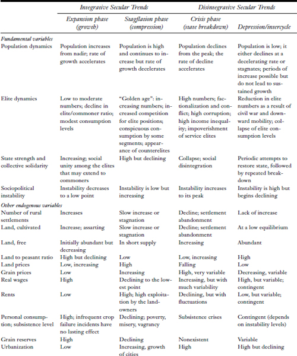

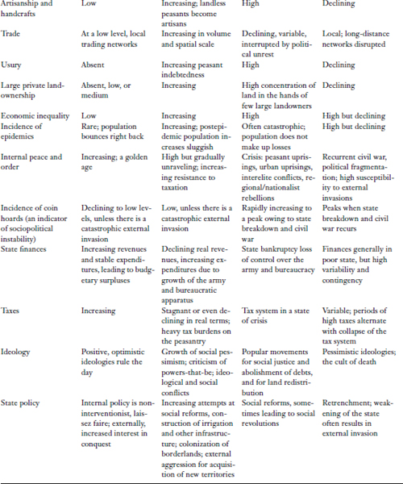

## **第2章**

## **Chapter 2**

## 中世纪英格兰：金雀花王朝周期（1150–1485）

## Medieval England: The Plantagenet Cycle (1150–1485)

## 2.1 周期概述

## 2.1 Overview of the Cycle

我们将中世纪英格兰的世俗周期分为两个激烈而长期的内部冲突时期：斯蒂芬统治时期的无政府状态（1138-53）和玫瑰战争（1455-85）。由于这一时期（大约 1150 年至 1485 年）是金雀花王朝（包括其兰开斯特王朝和约克王朝分支）所跨越的时期，因此我们将其称为金雀花王朝周期。我们将这一周期的结束时间定为 1485 年，这可能没有争议，因为大多数权威人士都认为，英格兰的人口状况在 15 世纪末从停滞转为增长。至于周期的起点，英国的人口持续增长显然直到12世纪末才开始。这是一个比较有争议的观点，支持它的经验证据将在本节后面介绍。

We bracket the secular cycle of medieval England by two periods of intense and prolonged internal conflict: the Anarchy during the reign of Stephen (1138–53) and the Wars of the Roses (1455–85). Because this period, roughly 1150–1485, was spanned by the Plantagenet dynasty (including its Lancastrian and Yorkist branches), we will refer to it as the Plantagenet cycle. The end of the cycle, which we assign to 1485, is probably uncontroversial, since most authorities agree that the population regime in England changed from stagnation to growth at the end of the fifteenth century. As to the starting point of the cycle, sustained population growth in England apparently did not get going until the end of the twelfth century. This is a more controversial point, and the empirical evidence supporting it is introduced later in this section.

在我们对每个案例研究的讨论中，我们使用以下方案。首先，我们提供有关主要变量动态的数据，这些变量是长期周期的人口结构解释的核心。我们从人口和经济变量开始，然后转向社会结构和精英动态，最后到政治方面。一旦确定了周期的总体轮廓，我们就将重点转移到研究这些变量在周期的每个阶段（扩张、滞胀、危机和萧条）期间如何相互作用。

In our discussion of each case study we use the following scheme. First we present the data on the dynamics of the major variables that lie at the heart of the demographic-structural explanation of secular cycles. We start with demographic and economic variables, then move on to social structure and elite dynamics, and finally to political aspects. Once the general outlines of the cycle have been established, we shift the focus to examining how these variables interacted with each other during each of the phases of the cycle (expansion, stagflation, crisis, and depression).

## **人口和经济趋势**

## **Trends in Population and Economy**

这一时期人口流动的主要特征是毋庸置疑的（Hatcher 1977，Hallam 1988b，Hatcher and Bailey 2001，Dyer 2002）。直到 13 世纪末，人口总体增长，在 1300 年左右达到顶峰，在 14 世纪初缓慢下降，并加速到与 1348 年黑死病及其余震相关的人口崩溃，以及萧条阶段在 15 世纪的大部分时间里（图 2.1）。人口恢复的最初迹象在 1480 年左右出现，并在 16 世纪持续增长（属于下一个周期）。然而，尽管人口周期的轮廓很清晰，但我们对数量细节（例如 1300 年峰值的精确大小）知之甚少，更重要的是，对持续增长时期何时开始的了解要少得多。

The major features of population movements during this period are not in doubt (Hatcher 1977, Hallam 1988b, Hatcher and Bailey 2001, Dyer 2002). There was a period of general population growth up to the late thirteenth century, a peak around 1300, a slow decline during the early fourteenth century, which accelerated to a population collapse associated with the Black Death of 1348 and its aftershocks, and a depression phase during most of the fifteenth century (figure 2.1). The first signs of population recovery made themselves known around 1480, and there was a sustained increase during the sixteenth century (which belongs to the next cycle). However, although the outlines of the demographic cycle are clear, we know much less about the quantitative details (such as the precise magnitude of the peak in 1300) and, more important, when the period of sustained growth began.

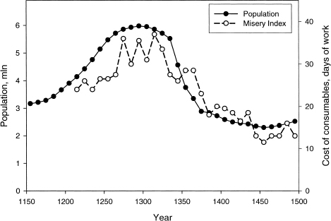

图 2.1 1150-1500 年英格兰的人口数量和“痛苦指数”。Hatcher (1977) 以及 Hatcher 和 Bailey (2001) 的人口数据经过修改以显示十二世纪期间人口增长较慢，继 Hallam (1988b:537) 之后。痛苦指数是实际工资的倒数，这里衡量的是购买一揽子标准消费品所需的工作天数（数据来自 Farmer 1988：表 7.11 和 Farmer 1991：表 5.11 ）。

Figure 2.1 Population numbers and the “misery index” in England, 1150–1500. Population data from Hatcher (1977) and Hatcher and Bailey (2001), modified to show slower growth during the twelfth century, following Hallam (1988b:537). The misery index is the inverse real wage, here measured as the number of days of work needed to purchase the standard basket of consumables (data from Farmer 1988: Table 7.11 and Farmer 1991: Table 5.11).

The starting point of reconstructing the dynamics of English population is the Domesday Book census of 1086. The census lists about 275,000 persons (Hatcher 1977:68) who were either males of working age or heads of households (Harvey 1988). This number needs to be converted into total population. Additionally, allowance must be made for the omission of four northern countries and two major cities from the survey, and for the likelihood of unrecorded subtenants and landless men (Hatcher 1977:68). One important source of uncertainty is the multiplier that should be used to convert the number of heads of households into a total population figure. Russell (1948), using a multiplier of 3.5 per household, estimated the population of England in 1086 as 1.1 million. By contrast, Postan (1966) argued for a figure of 2.5 million. Currently, a multiplier estimate of 4.5–5 appears more plausible (Harvey 1988:48), and the most often quoted number for the population of England in 1086 lies in the range of 1.75–2.25 million (Hatcher 1977:68).

[output not shown]

第二个锚点是 1377 年的人头税，这表明当时英格兰有 2.5 至 300 万人（Hatcher 1977：68）。1348 年至 1377 年间，人口可能下降了 40% 至 50%。此外，从 1300 年到 1348 年，人口数量有所减少。基于这些考虑，Hatcher 估计 1300 年人口峰值为 450 万至 600 万，“可能性的平衡表明该范围更高”（Hatcher 1977： 68）。

The second anchoring point is the 1377 poll tax, which indicates there were between 2.5 and 3 million people in England at that time (Hatcher 1977:68). Between 1348 and 1377 the population probably dropped by 40–50 percent. Additionally, there was some decrease from 1300 to 1348. On the basis of these considerations, Hatcher estimated the peak population in 1300 as 4.5–6 million, “with the balance of possibilities pointing to the higher reaches of this range” (Hatcher 1977:68).

Hallam (1988b) 从 1086 年开始估计了类似的数字。利用 1086 年至 1350 年间各个庄园记录的土地数量信息，并假设家庭规模为 4.7 人，1086 年人口为 200 万，Hallam 得出(1988b:537) 生成的估计值如表 2.1所示。这些数字表明 1086 年至 1300 年期间人口和定居点的扩张不均衡。早些时候（1956 年）迈克尔·波斯坦 (Michael Postan) 曾提出，到 1130 年人口扩张最快，而从 1130 年到本世纪最后四分之一，人口停滞不前 (Postan 1973:276)。最近，Langdon 和 Masschaele 也得出了同样的结论（2006：63）。

A similar number was estimated by Hallam (1988b) working forward from 1086. Using the information about the number of holdings recorded on various manors between 1086 and 1350, and assuming that the household size was 4.7 people and the 1086 population was 2 million, Hallam (1988b:537) generated the estimates shown in table 2.1. These figures indicate that population and settlement expanded in an uneven manner during the period of 1086–1300. Earlier (in 1956) Michael Postan had suggested that population expansion was most rapid to 1130, while between 1130 and the closing quarter of the century population stagnated (Postan 1973:276). More recently, the same conclusion was reached by Langdon and Masschaele (2006:63).

事实上，即使这样的结论也可能过于乐观。某些数据虽然不完整，但表明人口可能在十二世纪中叶由于斯蒂芬和玛蒂尔达的追随者之间的内战而下降。因此，*盖斯塔·斯蒂芬尼（Gesta Stephani）*谈到村庄“孤独地矗立着，几乎空无一人”，还谈到由于农民死亡或逃亡而未收割的田地（Miller and Hatcher 1978：x）。此外，亨利二世统治初期的税收数额比 1130 年减少了 25%。不仅仅是由于内战造成的税收中断。官员们报告说，许多以前肥沃的土地现在变成了“荒地”。此外，英国国家的财政机制到 1165 年已完全恢复，但直到亨利二世 (1154-89) 统治末期，他的收入才与亨利一世所享有的收入相匹配。因此，很可能在斯蒂芬统治期间，总人口下降。人口快速扩张在十二世纪末恢复，并持续到十三世纪的大部分时间。1180-1220 年期间突然出现的通货膨胀（Harvey 1973）是人口状况发生变化的间接证据。

In fact, even this conclusion may be too optimistic. Certain data, although admittedly fragmentary, suggest that the population may have declined during the middle of the twelfth century as a result of the civil war between the adherents of Stephen and Matilda. Thus, *Gesta Stephani* speaks of villages “standing lonely and almost empty” and of fields unharvested because the peasantry had perished or fled (Miller and Hatcher 1978:x). Furthermore, the amount of taxes collected during the early years of Henry II reign shrank by 25 percent compared to 1130. This decline was not due simply to the disruption of revenue collection resulting from the civil war. Officials reported that many previously productive lands were now “waste.” Furthermore, the fiscal machinery of the English state had fully recovered by 1165, yet it was only at the very end of Henry II's (1154–89) reign that his revenues matched those enjoyed by Henry I. Thus, it is very likely that the general population declined during Stephen's reign. Rapid population expansion resumed at the end of the twelfth century and continued during most of the thirteenth century. The sudden appearance of inflation during 1180–1220 (Harvey 1973) is indirect evidence of the changed population regime.

Hatcher 和 Hallam 均估计人口峰值约为 600 万人，这一估计反映在图 2.1的曲线中。Campbell (2005) 继续主张较低的峰值数量（425 万）。我们倾向于接受更高的估计，但无论最终占主导地位的观点对于我们的主要论点来说并不重要，因为它依赖于相对人口变化，而这是没有争议的。

Both Hatcher and Hallam estimate peak population to be in the vicinity of 6 million people, and that estimate is reflected in the curve in figure 2.1. The case for lower peak numbers—4.25 million—continues to be made by Campbell (2005). Our inclination is to accept the higher estimate, but whichever point of view prevails in the end is not important for our main argument, because it relies on relative population changes, which are noncontroversial.

最后的路标是 1520 年代的纳税申报表和集合证明，这表明 1522-25 年左右英格兰的人口在 225-275 万之间（Hatcher 1977:69）。有充分的理由相信，此时人口已经从十五世纪中叶的最低点恢复过来。哈彻认为，在人口最低点时，英格兰的人口数量为 2 至 250 万人。因此，从 1086 年到 1300 年，英国人口增加了三倍，但到 1450 年却下降到仅略高于末日审判时期的英格兰人口水平（Hatcher 1977：图 1）。

The final signpost is the tax returns and muster certificates of the 1520s, which suggest that the population of England around 1522–25 was in the range of 2.25–2.75 million (Hatcher 1977:69). There is a good reason to believe that by this time, the population had recovered from the lowest point in the mid-fifteenth century. Hatcher suggests that at the population nadir, England contained between 2 and 2.5 million people. Thus, the English population increased by a factor of three from 1086 to 1300, but by 1450 had declined to a level scarcely above that of Domesday England (Hatcher 1977: Figure 1).

价格变动忠实地反映了人口动态（图2.2）。价格从十二世纪中叶每季度小麦 1.5 先令（每公担 11 克白银，1 公担 = 100 公斤）的低水平上涨至 6 先令以上。（44 克 S/公担）在十四世纪初。总体而言，从 1180 年到 1330 年，价格上涨了四到五倍（Farmer 1988：718）。1350之后四分之一小麦价格继续围绕6s水平波动。然而，以白银计算时，小麦的价格下降了两倍多（至 20-25 克标准银/公担）。

The movement of prices mirrored faithfully population dynamics (figure 2.2). Prices rose from the low level of 1.5 shillings (s.) per quarter of wheat (11 g of silver per quintal, 1 quintal = 100 kg) in the mid-twelfth century to more than 6 s. (44 g S/quintal) in the early fourteenth century. Overall, between 1180 and 1330 there was a four- to fivefold rise in prices (Farmer 1988:718). After 1350 the price of a quarter of wheat continued to fluctuate around the level of 6 s. When expressed in silver, however, the price of wheat declined more than twofold (to 20–25 g S/quintal).

名义工资没有表现出周期，而是相当单调地增长。因此，建筑工匠的工资从 13 世纪末的每天 3 便士（d.）增加到 6 便士（d.）。十六世纪初每天（Phelps-Brown 和 Hopkins 1955）。相比之下，实际工资则在价格循环运动的推动下出现振荡（图 2.3）。图2.3中的“农村工资”是农场工人的工资，由克拉克最近编制（2007b）。“城市工资”是伦敦和牛津工人和工匠实际工资的平均数（Allen 2001）。两条曲线显示出相似的动态。实际工资在十三世纪下降，在十四世纪第二个十年达到绝对最低水平。此后除了短期波动外，它们持续增长，直到1430年代。在十五世纪剩余的时间里，它们保持在大致恒定的高水平。城市和乡村之间一个有趣的区别在于总体增长幅度：城市工资略低于两倍，但农村工资则超过三倍。（一种可能的解释是，农村人口相对减少更为明显；请参阅后面关于城市化动态的讨论。）

Nominal wages did not exhibit a cycle but grew fairly monotonically. Thus, a building craftsman's wage increased from 3 pennies (d.) per day in the late thirteenth century to 6 d. per day in the early sixteenth century (Phelps-Brown and Hopkins 1955). Real wages, by contrast, exhibited an oscillation, driven by the cycling movement of prices (figure 2.3). The “rural wage” in figure 2.3 is the farm laborer's wages, recently compiled by Clark (2007b). The “urban wage” is the average of real wages of laborers and craftsmen in London and Oxford (Allen 2001). Both curves show similar dynamics. Real wages declined during the thirteenth century, reaching an absolute minimum during the second decade of the fourteenth century. After that they grew continuously, apart from short-term fluctuations, until the 1430s. During the rest of the fifteenth century they stayed at an approximately constant high level. One interesting difference between city and country is in the overall magnitude of increase: just under twofold in the urban wage, but over threefold in the rural wage. (One possible explanation is that relative depopulation was more pronounced in the countryside; see the later discussion of urbanization dynamics.)

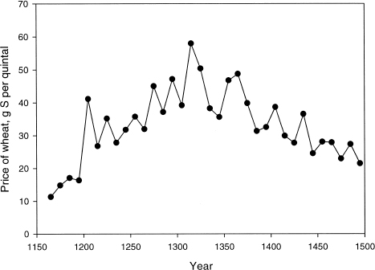

图 2.2 以克银计算的一公担（100 公斤）小麦的价格（数据来自 Farmer 1988：表 7.1和 Farmer 1991：表 5.1）。

Figure 2.2 The price of a quintal (100 kg) of wheat in grams of silver (data from Farmer 1988: Table 7.1 and Farmer 1991: Table 5.1).

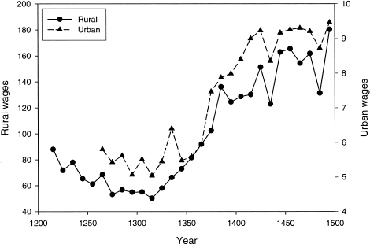

图 2.3 实际工资：农村（Clark 2007b）和城市（Allen 2001）。单位是任意的。

Figure 2.3 Real wages: rural (Clark 2007b) and urban (Allen 2001). Units are arbitrary.

**表 2.2**

**TABLE 2.2**

诺福克郡塞奇福德收割工人消耗的食品（按价值、百分比）

Foodstuffs (by value, in percentages) consumed by harvest workers at Sedgeford, Norfolk

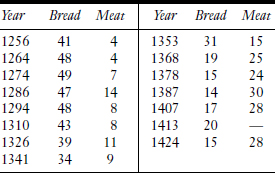

*资料来源：*戴尔 (2000:82)。

*Source:* Dyer (2000:82).

农民消费模式也受到人口流动的影响。十三世纪下半叶，农民饮食以面包为主，肉类消费很少（表2.2）。面包在饮食中的比例在1300年后开始下降，在黑死病之后下降到不足20%。肉类消费量从 1250 年代和 1260 年代的 4% 增加到 14 世纪末的 30%。

Peasant consumption patterns were also affected by population movements. During the second half of the thirteenth century the peasant diet was dominated by bread, with very little meat consumed (table 2.2). The proportion of bread in the diet started to decline after 1300 and decreased to less than 20 percent after the Black Death. Meat consumption increased from 4 percent in the 1250s and 1260s to 30 percent at the end of the fourteenth century.

## **社会结构和精英动态**

## **Social Structure and Elite Dynamics**

Turning to the social composition of the population and how it changed during the cycle, we first focus on the magnates, the upper elite stratum. In 1166 there were 133 baronies in England, defined as any tenure in chief with five or more knights’ fees (Painter 1943:26). In 1200 this number increased to 160 (Painter 1943:170). By 1300 the baronage may have included well over 300 families. According to Matthew Paris, Henry III (d. 1272) could recall the names of 250 English baronies, and there were actually even more “barons” because of partition among heiresses, since the holder of a portion of a barony was still regarded as a baron (Pugh 1972:117). However, not all “barons” may be considered magnates. The question of whom to include in the top stratum of English society is further complicated by shifting definitions, since the decades around 1300 were a period of transition from the tenurial to the parliamentary baronage (Painter 1943:173). The best guess is that there were 200–220 magnate families in England around 1300 (Painter 1943, Given-Wilson 1987). R. J. Wells (cited in Given-Wilson 1987:188) identified 217 families belonging to the greater baronage in 1300. This number is not very different from the 196 heads of noble families summoned to a parliament in the period of 1295–1325 (McFarlane 1973: Appendix B). To summarize, the numbers of magnates increased between 1166 and 1300, but this increase probably did not match the general population increase (table 2.3).

|  | **表 2.3** **TABLE 2.3** |  |  |  |
| --- | --- | --- | --- | --- |
|  | 英国富豪的人数和收入 Numbers and incomes of English magnates |  |  |  |
|  | *年* | *巨头数量* | *平均收入* |  |
|  | 1086 | 170 名贵族 | 200英镑 |  |
|  | 1166 | 133 男爵 | 200英镑 |  |
|  | 1200 | 160 名贵族 | 200英镑 |  |
|  | 1300 | 220 名大贵族（196 名贵族） | 668英镑 |  |
|  | 第1436章 | 73 同行 | 881英镑 |  |
|  | *资料来源：* Painter (1943) 和 Give-Wilson (1987) 的数据 *Source:* Data from Painter (1943) and Given-Wilson (1987) |  |  |  |

1300年后巨头层的动态可以利用KB McFarlane提供的数据来追踪（表2.4）。直到 1350 年，贵族数量有所增加或大致保持不变（取决于我们关注的是时期开始时的数字还是总数）。该阶层的规模在1350年后开始下降，在15世纪上半叶急剧下降，然后在本世纪末趋于平稳。1540年，同侪家庭的数量仍然在六十个左右，进入了下一个世俗周期（见下一章）。

The dynamics of the magnate stratum after 1300 can be followed using the data presented by K. B. McFarlane (table 2.4). Until 1350 the nobility increased or stayed roughly constant (depending on whether we focus on the numbers at the start of the period or on total numbers). The size of the stratum started to decline after 1350, plunged during the first half of the fifteenth century, and then leveled off by the end of the century. The number of peer families was still around sixty in 1540, well into the next secular cycle (see the next chapter).

麦克法兰计算的灭绝率讲述了类似的故事：在 1400 年至 1425 年之前普遍增加，此后减少。然而，更重要的因素是被召集到议会的新家庭数量急剧下降。因此，1400年左右贵族阶层的减少是通过提高灭绝率和降低向上流动性来实现的，而1450年后时代的均衡则是持续较低的向上流动性和下降的灭绝率的结果。

The extinction rates calculated by McFarlane tell a similar story: a general increase up to 1400–1425 and a decline after that. However, an even more important factor was a drastic drop in the number of new families summoned to parliaments. Thus, the reduction in the peerage around 1400 was accomplished both by enhanced extinction rates and by lowered upward mobility, while the equilibrium of the post-1450 era was a result of continuing low upward mobility and decreased extinction rate.

**表 2.4**

**TABLE 2.4**

十四、十五世纪英国贵族家庭数量

Numbers of noble families in England during the fourteenth and fifteenth centuries

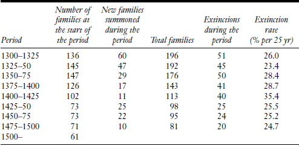

*资料来源：*（McFarlane 1973：附录 B）。

*Source:* (McFarlane 1973: Appendix B).

*注：*贵族家族的定义是，其族长在 1295 年之后的任何时间收到议会传票的家族。

*Note:* Noble families are defined as those whose head received at any time after 1295 a writ of summons to a parliament.

我们还应该评论相当高的平均灭绝率，每四分之一世纪在 25% 到 35% 之间波动。28% 的平均比率意味着每个世纪有超过 70% 的家庭灭绝。这一结果部分归因于麦克法兰使用的灭绝技术定义，这在一定程度上夸大了实际速率。但结论仍然不可避免：中世纪后期英国贵族的特点是替代率低。为了进行比较，我们可以使用 RJ Wells 编制的统计数据（引自 Given-Wilson 1987:188）。根据威尔斯的说法，在 1216 年的 206 个男爵家族中，到了 1300 年，有 77 个（37%）已经灭绝或遭受贬损。这些数字意味着 13 世纪英国贵族家族每 25 年就有 13% 的灭绝率；这一比率是接下来两个世纪的一半。这种差异如此之大，以至于即使我们考虑到这两项研究中使用的不同的灭绝定义，定性结论也应该保持不变。

We should also comment on the fairly high average extinction rate, which fluctuated between 25 percent and 35 percent per quarter-century. The average rate of 28 percent implies that more than 70 percent of families went extinct each century. This result is in part due to the technical definition of extinction used by McFarlane, which somewhat inflates the real rate. But the conclusion is still inescapable: the English nobility of the later Middle Ages was characterized by a poor replacement rate. For comparison, we can use the statistics compiled by R. J. Wells (cited in Given-Wilson 1987:188). According to Wells, of the 206 baronial families in 1216, 77 (37 percent) had gone extinct or suffered derogation by 1300. These numbers imply a 13 percent extinction rate per twenty-five years for the English magnate families during the thirteenth century; a rate that is half that for the succeeding two centuries. This difference is so strong that the qualitative conclusion should remain unchanged even when we take into account the different definitions of extinction used in these two studies.

为了对更广泛的精英阶层的数字动态有一定的了解，我们转向由 JC Russell (1948) 分析并由 TH Hollingsworth (1969) 重新分析的关于尸检调查的重要数据。这些数据涉及约 8,000 名佃户，即直接从国王手中拥有土地的人。样本中既包括巨头，也包括一些拥有少量土地的个人，但主要是中层地主，因此它应该能让我们很好地了解整个精英阶层的情况。替代率（Hollingsworth 重新计算 Russell 的数据后）如图 2.4所示。它表明，直到黑死病爆发之前，精英的数量仍在持续扩大（替代率高于 1）。在下一个世纪，这种模式几乎是均匀下降，最严重的时期是在 1400 年左右。只有在 1450 年之后，曲线才突破更替率，而上次出现在 13 世纪的人口快速增长，只有在 1450 年才恢复。十五世纪末。

To gain some understanding of the numerical dynamics of the broader elite strata, we turn to the remarkable data on inquisitions post mortem analyzed by J. C. Russell (1948) and reanalyzed by T. H. Hollingsworth (1969). The data deal with some 8,000 tenants-in-chief, that is, persons who held land directly from the king. The sample includes both magnates and some individuals holding minute amounts of land but is dominated by middle-rank landowners, so it should give us a good idea of what was happening to the elites as a whole. The replacement rate (following recalculation of Russell's data by Hollingsworth) is plotted in figure 2.4. It shows that the numbers of elites continued to expand right up to the Black Death (the replacement rate is above one). During the next century the pattern is of one of almost uniform decline, with the worst period around 1400. Only after 1450 does the curve break above the replacement rate, and the rapid population growth, last seen during the thirteenth century, resumes only at the very end of the fifteenth century.

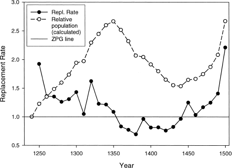

图 2.4 土地精英的数字动态。实线表示根据事后调查计算得出的替代率。虚线表示根据更替率计算的相对数值动态，假设一代时间为 32 年。“ZPG”线表示人口增长为零，此时替代率正好为一。数据来自 Hollingsworth (1969)。

Figure 2.4 Numerical dynamics of landed elites. Solid line indicates replacement rates calculated from inquisitions post mortem. Dashed line indicates relative numerical dynamics calculated from the replacement rates, assuming a generation time of 32 years. “ZPG” line denotes zero population growth, when the replacement rate is precisely one. Data from Hollingsworth (1969).

替代率曲线的模式如图2.4所示对十四世纪主农比例的动态变化有着有趣的影响。如前所述，人们普遍认为总人口在 1300 年之后不久就开始下降。另一方面，拥有土地的精英的数量又持续增加了 50 年。我们可以通过计算精英的相对人口数来估计这一增长的幅度，从 1240 分之一开始，然后使用替代率来预测人口变化向前一步。计算得出的相对人口在 1300 年至 1350 年间增加了 40%。当然，我们不能得出精英人数增加相同数量的结论，因为精英动态不仅受生物繁殖率的影响，还受社会向上和向下流动的影响。尽管如此，十四世纪上半叶，精英人数似乎持续增加，而平民人数下降。由于这两个过程，主农比例在黑死病爆发前夕必然大幅增长。

The pattern of the replacement rate curve shown in figure 2.4 has interesting implications for the dynamics of the lord-peasant ratio during the fourteenth century. As previously noted, it is generally agreed that general population started declining soon after 1300. The numbers of the landed elites, on the other hand, continued to increase for another fifty years. We can estimate the magnitude of this increase by calculating the relative population of elites, starting with one in 1240 and then using the replacement rate to project the population change one step forward. The calculated relative population increases by 40 percent between 1300 and 1350. Naturally, we cannot conclude that the elite numbers increased by the same amount, because elite dynamics are governed not only by the biological reproductive rate but also by upward and downward social mobility. Nevertheless, it seems likely that during the first half of the fourteenth century elite numbers continued to increase while commoner numbers declined. As a result of both these processes, the lord-peasant ratio must have grown substantially on the eve of the Black Death.

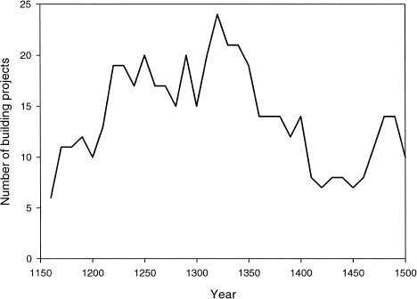

图 2.5 每个十年在建重大建筑项目的数量，1150-1500（Morris 1979 之后：图 7）。

Figure 2.5 Number of major building projects in progress in each decade, 1150–1500 (after Morris 1979: Figure 7).

作为精英消费模式的有用指标，我们可以关注教会建筑的动态。一般来说，公共建筑既可以由国家资助，也可以由精英资助，但在中世纪的英格兰，国家在教堂建设中扮演的角色较小。建造教堂的资金由广泛的精英人士提供——教会人士、世俗贵族和城市富人。当我们观察教会建设活动的动态时（图2.5），我们观察到一种稳步上升的趋势，在十四世纪上半叶达到顶峰，然后在十五世纪上半叶降至最低点。如果教堂建设活动是精英经济繁荣的合理指标，那么这种模式表明精英替代率直接反映精英经济繁荣。

As a useful indicator of elite consumption patterns, we can look to the dynamics of ecclesiastical building. Generally speaking, public building can be funded both by the state and by the elites, but in medieval England the state played a minor role in church building. Funds to build churches were provided by a broad spectrum of elites—ecclesiastical, lay nobility, and the urban rich. When we look at the church-building activity dynamics (figure 2.5), we observe a steadily rising trend that reaches a peak during the first half of the fourteenth century, then collapses to a minimum during the first half of the fifteenth century. If church-building activity is a reasonable index of economic prosperity of the elites, this pattern suggests that elite replacement rates responded directly to elite economic prosperity.

## **国家财政**

## **State Finances**

中世纪英国国家的收入来源多种多样，令人眼花缭乱，仅保存了零碎的文献资料，这使得重建国家预算成为一项非常艰巨的任务。然而，各种类型的收入可以分为三大类：皇家土地（“农场”）、税收和封建来源。这些来源的相对重要性在关注期间发生波动。1086 年，王室拥有王国约 18% 的土地收入，每年价值约 11,000 英镑（Dyer 2002：82）。王室庄园贡献了国家总收入的60%。1165 年，农场仍占总收入的 61%，其中 23% 来自税收，司法和其他支出占 16%（White 2000：160）。然而，从那时起，皇家土地的贡献呈现出长期下降的趋势（尽管围绕这一趋势存在一些短期波动）。1300 年左右，农场的产量为 13,000 至 14,000 英镑（Dyer 2002：115），与威廉一世时代相比，实际价值大幅下降。此时，皇家土地对国家总收入的贡献降至 20%。看待这个数字的另一种方式是注意到国王在总土地收入中所占的份额已经下降到 2% (Dyer 2002:115)。

The English state in the Middle Ages derived its revenues from a bewildering variety of sources, for which only fragmentary documentation has been preserved, making the reconstruction of state budgets a very difficult task. Nevertheless, various types of revenue can be grouped in three general classes: the Crown lands (“the farms”), taxation, and feudal sources. The relative importance of these sources fluctuated during the period of interest. In 1086 the Crown held around 18 percent of the landed revenues of the kingdom, valued at approximately £11,000 per annum (Dyer 2002:82). The royal estates contributed 60 percent of the total state revenue. In 1165 the farms were still responsible for 61 percent of the total revenues, 23 percent was raised from taxation, and judicial and other payments contributed 16 percent (White 2000:160). However, from that point on the contribution of the Crown lands exhibited a declining secular trend (although there were several short-term fluctuations around this trend). Around 1300 the farms yielded £13,000–14,000 (Dyer 2002:115), a major decline in real terms compared with the times of William I. At this time the contribution of Crown lands to the total state revenues dropped to 20 percent. Another way of looking at this number is to note that the king's share of the overall landed income had fallen to 2 percent (Dyer 2002:115). During the reign of Edward III (1327–77) the farms contributed only 5 percent of the total income (Madge 1938:30).

Ramsay (1925) 使用财政账目（管道卷）追踪 1400 年之前的皇家收入历史。由于各种技术原因，他的计算受到了很多批评。然而，我们感兴趣的不是任何特定年份的具体数字，而是王室财政的整体动态，为此目的，拉姆齐的数据可以作为一个粗略的指导。当以实际价值表示时（通过小麦价格缩小收入），我们观察到，在 13 世纪的大部分时间里，随着人口的增长，实际收入稳步下降（图 2.6 ）。

Ramsay (1925) used Exchequer accounts (the pipe rolls) to trace the history of royal revenues for the period up to 1400. His calculations have been much criticized, for a variety of technical reasons. However, we are interested not in specific numbers for any particular year but in the overall dynamics of royal finances, and for that purpose Ramsay's numbers can serve as a rough guide. When expressed in real terms (deflating them by the price of wheat), we observe that real revenues declined steadily during most of the thirteenth century at a time when population was increasing (figure 2.6).

十三世纪的收入下降模式在两次爆发中得到逆转，第一次是爱德华一世（1272-1307）领导下的，第二次是爱德华三世（1327-77）领导下的。由于到爱德华三世统治时期，农场在皇家收入中所占的比例已经很小，因此主要的新收入来源是直接和间接的税收（Ormrod 1999）。中世纪英国税收的上升（和下降）可以从帕特里克·奥布莱恩（Patrick O'Brien）编制的数据中看出（图 2.6）。这些数据表明，税收收入在 14 世纪末达到顶峰后开始下降，直到 1485 年新周期开始后才出现逆转。

The thirteenth century's pattern of revenue decline was reversed in two spurts, the first one under Edward I (1272–1307) and the second one under Edward III (1327–77). Since by the reign of Edward III the farms had fallen to a very minor part of royal revenues, the main new source of revenues was taxes, both direct and indirect (Ormrod 1999). The rise (and fall) of medieval English taxation can be traced in the data compiled by Patrick O'Brien (figure 2.6). These data indicate that after a peak achieved in the late fourteenth century, tax revenues went into a decline that was reversed only after 1485 with the start of a new cycle.

## **社会政治不稳定**

## **Sociopolitical Instability**

England during the Middle Ages was racked by periodic baronial rebellions, which seemed to recur at intervals of fifty to sixty years (figure 2.7 and table 2.5). However, during the thirteenth century, internal warfare was not as protracted and intense as during the fourteenth century and, especially, the fifteenth century. This trend can be measured, for example, by the treatment of defeated high-status enemies. “Between the later eleventh and the early fourteenth century, defeated political opponents of high birth were rarely dispossessed and scarcely ever maimed or killed in cold blood” (Bartlett 2000:60). Internal wars during the fourteenth century and, particularly, the fifteenth century were much more sanguinary. This point is best illustrated by the fates of royal losers: the deposition was followed by murder in prison (or at least death under suspicious circumstances) for Edward II (1327), Richard II (1400), Henry VI (1471), and Edward V (1483). Finally, Richard III was killed on the battlefield (1485).

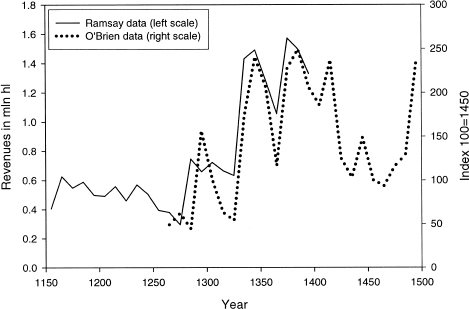

图 2.6 英国实际收入，1150-1400，基于 Ramsay (1925) 的数据（实线）。单位为百万公顷。税收收入 (1260–1500)：十年平均值，指数为 1450 = 100%。（基于 Richard Bonney 的欧洲国家金融数据库中的 O'Brien 数据，文件 \obrien\engm009.txt。）

Figure 2.6 English real revenues, 1150–1400, based on data from Ramsay (1925) (solid line). Units are millions of hectaliters. Revenue from taxation (1260–1500): decadal averages, indexed to 1450 = 100%. (Based on O'Brien's data from Richard Bonney's European State Finance Database, files \obrien\engm009.txt.)

硬币囤积的时间分布支持了这种解释（图 2.7）。在十二世纪中叶达到顶峰后，囤积量下降到十三世纪初的最低水平。13 世纪和 14 世纪出现了逐渐（且不均衡）的上升，并在 1370 年左右达到顶峰。15 世纪下半叶的另一个高峰与玫瑰战争相关的不稳定密切相关。事实上，不稳定指数的峰值（通过计算每二十年内战或叛乱的年数而构建）与囤积的时间分布之间存在普遍的对应关系（图2.7 ））。唯一显着的不匹配是囤积指数的主要峰值 1370 和不稳定指数的 1400 之间。然而，我们应该注意到，这种比较依赖于非常不充分的囤积数据。我们不得不依赖 Thompson（1956）的汇编，它已经过时了 50 年。我们知道，更多的英国中世纪宝藏引起了钱币学家的注意，或者在金属探测器的帮助下被发现，但我们无法找到任何更新汤普森数据的汇编。

The temporal distribution of coin hoards supports this interpretation (figure 2.7). After a peak in the mid-twelfth century, hoards dropped off to the early thirteenth-century minimum. The thirteenth and fourteenth centuries saw a gradual (and uneven) rise, culminating in a peak around 1370. Another great peak during the second half of the fifteenth century closely tracks instability associated with the Wars of the Roses. In fact, there is a general correspondence between the peaks in the instability index, constructed by counting years in civil war or rebellion per twenty years, and the temporal distribution of hoards (figure 2.7). The only significant mismatch is between the major peaks of 1370 in hoards and 1400 in instability index. We should note, however, that this comparison relies on a very inadequate hoard data. We had to rely on the compilation by Thompson (1956), which is fifty years out of date. We know that many more English medieval hoards came to the attention of numismaticists or were discovered with the aid of a metal detector, but we were unable to find any compilations updating Thompson's data.

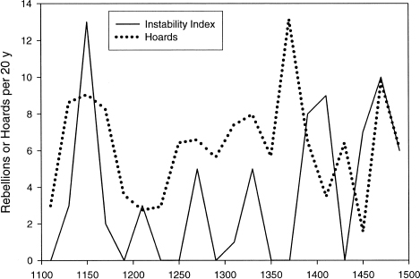

图 2.7 1100-1500 年英格兰的社会政治不稳定：每 20 年叛乱和内战的发生率（实线）和每 20 年囤积的数量（虚线）。不稳定指数由表2.5数据计算得出；硬币囤积数据来自 Thompson (1956)。

Figure 2.7 Sociopolitical instability in England, 1100–1500: incidence of rebellions and civil wars per 20 years (solid line) and the number of hoards per 20 years (dotted line). Instability index is calculated from the data in table 2.5; coin hoard data are from Thompson (1956).

我们对金雀花王朝世俗周期期间总体趋势的概述到此结束。在接下来的部分中，我们将更详细地讨论按周期阶段组织的人口结构动态。

This concludes our overview of general trends during the Plantagenet secular cycles. In the next sections we turn to a more detailed discussion of demographic-structural dynamics organized by cycle phases.

## 2.2 扩张阶段（1150-1260）

## 2.2 The Expansion Phase (1150–1260)

我们缺乏直接的估计，但持久的人口增长一定是在斯蒂芬的无政府统治结束和亨利二世统治下建立稳定后不久就开始的。自 1160 年以来小麦价格的持续上涨提供了这种增长的间接证据（见图2.2）。人口过剩的其他迹象包括农民土地分散的证据。JZ Titow (1961) 在一篇关于汤顿萨默塞特庄园的经典论文中表明，1248 年，土地与农民的比例为 3.3 英亩（1.33 公顷），而在 1311 年最多为 2.5 英亩（1 公顷）。

We lack direct estimates, but lasting population growth must have started soon after the end of Stephen's anarchic reign and the establishment of stability under Henry II. Indirect evidence of this growth is provided by the persistent inflation in the prices of wheat from 1160 (see figure 2.2). Other signs of overpopulation include evidence of fragmentation of peasant holdings. In a classic paper on the Somerset manor of Taunton, J. Z. Titow (1961) showed that in 1248, the land-to-peasant ratio was 3.3 acres (1.33 ha), while in 1311 it was 2.5 acres (1 ha) at best.

这一时期的政治不稳定达到了整个中世纪时期的最低水平（表2.5和图2.7））。然而，这一时期并非没有冲突。发生了三大政治危机：1173-74 年的叛乱、约翰统治末期的内战以及 1258 年的麻烦，导致 1263-67 年的“男爵战争”（Mortimer 1994：77）。1173-74 年的麻烦始于诺曼底，然后蔓延到英格兰，那里有几位心怀不满的伯爵发动叛乱（以中部地区为中心）。法国和苏格兰国王入侵，但被王室忠诚者击败。四十年后的下一场严重冲突是封建贵族与约翰·拉克兰之间的政治宪法斗争，最终导致了《大宪章》。1173-74 年和 1215-17 年的两次内战都是相当温和的冲突（按照中世纪的标准），主要是通过机动和围攻进行的。第 2 节讨论 1263-66 年内战及其后的冲突。

Political instability during this period achieved the lowest level of the whole medieval period (table 2.5 and figure 2.7). Nevertheless, this period was not conflict-free. There were three major political crises: the rebellion of 1173–74, the civil wars at the end of John's reign, and the troubles of 1258, leading into the “barons’ wars” of 1263–67 (Mortimer 1994:77). The troubles of 1173–74 started in Normandy and then spread to England, where several disgruntled earls were in revolt (centered in the Midlands). The kings of France and Scotland invaded, but were defeated by royal loyalists. The next serious conflict, forty years later, was a politicoconstitutional struggle between the feudal barons and John Lackland that eventually led to the Magna Carta. Both civil wars of 1173–74 and 1215–17 were fairly mild conflicts (by medieval standards), mostly conducted by maneuvering and sieges. The civil war of 1263–66 and conflicts after it are discussed in section 2.4.

**表 2.5**

**TABLE 2.5**

英格兰发生叛乱、政变、内战和其他内战，1100 年至 1500 年

Occurrence of rebellions, coups d'état, civil wars, and other instances of internal war in England, 1100–1500

[output not shown]

*资料来源：*遵循 Sorokin (1937)，并由 Stearns (2001) 补充。

*Source:* Following Sorokin (1937), supplemented by Stearns (2001).

## 2.3 滞胀（1260–1315）

## 2.3 Stagflation (1260–1315)

## **农村人口**

## **Rural Population**

人口继续增长至 1300 人，但速度有所放缓，英格兰和威尔士的总人口已接近 600 万大关。在一些地区，增长显然完全停止了。

Population growth continued to 1300, but at a slowing rate, as overall population numbers in England and Wales approached the six million mark. In some regions growth apparently ceased altogether.

这一时期出现了马尔萨斯-李嘉图框架所假设的人口过剩的经典迹象。物价在1310年代达到长期峰值（见图2.2），实际工资下降（见图2.3），土地租金上涨（表2.6）。租用时缴纳的入门罚款是房东从土地中获取收入的另一种手段。十三世纪中叶之前罚款的证据很少，但现有证据表明罚款的增长速度甚至比租金的增长还要快（表 2.7）。

This period saw the development of the classic signs of overpopulation, as postulated by the Malthusian-Ricardian framework. Prices reached a secular peak in the 1310s (see figure 2.2), real wages declined (see figure 2.3), and land rents increased (table 2.6). Entry fines paid on taking up tenancy were another means by which landlords could extract income from land. Evidence for fines prior to the mid-thirteenth century is scarce, but what there is suggests they increased even more steeply than the rents (table 2.7).

**表 2.6**

**TABLE 2.6**

租金，1000–1450

Rents, 1000–1450

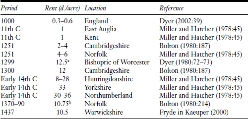

<sup>a</sup>每英亩的平均租金和会费。

<sup>a</sup> Average rents and dues per acre.

<sup>b</sup>这是公开市场利率。对于服务被折算的传统土地，房东要求 24 天。但找不到接受者。

<sup>b</sup> This is the open market rate. For customary land where services were commuted landlords demanded 24 d. but could not find takers.

对 1279-80 年百卷的分析表明，每英亩租金取决于土地规模、租户是否自由、地主是教会还是世俗、土地肥力等因素（Kanzaka 2002）。罚款的一些变化可能是由于土地肥力的差异、未来佃户的情况、离市场的远近以及非农业就业的机会造成的（Miller and Hatcher 1978：46）。也有可能，一些领主在提高租金方面没有灵活性的情况下，使用入门罚款作为增加土地回报的一种方式。租金和罚款所表现出的巨大波动性无法进行精确的定量表述，但总体趋势是明确无误的：在滞胀阶段，土地所有者从农民那里榨取剩余的能力有所增强。

An analysis of the Hundred Rolls of 1279–80 suggested that rent per acre depended on the size of the holding, whether the tenant was free or unfree, whether landlords were church or lay, and land fertility, among other factors (Kanzaka 2002). Some of the variation in fines was probably explained by differential land fertility, the circumstances of the prospective tenant, nearness to markets, and access to nonagrarian employment (Miller and Hatcher 1978:46). It is also possible that some lords used entry fines as a way to increase returns on land where they had no flexibility in raising rents, for example. The great amount of variability exhibited by rents and fines precludes precise quantitative statements, but the overall trend is unmistakable: the ability of landowners to extract surplus from peasants increased during the stagflation phase.

在此期间，农民的土地变得越来越分散。以下是格里格 (Grigg) 汇总的一些数字 (1980:68)。在伍斯特主教庄园，拥有庭院土地（30 英亩或 12 公顷）的农民比例从 1250 年的 33% 下降到 1300 年的 25%。在肯普西，小农数量在 1182 年至 1299 年间增加了两倍。汤顿庄园的土地面积在 1248 年为 1.3 公顷，到 1311 年下降到 1 公顷。到 13 世纪末，根据不同教会领主拥有的庄园样本，33% 的人口拥有的土地不足 1 公顷。据多个权威机构估计，为一个家庭提供生计所需的农场的最小面积为 4.5-6 公顷。到 1300 年，英格兰的大多数农民所拥有的土地数量少于这一数量，如果没有其他收入来源就无法生存（Grigg 1980：68）。土地所有权的分布（表 2.8）在 13 世纪末表明半处女的持有量既是中位数也是平均值。

Peasant holdings became increasingly fragmented during this period. Here are some numbers, brought together by Grigg (1980:68). On the bishop of Worcester's estate, the proportion of peasants who held a yardland (thirty acres or 12 ha) declined from 33 percent in 1250 to 25 percent in 1300. At Kempsey, the number of smallholders tripled between 1182 and 1299. The average holding on a manor in Taunton was 1.3 ha in 1248, declining to 1 ha in 1311. By the end of the thirteenth century, on a sample of estates owned by various ecclesiastical lords, 33 percent of the population had less than 1 ha. The minimum size of a farm needed to provide subsistence to a family has been estimated by various authorities to lie in the region of 4.5–6 ha. By 1300 the majority of peasants in England had less than this amount of land and could not survive without some alternative source of income (Grigg 1980:68). The distribution of landholdings (table 2.8) in the late thirteenth century suggests that holdings of a half virgate were both the median and the mean.

**表 2.7**

**TABLE 2.7**

入场罚款，1200–1450

Entry fines, 1200–1450

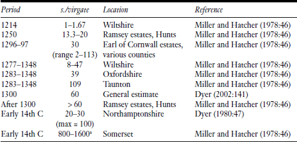

*注：*一处庄园面积为 30 英亩。

*Note:* One virgate is 30 acres.

<sup>a</sup>这些数值非常高。

<sup>a</sup> These are exceptionally high.

**表 2.8**

**TABLE 2.8**

农民土地持有量分布 1280

Distribution of peasant land holding ca. 1280

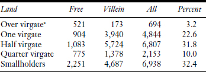

*资料来源：* Kosminsky (1956)。

*Source:* Kosminsky (1956).

<sup>a</sup> 1 virgate = 1 码地 = 30 英亩 = 12 公顷。

<sup>a</sup> One virgate = 1 yardland = 30 acres = 12 ha.

经济历史学家对 1300 年左右的农民预算做出了各种估计（Titow 1961、Hilton 1966、Hollingsworth 1969、Hallam 1988a、Dyer 1989）。这些当局普遍认为，如果真是这样的话，1300 年拥有半块土地的典型农民就勉强维持收支平衡。让我们回顾一下这个计算的要点。

Various estimates of peasant budgets around 1300 have been made by economic historians (Titow 1961, Hilton 1966, Hollingsworth 1969, Hallam 1988a, Dyer 1989). There is a general agreement among these authorities that a typical peasant in 1300 holding a half virgate of land was barely making ends meet, if that. Let us retrace here the main points of this calculation.

**表 2.9**

**TABLE 2.9**

估计农民预算

Estimated peasant budget

| *假设* |  | *计算* |
| --- | --- | --- |
| 生产 |  |  |
| 农作物面积，假设 3 田系统 Crop acreage, assuming 3-field system |  | 10英亩 |
| 每亩播种量 Sowing rate per acre |  | 0.25q |
| 种子总数 Total seed |  | 0.25 夸/英亩 × 10 英亩 = 2.5 夸 |
| 成品率 Yield ratio |  | 1:4 |
| 农作物收获 Crop harvested |  | 10 克 |
| 净额（扣除种子） Net (seed deducted) |  | 10 − 2.5 = 7.5 q |
| 货币生产（1 q = 6 s） Production in money (1 q = 6 s.) |  | 7.5 q × 6 秒/q = 45 秒。 |
| 萃取 |  |  |
| 什一税（收成的 10%） Tithe (10% of harvest) |  | 0.1 × 10 q = 1 q = 6 秒。 |
| 租金（每英亩 1 秒） Rent (1 s. per acre) |  | 1 秒/英亩 × 15 英亩 = 15 秒。 |
| 其他封建苛捐杂税 Other feudal exactions |  | 1 秒。 |
| 税收 Taxes |  | 1 秒。 |
| 死亡义务 Death duties |  |  |
| 赫瑞特（最佳动物） Heriot (best animal) |  | 1 头牛 = 10 秒。 |
| 太平间（另一种动物） Mortuary (another animal) |  | 1 头牛 = 10 秒。 |
| 入场费 Entry fee |  | 40 秒。 |
| 总死亡税 Total death duties |  | 60年代。 |
| 每年相同 same per year |  | 60 秒/20 y = 3 秒。 |
| 总提取量 = (6 + 15 + 1+ 1 + 3) s。 Total extraction = (6 + 15 + 1+ 1 + 3) s. |  | 26 秒。= 4.3 q |
| 农民预算概要 |  |  |
| 总提取量 Total extraction |  | 4.3q |
| 留给农民 Remaining to the peasant |  | 7.5 q − 4.3 q = 3.2 q |
| 最低消费 Minimum consumption |  | 4q |
| 赤字 Deficit |  | 3.2 q − 4 q = − 0.8 q |
| 货币赤字（1 q = 6 s） Deficit in money (1 q = 6 s.) |  | 0.8q×6s。= 5 秒。 |
| 比例 |  |  |
| 总产量（假设 5 秒的缺口以某种方式弥补） Total production (assuming the deficit of 5 s. was somehow made up) |  | 45秒。+ 5 秒。= 50 秒。= 100% |
| 消耗量（占总产量的%） Consumption (% of total production) |  | 24 秒。= 48% |
| 教会什一税（占总产量的%） Church tithes (% of total production) |  | 6秒。= 12% |
| 土地所有者（占总产量的%） Landowner (% of total production) |  | 19 秒。= 38% |
| 状态（占总产量的%） State (% of total production) |  | 1 秒。= 2% |

*注：*假设二分之一的土地所有权 = 15 英亩（6 公顷）。

*Note:* Assumes landholdings of one-half virgate = 15 acres (6 ha).

缩写：q，四分之一小麦（8 蒲式耳 = 64 加仑 = 2.9 百升 = 218 千克）

Abbreviation: q, 1 quarter of wheat (8 bushels = 64 gallons = 2.9 hectaliters = 218 kg)

表 2.9中的计算做出了一些简化假设。例如，农民不仅仅种植小麦，如表 2.9所示。然而，当替换更现实的作物组合时，总体结果非常相似。例如，Dyer (1989:113) 进行了更精心计算，假设农作物分为小麦、大麦、豌豆和燕麦。假设只种植小麦，重复他的计算，我们得到的结果与戴尔的结果相差不到 10%。表2.9农业收入的另一个来源不考虑来自动物的现金收入。Dyer计算出，持有处女座的农民将获得33先令的额外收入。从这个来源。不幸的是，他没有对半个维加特人重复这些详细的计算，但这些拥有更典型土地所有权的农民不太可能从这一来源获得很多收入。他们饲养的动物比完全饲养的维加特人要少得多，而且在考虑到什一税和个人消费后，他们饲养的动物只能产生很少的现金盈余。也许这足以弥补计算出的 5 秒的赤字，或者也许农民不得不依靠花园或家禽为生，而他的妻子（纺纱）或家庭（儿子被雇为农业工人）的额外收入将变成对于履行对主、教会的义务非常重要，和国家。“他如何支付衣服、炊具或家具的费用根本不清楚，”戴尔总结道。这里最后要注意的是，计算表 2.9假设正常条件。即使在农作物歉收的时期，半维加特人也不得不负债才能生存。

The calculation in table 2.9 makes a number of simplifying assumptions. For example, peasants did not grow just wheat, as is assumed in table 2.9. However, the overall result is very similar when a more realistic mix of crops is substituted. For example, Dyer (1989:113) performed a more elaborate calculation, assuming that crops were split among wheat, barley, peas, and oats. Repeating his calculation with the assumption that only wheat was grown, we obtained a result that was less than 10 percent different from Dyer's. Another source of agricultural income that table 2.9 does not take into account is a cash income from animals. Dyer calculated that a peasant holding a virgate would derive additional income of 33 s. from this source. Unfortunately, he did not duplicate these detailed calculations for a half-virgater, but it is unlikely these peasants with more typical land holdings would derive much income from this source. They kept considerably fewer animals than full virgaters, and what they kept would have yielded very little cash surplus after tithes and personal consumption were taken into account. Perhaps it would be enough to cover the calculated deficit of 5 s., or perhaps the peasant had to rely on the garden or poultry, and the extra earnings by his wife (spinning) or family (sons hiring out as agricultural laborers) would become very important in meeting his obligations to the lord, church, and the state. “How he paid for clothing, cooking pots, or furnishings is not at all clear,” concludes Dyer. The final note here is that the calculations in table 2.9 assume normal conditions. During times of even mild crop failure, the half-virgater would have had to go into debt to survive.

这些计算还可以为我们提供至少一个数量级的精英和国家从生产者那里获取资源的估计比例。假设农民能以某种方式弥补5秒的赤字。通过开发非耕资源，预计总生产率将达到 50 秒。每年。其中，教会拿走 12%（这是一个低估的数字，不包括动物和园艺产品的什一税），领主拿走 38%（同样是低估的，因为它不包括劳务；此外，各种封建制度每年 1 秒的勒索可能被低估了），而国家只收取了 2% 的小钱，留给农民的产品还不到一半（勉强够维持基本生活）。

These calculations can also give us at least an order of magnitude of the estimated proportion of resources extracted by the elites and the state from the producers. Assuming that peasants could somehow make up the deficit of 5 s. through exploiting nonarable resources, their estimated total production rate would be 50 s. per year. Of this amount, the church took 12 percent (this is an underestimate that does not include the tithe on animals and garden produce), the lord took 38 percent (again, an underestimate, because it does not include labor services; also, various feudal exactions are probably underestimated at 1 s. per year), and the state took a tiny 2 percent, leaving the peasant less than half the product (and barely enough for basic subsistence).

While typical half-virgaters were balanced on the edge of survival, those few well-to-do peasants who had a virgate did much better. On the basis of his investigation of the manor of Bishop's Cleeve in Gloucerstership in 1299, Dyer (1989:117) concluded that “an average yardlander in a normal year was in a good position to make a cash surplus.” By contrast, a smallholder in order to make ends meet had to find employment for 130 days per year. Since the numbers of such smallholders were very large, it is likely that only a small minority of them would have been able to secure full employment. The contrast between the economic position of different peasant strata can be further illustrated by the fact that around 1300 at Halesowen in Worcestershire, the wealthier peasants had on average 5.1 children, compared to the cottagers’ 1.8 offspring (Dyer 2002:158).

农民预算的计算所强调的一个显着特征是，农民生产的产品只有极少（2%）流向国家。我们估计的税收等于 1 秒。Dyer (2002:258) 遵循每年的计算方法，他计算出，出生于 1270 年并在 1293 年获得 20 英亩土地的农民将发现自己在 1294-97 年每年缴纳直接税，然后在 1301 年至 1301 年之间的另外九年中缴纳直接税。 1322. 他的儿子在 1320 年代中期接替他，将在 1327 年、1332 年、1334 年和 1336 年支付费用，并在 1337-40 年提供三项补贴。总共，两代人将支付 60 秒。四十六年，即 1.3 秒。每年。拥有十五英亩（而不是二十英亩）的半维尔加特可能会支付更少的费用，例如 1 秒。每年。

One remarkable feature highlighted by the calculation of the peasant budget is how little—2 percent—of peasant-generated product went to the state. Our estimate of taxes equaling 1 s. per year follows Dyer (2002:258), who calculated that a peasant born in 1270 and acquiring a holding of twenty acres in 1293 would find himself paying direct taxes in every year in 1294–97 and then in an additional nine years between 1301 and 1322. His son, succeeding him in the mid-1320s, would pay in 1327, 1332, 1334, and 1336, and contribute to three subsidies in 1337–40. In all, the two generations would pay 60 s. over the period of forty-six years, or 1.3 s. per year. A half-virgater holding fifteen (instead of twenty) acres would probably pay a little less, say 1 s. per year.

当然，除了直接影响农民的补贴之外，国家还有其他收入来源。然而，Dyer (2002:257) 估计，1297 年国王的税收仅占国内生产总值的 2%。总而言之，1300年的英国是一个税收非常低的国家，剩余榨取的过程严重向有利于精英的方向倾斜。事实上，上面给出的粗略估计表明，到了 1300 年，精英阶层的榨取已经开始削减最低生活水平，而且这种趋势在 14 世纪的大部分时间里只会变得更糟。

The state, of course, had other sources of revenues than lay subsidies that affected peasants directly. However, Dyer (2002:257) estimated that in 1297 the Crown's taxes amounted to only 2 percent of the estimated gross domestic product. In sum, England of 1300 was a very undertaxed country, and the process of surplus extraction was heavily lopsided in favor of the elites. In fact, the crude estimates given above suggest that by 1300, elite extraction had started cutting into the bare subsistence minimum, and this tendency would only become worse during most of the fourteenth century.

然而，十三世纪后期民众贫困的主要原因不是封建领主的剩余榨取，而是上个世纪人口的大规模增长。此外，人口增长的影响不仅降低了农民与土地的平均比率，而且还导致土地所有权的不平等加剧。三分之一的农村自由所有者拥有一英亩或更少的土地，而另外三分之一拥有一英亩到十英亩之间的土地（Kanzaka 2002：599），没有足够的土地来实现收支平衡。相比之下，10% 的自由所有者非常富裕，拥有四十英亩或更多的土地。

The chief factor underlying popular immiseration in the late thirteenth century, however, was not surplus extraction by the feudal lords but the massive population growth during the preceding century. Furthermore, the effect of population growth was not just that it decreased peasant-toland ratios on average but that it also resulted in growing inequality of landholdings. One-third of rural freeholders held an acre or less of land, while another third held between one and ten acres (Kanzaka 2002:599), not enough land to break even. By contrast, 10 percent of freeholders were very well off, with forty or more acres of land.

## **城市化**

## **Urbanization**

Keene (2001:196) 推测，1100 年伦敦人有 20,000 人，占全国总人口的 0.8%。到 1300 年，伦敦人口已达到 80,000 人，占总人口的 1.3%（Keene 2001：195）。1377 人的人头税表明，1.7% 的英格兰评估人口居住在伦敦（Keene 2001：194），这表明伦敦人略低于 50,000 人。总之，从 1100 年到 1400 年，英格兰的城市化指数（定义为首都总人口的比例）翻了一番。

Keene (2001:196) speculated that in 1100 there were 20,000 Londoners, or 0.8 percent of the total population in the country. By 1300 the population of London had reached 80,000, constituting 1.3 percent of the total (Keene 2001:195). The poll taxes for 1377 indicate that 1.7 percent of the assessed population of England was found in London (Keene 2001:194), suggesting there were slightly under 50,000 Londoners. In summary, between 1100 and 1400 the urbanization index of England (defined as the proportion of the total population found in the capital) doubled.

居住在大城市（10,000 人以上）的人口比例也有所增加。在 11 世纪，这样的城镇只有伦敦一个，而到 13 世纪末，人口在 10,000 或以上的城镇有 14 到 16 个，其中至少占英格兰人口的 5%（Britnell 1995） ：10）。十四世纪城市化进程继续加快。

The proportion of population living in large towns (over 10,000 people) also increased. In the eleventh century there was only one such town, London, while by the end of the thirteenth century there were between fourteen and sixteen towns with a population of 10,000 or more, which contained at least 5 percent of the population of England (Britnell 1995:10). Urbanization continued to increase during the fourteenth century.

**表 2.10**

**TABLE 2.10**

上层社会结构的变化，1150年至1450年：权贵们

Changes in the social structure of the top strata, 1150–1450: Magnates

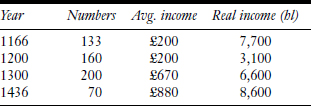

*资料来源：*表 2.3中的数据。

*Source:* Data from Table 2.3.

除了已建城镇的城市人口扩张之外，十二世纪和十三世纪还建立了新城镇。例如，英格兰和威尔士规划建设的城镇在十三世纪下半叶达到了顶峰（Beresford 1967：366）。

In addition to the expansion of urban populations in established towns, new towns were founded during the twelfth and thirteenth centuries. For example, planned towns built in England and Wales reached a peak during the second half of the thirteenth century (Beresford 1967:366).

十四世纪城镇人口比例的增加显然不是因为那里的人口比例高于农村地区。事实上，我们对中世纪城市的了解都表明它们是人口汇聚点（“死亡陷阱”）。大多数英国城镇因鼠疫爆发而遭到重创（Dobson 2001：276），但后来由于来自农村地区的移民而弥补了损失。这一过程的直接证据来自约克自由民登记册中记录的招募新公民的惊人增长（Dobson 2001：276）。尽管遭受黑死病的肆虐，一些城市（例如考文垂）的人口在十四世纪下半叶实际上仍在增长（Phythian-Adams 1979：33）。

The increase in the proportion of population found in towns during the fourteenth century was clearly not a result of better demographic rates there compared to rural locations. In fact, everything we know about medieval cities suggests they were population sinks (“death traps”). Most English towns were decimated by outbreaks of the plague (Dobson 2001:276), but then made up losses as a result of immigration from rural areas. Direct evidence of this process comes from the spectacular increase in the recruitment of new citizens recorded in York's freemen's register (Dobson 2001:276). The population of some cities, such as Coventry, actually expanded during the second half of the fourteenth century despite the ravages of the Black Death (Phythian-Adams 1979:33).

## **精英们**

## **The Elites**

虽然总人口增长在 13 世纪的某个时候放缓，并最终在 1300 年左右达到顶峰，但精英人数在整个滞胀阶段甚至之后（到 1350 年）持续扩大。总的来说，13世纪的精英阶层在经济上表现良好。在顶层，贵族家族的数量仅略有增加，从大约 160 个家庭增加到 200 个家庭，但他们的平均收入从每年 200 英镑增长到 670 英镑，按实际价值计算，增长了两倍多（表 2.10 ）。

While general population growth slowed sometime during the thirteenth century, and eventually reached a peak around 1300, the elite numbers continued to expand throughout the stagflation phase and even beyond it (to 1350). In general, the elites did well economically during the thirteenth century. At the top, the number of magnate families expanded only slightly, from perhaps 160 to 200 families, but their average income grew from £200 to £670 per year, which represents more than a twofold increase in real terms (table 2.10).

中层阶级也参与了这一扩张：在1200年，大约有1,000名束带骑士（每年持有价值至少10英镑土地的大地主），到了1300年，有3,000名骑士和侍从，每年的收入超过20英镑，按实际价值计算，大致相当于 10 英镑兑 1200 英镑（表 2.11）。

The middle ranks also participated in this expansion: whereas there were perhaps 1,000 belted knights (substantial landowners holding land worth at least £10 per year) in 1200, by 1300 there were 3,000 knights and esquires with incomes of more than £20 per year, a rough equivalent in real terms of £10 in 1200 (table 2.11).

**表 2.11**

**TABLE 2.11**

上层社会结构的变化，1150年至1450年：中层阶级和次要精英

Changes in the social structure of the top strata, 1150–1450: Middle ranks and lesser elites

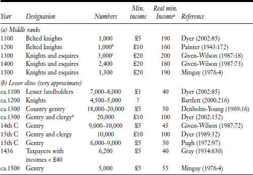

<sup>a</sup>以百升谷物为单位。

<sup>a</sup> In hectoliters of grain.

<sup>b</sup>假设 12 世纪期间束腰带骑士的数量没有太大变化。

<sup>b</sup> Assuming that the numbers of belted knights did not change much during the twelfth century.

<sup>c</sup>其中 1,250 人是骑士。

<sup>c</sup> Of which 1,250 were knights.

<sup>d</sup>每年享受 10-100 英镑的家庭，包括受益的神职人员。

<sup>d</sup> Households enjoying £10–100 per annum, including beneficed clergy.

小土地所有者的数量也在增长，尽管无法给出对这种增长的精确数字估计：吉文-威尔逊估计 14 世纪收入超过 5 英镑的领主数量为 9,000-10,000，而丹霍姆-杨两次提出了这个数字即（表 2.11）。戴尔表示，1300 年有 20,000 个家庭的年收入在 10 英镑到 100 英镑之间。不过，这一估计包括受益的神职人员，同时不包括那些收入在 5 英镑到 10 英镑之间的较小土地所有者。

The numbers of lesser landholders also grew, although a precise numerical estimate of this increase cannot be given: Given-Wilson estimated the numbers of lords with income over £5 at 9,000–10,000 in the fourteenth century, while Denholm-Young proposed a number twice that (table 2.11). Dyer suggests there were 20,000 households that enjoyed incomes between £10 and £100 per year in 1300. This estimate, however, includes beneficed clergy, while excluding those lesser landowners whose incomes were between £5 and £10.

事实可能介于这两个极端之间。总体而言，土地所有者的数量似乎与普通民众的数量保持同步（尽管存在滞后），在这种情况下，土地所有者的数量应该增加两倍，从 12 世纪的 5,000 人左右增加到 14 世纪鼎盛时期的 15,000 人。尸检调查支持了这一解释。在整个 1250 年至 1340 年期间，精英更替率远高于 1。如果地主精英是一个封闭的阶级，其规模只会随着出生和死亡而变化，那么他们的人数将会增加1250 年以后的世纪中，因子为 2.67（见图2.4）。当然，实际上，精英人数也受到社会向上和向下流动的影响。然而，没有证据表明 1250 年之后的大规模向下流动与早期相比，导致大量小贵族在 1200 年左右的社会地位下降（Given-Wilson 1987：16）。区域研究表明，那些节节败退的人只占少数。例如，在牛津郡 31 个家庭的样本中，有 5 个家庭失去了土地，9 个家庭获得了土地，还有 17 个家庭保持大致相同的状况（Dyer 2002：152）。

The truth probably lies between these extremes. In general, it seems likely that the numbers of landholders kept pace with the general populace (although with a lag), in which case they should have tripled from around 5,000 in the twelfth century to 15,000 at their peak in the fourteenth century. Inquisitions post mortem support this interpretation. The elite replacement rate was well above one during the whole period of 1250–1340. If the landed elites were a closed class whose size would change only as a result of births and deaths, then their numbers would have expanded by a factor of 2.67 during the century after 1250 (see figure 2.4). In reality, of course, elite numbers were also affected by upward and downward social mobility. There is no evidence, however, for massive downward mobility after 1250 comparable to that of the earlier period that resulted in substantial numbers of the lesser nobility slipping down the social scale in the years around 1200 (Given-Wilson 1987:16). Regional studies suggest that those losing ground were in the minority. For example, in a sample of thirtyone families from Oxfordshire, five families lost land, nine gained it, and seventeen remained in much the same position (Dyer 2002:152).

非生产阶级的规模由于神职人员的庞大数量而大大膨胀。十三世纪的英国“充斥着神职人员”（Jessopp 1892）。估计有 25,000 名僧侣和尼姑（Moorman 1946：258）。至于教区神职人员的数量，估计范围从 40,000 人（Moorman 1946:53）到人口的 2%（Coulton 1907），这意味着超过 100,000 人的惊人数字。十三世纪的英格兰有 9,000-10,000 个教区 (Moorman 1946:5)，每个教区大约有 5 名任命者 (Moorman 1946:55)。例如，Hilton（1966：62）估计伍斯特教区有 2,000 名任命的神职人员，该教区有 445 个教区。因此，这些数字意味着 1300 年英国世俗神职人员估计为 50,000 人，如果算上僧侣和修女，则为 75,000 人。

The size of the nonproductive class was greatly bloated by the huge numbers of the clergy. England of the thirteenth century was “swarming with clerics” (Jessopp 1892). There were an estimated 25,000 monks and nuns (Moorman 1946:258). As to the numbers of parish clergy, estimates range from 40,000 (Moorman 1946:53) to 2 percent of the population (Coulton 1907), which would imply a staggering figure of over 100,000. There were 9,000–10,000 parishes in thirteenth-century England (Moorman 1946:5) and around five ordained men per parish (Moorman 1946:55). For example, Hilton (1966:62) estimated there were 2,000 ordained clerics in the diocese of Worcester, which had 445 parishes. These numbers thus imply an estimate of 50,000 secular clergy in England in 1300, or 75,000, counting monks and nuns. And this figure does not include the huge “clerical or semi-clerical underworld” (Hilton 1966:62).

精英阶层繁荣的基础是充足的劳动力供应，导致租金上涨和工资下降。结果，精英阶层的土地收入增长与通货膨胀同步，甚至比通货膨胀还要快。Dyer（2002）指出，“领主的主要利益来自于承担沉重劳役和现金支付负担的传统佃户数量的增加。”

The foundations of elite prosperity were provided by the plentiful labor supply, leading to increasing rents and declining wages. As a result, the elite incomes from land kept pace with or even grew faster than inflation. Dyer (2002) suggests that “the main benefit for lords came from additions to the numbers of customary tenants who owed heavy burdens of labor service and cash payments.”

平民和精英的经济福利差距拉大：农民收入因土地匮乏、租金上涨、工资下降而大幅下降，而精英收入无论是绝对收入还是相对收入都在增加。这种趋势也可以从军队工资的动态中看出。精锐士兵（骑士）的工资增长速度快于通货膨胀，而平民（步兵）的实际工资却下降（表2.12）。

The gap between the economic well-being of commoners and elites increased: while the incomes of peasants plummeted as a result of lack of land, increased rents, and decreased wages, the elite incomes increased both in absolute and in relative terms. This trend can also be seen in the dynamics of military wages. The rate of pay for elite soldiers (knights) grew faster than inflation, while the real wages of commoners (foot soldiers) declined (table 2.12).

因此，直到1300年，收入的总体格局是不平等加剧的一种：平民的生活水平下降，士绅的收入普遍超过了通货膨胀，而富豪们的收入最高。在亨利二世统治时期，很少有领主的年收入超过 500 英镑（Bartlett 2000：80）。西德尼·佩因特列出的1200年左右的54位男爵的收入最高的是切斯特警官罗杰·德拉西于1210年去世时享有的800英镑。男爵的最高收入与平均收入之比仅为4:1。一百年后，画家列出的二十七位土地所有者中收入最高的是康沃尔伯爵埃德蒙，他于 1301 年去世时年收入为 3,800 英镑（Painter 1943：174）。考虑到通货膨胀，这意味着实际增长了2.8。兰开斯特伯爵托马斯的土地收入甚至更高：1311 年为 11,000 英镑（Dyer 1989：29）。最高收入与平均收入之比为 16:1，而一百年前为 4:1。六位伯爵（包括康沃尔伯爵）的年收入超过 3,000 英镑（Dyer 1989：29）。中世纪晚期英格兰已知的最大的现金财富是阿伦德尔伯爵理查德的财产，在他 1376 年去世时，他的财产达到了 72,250 英镑（Bean 1991：565）。

The overall pattern in incomes up to 1300, therefore, was one of increasing inequality: the standard of living of commoners declined, gentry incomes generally outpaced inflation, while the magnates did best of all. In Henry II's reign few lords had an income exceeding £500 per year (Bartlett 2000:80). The highest income in Sidney Painter's list of fifty-four barons around 1200 was the £800 enjoyed by Roger de Lacy, constable of Chester, at his death in 1210. The ratio of maximum to average income among the barons was only 4:1. One hundred years later, the largest income in Paint-er's list of twenty-seven landholders was that of Edmund, Earl of Cornwall, who had an annual income of £3,800 at his death in 1301 (Painter 1943:174). Taking inflation into account, this represents an increase of 2.8 in real terms. An even greater landed income was that of Thomas, Earl of Lancaster: £11,000 in 1311 (Dyer 1989:29). The maximum to average income ratio was 16:1, compared to 4:1 one hundred years earlier. Six earls (including the Earl of Cornwall) enjoyed an income of more than £3,000 per annum (Dyer 1989:29). The largest known fortune in cash in late medieval England was that of Richard, Earl of Arundel, which amounted to £72,250 at the time of his death in 1376 (Bean 1991:565).

**表 2.12**

**TABLE 2.12**

英国士兵的每日工资

Daily rates of pay for soldiers in England

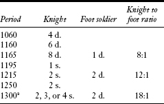

*资料来源：* Harvey (1976:150) 的 1060 和 Contamine (1984:94) 的其余部分。

*Source:* Harvey (1976:150) for 1060 and Contamine (1984:94) for the rest.

<sup>a</sup>速率根据等级而变化：2 秒之间。对于骑士单身汉和 4 s。为骑士旗。

<sup>a</sup> Rates varied according to rank: between 2 s. for a knight-bachelor and 4 s. for a knight-banneret.

解决精英阶层福祉的另一种方法是检查他们的奢侈品消费情况。十四世纪初，葡萄酒消费达到中世纪的顶峰，当时英国从加斯科涅进口了 20,000 吨葡萄酒（Dyer 1989），批发价值 60,000 英镑（Miller and Hatcher 1978:81）。假设当时有20,000个精英家庭，这意味着每户每天需要两到三升酒。

Another way to address the well-being of elites is to examine their consumption of luxuries. Wine consumption reached the medieval peak in the early fourteenth century, when the English imported 20,000 tuns from Gascony (Dyer 1989), worth wholesale £60,000 (Miller and Hatcher 1978:81). Assuming there were 20,000 elite households at that time, this represents two to three liters of wine per household per day.

## 2.4 危机（1315–1400）

## 2.4 Crisis (1315–1400)

## **人口减少**

## **Population Decline**

The economic misery of the commoner population grew steadily during the stagflation phase, reaching a peak in the early fourteenth century. Peasants were squeezed from below by an insufficient land supply resulting from too many people competing for limited land and from above by an expanding (and increasingly rapacious) class of noble landowners eager to maintain the consumption levels to which they had become accustomed during the thirteenth century. There were important regional variations in how the social structure responded to population pressure. In East Anglia, for example, the freeholder stratum (the sokemen) progressively subdivided their land among heirs, which resulted in a proliferation of smallholders with tiny plots of land (Poos 2004). In the south, by contrast, manorial lords exerted a better control over land distribution, so that a substantial minority of peasants held from one-quarter to a whole virgate (between 3 and 12 ha), leaving the surplus population with cottages and garden plots. In both cases, however, most of the population did not have enough land to feed itself and had to rely on additional sources of income. Increasing misery also affected the amount of grain that peasants were able to store. Thus, in Colchester between 1295 and 1301, the median store of wheat per taxpayer slipped below one quarter (Hallam 1988a:822). Peasants were increasingly leading a precarious hand-to-mouth existence, with most having no protection against any fluctuations in the amount of grain brought in as harvest. As a result, a string of very poor harvests in England beginning in 1315 resulted in mortality rates that were nothing short of catastrophic.

Postan 和 Titow 的经典研究（Postan 1973：第 9 章）对五个温彻斯特庄园的赫里奥特报酬的研究让我们得以一睹 1245 年至 1350 年间死亡率的波动情况（当一个佃户死亡并由另一个佃户取代他时，赫里奥特人就会得到报酬）。赫瑞特人的平均数量增加了一倍多，从 13 世纪下半叶的每年 47 人增加到 1310-19 年间的 106 人。但最能说明问题的是一类人的动态，即金钱英雄，由很少或没有牲畜的较贫穷村庄支付，并且暗示很少或根本没有土地（Miller and Hatcher 1978：58）。直到 1290 年，货币赫里奥特的数量每年在 10 个左右波动，然后迅速增长，在 1310-19 年达到近 60 个的峰值，并在黑死病爆发之前的十年中达到另一个峰值（图 2.8 ））。显然，最先遭受匮乏之害的是农村社会的贫困阶层。这一结论的进一步证据来自观察，即高小麦价格与货币英雄数量相关，但与动物英雄数量无关（J. Longden 在 Postan 1973：179-185 中的分析）。

The classic study of Postan and Titow (Postan 1973: Chapter 9) on the heriots paid on five Winchester manors allows us a glimpse into how the mortality rate fluctuated between 1245 and 1350 (heriots were paid when a tenant died and another replaced him). The average number of heriots more than doubled, from 47 per year during the second half of the thirteenth century to 106 during the decade of 1310–19. But most revealing are the dynamics of one category, money heriots, paid by the poorer villages who had few or no beasts, and by implication few or no acres of land (Miller and Hatcher 1978:58). The number of money heriots fluctuated around ten per year until 1290, then grew rapidly to a peak of almost sixty in 1310–19 and another peak in the decade just prior to the Black Death (figure 2.8). It is clear that the first to suffer from the dearth were the poorer segments of the rural society. Further evidence for this conclusion comes from the observation that high wheat prices were correlated with numbers of money heriots but not with animal heriots (the analysis by J. Longden in Postan 1973:179–185).

The period of severe harvest failures and livestock epidemics between 1315 and 1322 was a dividing line in the history of the medieval English countryside (Miller and Hatcher 1978:60). The poor harvest of 1314 was succeeded by two disastrous harvests in 1315 and 1316. Harvests improved after 1317, but a series of deadly epidemics affected cattle herds between 1319 and 1321. The agrarian crisis of 1315–21 resulted in a noticeable decline in the population. Direct evidence of this fall is fragmentary, but the tithing penny data from Essex parishes indicate that between 1300 and 1340 the number of tithingmen declined by 30 percent (Poos 1985). Indirect evidence of the population decline was a significant increase in the number of unwanted holdings, signaling the slackening of competition for land (Miller and Hatcher 1978:59). Wheat prices during the 1330s and 1340s declined to levels not seen since 1270 (see figure 2.2), and the secular trend was definitely down, although with significant fluctuations. By the 1340s the amount of uncultivated land had reached noticeable dimension in some counties, such as Sussex or Cambridgeshire (Miller and Hatcher 1978:61).

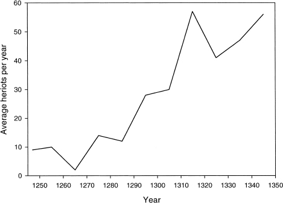

图 2.8 赫瑞特在温彻斯特庄园支付的金钱数量，1245 年至 1348 年。数据来自 Postan（1973 年：表 9.2）。

Figure 2.8 Number of money heriots paid on Winchester manor, 1245–1348. Data from Postan (1973: Table 9.2).

然而，与接下来发生的灾难相比，1315-21 年的灾难很快就显得微不足道了。1348 年，黑死病抵达英格兰，温彻斯特庄园的现金赫鲁特人数量在 1349 年跃升至 675 人（而即使在 14 世纪初最糟糕的几十年里，这一数字也不足 60 人）。全国范围内人口急剧崩溃的证据非常丰富，例如 Hatcher (1977) 中对此进行了回顾。当局普遍认为，这场流行病的第一次冲击带走了 30-40% 的人口，而 1361-62、1369 和 1375 年的余震使人口减少到不到 1300 年峰值的一半。

The disasters of 1315–21, however, soon paled into insignificance compared with what came next. In 1348 the Black Death arrived in England, and the number of cash heriots on Winchester manors jumped to 675 in 1349 (compared with less than 60 even during the worst decades of the early fourteenth century). The evidence of a drastic population collapse countrywide is abundant and is reviewed in, for example, Hatcher (1977). There is a broad agreement among the authorities that the first shock of the epidemic carried away 30–40 percent of the population, and that the aftershocks of 1361–62, 1369, and 1375 depressed the population to a level less than half its 1300 peak.

**表 2.13**

**TABLE 2.13**

鼠疫爆发期间英格兰各社会阶层的死亡率（%）

Mortality rates (%) of various social strata in England during the years of plague outbreaks

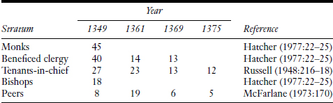

## **黑死病对社会结构的影响**

## **The Effect of the Black Death on Social Structure**

正如我们上面指出的，不同社会阶层的人口比率差异很大。富裕农民的孩子数量是佃农的两到三倍，而且他们的死亡率往往不受农作物歉收的影响。从社会规模上看，我们还发现，虽然英格兰的总人口可能在 1300 年至 1348 年间有所下降，但对土地所有者（主佃农）计算的替代率表明，他们的人数在整个时期继续以健康的速度增长。对本世纪中叶鼠疫流行期间死亡率的了解为社会经济地位对人口死亡率的强烈影响提供了更多证据（表2.13）。

As we noted above, demographic rates varied widely among various social strata. Wealthier peasants had two to three times as many children as cottagers, and their death rates tended not to be affected by crop failures. Moving up the social scale, we also saw that while the general population in England probably declined between 1300 and 1348, replacement rates calculated for landowners (tenants-in-chief) suggest that their numbers continued to expand at a healthy clip throughout this period. What is known about mortality rates during the mid-century plague epidemics provides more evidence for the strong effect of socioeconomic status on demographic rates (table 2.13).

在 1348-49 年第一次也是最严重的疫情爆发期间，僧侣和受祝福的神职人员的死亡率最高。教区牧师尤其令人感兴趣，因为尽管他们吃得更好、住得更好，这往往会降低死亡率，但认真履行职责往往会提高死亡率（Hatcher 1977：23）。因此，他们的死亡率为一般农村人口的死亡率提供了合理的估计。事实上，Hatcher（1977：22）审查的来自庄园记录的大量数据（尽管质量各异）表明，受惠神职人员的死亡率低估了农民的死亡率。

The highest mortality rates during the first and most severe outbreak of 1348–49 were observed among monks and beneficed clergy. Parish priests are of particular interest, because although they were better fed and better housed, which would tend to lower death rates, conscientious performance of their duties would tend to raise them (Hatcher 1977:23). Thus, their death rates provide a reasonable estimate of the death rates among the general rural population. In fact, abundant, although varying in quality, data from manorial records, reviewed by Hatcher (1977:22), suggest that the death rate of beneficed clergy is an underestimate of that of peasants.

如果农民死亡率超过40%，中层精英的死亡率仅为27%，而权贵们的死亡率则更轻，为8%~18%（表2.13 ）。特权群体逃避感染的机会高于平均水平，因为他们住在石屋里（老鼠更喜欢木屋），并且可以逃离不断蔓延的瘟疫（Hatcher 1977：23）。然而，精英们显然在 1361-62 年的下一次流行病中付出了代价。在普通人群中，死亡率远低于 1348-49 年鼠疫首次降临时的死亡率。受益士绅的死亡率再次提供了数值估计（至少对于成年人口；见表2.13）。这最可能的原因是人群中对感染的抵抗力增强（这是1348-49年间清除最易感人群，留下抵抗力更强的人的直接结果）。虽然第一次流行病主要袭击了正值壮年的人（Hatcher 1977：24），但后来的流行病对儿童产生了不成比例的影响。对高层的影响也更大：1361年佃农的死亡率几乎不比1349年低，而同侪的死亡率实际上有所上升（表2.13 ）。

If peasant death rates were over 40 percent, middle-rank elites suffered only 27 percent mortality, while the magnates escaped with even lighter losses of 8–18 percent (table 2.13). The privileged groups had a better than average chance of escaping infection because they lived in stone houses (rats preferred wooden houses) and they could flee the advancing plague (Hatcher 1977:23). However, the elites apparently paid the price during the next epidemic of 1361–62. Among the general population the death rates were much lower than during the first visitation of the plague in 1348–49. A numerical estimate is again provided by the death rates of the beneficed gentry (at least for the adult population; see table 2.13). The most likely reason is the build-up of resistance to infection among the population (which was a direct consequence of the removal of those who were most susceptible in 1348–49, leaving those who were more resistant). While the first epidemic struck mainly at people in the prime of life (Hatcher 1977:24), later epidemics had a disproportionate effect on the children. There was also a disproportionate effect on the higher ranks: the mortality rate of tenants-in-chief was hardly lower in 1361 than in 1349, while the death rates among the peers actually increased (table 2.13).

To summarize the numerical dynamics of the productive and elite strata during the phase of crisis, the numbers of peasants started declining no later than 1315 and plunged in 1348–49, while the numbers of elite expanded until 1348 and declined at a much milder rate between 1348 and 1380. A highly important consequence of these divergent dynamics from the point of view of the demographic-structural theory is that the elite-tocommoner ratio experienced a substantial increase during this period; the social pyramid became top-heavy. This development spelled problems for the elites. Of course, a twofold decrease in the size of the productive stratum did not translate into a twofold decrease in the society's productive capacity, because per capita productivity increased. Pre-1315 England had built up an enormous demand for land. Thus, many landlords were able to immediately rent out the land of tenants who died in the epidemic of the Black Death. However, on the estates of the bishop of Worcester, few new tenants could be found for the larger holdings in 1349–50, and the majority of them remained vacant. Surviving smallholders lacked the necessary animals or equipment or skills to embark on such large ventures (Fryde 1991:747). Subsequent epidemics in 1361, 1369, and 1375 disrupted productive capacity even more. Thus, in 1362–64, grain prices rose more than in 1349–51, and there was a severe famine in 1370 (Fryde 1991:745–46).

1348 年之后人口减少的间接后果对精英收入构成了更严重的威胁。自十三世纪以来，地主们已经习惯了劳动力的大量供应导致高租金、入门罚款和低工资。这种经济影响力在1348年后消失，最终导致精英阶层的人均收入大幅减少。中层阶级和小地主受到的伤害尤其严重，他们依靠私人仆人和雇佣劳动力来耕种大量财产（Fryde 1991：755）。

An even worse threat for the elite incomes was an indirect consequence of the post-1348 depopulation. Since the thirteenth century, landlords had become accustomed to the high supply of labor driving high rents and entry fines and low wages. This economic clout was lost after 1348, and ultimately resulted in a substantial reduction of per capita incomes enjoyed by the elites. Particularly badly hurt were the middle ranks and lesser landowners, who relied on personal servants and hired labor to farm substantial properties (Fryde 1991:755).

精英们如何应对这一威胁？显然，他们立即认识到农民议价能力的增强，并采取措施通过立法将租金和工资固定在1348年之前的通行水平。《劳工条例》得到了大力执行，尽管最终在经济上无效。它因“搭便车问题”而失败：为了每个雇主的利益，限制其他雇主降低工资，以便他可以通过提供稍微低一点的工资来吸引足够的劳动力。更好的工资。由于每个人都有同样的感受，工资限制很快就解除了。典型的做法是，雇主（士绅）不会因提供非法工资而受到起诉，而许多劳工却因接受非法工资而受到惩罚。总的来说，劳动立法是大众仇恨的焦点，它的实施是1381年农民起义的重要原因之一（Fryde 1991：760）。“领主反应”的另一个要素是地主在他们的私人法庭上实施的。黑死病之后，庄园法庭的收入增加了，这是一项了不起的成就，因为佃户数量急剧下降（Dyer 2002：286）。

How did the elites deal with this threat? Apparently, they immediately recognized the enhanced bargaining power of peasants and took steps to legislatively fix the rents and wages at rates prevailing before 1348. The Ordinance of Laborers was vigorously enforced, although ultimately economically ineffective. It foundered on the “free-rider problem”: it was to the benefit of each individual employer that others would be limited to lower wages, so that he could attract sufficient labor by offering a slightly better wage. Since everybody felt the same way, the limits on wages quickly unraveled. Characteristically, the employers (the gentry) were not prosecuted for offering illegal wages, while many laborers were punished for accepting them. The labor legislation, in general, was the focus of much popular hatred, and its enforcement was one of the important causes of the peasant revolts of 1381 (Fryde 1991:760). Another element of the “seigneurial reaction” was implemented by landlords in their private courts. Manorial courts increased their revenues after the Black Death, a remarkable achievement as the numbers of tenants had fallen drastically (Dyer 2002:286).

至少在 1380 年之前，权贵们的表现比中层和小精英要好。大地主雇用了大量的家臣，他们可以而且确实雇用这些家臣来恐吓农民继续接受 1348 年之前盛行的高租金和低工资。在他们的庄园占主导地位的县，他们也有更好的机会找到逃跑的农奴并将他们送回自己的土地，或者惩罚他们作为其他人的榜样。简而言之，他们能够使用超经济强制手段来稳定自己的收入，至少是暂时的。在某些（罕见的）情况下，例如在威尔士边境，领主甚至能够通过加剧农民压迫来增加收入。例如，1320 年至 1380 年间，阿伦德尔家族从北威尔士奇克领主那里获得的收入从 300 英镑增加到 500 英镑。博林布鲁克的亨利利用其父亲冈特的约翰去世后继位的机会，强迫西德韦利人民支付 1,575 英镑（Dyer 2002：292）。这种不可预测和任意的勒索导致了 1400 年格林·杜尔 (Glyn Dwr) 领导的威尔士起义。

The magnates did better than the middle-rank and lesser elites, at least until 1380. The large landowners employed numerous retainers, whom they could and did employ to intimidate peasants to continue to accept the high rents and low wages that prevailed before 1348. In counties where their estates dominated, they also had a much better chance of locating runaway serfs and returning them to their land, or punishing them as an example to others. In short, they were able to use extraeconomic coercive means to stabilize their incomes, at least temporarily. In some (rare) cases, as on the Welsh Marches, lords were even able to increase their incomes by intensifying peasant oppression. For example, the Arundels increased their income from the lordship of Chirk in North Wales from £300 to £500 between 1320 and 1380. Henry the Bolingbroke used the occasion of his succession after the death of his father, John of Gaunt, to force the people of Cydweli to pay £1,575 (Dyer 2002:292). Such unpredictable and arbitrary exactions contributed to the Welsh uprising led by Glyn Dwr in 1400.

总的来说，精英们在将黑死病带来的人口减少的影响推迟了大约一代人方面取得了暂时的成功。工资逐渐上涨，并在第一次流行病爆发后仅二十到三十年就达到了最高水平（Dyer 2002：293）。领主的收入下降了，但下降幅度并不大。贵族们继续享受着他们在1300年左右的世纪中所习惯的高水平支出。另一个有助于精英阶层福祉的因素是英国人在百年战争中取得的初步胜利。这可能就是为什么贸易、工业和城镇在 1348 年之后继续表现良好的原因（Dyer 2002：296）。

In general, the elites enjoyed a temporary success in postponing the effects of the depopulation brought about by the Black Death for about a generation. Wages rose gradually and reached their highest level only twenty to thirty years after the first epidemic (Dyer 2002:293). The incomes of lords declined, but not drastically. The aristocracy continued to enjoy a high level of expenditure to which they had become accustomed during the century around 1300. Another factor contributing to the wellbeing of elites was the initial success of the English in the Hundred Years’ War. This is probably the explanation why the trade, industry, and towns continued to do well after 1348 (Dyer 2002:296).

事实上，英国的城市化程度在十四世纪后期有所提高。1300 年，伦敦人口估计为 80,000 人，占英国总人口的 1.3%。1377年的人头税表明，居住在伦敦的人口比例已增加至1.7%。也就是说，虽然伦敦人口下降到了5万左右，但农村人口下降得更快。几个城镇的规模实际上有所增加：科尔切斯特从 4,000 增加到 6,000，考文垂从 5,000 到 9,000。布里斯托尔、诺里奇、南安普敦和约克等较大的城镇在十四世纪末经历了繁荣阶段（Dyer 2002：296）。由于城镇在鼠疫流行期间深受其害，而且人口普遍呈负增长，因此我们可以得出结论，尽管农村早已不再人口过剩，但在14世纪下半叶，农村人口仍然继续向城镇流动。 。对于这一看似矛盾的事实，最可能的解释是同时存在的推拉关系，其中推动力是领主对农村人口的额外经济压迫，而拉力则是城镇中旨在满足农村人口消费的就业机会增加所产生的。精英个人。

In fact, the degree of urbanization of England increased in the late fourteenth century. In 1300 the population of London was estimated at 80,000, or 1.3 percent of the total English population. The poll taxes of 1377 indicated that the proportion of population living in London had increased to 1.7 percent. In other words, although the population of London declined to about 50,000, the rural population declined even faster. Several towns actually increased in size: Colchester from 4,000 to 6,000 and Coventry from 5,000 to 9,000. Larger towns such as Bristol, Norwich, Southampton, and York experienced a phase of prosperity at the end of the fourteenth century (Dyer 2002:296). Because towns suffered very much during the plague epidemics, and generally had a negative rate of population growth, we must conclude that rural population continued to flow to towns during the second half of the fourteenth century, even though the countryside had long ceased to be overpopulated. The most likely explanation for this seemingly paradoxical fact is the simultaneous push-pull conjuncture, where the push was the increased extraeconomic oppression of the rural population by lords and the pull was exerted by increased employment opportunities in towns aimed at satisfying the consumption of the same elite individuals.

## **危机中的精英**

## **Elites in Crisis**

随着很明显无法从农民身上榨取更多收入，精英们越来越多地寻求其他增加收入的方式。对于贫穷但雄心勃勃的个人来说，晋升的途径之一是加入一位伟大领主的随从，或者在皇家政府中找到工作。对这些精英职位的竞争加剧体现在贵族识字率的提高上。正如 Denholm-Young (1969:2) 所指出的，在 14 世纪，*英里文学*不再是稀有事物。（在 15 世纪，当精英内部竞争减弱时，例如牛津大学的学生人数就会下降 [Thomson 1983:351]。）然而，迄今为止最常见的就业是在军队。

As it became clear that no more revenue could be squeezed out of the peasants, the elites increasingly sought other means of additional income. One avenue of advancement open to impoverished but ambitious individuals was to join the retinue of a great lord, or find employment with the royal government. Increased competition for such elite positions was manifested in the spread of literacy among the aristocracy. As Denholm-Young (1969:2) notes, during the fourteenth century the *miles literatus* ceased to be a rarity. (In the fifteenth century, when intraelite competition slackened, there was a decline in the student population of, for example, Oxford [Thomson 1983:351].) However, by far the most common employment was in the military.

14 世纪期间，贵族参与战争的程度非常显着，特别是在 1338-61 年间，当时英国人在法国取得了一系列的胜利。例如，有超过900名骑士在克雷西和加来服役，而870名骑士（其中不少于680名英国人）参加了1359-60年间对法国的皇家远征，而这只是动员力量的一部分，因为英格兰同时在多个战线上作战（Ormrod 1990：149）。为了正确看待这些数字，Denholm-Young (1969) 估计 13 世纪初英格兰大约有 1,250 名骑士。

The extent of aristocratic involvement in the war during the fourteenth century was remarkable, especially during the period 1338–61, when the English enjoyed a string of successes in France. For example, more than 900 knights served at Crécy and Calais, while 870 (of whom no fewer than 680 were English) participated in the royal expedition to France in 1359–60, and this was only a part of the mobilized forces, since England was fighting on several fronts at the same time (Ormrod 1990:149). To place these numbers in perspective, Denholm-Young (1969) estimated there were around 1,250 knights in England at the beginning of the thirteenth century.

骑士的报酬是2-4秒。每天，取决于等级。因此，考虑到 14 世纪每年大约需要 20 英镑来支持一位骑士，两三个月的竞选活动加起来就是一笔巨款（6-18 英镑）。许多弓箭手可能是从贫困的小士绅队伍中招募的（Powicke 1962）。尽管他们的工资（每天2天）相对较低，但他们可以通过意外之财或赎金来改善自己的命运。除了工资，还有战利品战争的赔偿包括掠夺、被俘虏的法国贵族支付的赎金以及被占领的堡垒和城镇（*rachâts*）支付的赔款。这些现金流量的大小由王室的部分表明：爱德华三世为法国国王约翰和苏格兰国王大卫收到了超过 250,000 英镑的赎金，并且从 rachâts 处收到了类似数额的赎金（Postan 1973：74-75 *）*。最后，征服给他们带来了土地收入。例如，当诺曼底、缅因州和安茹在百年战争后期被征服时，亨利五世授予他的追随者价值约30,000英镑的土地（Bean 1991：566）。

Knights were paid at the rate of 2–4 s. per day, depending on the rank. Thus, two or three months of campaigning would add up to a substantial sum (£6–18), given that about £20 per year was needed to support a knight during the fourteenth century. Many archers were probably recruited from the ranks of impoverished lesser gentry (Powicke 1962). Although their rate of pay (2 d. per day) was relatively low, they could improve their fortunes by a windfall of booty or a ransom. In addition to wages, the spoils of war included plunder, ransoms paid by captured French noblemen, and indemnities paid by occupied fortresses and towns (*rachâts*). The order of magnitude of these cash flows is indicated by the Crown's portion: Edward III received more than £250,000 in ransoms for King John of France and King David of Scotland, and a similar amount from *rachâts* (Postan 1973:74–75). Finally, the conquests brought with them landed income. For example, when Normandy, Maine, and Anjou were conquered during a later stage of the Hundred Years’ War, Henry V conferred lands worth about £30,000 on his followers (Bean 1991:566).

英国中世纪主义者一直在争论百年战争是收回成本还是造成净损失（Postan 1973：63-80）。无论一般答案如何，很明显，对于精英们来说，这是一项非常有利可图的事业，因为回报主要流向了他们，而战争的大部分成本（大部分税收、军需品等）都由他们承担。平民。因此，根据麦克法兰的估计，在 120 年来为战争目的征收的超过 800 万英镑的税收中，有一半来自羊毛税。

English medievalists have debated whether the Hundred Years’ War paid for itself or resulted in a net loss (Postan 1973:63–80). Whatever the general answer, it is clear that for the elites it was a very lucrative enterprise, because the rewards went primarily to them, while most of the costs of the war (the bulk of taxation, purveyances, and so on) were borne by the commoners. Thus, according to the estimate by McFarlane, out of over £8 million in taxes levied for war purposes over the 120 years, half came from taxation on wool.

毫无疑问，只要英国人进展顺利，精英们在战争中表现得很好。1346 年，爱德华三世在克雷西战役和内维尔十字战役（苏格兰人被击败，大卫二世被俘）胜利后返回英格兰时，议会名册记录了“所有人都感谢上帝赐予他们的胜利”。陛下……并说他们给他的所有钱都花得值”（King 1979：157-58）。

There is no question that the elites did very well out of the war, as long as it went well for the English. When Edward III returned to England in 1346, after the victorious battles of Crécy and Neville's Cross (where the Scots were defeated and King David II was captured), the rolls of parliament record that “all thanked God for the victory he had granted to their liege lord…and said that all the money they had given him had been well spent” (King 1979:157–58).

Eventually, however, the respite brought about by military successes in France was over. Anglo-French warfare broke out again in 1369, and during the 1370s the French were able to reconquer most of Aquitaine, leaving in English hands only a narrow strip of coastline between Bordeaux and Bayonne (Ormrod 1990:33). Social tensions had been increasing in the aftermath of the Black Death, and the poll tax of 1381 precipitated a major crisis, the Great Revolt of 1381 (Fryde 1991). Although the peasant revolts were speedily suppressed, they laid an indelible imprint on the landowner psyche. Parliaments became terrified that further taxes might provoke more risings, and for a time they refused to grant any more direct taxes. Thus, the Great Revolt of 1381 proved to be a turning point in the war with France, undermining the ability of the English to profit from the internal turmoil in France during the early years of the minority of Charles VI (Fryde 1996:5). It also accelerated the transition from direct domanial exploitation to the leasing of demesnes, which started in the late 1360s (Fryde 1991:762). During the first half of the fifteenth century, land incomes of the nobility continued to decline in value. Reductions of 20 percent were normal in southern and midland England, whereas in the northeast revenues fell by a third (Dyer 2002:337).

Squeezed by diminishing returns on the land and deprived of opportunities for overseas profits from conquest, the elites put more pressure on the state finances, resulting in a greater proportion of the Crown's income being diverted in their direction. If the annuity bill of Edward III in the 1360s was £13,000, by 1399 Richard II's bill was closer to £25,000 (representing a threefold increase in real terms). However, only a small proportion of the aristocracy could benefit from these funds, small relative to their numbers and appetites. A similar pressure from lesser gentry, coupled with the magnates’ need for large retinues to defend their interests in parliaments, courts, and factional conflict, led to the development of what became known as “bastard feudalism.” Mertes (1988: Appendix C) presents evidence that the average retinue of magnates (peers and bishops) increased from 50 during the first half of the fourteenth century to over 150 during the second half of the fifteenth.

庞大的贵族随从的崛起是精英内部激烈竞争、英格兰统治阶级派系日益加剧以及强制权力私有化的外在表现之一。这是导致后来内战的最重要因素之一，特别是在玫瑰战争期间。

The rise of huge baronial retinues was one of the outward manifestations of intense intraelite competition, the increasing factionalization of England's ruling class, and privatization of coercive power. It was one of the most important factors contributing to later civil wars, particularly during the Wars of the Roses period.

## **国家财政的兴衰**

## **The Rise and Fall of State Finances**

正如我们上面所指出的，十三世纪英国政府对社会提出的要求是温和的。在 1290 年之前，税收实质上保持不变甚至下降，这意味着流入国家的 GDP 比例大幅下降（因为同期 GDP 和人口都大幅增长）。即使在1300年左右的当地高峰期，税收翻倍后，也不到GDP的2%。英国的税收过低，显然可以让其获得更多的收益。然而，我们需要的是一项能够团结王室、贵族和平民的有价值的事业。这个共同的原因是与法国的战争（King 1979：155）。

As we noted above, the demands made by the English state on the society during the thirteenth century were mild. Taxes stayed approximately constant or even declined in real terms before 1290, implying that the proportion of GDP going to the state plunged (since both GDP and population expanded greatly during the same period). Even during the local peak around 1300, after taxes were doubled, they were less than 2 percent of GDP. England was undertaxed and clearly could be made to yield more. What was needed, however, was a worthy cause that would unify the Crown, the aristocracy, and the commoners. This common cause was the war with France (King 1979:155).

在百年战争的早期阶段，王室的收入翻了一番（图2.6）。在 1370 年代和 1380 年代，收入大致保持在同一水平，但由于人口减少了一半，这意味着税收负担又增加了一倍。此外，议会于 1377 年首次批准的新人头税的目的是将税收负担转移给农民（King 1979：163）。

Revenues of the Crown doubled during the early stages of the Hundred Years’ War (figure 2.6). During the 1370s and 1380s, revenues stayed at roughly the same level, but since the population had been reduced by half, this represented another doubling of the tax burden. Additionally, the aim of the new poll taxes, first granted by Parliament in 1377, was to shift the burden of taxation toward the peasantry (King 1979:163).

1369 年至 1380 年间，英国政府的额外支出超过 110 万英镑（Fryde 1991：43）。经过一番政治斗争（1376 年的“好议会”拒绝了国王提出的直接征税请求，而 1377 年的议会则以人头税的新颖形式批准了直接补贴），最终达成了这一决定将以前免税的大部分下层人口纳入税收体系（Dyer 2002：284）。1377年、1379年和1381年对民众征收了前所未有的税收。第一次，14岁以上的每个人都需要缴纳4天，而最后一次则要求缴纳12天。来自 15 岁以上的所有人。

Between 1369 and 1380 the English government incurred extraordinary expenditures amounting to more than £1.1 million (Fryde 1991:43). After some political struggle (the “Good Parliament” of 1376 rejected the Crown's requests for direct taxation, while the parliament of 1377 granted a direct subsidy in the novel form of a poll tax), the decision was reached to bring into the tax system a large segment of lower classes of the population that were previously exempt (Dyer 2002:284). Unprecedented taxes were imposed on the population in 1377, 1379, and 1381. In the first, everybody over age 14 was expected to pay 4 d., while the last demanded 12 d. from everybody over 15.

根据 WM Ormrod 和 Patrick O'Brien 的计算，税收收益（按实际价值计算）最大是在以 1340 年（1336-45 年）为中心的十年间实现的。下个世纪的总体趋势是下降的。然而，这种长期趋势被短期波动所覆盖，其峰值（1300年、1340年、1380年和1420年）与对苏格兰和法国的战争加剧时期密切相关。总体而言，从 1340 年到最低点 1460 年，税收收入几乎下降了三倍。

According to the calculations of W. M. Ormrod and Patrick O'Brien, the maximum yield from taxes (in real terms) was achieved during the decade centered on 1340 (1336–45). The general trend for the next century was down. This secular trend, however, was overlaid by shorter-term fluctuations, whose peaks (in 1300, 1340, 1380, and 1420) closely correlated with periods of intensified warfare against Scotland and France. Overall, between 1340 and the lowest point of 1460, the revenue from taxes declined almost threefold.

## **社会政治不稳定加剧**

## **Rising Sociopolitical Instability**

大众贫困、精英内部冲突和国家财政困难是十四世纪英国社会所经历的社会秩序瓦解的主要因素。然而，13世纪初至14世纪末之间社会政治不稳定的兴起（图2.7）并不是一个简单的单线动态。上升的长期趋势被一系列波浪所覆盖，这些波浪往往每隔一代就会发生一次。十三世纪最重要的动乱时期是 1258 年的危机，导致了 1263-67 年的“贵族战争”（Mortimer 1994：77）。

Popular immiseration, intraelite conflict, and the state's financial difficulties were the primary factors underlying the unraveling of the social order that was experienced by English society during the fourteenth century. However, the rise of sociopolitical instability between the early thirteenth century and the late fourteenth century (figure 2.7) was not a simple, unilineal dynamic. The rising secular trend was overlaid by a series of waves, which tended to occur every other generation. The most significant period of unrest during the thirteenth century was the crisis of 1258, leading into the “barons’ wars” of 1263–67 (Mortimer 1994:77).

下一波内战发生在 1320 年代，即爱德华二世统治的后半期。这场叛乱始于威尔士边境贵族们不成功的叛乱，即巴勒布里奇之战，王室军队赢得了胜利，随后叛乱领导人被处决（1322年）。这些事件之后是莫蒂默和伊莎贝拉的成功叛乱（1326年），爱德华二世的废黜和谋杀（1327年），兰开斯特的亨利领导的叛乱，被莫蒂默镇压（1329年），埃德蒙被处决，肯特伯爵密谋反对政权（1330年），最后由爱德华三世领导的政变推翻莫蒂默和伊莎贝拉政权，随后莫蒂默被处决（1330年）。爱德华二世的弑君标志着精英内部冲突的激烈程度显着上升。

The next wave of internal war occurred in the 1320s, during the last half of Edward II's reign. It began with the unsuccessful rebellion of the barons of the Welsh Marches, the Battle of Boroughbridge, which the royal forces won, followed by the execution of the rebel leaders (1322). These events were followed by a successful rebellion of Mortimer and Isabella (1326), the deposition and murder of Edward II (1327), a rebellion led by Henry of Lancaster, which was put down by Mortimer (1329), the execution of Edmund, Earl of Kent, for plotting against the regime (1330), and finally the coup led by Edward III against the regime of Mortimer and Isabella, followed by the execution of Mortimer (1330). The regicide of Edward II marked a significant elevation in the intensity of intraelite conflict.

The reign of Edward III was relatively free of internal strife (except at its very end), because the focus of elite energy was directed toward the war against France, which initially met with great success. However, by the end of his reign, the French had reconquered most of the lands lost to the English, leading to the chain of events that eventually resulted in the Peasants’ Revolt of 1381. Thus, the reign of Edward III's successor, Richard II (1377–98), was another period of enhanced sociopolitical instability in which strife between elite factions was accompanied by peasant uprisings. Between 1381 and 1405 at least five more popular revolts (in addition to that of 1381) broke out, or were averted only at the last moment. Most of these were regional in extent, with only the Cheshire rising of 1403 evolving into a major civil war (Fryde 1991:797). Serious elite infighting started with the uprising of the “Lords Appellant” in 1387–88, followed by the coup d'état in which Richard II regained control of the government (1391). The civil war reached its peak in 1397–99, when Richard II had three lords appellant convicted of treason and executed. The following year Henry of Bolingbroke deposed Richard II and had himself crowned Henry IV (Richard died or was murdered in prison in 1400). Finally, in 1400 there was a great uprising in Wales led by Glyn Dwr, which lasted eight years.

## **中世纪晚期的犯罪浪潮**

## **The Late Medieval Crime Wave**

十四世纪和十五世纪也是犯罪活动猖獗的时期，即所谓的“中世纪晚期犯罪浪潮”（Dean 2001）。芭芭拉·哈纳瓦特（Barbara Hanawalt，1976，1979）根据对验尸官名单的分析表明，14 世纪英国犯罪模式变化的最佳解释是经济变化和战争。在资源匮乏时期，经济犯罪有所增加。因此，由于大饥荒，1315-19 年期间入室盗窃案数量大幅增加（图 2.9 ）。年度经济犯罪统计数据密切关注小麦价格的波动（见 Hanawalt 1979：图 12）。

The fourteenth and fifteenth centuries were also a period of heightened criminal activity, the so-called “late medieval crime wave” (Dean 2001). Based on her analyses of the coroner's rolls, Barbara Hanawalt (1976, 1979) showed that the best explanations for changes in the pattern of crime in fourteenth-century England were economic changes and war. Economic crimes increased during the periods of scarcity. Thus, the number of burglaries increased enormously during the period of 1315–19 (figure 2.9) as a result of the Great Famine. Annual statistics on economic crimes followed very closely fluctuations in the price of wheat (see Hanawalt 1979: Figure 12).

Homicides tended to be primarily affected by political strife and war. This conclusion is supported by the more detailed analysis of criminal patterns focusing on each county (Hanawalt 1979:229–38). For example, Herefordshire was the scene of some of the major phases of the civil war that led to the deposition of Edward II, and the highest peak in crime in this county was achieved not during the famine of 1315–17 but during a civil war. The periods of Scottish wars (1314–19, 1322–23, and 1332–37) all coincided with rises in crime rates in Yorkshire. “War also contributed to the problems of the nobles’ households and gang activity in general and correlated with increased murder. The Commons were undoubtedly correct in their complaints about the increased horrors of gangs and pardoned felons who were king's veterans” (Hanawalt 1979:238). As a result, homicide rates greatly increased from 1300 to 1348 (figure 2.9). The increased murder rate probably persisted during the second half of the fourteenth century, as suggested by data from rural Northamptonshire (table 2.14). The murder rate of fourteen to eighteen during 1360–79, compared to the average of eleven in 1300–29, implies that the homicide incidence per capita nearly tripled during the fourteenth century, given the post–Black Death population decrease.

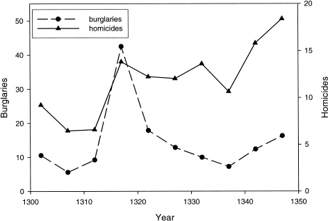

图 2.9 1300 年至 1348 年期间英格兰八个县发生的犯罪（入室盗窃和凶杀）数量（各县和五年期间的平均值）（Hanawalt 1979：表 9 和表 10）。

Figure 2.9 Number of crimes (burglaries and homicides) committed in eight counties of England during 1300–1348 (averages over the counties and five-year periods) (Hanawalt 1979: Tables 9 and 10).

精英内部的冲突有多种形式，从全面的内战到贵族派系之间持续不断的内讧，再到小规模的争斗和个人对个人的暴力。在十四世纪的格洛斯特郡，超过一半的居民骑士和侍从至少犯有一项重罪或非法侵入罪（Saul 1981：174）。

Intraelite conflict took various forms, ranging from full-scale civil war to persistent infighting between noble factions down to small-scale feuding and individual-on-individual violence. In fourteenth century Gloucestershire, more than half the resident knights and esquires committed at least one felony or trespass (Saul 1981:174).

## 2.5 萧条（1400–1485）

## 2.5 Depression (1400–1485)

正如我们在引言中强调的那样，所有时间断点都或多或少是任意的，这尤其适用于 1400 年。那一年并没有发生突然的转变，事实上，内战的爆发仍在继续以循环方式到达。

As we stressed in the introductory chapter, all temporal breakpoints are to a greater or lesser degree arbitrary, and this applies with particular force to the year of 1400. There was no abrupt transition in that year, and in fact, outbreaks of civil war continued to arrive in a recurrent fashion.

## **总人口和农民经济**

## **General Population and Peasant Economy**

十五世纪期间，英格兰的人口数量相对稳定，在 2 至 250 万之间。一些权威人士将人口趋势描述为基本持平（例如，Dyer 2002：图 2），而另一些权威人士则认为，人口在接近 1450 岁时继续下降，尽管下降速度比 14 世纪下半叶要慢得多（Hatcher 和 Bailey） 2001 年：图 3）。由于 1450 年之前平民和土地所有者的替代率往往低于 1，因此第二种观点可能更接近事实。

During the fifteenth century the population numbers in England stayed relatively constant, in the range of 2–2.5 million. Some authorities depict the population trend as essentially flat (e.g., Dyer 2002: Figure 2), while others suggest that the population continued to decline toward 1450, although at a much slower rate than during the second half of the fourteenth century (Hatcher and Bailey 2001: Figure 3). Inasmuch as the replacement rates for both commoners and landowners tended to be below one before 1450, the second view is probably closer to the truth.

|  | **表 2.14** **TABLE 2.14** |  |  |  |
| --- | --- | --- | --- | --- |
|  | 北安普敦郡农村地区每年平均凶杀案数量 Average number of homicides per year in rural Northamptonshire |  |  |  |
|  | *时期* |  | *凶杀案* |  |
|  | 1300–1329 |  | 11 |  |
|  | 1330–39 |  | 13 |  |
|  | 1340–49 |  | 21 |  |
|  | 1350–59 |  | 10 |  |
|  | 1360–69 |  | 18 |  |
|  | 1370–79 |  | 14 |  |
|  | *资料来源：* Hanawalt (1976: 303)。 *Source:* Hanawalt (1976: 303). |  |  |  |

然而，区域差异和人口重新分布可能比全国趋势更重要。人们从农村迁移到城镇，从一个村庄迁移到另一个村庄。1370 年至 1520 年间，英国至少有 2,000 个村庄被遗弃（Dyer 2000:350）。

However, it is likely that regional variation and population redistribution were more important than whatever national trend obtained. People moved from rural areas to towns and from one village to another. Between 1370 and 1520 at least 2,000 villages were deserted in England (Dyer 2000:350).

低人口密度大大提高了生活水平。15 世纪上半叶，实际工资继续增长，但增长速度有所放缓（见图2.3）。农民吃的面包更少，吃的肉、鱼和奶制品更多。例如，1300 年诺福克收割工人消耗的食品价值中，面包约占一半。到了 15 世纪，面包在饮食中的比例下降到总量的 15%。与此同时，肉类的比例从 8% 增加到 30-40% (Dyer 1989:82)。地农比大幅提高。到 1500 年，英格兰八分之一的农村户主拥有 50 英亩或更多土地，而疫情爆发前这一比例很小（Dyer 2002：358）。

Low population densities translated into greatly improved living standards. Real wages continued to increase during the first half of the fifteenth century, although at a slowing rate (see figure 2.3). Peasants ate less bread and more meat, fish, and dairy products. For example, bread accounted for about half the value of foodstuffs consumed by harvest workers in Norfolk in 1300. In the fifteenth century the proportion of bread in diet declined to 15 percent of the total. At the same time, the proportion of meat increased from 8 percent to 30–40 percent (Dyer 1989:82). Land-peasant ratios increased greatly. By 1500, one-eighth of rural householders in England held fifty acres or more, compared with the tiny proportion before the epidemics (Dyer 2002:358).

正如我们在第一章中所指出的，中世纪晚期英国人口历史的最大谜团是，为什么优异的实际工资、消费模式、土地与农民的比率和低租金并没有转化为新的人口增长。到 1400 年，所有这些条件都已具备，但仅一个世纪后人口又恢复增长。出生率较低的一个可能原因可能是晚婚（例如，Dyer 2002：276）。然而这个假设并不真正令人满意，因为它无法解释为什么人口在16世纪恢复增长。1500 年左右发生了什么变化导致人口恢复增长？稍后当我们讨论社会政治不稳定的作用时，我们会回到这个问题。

As we remarked in chapter 1, the great puzzle of late-medieval English demographic history is why excellent real wages, consumption patterns, land-peasant ratios, and low rents did not translate into renewed population growth. All these conditions were in place by 1400, yet population growth resumed only a century later. One possible cause of the lower birth rate could have been late marriage (e.g., Dyer 2002:276). Yet this hypothesis is not really satisfactory, because it does not explain why population growth resumed in the sixteenth century. What changed around 1500 that caused population growth to resume? We return to this question later when we discuss the role of sociopolitical instability.

## **精英动力**

## **Elite Dynamics**

在平民收入和消费水平日益提高的同时，拥有土地的精英阶层的收入却持续下降。Bean (1991:579)指出1420-70年是许多庄园土地收入显着下降的时期（而1470-1500年是复苏年）。不同地区之间存在显着差异：土地价值下降 20% 在英格兰南部和中部地区是正常的。在康沃尔郡，领主失去的土地较少，而在英格兰东北部，收入下降了三分之一（Dyer 2002：337）。

At the same time that the commoners enjoyed increasingly better incomes and consumption levels, the incomes of the landholding elites continued to decline. Bean (1991:579) points to 1420–70 as the period of a marked fall in landed revenue for many estates (while 1470–1500 were years of recovery). There was significant variation between different regions: reductions in land value of 20 percent were normal in southern and midland England. In Cornwall the lords lost less ground, while in northeast England revenues fell by a third (Dyer 2002:337).

贵族收入的下降伴随着消费的减少。前面我们提到，1300年左右，英国人消耗了20,000吨法国葡萄酒。到 1460 年代，进口量不足 5,000 吨，葡萄酒进口直到 1490 年后才恢复（Dyer 1989:104）。

The decline in aristocratic revenues was matched by decreasing consumption. Earlier we mentioned that around 1300, the English consumed 20,000 tuns of French wine. By the 1460s less than 5,000 tuns were imported, and wine imports did not recover until after 1490 (Dyer 1989:104).

综上所述，13世纪贵族阶层整体消费扩大；他们喝了更多的酒，重建了修道院、大教堂和城堡，并用护城河包围了他们的房屋。在十四和十五世纪，他们经历了或多或少的财务困境……。即使是那些确实增加了财产的技术精湛且幸运的家庭，仍然必须面对新获得的资产价值不断贬值的事实。现金收入下降，实际收入因价格剪刀差进一步下降。这个问题在黑死病爆发前二十或三十年就首次出现。在那场灾难之后，贵族感到脆弱，但收入并未大幅下降。最严重的下降发生在1400年以后，最严重的下降到1470年代或1480年代结束。

To sum up, the aristocracy as a whole expanded their consumption in the thirteenth century; they drank more wine, rebuilt their monasteries, cathedrals and castles, and surrounded their houses by moats. In the fourteenth and fifteenth centuries they experienced greater or lesser degrees of financial embarrassment…. Even those skilful and fortunate families who did add to their estates still had to cope with the fact that newly acquired assets were deteriorating in value. Cash incomes declined, and real incomes declined still further because of the operation of price scissors. The problem was first felt in the twenty or thirty years before the Black Death. After that catastrophe the aristocracy felt vulnerable but did not suffer drastic drops in income. The most serious decline came after 1400, and the worst was over by the 1470s or 1480s. (Dyer 1989:108)

土地收入的下降意味着许多贵族家庭无法继续维持自己的地位。结果，向上流动性和向下流动性之间的平衡必须果断地转向后者。这一过程影响了所有级别（表 2.9a-c）。权贵的数量从1300年的约200名男爵减少到1500年的60名贵族。1300年有3000名中级贵族（骑士和侍从），1500年只有1300名。因此，权贵和中级贵族的数量都减少了。精英阶层显然下降了三分之二。很难量化低级别精英数量的下降，但可能是在同一数量级上。

Falling income from land meant that many aristocratic families could not continue to maintain their status. As a result, the balance between upward and downward mobility had to shift decisively in favor of the latter. This process affected all ranks (tables 2.9a–c). The numbers of magnates declined from around 200 barons in 1300 to 60 peers in 1500. There were 3,000 middle-rank aristocrats (knights and esquires) in 1300 and only 1,300 in 1500. Thus, the numbers of both the magnates and the middle-rank elites apparently declined by two-thirds. It is harder to quantify the numerical decline of the lower-rank elites, but it was probably on the same order of magnitude.

精英人数的减少是多个过程共同作用的结果。首先，一些血统因在内战或政变中支持错误的一方而被消灭。这一过程的强度往往以周期性方式波动。例如，在爱德华二世动荡的统治期间任命了十六位新伯爵、侯爵或公爵和理查二世，至少有十四人在其创建后五年内被处决、流放或降职。另一方面，在爱德华三世创造的十三个中，没有一个遭受这种命运（Given-Wilson 1987：54）。其次，许多贵族血统由于收入减少而无法维持地位。因此，贝德福德公爵乔治·内维尔于 1478 年悄然从贵族名单中删除，而伯克利侯爵于 1492 年消失。有些人暂时失去了地位，例如克林顿勋爵，他从 1460 年至 1514 年退出贵族名单（斯通1965：53）。类似的力量推动了中层阶级向下流动到士绅，再从士绅向下流动到自耕农。最后，1350年至1450年之间的负替代率（见图2.4））意味着在这一时期之前或之后，男性谱系中失败的谱系要多得多。他们的财富常常与其他同等级的血统合并，使后者在土地收益下降的情况下仍能维持生计。

The reduction in elite numbers was a result of several processes working together. First, some lineages were extinguished when they backed the wrong side in the civil war or coup d'état. The intensity of this process tended to fluctuate in cyclical fashion. For example, of the sixteen new earls, marquises, or dukes created during the troubled reigns of Edward II and Richard II, at least fourteen were executed, exiled, or demoted within five years of their creation. Of the thirteen created by Edward III, on the other hand, not one suffered that fate (Given-Wilson 1987:54). Second, many noble lineages could not maintain status because of diminishing revenues. Thus, George Neville, Duke of Bedford, was quietly dropped from the list of peers in 1478, while the Marquis of Berkeley disappeared in 1492. Some lost their status temporarily, such as the lords Clinton, who dropped out from 1460 to 1514 (Stone 1965:53). Similar forces drove downward mobility from the middle ranks into gentry and from gentry to yeomanry. Finally, negative replacement rates between 1350 and 1450 (see figure 2.4) meant that many more lineages than before or after this period failed in the male line. Their fortunes were often merged with other lineages of the same rank, keeping the latter afloat in the face of the declining returns from the land.

精英人数的收缩造成了巨大的社会紧张，因为许多特权阶级成员不满足于悄悄地融入自耕农行列。这是导致十五世纪内战的一个重要因素。

The forces contracting elite numbers generated an enormous amount of social tension, because many members of the privileged class were not content to sink quietly into the ranks of yeomen. This was an important factor contributing to the civil wars of the fifteenth century.

破坏政治稳定的另一个因素是与权贵相关的武装随从的增长。诺森伯兰伯爵亨利·珀西 (Henry Percy) 将其 3,000 英镑总收入的三分之一到一半用于支付支持者的费用和年金（Dyer 1989）。聘用人员的年薪在 2 到 10 英镑之间，这对于每年 10 到 20 英镑的收入来说是一个非常受欢迎的补充。

Another factor undermining political stability was the growth of armed retinues associated with magnates. Henry Percy, Earl of Northumberland, was spending a third to a half of his total income of £3,000 on fees and annuities to supporters (Dyer 1989). Retainers were paid between £2 and £10 per annum, which would be a very welcome supplement to an income of £10–20 per annum.

## **国家财政崩溃和内战爆发**

## **State Fiscal Collapse and Onset of the Civil War**

亨利五世的统治时期是另一个内部稳定的时期（除了罗拉德迫害的小事件之外）和对法国的成功战争，类似于爱德华三世的中年。亨利六世的未成年岁月也相对平静。然而，1429年英国人未能占领奥尔良（该城由圣女贞德接替），他们在法国的地位开始瓦解。1442 年，法国人征服了加斯科涅（波尔多和巴约讷除外），而在 1448-51 年期间，英国人几乎被完全驱逐出法国：法国重新征服缅因州（1448 年）、诺曼底（1450 年）以及波尔多和巴约讷（1451 年）百年战争结束时，英国人手中只剩下了加莱。

The reign of Henry V was another period of internal stability (apart from minor incidents of Lollard persecution) and successful warfare against France, similar to the middle years of Edward III. The years of Henry VI's minority were also relatively peaceful. However, in 1429 the English failed to capture Orléans (the city was relieved by Jeanne d'Arc), and their position in France began to unravel. In 1442 the French conquered Gascony (except Bordeaux and Bayonne), and during the years 1448–51 the English were almost completely expelled from France: the French reconquest of Maine (1448), Normandy (1450), and Bordeaux and Bayonne (1451) left only Calais in English hands at the end of the Hundred Years’ War. This string of defeats triggered a series of events that had a remarkable resemblance to what followed English reverses at the end of Edward III's reign.

[output not shown]

到 1433 年，政府陷入了日益严峻的财政困境（Pollard 2000：112）：累积债务为 168,000 英镑，所有税收收入都已投票并在未来两年内支付。仅经常性和国内收支的年度赤字就超过21,000英镑，而保卫法国的领地以对抗复兴的法国人则需要巨额支出。到了 1449 年，情况变得更加糟糕。十五世纪中叶的经济萧条（Hatcher 1996）意味着王室的土地收入下降。经济衰退和与佛兰德斯的贸易禁运使关税和手续费收入减少了一半。此外，在亨利六世的统治下，王室财产不断被转让，其中许多是终身转让。皇家年金花费了英国财政大约 30,000 英镑，占王室收入的近三分之一（Given-Wilson 1987：155）。1445 年，议会勉强投票通过了半额补贴，1447 年则没有通过。1448 年，皇冠上的珠宝不得不出售。1449 年，王室债务总额上升到惊人的 372,000 英镑（Pollard 2000：126）。

By 1433 the government was in increasingly dire fiscal straits (Pollard 2000:112): the accumulated debt was £168,000, and the income from all taxation voted and to be paid in the next two years was assigned. The annual deficit on regular and domestic income and expenditure alone was over £21,000, while the defense of the possessions in France against the resurgent French required huge outlays. By 1449 the situation had become infinitely worse. The economic depression of the mid-fifteenth century (Hatcher 1996) meant that the landed revenue of the Crown had declined. Recession and a trade embargo with Flanders halved the income from customs and poundage. In addition, the reign of Henry VI saw a steady alienation of royal properties, many for terms of life or lives. Royal annuities cost the Exchequer around £30,000, accounting for close to a third of all royal revenues (Given-Wilson 1987:155). Parliament grudgingly voted a half subsidy in 1445 and none in 1447. In 1448 Crown jewels had to be sold. In 1449 the total Crown debt rose to the staggering sum of £372,000 (Pollard 2000:126).

这是国家债务第二次达到不可持续的水平（表2.15）。但一个世纪前的爱德华三世因其在法国的军事胜利而得救。爱德华能够度过金融危机的一个重要因素是约翰二世在普瓦捷被俘的巨额赎金。1450年，法国的军事形势发生了逆转。

This was the second time that the state debt had reached the unsustainable level (table 2.15). But Edward III, a century before, was saved by his military successes in France. Not the least factor in Edward's ability to weather financial crisis was the enormous ransom of John II, who was captured at Poitiers. In 1450 the military situation in France was reversed.

亨利六世间歇性地精神错乱，不适合统治。随着法国所有领地（加莱除外）的灾难性损失，政府失去了最后的合法性，现在它已经支离破碎，甚至无法维持内部秩序。

Henry VI was intermittently insane and unfit to rule. The government lost the last vestiges of legitimacy with the disastrous loss of all French possessions (with the sole exception of Calais), and now it was broke and could not even maintain internal order.

1448 年至 1455 年间，私人争斗、骚乱和武装冲突达到如此严重的程度，以至于至少有六分之一的贵族曾因不光彩的行为而被监禁（Lander 1976：20）。贵族之间的争斗逐渐变成了私人战争，而这些战争又又融入了一般的内战，后来被称为玫瑰战争（Storey 1966）。

Private feuds, riots, and armed clashes reached such proportions between 1448 and 1455 that at least one-sixth of the peerage were at some time or another imprisoned for disreputable conduct (Lander 1976:20). The feuds of nobility gradually became private wars, and those in turn merged into general civil warfare, later called the Wars of the Roses (Storey 1966).

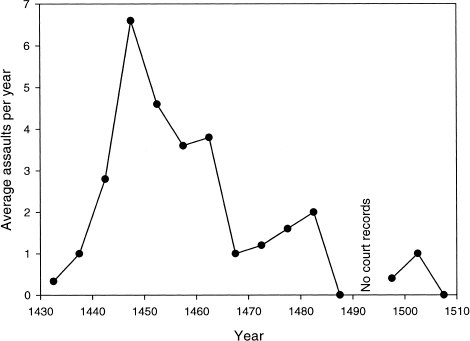

图 2.10 伍斯特郡肯普西每五年发生的平均袭击案件数量（Dyer 1980：371）。

Figure 2.10 Average number of assault cases per five-year interval at Kempsey, Worcestershire (Dyer 1980:371).

以下是从斯托里 (1966) 中挑选出来的 1450 年左右受重大精英争吵影响的县列表（可能不完整）。(1) 西部（康沃尔郡和德文郡，蔓延至萨默塞特郡和威尔特郡）：德文郡伯爵与邦维尔勋爵之间的世仇。德文伯爵曾一度率领一支由 5,000 至 6,000 名随从和盟友组成的私人军队。（2）北部（坎伯兰、威斯特摩兰和约克郡）：内维尔家族和珀西家族的追随者之间持续不断的游击战。(3)贝德福德郡：格雷勋爵和范霍普勋爵的世仇。(4)诺福克和萨福克：萨福克公爵对抗约翰·福尔斯托夫爵士和帕斯顿家族的爪牙。（5）牛津郡和沃里克郡：斯塔福德家族和哈考特家族之间的争吵。(6) 格洛斯特郡：伯克利家族对阵什鲁斯伯里伯爵夫人。(7) 南林肯郡：威廉·泰尔博伊斯爵士的功绩。

Here is a list (probably incomplete) of counties affected by major elite quarrels around 1450, culled from Storey (1966). (1) The west (Cornwall and Devon, spilling into Somerset and Wiltshire): the feud of the Earl of Devon against Lord Bonville. At one point, the Earl of Devon led a private army of 5,000–6,000 retainers and allies. (2) The north (Cumberland, Westmorland, and Yorkshire): persistent guerilla warfare between the adherents of the Nevilles and the Percies. (3) Bedfordshire: the feud of Lords Grey and Fanhope. (4) Norfolk and Suffolk: the minions of the Duke of Suffolk against Sir John Falstoff and the Pastons. (5) Oxfordshire and Warwickshire: the quarrel between the Stafford and Harcourt families. (6) Gloucestershire: the Berkeleys against the Countess of Shrewsbury. (7) Southern Lincolnshire: the exploits of Sir William Tailbois. (8) Derbyshire: the Longfords against the Blounts.

1450年是杰克·凯德领导的一场大规模民众叛乱的一年。事实上，肯特郡的压力十多年来一直在上升：该郡在1438年、1443年、1445年和1448年都曾发生过骚乱。凯德叛乱在英格兰南部广泛蔓延。在威尔特郡，暴民私刑处死了艾斯科夫主教，索尔兹伯里、怀特岛、格洛斯特和埃塞克斯也发生了起义。1450 年晚些时候（8 月至 9 月）苏塞克斯、威尔特郡、埃塞克斯和肯特郡又爆发了另一波起义（Storey 1966）。1451年，杰克·凯德的叛乱最终被镇压。

The year of 1450 was the year of a major popular rebellion led by Jack Cade. In fact, the pressure in Kent had been rising for more than a decade: there were disturbances in that county in 1438, 1443, 1445, and 1448. The Cade rebellion spread widely across southern England. In Wiltshire a mob lynched Bishop Ayscough, and there were risings in Salisbury, Isle of Wight, Glocester, and Essex. Later in 1450 (August–September) there was another wave of risings in Sussex, Wiltshire, Essex, and Kent (Storey 1966). Jack Cade's Revolt was finally suppressed in 1451.

1449 年皇家财政崩溃，随后国家崩溃。1449-50 年议会弹劾了萨福克伯爵（他在试图离开该国时被谋杀）。随后，约克的理查和萨默塞特公爵埃德蒙·博福特之间的权力斗争在 1455 年升级为公开战争。次年，萨默塞特在圣奥尔本斯战役中被击败并阵亡。1459年至1471年间，内战在玛格丽特女王和约克的理查领导的两派之间爆发。约克于 1461 年被杀，但他的儿子爱德华四世于同年加冕。亨利六世被捕并被囚禁在伦敦塔中，并于 1471 年在那里去世（很可能是被谋杀）。

The collapse of royal finances in 1449 was followed by state breakdown. The parliament of 1449–50 impeached the Earl of Suffolk (he was murdered as he tried to leave the country). The ensuing struggle for power between Richard of York and Edmund Beaufort, Duke of Somerset, escalated into open warfare in 1455. The following year Somerset was defeated and killed in the Battle of St. Albans. Between 1459 and 1471 the civil war was fought between the factions led by Queen Margaret and by Richard of York. York was killed in 1461, but his son Edward IV was crowned the same year. Henry VI was captured and imprisoned in the Tower, where he died (most likely was murdered) in 1471.

1471年至1483年是一段平静的时期，但爱德华四世去世后，他的儿子爱德华五世继位，当时年仅12岁。两个精英派系之间爆发了冲突，一个由国王的叔叔里弗斯勋爵领导，另一个由叔叔格洛斯特的理查德领导。理查德获胜，里弗斯和其他一些反理查德领导人未经审判就被处决。爱德华五世被废黜，很可能后来与他的兄弟一起在伦敦塔被谋杀。最终，1485年理查三世本人在博斯沃思原野战役中阵亡，亨利·都铎成为英格兰国王。

The period from 1471 to 1483 was a peaceful lull, but when Edward IV died, he was succeeded by his son, Edward V, who was only twelve years old. Conflict erupted between two elite factions, one led by the king's maternal uncle Lord Rivers and the other by the paternal uncle Richard of Gloucester. Richard won, and Rivers and some other anti-Richard leaders were executed without trial. Edward V was deposed and, in all probability, later murdered in the Tower, along with his brother. Finally, in 1485 Richard III himself fell at the battle of Bosworth Field, and Henry Tudor became king of England.

博斯沃思标志着玫瑰战争的结束，事实上，内战的强度在 1485 年之后迅速下降。1489 年诺森伯兰郡发生起义，1495-97 年觊觎者珀金·沃贝克领导的叛乱，以及 1497 年的叛乱。 1497 年的康沃尔郡。 15 世纪麻烦的最后一次余震是约克郡的一场规模较小的起义，称为恩典朝圣 (1536-37)，此后英格兰将享受一个世纪的内部稳定。

Bosworth marked the end of the Wars of the Roses, and indeed, the intensity of internal warfare rapidly declined after 1485. There was a rising in Northumberland in 1489, a rebellion led by the pretender Perkin Warbeck in 1495–97, and an insurrection in Cornwall in 1497. The last aftershock of the troubles of the fifteenth century was a rather minor uprising in Yorkshire called the Pilgrimage of Grace (1536–37), after which England was to enjoy a century of internal stability.

玫瑰战争期间精英内部的冲突非常激烈。三位国王被废黜和杀害，许多权贵在未经审判的情况下被处决。许多战败方都被直接跪在泥里，当场斩首。然而，它对英格兰人口的直接影响肯定是微不足道的。不太可能有超过 50,000 人（总人口为 2-250 万）参加过内战（Storey 1966）。军事行动只影响到王国的一小部分地区。

The intensity of intraelite conflict during the Wars of the Roses was extremely high. Three kings were deposed and killed, and numerous magnates were executed, often without trial. Many ending on the losing side of a battle were simply made to kneel in the mud and were beheaded on the spot. However, its direct effect on the population of England must have been insignificant. It is unlikely that more than 50,000 (out of the total population of 2–2.5 million) ever took part in the battles of the civil war (Storey 1966). Military operations affected only a small proportion of the kingdom.

另一方面，玫瑰战争中战斗人员的直接损失只是冰山一角。破坏社会结构的并不是王位斗争本身，而是 1445-85 年期间社会政治不稳定的普遍加剧。不稳定表现为人际犯罪、土匪、争斗和派系内斗的增加。大领主的政治斗争它们本身就是这种潜在社会趋势的表现，而不是其直接原因。

On the other hand, the direct losses of combatants in the battles of the Wars of the Roses were just the tip of the iceberg. It was not the struggle for the throne itself that damaged the fabric of the society but the general increase in sociopolitical instability during the period of 1445–85. Instability manifested itself in increased interpersonal crime, banditry, feuding, and factional infighting. The political struggles of the great lords were themselves a manifestation of this underlying social trend rather than its direct cause.

我们认为，1380年至1485年期间（以及这一时期，特别是1380年至1410年和1445年至1485年）的高度社会政治不稳定损害了社会的生产能力（其承载能力）。具体机制是建立“恐惧景观”。最明确的例子是外围地区，这些地区基本上只能自生自灭。在北部，苏格兰人持续不断的袭击导致边疆大片地区人口减少。事实上，北方基本上被国王遗弃给了内维尔家族和珀西家族（他们互相争斗不断，在约克-兰开斯特冲突中站在了对立的一边）。南部沿海地区遭受法国海盗的袭击，许多沿海地区随着人口向内陆迁移而被遗弃。在威尔士，格林·多尔叛乱和随后的重新征服造成了广泛的破坏（Pollard 2000：172）。在较小范围内，由于十三世纪安装的防洪措施失败，东安格利亚因洪水而丧失了土地。所有这些废弃土地都无法用于生产用途。

We argue that high sociopolitical instability during 1380–1485 (and within this period, particularly 1380–1410 and 1445–1485) damaged the productive capacity of the society (its carrying capacity). The specific mechanism was the establishment of a “landscape of fear.” The most clearcut case can be made for the peripheries, which were largely left to fend for themselves. In the north, persistent Scottish raids depopulated large swaths of the Borderlands. In fact, the north was essentially abandoned by the Crown to the Nevilles and Percies (who fought each other incessantly, taking opposite sides in the York-Lancaster conflict). The southern seashore suffered badly from the raids of the French pirates, and many coastal areas were abandoned as the population moved inland. In Wales, the Glyn Dwr rebellion and the following reconquest had caused widespread destruction (Pollard 2000:172). On a smaller scale, land was lost in East Anglia from inundation as a result of failure of flood control measures installed in the thirteenth century. All these abandoned lands could not be put to productive uses.

王国中部的情况虽然不像外围那么严峻，但那里的修士生活也同样岌岌可危。正如上面列出的精英内部冲突清单所表明的那样，十五世纪中叶英国乡村法律和秩序的崩溃是普遍现象，而不是例外。普通民众很容易受到精英内部斗争的影响。许多派别以竞争对手的房客或任何其他陷入冲突的人为目标，进行恐吓、勒索、抢劫和简单的谋杀。例如，埃克塞特主教莱西在他的登记簿中记录，在1451年德文伯爵和邦维尔勋爵之间的私人战争期间，他在克莱斯特（埃克塞特以东）的一些佃户“不敢占领这片土地”（Fryde 1991： 193）。托马斯·珀西、埃格里蒙特勋爵的追随者，即使在1460年的北安普顿战役中身亡后，他仍然继续守卫约克郡的摔跤城堡，以抵御所有来者，并利用它作为袭击和骚扰附近国家的基地（Bohna 2000：94）。当你或你的家属随时可能被抢劫或谋杀，你的工作马被偷，你的房子在你耳边被烧毁时，你就不可能耕种土地。

The situation in the central parts of the kingdom was not as dire as on the periphery, but the life of a cultivator was precarious there as well. As the list of intraelite conflicts, given above, indicates, the breakdown of law and order in the English countryside in the middle of the fifteenth century was the rule rather than the exception. Common people were very vulnerable to intraelite fighting. Many factions targeted the tenants of their rivals, or any others who were caught in the middle of conflict, for intimidation, extortion, robbery, and simple murder. For example, Bishop Lacy of Exeter recorded in his register that, during the private war between the Earl of Devon and Lord Bonville in 1451, some of his tenants at Clyst (east of Exeter) “dared not occupy the land” (Fryde 1991:193). Followers of Thomas Percy, Lord Egremont, even after his death in the battle of Northampton in 1460, continued to hold the castle of Wressle in Yorkshire against all comers, using it as a base for raiding and harrying the country nearby (Bohna 2000:94). It was impossible to cultivate land when you or your dependents could be robbed or murdered at any moment, your work horses stolen, and your house burned down around your ears.

有些地区可能更安全，因为当地精英维持和平；其他人则不然。坚固的地方，例如有城墙的城镇，也在它们周围建立了安全区。恐惧的景观出现了，这意味着一部分耕地无法耕种，从而降低了整体承载能力，即英国土地可以支撑的人口数量。

Some areas were probably more secure because local elites maintained peace; others were less so. Strong places, such as walled towns, also created a zone of security around them. A landscape of fear came into being, which meant that a proportion of arable land could not be cultivated, thus lowering the overall carrying capacity, the number of people that the English soil could support.

十五世纪是人口高度流动的时代。一个简单的解释是，十五世纪的英国男人和女人特别自由。然而，一般来说，人们需要有充分的理由才能放弃他们投入时间和劳动力的地方。在十四世纪，这些原因可能包括地主精英的经济压迫，以及在十五世纪的法律和秩序的崩溃。

The fifteenth century was a time of high population mobility. A facile explanation would be that fifteenth-century Englishmen and women were particularly footloose. Generally, however, people need weighty reasons to abandon places in which they have invested time and labor. In the fourteenth century such reasons could include economic oppression by landed elites, and in the fifteenth century a breakdown of law and order.

我们还知道，许多英国村庄在十五世纪被遗弃。有些可能是被地主“谋杀”的，他们想把它们变成羊牧场。其他的——尤其是较小的——可能会被抛弃，因为它们太不安全了。

We also know that a great number of English villages were abandoned during the fifteenth century. Some were probably “murdered” by landlords who wanted to turn them into sheep pasture. Others—and this applies particularly to the smaller ones—could have been abandoned because they were too insecure.

一些农民工从一个农村地区迁移到另一个农村地区，而另一些则迁移到城镇。我们知道，大多数城镇在此期间继续表现良好。由于前现代城镇是人口下沉，维持人口数量的唯一方法就是不断涌入移民。当都铎政权平定农村时，消除了农村居民向安全的城镇迁移的一个重要理由。结果，在都铎王朝早期，大多数城镇都失去了人口，有些城镇干脆就枯萎了。

Some migrants moved from one rural area to another, while others moved to towns. We know that the majority of towns continued to do well during this period. Since premodern towns were population sinks, the only way in which they could maintain their numbers was through a constant influx of immigrants. When the Tudor regime pacified the countryside, it removed an important reason for rural dwellers to move to the security of towns. As a result, during the early Tudor period most towns lost their population, and some of them simply withered on the vine.

## 2.6 结论

## 2.6 Conclusion

## **人口结构理论的主要预测似乎得到了数据的证实……**

## **The Major Predictions of the Demographic-Structural Theory Appear to Be Borne Out by the Data…**

我们在本章中回顾的大量数据表明，波斯坦和勒罗伊·拉杜里的马尔萨斯-李嘉图理论在解释十四世纪中叶之前英国的人口、经济和社会动态方面非常有效。最引人注目的观察是人口压力与实际工资之间几乎完美的反比关系（相反，人口压力与痛苦指数之间存在非常好的相关性；见图2.1）。顺便说一句，强大的动力学模式，如图2.1中记录的那样，支持这样一种观点，即使用非线性动力学的理论和数据分析方法可以有利地研究历史过程。

The great mass of data that we have reviewed in this chapter suggests that the Malthusian-Ricardian theory of Postan and Le Roy Ladurie works quite well in explaining the demographic, economic, and social dynamics of England up until the mid-fourteenth century. The most striking observation is the almost perfect inverse relationship between population pressure and the real wage (conversely, there is a very good correlation between population pressure and the misery index; see figure 2.1). Incidentally, strong dynamical patterns, such as the one documented in figure 2.1, support the idea that historical processes can be profitably studied using the theoretical and data analytical methods of nonlinear dynamics.

然而，从粗略的马尔萨斯模型的角度来看，“中世纪萧条”——黑死病余震平息后人口增长未能恢复——是一个重大反常现象。我们在本章中指出，理解中世纪萧条需要以精英和国家为中心的人口结构理论视角。1380年至1485年期间阻碍人口增长的关键因素是高度的社会政治不稳定，表现为：法律和秩序经常崩溃。反过来，除非精英的数量和胃口能够与社会的生产能力相一致，否则法律和秩序就无法永久建立。换句话说，只有在精英生产过剩的问题得到某种解决之前，人口增长才能恢复。

The “medieval depression”—a failure of population growth to resume once the aftershocks of the Black Death died out—is, however, a significant anomaly from the point of view of the crude Malthusian model. We have argued in this chapter that what is needed to understand the medieval depression is the elite- and state-centered perspective of the demographicstructural theory. The key factor preventing population growth during the period of 1380–1485 was high sociopolitical instability that manifested as the recurrent breakdown of law and order. In turn, law and order could not be established on a permanent basis until the numbers and appetites of the elites could be brought in line with the productive capacity of the society. In other words, population growth could not resume until the problem of elite overproduction was somehow solved.

由于种种原因，这件事花了异常长的时间才发生。然而，到了 1485 年，14 世纪和 15 世纪的经济困难和内战已将英国统治阶级的规模削减到 14 世纪初的大约三分之一。因此，权贵的数量从大约 200 名男爵减少到大约 60 名普通贵族，中层阶级（骑士和绅士）从 3,000 人减少到 1,300 人，小士绅的数量从大约 15,000 人减少到 5,000 人（见表2.10和2.11） 。

For a variety of reasons, it took an unusually long time for this to happen. By 1485, however, economic hardship and internal warfare during the fourteenth and fifteenth centuries had pruned the size of the English ruling class to roughly one-third of what it was in the early fourteenth century. Thus, the numbers of magnates declined from about 200 barons to some 60 lay peers, the middle ranks (knights and esquires) shrank from 3,000 to 1,300, and the numbers of lesser gentry declined from perhaps 15,000 to 5,000 (see tables 2.10 and 2.11).

## **……但该理论并没有涵盖历史进程的所有复杂性**

## **…But the Theory Does Not Capture All the Complexities of the Historical Process**

在金雀花周期的情况下，我们需要强调两个重要的条件，以对理论与数据之间的契合度进行普遍积极的评估：外生因素的重要性，以及其他内生过程的运作，严格来说，这些过程不属于金雀花周期的一部分。人口结构理论。

We need to stress two important qualifications to our generally positive assessment of the fit between the theory and data in the case of the Plantagenet cycle: the importance of exogenous factors, and the operation of other endogenous processes that are not, strictly speaking, part of the demographic structural theory.

气候的影响是重要的外生因素之一。1315 年之后的寒冷和潮湿的年份显然是人口开始下降的触发因素。遵循中世纪最佳状态的全球变冷可能会降低农作物产量，从而降低中世纪至现代早期农业体系的承载能力。

One important exogenous factor was the influence of climate. The cold and wet years after 1315 apparently served as a trigger for the beginning of population decline. The global cooling following the medieval optimum probably depressed crop yields, and therefore decreased the carrying capacity of the medieval–early modern agrarian system.

1348 年，席卷欧亚大陆的鼠疫大流行席卷英国，造成了更明显重要的外源性冲击。尽管即使没有黑死病，人口也可能继续下降，但可能会下降很多。速度要慢一些，而且不像实际那样深入。

An even more obviously important exogenous shock was administered by the arrival of the Eurasia-wide plague pandemic in England in 1348. Although it is likely that population would have continued to decline even in the absence of the Black Death, it would probably have declined much more slowly and not as deeply as it actually did.

英格兰相对于其邻国苏格兰和法国的地缘政治局势是另一个非常重要的外生因素。正如我们上面所讨论的，正是与法国的交往延长了金雀花王朝周期的瓦解阶段。

The geopolitical situation of England with respect to its neighbors, Scotland and France, is another exogenous factor of great importance. As we argued above, it was the dealings with France that served to lengthen the disintegrative phase of the Plantagenet cycle.

现在转向内生因素，我们注意到标准的人口结构模型预测了持续的社会政治不稳定和统治阶级数量的逐渐衰落。但实际上，不稳定局势会随着波浪的起伏而消退，其间穿插着相对平静的时期。这是许多世俗周期瓦解阶段的普遍现象，被称为“父子”周期（Turchin 2003b，2006）。

Turning now to endogenous factors, we note that standard demographicstructural models predict continuous sociopolitical instability and a gradual numerical decline of the ruling class. Yet in actuality, instability waxes and wanes in waves, interspersed with relatively peaceful periods in between. This is a general occurrence during the disintegrative phases of many secular cycles and has been termed the “fathers-and-sons” cycle (Turchin 2003b, 2006).

就金雀花王朝的英格兰而言，存在三个这样的父子循环，它们以可重复的方式与英格兰地缘政治环境的变化相互作用。每个周期的基本动力是（1）向心阶段，其特征是精英统一、税收增加和对外战争的成功，随后是（2）离心阶段，其特征是国家财政问题、精英内部竞争演变成内战，以及外部征服的损失。

In the case of Plantagenet England, there were three such fathers-andsons cycles, which interacted in a repeatable way with changes in England's geopolitical environment. The essential dynamic of each cycle was (1) a centripetal phase, characterized by unified elites, increased taxation, and success in external wars, followed by (2) a centrifugal phase, characterized by state fiscal problems, intraelite competition shading into civil war, and loss of external conquests.

基本动态是在爱德华一世（1272-1307）和他的儿子爱德华二世（1307-27）统治时期设定的。爱德华一世扭转了皇室收入长达一个世纪的下降趋势（见图2.6），并征服了苏格兰，从苏格兰陷入内战中获利。相比之下，爱德华二世统治下的贵族日益暴躁，收入不断下降。他在班诺克本（1314年）惨败于苏格兰人手中，并失去了苏格兰。最终，他因1320年代的内战而失去了王冠和生命。

The basic dynamic was set during the reigns of Edward I (1272–1307) and his son, Edward II (1307–27). Edward I reversed a century-long decline in Crown revenues (see figure 2.6) and conquered Scotland, profiting from its collapse into civil war. Edward II, in contrast, presided over an increasingly fractious nobility and declining revenues. He experienced a disastrous defeat at the hands of the Scots at Bannockburn (1314) and lost Scotland. Finally, he lost his crown and his life as a result of the civil wars of the 1320s.

爱德华三世 (1327-77) 和理查二世 (1377-99) 在位期间，同样的模式再次出现。爱德华三世统一了精英阶层，取得了中世纪英国历史上最高的税率，征服了半个法国。他的继任者理查二世疏远了大部分贵族（并处决了其中一些人）。在他的统治下，收入下降，议会拒绝投票增加税收，同时还发生了广泛的民众起义。和爱德华二世一样，他也被推翻，后来死在监狱里，可能是被谋杀。

The next iteration of the same pattern came with the reigns of Edward III (1327–77) and Richard II (1377–99). Edward III unified the elites, achieved the highest rate of taxation in medieval English history, and conquered half of France. His successor, Richard II, alienated a major segment of the nobility (and executed some of them). His reign saw declining revenues and the refusal of parliaments to vote more taxes, along with widespread popular uprisings. Like Edward II, he was overthrown and later died, possibly murdered, in prison.

最后一个周期是兰开斯特王朝和约克王朝的结合时期。在亨利五世统治时期和亨利六世幼年时期，英国经历了国家统一、财政相对稳定和成功征服法国的时期。然而，从1430年代开始，它逐渐陷入国家破产、精英内部冲突、法国领土丧失，最后陷入全面内战。1485年玫瑰战争的最后一场战役不仅是父子第三次小周期的结束，也是金雀花王朝英格兰世俗大周期的结束。

The last cycle was the combined Lancastrian and Yorkist period. During the reign of Henry V and the infancy of Henry VI, England experienced a period of national unification, relative fiscal stability, and successful conquest in France. Beginning in the 1430s, however, it gradually slid into state bankruptcy, intraelite conflict, territorial loss in France, and finally all-out civil war. The last battle of the Wars of the Roses in 1485 was not only the end of the third mini-cycle of fathers and sons, it was also the end of the grand secular cycle of Plantagenet England.

## **第3章**

## **Chapter 3**

## 早期现代英国：都铎王朝-斯图亚特王朝周期（1485-1730）

## Early Modern England: The Tudor-Stuart Cycle (1485–1730)

## 3.1 周期概述

## 3.1 Overview of the Cycle

我们以都铎王朝建立的那一年作为周期的开始，标志着长期不稳定时期的结束，而这一不稳定时期最终导致了玫瑰战争。1485 年也是英格兰人口历史转折点的一个很好的候选年，当时中世纪的人口萧条被人口增长的最初迹象所取代。周期的结束更难确定。我们选择 1730 年是因为那是 Wrigley 等人人口负增长的最后一个五年。(1997) 的数据，但另一个可能的终点是 1750 年，因为只有在该日期之后人口才恢复持续增长。世俗周期涵盖都铎王朝、斯图亚特王朝和汉诺威王朝初期。

As the start of the cycle we take the year when the Tudor dynasty was established, marking the end of the long period of instability that culminated in the Wars of the Roses. The year 1485 is also a good candidate for a turning point in the population history of England, when the medieval population depression was succeeded by the first signs of demographic growth. The end of the cycle is harder to pinpoint. We chose 1730 because that was the last quinquennium of negative population growth in Wrigley et al. (1997) data, but another possible endpoint is 1750, since sustained population growth resumed only after that date. The secular cycle encompasses the Tudor, Stuart, and the beginning of the Hanoverian dynasties.

## **人口和经济趋势**

## **Trends in Population and Economy**

马尔萨斯-李嘉图理论中的主要变量不是总人口数，而是人口数与资源的关系，或者人口对资源的压力。人口压力可以通过将实际人口数量除以在给定当前技术的特定地理区域内可以喂养的最大数量来估计。本章末尾的附录计算了英格兰的承载能力作为每英亩农田产量变化的函数，图 3.1b绘制了 1450 年至 1800 年间人口压力的动态。

The main variable in the Malthusian-Ricardian theory is not the total number of people but the number of people in relation to resources, or the population pressure on resources. Population pressure can be estimated by dividing actual population numbers by the maximum number that can be fed within a certain geographic region given current technology. The appendix at the end of this chapter calculates the carrying capacity of England as a function of changing yields per acre of cropland, and figure 3.1b plots the dynamics of population pressure between 1450 and 1800.

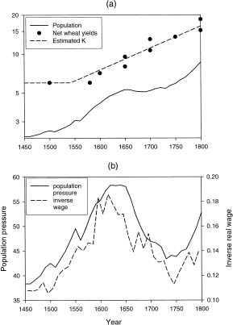

图 3.1 英国人口去趋势化轨迹（Turchin 2005，另见本章末尾的附录）。(a) 1450-1800 年英格兰的人口数量（百万）、净产量（每英亩蒲式耳）和估计承载能力（百万人）（所有变量均以对数刻度绘制）。(b) 去趋势人口（“人口压力”）轨迹（实线）和实际工资倒数（虚线）。

Figure 3.1 Detrending population trajectory for England (Turchin 2005, see also the appendix at the end of this chapter). (a) Population numbers (in millions), net yields (in bushels per acre), and estimated carrying capacity (in millions of people) in England, 1450–1800 (all variables plotted on a log scale). (b) Detrended population (“population pressure”) trajectory (solid line) and inverse real wages (dashed line).

我们看到，在人口数量停滞的同时，由于农田农业生产力的提高，人口压力大幅下降。结果，在 15 世纪末到 18 世纪中叶之间，人口压力而非数量描绘出了典型的世俗周期。为了检查我们的计算，我们还在图 3.1b中绘制了“痛苦指数”（实际工资的倒数） 。两条曲线之间的总体平行性支持了我们估计人口压力的程序。

We see that at the same time that population numbers stagnated, population pressure decreased substantially, owing to increasing agricultural productivity of cropland. As a result, between the late fifteenth century and the mid-eighteenth century, population pressure, but not numbers, traced out a typical secular cycle. To check on our calculations, we also plotted the “misery index” (inverse real wage) in figure 3.1b. The general parallelism between the two curves supports our procedure for estimating the population pressure.

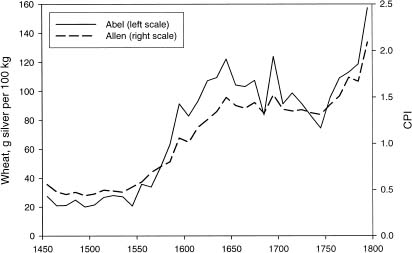

图 3.2 1450-1800 年英国价格动态（十年平均值）。实线：以白银等价物表示的小麦价格（Abel 1980）。虚线：一篮子消费品的 CPI（Allen 1992）。

Figure 3.2 Dynamics of prices (decadal averages) in England, 1450–1800. Solid line: the price of wheat in silver equivalents (Abel 1980). Dashed line: CPI of a basket of consumables (Allen 1992).

这一时期还出现了非常迅速的通货膨胀，即 16 世纪著名的价格革命（图 3.2）。1540 年代至 1600 年间，小麦价格翻了两番，从每公担（100 公斤）含银 20 克增加到超过 80 克。在 1640 年代（以及 1690 年代）达到顶峰时，小麦价格超过每公担 120 克，自 1540 年以来在本世纪内上涨了六倍。

This period also saw a very rapid inflation, the famous price revolution of the sixteenth century (figure 3.2). Between the 1540s and 1600 the price of wheat quadrupled, from 20 to over 80 g of silver per quintal (100 kg). At its peak in the 1640s (and again in the 1690s), the price of wheat exceeded 120 g per quintal—a sixfold increase over the century since 1540.

## **社会结构和精英动态**

## **Social Structure and Elite Dynamics**

现代早期英国社会等级制度的顶端被权贵占据——平庸贵族（男爵、子爵、伯爵和公爵）、精神领主（大主教和主教）、政府高级行政人员和有影响力的宫廷人物。都铎周期期间的同侪数量在不到 60 到 170 之间变化（表 3.1a）。1530 年代修道院解散后，主教人数不足 30 人，且没有修道院院长。宗教改革之后，不仅高级神职人员的数量有所下降，而且他们的社会地位也被认为不如平信徒（Stone 1976：241）。

The apex of the social hierarchy in early modern England was occupied by the magnates—the lay peers (barons, viscounts, earls, and dukes), the spiritual lords (archbishops and bishops), top government administrators, and influential court figures. The number of peers during the Tudor cycle varied between fewer than 60 and 170 (table 3.1a). There were fewer than thirty bishops and no abbots after the dissolution of the monasteries in the 1530s. Not only did the numbers of the higher clergy decline after the reformation, but their social status was considered inferior to that of lay peers (Stone 1976:241).

中层精英主要由县绅——乡绅、骑士和（后来的）男爵组成，人数在 1,300 至 4,400 人之间（表 3.1b）。较小的精英，即“教区绅士”，其数量在 5,000 至 15,000 人之间变化（表 3.1c）。除了地主士绅之外，精英阶层还包括律师级别以上的律师、城市精英（批发商、大型出口商、海关农民和金融家）以及教区神职人员。

The bulk of the middle-rank elites consisted of the county gentry—esquires, knights, and (later) baronets, numbering between 1,300 and 4,400 (table 3.1b). The numbers of the lesser elites, the “parish gentry,” varied between 5,000 and 15,000 (table 3.1c). In addition to the landed gentry, the elite stratum included lawyers above the barrister level, the urban elites (wholesalers, large-scale exporters, customs farmers, and financiers), and the parish clergy.

**表 3.1**

**TABLE 3.1**

都铎-斯图亚特周期精英人数和平均收入

The numbers and average incomes of elites during the Tudor-Stuart cycle

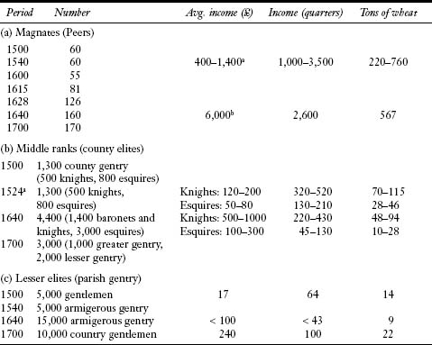

*资料来源：*对于巨头来说，Mingay (1976)。

*Sources:* For magnates, Mingay (1976).

<sup>a</sup> Britnell 的 1524 数据 (1997:191)。

<sup>a</sup> Data for 1524 from Britnell (1997:191).

<sup>b</sup> 1640 年的数据来自 Stone (1965:762)。

<sup>b</sup> Data for 1640 from Stone (1965:762).

对于平民，斯通（Stone，1976：240）描述了三重划分：（1）较小和较大的自耕农、农夫、工匠、店主和小商人；（二）农村、城市、农业、工业等外出务工人员；(3) 学徒和佣人，以及依靠慈善机构生活的人（寡妇、老人和失业者）。

As to commoners, Stone (1976:240) describes a tripartite division: (1) the lesser and the more substantial yeomen, the husbandmen, the artisans, shopkeepers, and small traders; (2) the living-out laborers, both rural and urban, agricultural and industrial; and (3) the apprentices and livingin servants, and those dependent on charity (widows, the aged, and the unemployed).

1540年之前，各级贵族的人数保持不变（表3.1）。然而，从 1540 年到 1640 年，精英人数大约增加了两倍。由于这一时期总人口仅增加了 80%（从 280 万增加到 510 万），英国社会变得更加头重脚轻。1640年之后，中层和次要精英的数量减少了约三分之一，而同侪的数量继续增长，尽管增长速度比1640年之前慢得多。

Before 1540 the numbers of aristocrats of all ranks stayed flat (table 3.1). Between 1540 and 1640, however, elite numbers roughly tripled. Because the general population increased during this period by only 80 percent (from 2.8 million to 5.1 million), English society became significantly more top-heavy. After 1640, the numbers of middle-rank and lesser elites declined by about one-third, while the number of peers continued to grow, although at a much slower rate than before 1640.

The changes affecting lesser clergy were more complex. There were 9,000–10,000 parishes in medieval England (Moorman 1946:5). Toward the end of the Plantagenet cycle, however, a high proportion of parishes did not have a resident curate, or even a parish church. During the disturbed period of 1540–60 there was a sharp decline in the number entering ministry (Stone 1972:80). In the diocese of Canterbury, of 274 documented livings, 107 were without an incumbent in 1560. In the archdeaconry of Oxford the number of rectors, vicars, and curates declined from 371 in 1526 to 270 in 1586 (Stone 1972:80). After 1600, the numbers of local clergy increased very rapidly, and by 1640 there were not enough livings to satisfy the demand. In 1688, Gregory King estimated there were 10,000 clergy in England, an estimate revised to 12,000 by Lindert and Williamson (1982). Thus, the numbers of lesser clergy at least doubled since 1500. But the numbers do not tell the whole story. The quality and status, although not income, of parish clergy rose during the early seventeenth century. “The late medieval parish priest was little more than a semi-literate dirt-farmer of dubious morals: the Caroline minister of a parish had a university degree, strong religious convictions, a comfortable house, some books on his shelves” (Stone 1972:81). In other words, during the seventeenth century employment as a parochial clergyman became a “spillover reservoir” for surplus elites.

## **国家财政**

## **State Finances**

从名义上看，国家收入在整个周期中持续增长，但趋势上似乎略有波动。然而，当小麦价格下跌时，变化模式变得更加复杂（图 3.3）。在第一阶段，直到 1550 年左右，实际收入增加了三倍多。在十六世纪下半叶，趋势发生了逆转，皇家收入的购买力损失了三分之二。这种逆转完全是由于16世纪的物价膨胀造成的。1600 年至 1640 年间，收入在较低水平上波动。有趣的是，由于人口持续增长，大革命前夕的人均税率下降到15世纪末的一半。

In nominal terms the state revenues continued to increase throughout the cycle, with what appear to be minor fluctuations around the trend. When deflated by the price of wheat, however, the pattern of change becomes more complex (figure 3.3). During the first phase until around 1550, real revenues increased more than threefold. During the second half of the sixteenth century, the trend inverted, and the purchasing power of Crown revenues lost two-thirds of its value. This reversal was entirely due to the price inflation of the sixteenth century. Between 1600 and 1640 revenues fluctuated at a low level. Interestingly, because population continued to increase, on the eve of the Great Revolution per capita tax rates declined to half of what they were in the late fifteenth century.

大革命时期出现了第一次激增，随后在复辟时期略有下降。最后，在1700年左右的几十年里，实际收入出现了巨大而持续的增长，最终达到了超越16世纪中叶峰值的水平（图3.3）。

The Revolution saw the first spurt of increase, followed by a slight decline under the Restoration. Finally, there was a great and sustained growth in real revenues in the decades around 1700, which finally took them to levels beyond the mid-sixteenth century peak (figure 3.3).

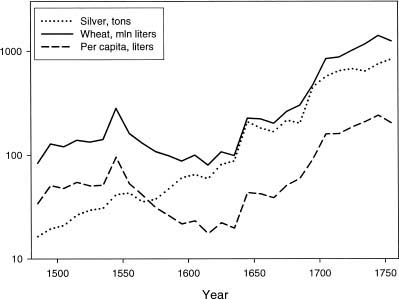

图 3.3 英国国家总收入，1485 年至 1755 年（ESFDB 1995）。虚线：以白银等值表示的收入。实线：以小麦计算的收入。虚线：实际人均收入。

Figure 3.3 Total revenues of the English state, 1485–1755 (ESFDB 1995). Dotted line: revenues expressed in silver equivalent. Solid line: revenues in terms of wheat. Dashed line: real per capita revenues.

## **社会政治稳定**

## **Sociopolitical Stability**

玫瑰战争结束和大革命开始之间的时期相当和平（表3.2）。十六世纪中叶的二十年是一个部分例外，其特点是王朝不稳定、宗教冲突和财政困难，即所谓的都铎中期危机（Jones 1973）。然而，这种不稳定从未升级为全面危机（Matusiak 2005）。1536年至1554年间爆发的一系列叛乱（格雷斯朝圣、康沃尔起义、凯特和怀亚特叛乱）都是区域性的，没有严重威胁中央当局，并很快被镇压（Loades 1999：150-53） , 173, 177–78, 193–95)。

The period between the end of the Wars of the Roses and the onset of the Great Revolution was quite peaceful (table 3.2). A partial exception was the two decades in the mid-sixteenth century, which were characterized by dynastic instability, religious strife, and financial difficulties—the so-called mid-Tudor crisis (Jones 1973). This instability, however, never escalated into a full-blown crisis (Matusiak 2005). A series of rebellions that flared up between 1536 and 1554 (the Pilgrimage of Grace, the Cornwall Rising, Kett's and Wyatt's rebellions) were regional in character, did not seriously threaten the central authorities, and were rapidly suppressed (Loades 1999:150–53, 173, 177–78, 193–95).

相比之下，1640-60 年期间国家全面崩溃，随后爆发了漫长而痛苦的内战。复辟时期有一段相对和平的时期，随后是 1685-92 年的第二个不稳定时期，其中包括暴力推翻政府（表 3.2）。十八世纪非常和平，除了苏格兰的两次詹姆斯党起义，两次起义都被迅速镇压。

The period of 1640–60, by contrast, saw a full-scale state collapse, followed by a lengthy and bitter civil war. There was a relatively peaceful interlude during the Restoration, which was followed by a second period of instability, involving violent overthrow of the government, during 1685–92 (table 3.2). The eighteenth century was very peaceful, apart from two Jacobite risings in Scotland, which were rapidly suppressed.

[output not shown]

1500 年至 1800 年期间的钱币囤积轨迹主要以与大革命相关的高峰为主导（图 3.4）。还存在两个次要峰。其中之一反映了与光荣革命相关的第二个社会政治不稳定时期。另一场发生在十六世纪中叶，可能与英格兰内部不稳定（尽管这一时期包括怀亚特叛乱）关系不大，而与外部事件有关：英格兰-苏格兰王位继承战争和镇压爱尔兰的一场重大叛乱。

The coin hoards’ trajectory during 1500–1800 is dominated by the peak associated with the Great Revolution (figure 3.4). Two secondary peaks are also present. One of them reflects the second period of sociopolitical instability, associated with the Glorious Revolution. Another one, in the mid-sixteenth century, probably has less to do with internal instability in England (although this period includes Wyatt's Rebellion) than with events outside it: the English-Scottish succession war and suppression of a major rebellion in Ireland.

## 3.2 扩张（1485–1580）

## 3.2 Expansion (1485–1580)

## **一般人口和经济**

## **General Population and Economy**

经过长期的停滞后，英格兰人口在 1500 年左右开始增长。一些学者指出 1480 年代是人口开始增加的时期，另一些学者则指出 1510 年代（Hatcher 1977）。当然，到了 1520 年代，人口正在迅速增长（Britnell 1997：246）。我们缺乏 1540 年之前的良好人口数据，但扩张的一个间接迹象是在 1500 年左右的尸检中发现的替代率的跳跃（但这些数据主要告诉我们土地精英发生了什么）。另一个迹象是农民对他们的房屋进行了密集的重建活动，其中新建筑集中在 1440 年至 1520 年期间（Dyer 2002：356）。随后在 1480 年至 1540 年间重建了数千座教区教堂（Hoskins 1976：12）。最后的迹象是 1500-1530 的价格通货膨胀，并伴随着工资的缓慢反应（Britnell 1997：244）。事实上，1500 点似乎是痛苦指数（实际工资倒数）开始持续上升的转折点（图3.1）。

After a long period of stagnation, the population of England began expanding sometime around 1500. Some scholars point to the 1480s as the time when the population started to increase, others to the 1510s (Hatcher 1977). Certainly by the 1520s the population was increasing briskly (Britnell 1997:246). We lack good population data for the period before 1540, but one indirect sign of expansion is the jump in the replacement rates detected in the inquisitions post mortem around 1500 (but these data primarily tell us what was happening with the landed elites). Another sign is the intense rebuilding activity by peasants of their houses, with a concentration of new construction in the period 1440–1520 (Dyer 2002:356). This was followed by a rebuilding of thousands of parish churches between 1480 and 1540 (Hoskins 1976:12). The final indication is the price inflation of 1500–1530, accompanied by a sluggish response of the wages (Britnell 1997:244). In fact, 1500 appears to be the turnaround point when the misery index (inverse real wage) began a sustained ascent (figure 3.1).

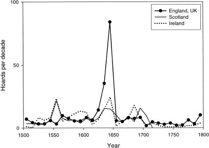

图 3.4 1500-1800 年不列颠群岛每十年的硬币囤积数量（Brown 1971）。粗实线：英格兰（包括威尔士）直到 1707 年，之后是英国（包括苏格兰）。细实线：苏格兰（直到 1707 年）。虚线：爱尔兰。

Figure 3.4 Number of coin hoards per decade in the British Isles, 1500–1800 (Brown 1971). Thick solid line: England (including Wales) until 1707, after that United Kingdom (includes Scotland). Thin solid line: Scotland (until 1707). Dotted line: Ireland.

对 1524 年和 1525 年的外行补贴的分析表明，人口为 230 万（Cornwall 1970），这与 15 世纪估计的最低人数相同。后来的重新评估表明这个数字甚至更低（Campbell 1981），然而，这很难与 1541 年 280 万人的更确切估计相一致。1520 年代至 1540 年代人口从 2.3 增加到 280 万人意味着相对增长每年 1％的增长率，略高于 1540 年之后的增长率（我们有可靠的数据）：反投影表明 1541 年至 1556 年间人口的年增长率为 0.87％（Wrigley 和 Schofield 1981：566）。

An analysis of lay subsidies of 1524 and 1525 suggests a population of 2.3 million people (Cornwall 1970), which is the same as the estimated minimum during the fifteenth century. A later reevaluation suggests an even lower number (Campbell 1981), which is, however, difficult to reconcile with the firmer estimate of 2.8 million people in 1541. A population increase from 2.3 to 2.8 million between the 1520s and the 1540s implies a relative growth rate of 1 percent per year, which is somewhat above the growth rate after 1540 for which we have solid data: the backprojection suggests that the annual rate of population growth between 1541 and 1556 was 0.87 percent (Wrigley and Schofield 1981:566).

人口扩张初期的一个重要方面是伴随着城乡人口平衡的重大转变。从 1400 年到 16 世纪中叶，除伦敦外，所有英国城镇的人口似乎都在减少。例如，尽管遭受了大洪水的破坏，中部地区的主要城镇考文垂在 1348 年至 1450 年间仍设法扩大了人口。黑死病。1440 年，其人口超过 10,000 人，1500 年仅略有减少（8,500-9,000 人）。然而，1520 年人口仅为 7,500 人，到 16 世纪中叶已锐减至 4,000-5,000 人（Phythian-Adams 1979:281）。考文垂并不是一个不寻常的例子。1377 年至 1525 年间，其他失去大约一半人口的城市包括温彻斯特、约克、波士顿、林肯和林恩 (Dyer 2002:300)。莱斯特、诺维奇、布里斯托尔、南安普顿、索尔兹伯里和赫里福德都严重萎缩或经历了严重的经济困难（Phythian-Adams 1979：283-84，Dyer 2002：300）。伦敦的人口是这一模式的唯一例外，在此期间有所增长，但速度慢于总人口。许多城镇根本不再是城镇，要么是因为他们的居民抛弃了他们，要么是因为他们不再拥有城市经济（Dyer 1980：301）。这种趋势在英国西部和北部尤其严重。

One important aspect of the early stages of population expansion was that it was accompanied by a significant shift in the urban-rural population balance. With the exception of London, it appears that all English towns lost population between 1400 and the middle of the sixteenth century. For example, Coventry, the dominant town of the Midlands, managed to expand its population between 1348 and 1450 despite the ravages of the Black Death. In 1440 its population was over 10,000, and in 1500 only slightly less (8,500–9,000). However, in 1520 the population was only 7,500, and by the mid-sixteenth century it had collapsed to 4,000–5,000 (Phythian-Adams 1979:281). Coventry was not an unusual example. Other cities that lost about half their population between 1377 and 1525 were Winchester, York, Boston, Lincoln, and Lynn (Dyer 2002:300). Leicester, Norwich, Bristol, Southampton, Salisbury, and Hereford all shrank severely or experienced serious economic difficulties (Phythian-Adams 1979:283–84, Dyer 2002:300). The population of London, the only exception to this pattern, grew during this period, but slower than the overall population. A number of towns simply stopped being towns, either because their inhabitants deserted them or because they ceased to have an urban economy (Dyer 1980:301). This trend was particularly severe in the west and north of Britain.

非城市化的总体动力与上一个周期滞胀阶段观察到的趋势相反。精英阶层的萎缩加上普通精英家庭消费水平的下降，导致对奢侈品和制成品的需求下降。结果，城镇为来自农村地区的潜在移民提供的就业机会减少了。与此同时，随着都铎政权统治下政治稳定的恢复，农村地区成为更具吸引力的居住地。通过对以前废弃的土地进行内部殖民化，出现了扩大承载能力的新可能性。因此，拉动因素和推动因素共同作用，减少了农民工流入城镇。结果，由于前现代城镇普遍存在的高死亡率和低出生率，城市人口减少。顺便，这种城市和乡村之间人口的重新分配可能有助于解释为什么直接记录人口增长的早期阶段（1480-1540）如此困难。与城市收缩不同，农村重新殖民并不容易察觉（除非使用间接措施，例如农民房屋建设和教区教堂重建）。

The general dynamic underlying deurbanization was the reverse of the trend observed during the stagflation phase of the previous cycle. A shrunken elite stratum coupled with reduced consumption levels by an average elite household translated into a depressed demand for luxuries and manufactures. As a result, towns offered reduced employment opportunities to potential immigrants from rural areas. Meanwhile, rural areas became more attractive places to live as political stability returned under the Tudor regime. There arose new possibilities of expanding the carrying capacity by internal colonization of previously abandoned lands. Thus, both pull and push factors aligned to reduce the inflow of rural migrants to towns. As a result, urban populations shrank because of high mortality and the low birth rates prevailing in premodern towns. Incidentally, this redistribution of population between urban and rural locations may help explain why it is so difficult to directly document the early phase of population increase (1480–1540). Unlike urban shrinking, rural recolonization is not easily detectable (except by using indirect measures, such as peasant house construction and parish church rebuilding).

无论早期人口扩张的时间和节奏如何，到 1541 年，人口总数已达到 280 万（Wrigley 等，1997），比 15 世纪的水平有了大幅增长。得益于剑桥人口与社会结构史小组的出色研究，1540 年后英国的人口轨迹已众所周知。1540年以后，人口增长速度加快，1580年每年增长超过1%。1580年以后，人口继续增长，在1590年代初突破400万大关，但增速有所下降。

Whatever the timing and tempo of the early population expansion, by 1541 the total was 2.8 million (Wrigley et al. 1997), a substantial increase over the fifteenth-century level. Thanks to excellent research by the Cambridge Group for the History of Population and Social Structure, the population trajectory of post-1540 England is well-known. After 1540, population grew at an accelerating rate, which exceeded 1 percent per year in 1580. After 1580 population continued to grow, crossing the 4 million threshold in the early 1590s, but at a declining rate.

十六世纪下半叶人口的快速增长，加上来自新大陆的大量贵金属，将价格推至前所未有的水平。与此同时，名义工资增长速度要慢得多，这对平民的生活水平造成了可怕的后果。

Rapid population growth during the second half of the sixteenth century, combined with torrents of precious metals from the New World, drove prices to unprecedented levels. At the same time, nominal wages increased at a much slower rate, with dire consequences for commoner standards of life.

In the early sixteenth century, before the price revolution, a laborer's wages provided for a standard of life that was modest but well above the starvation level. Assuming that a worker could find employment for 150 days a year and that the daily wage rate was 4 d., Hoskins (1976:113) estimated the annual income of 50 s. (master craftsmen would be paid 50 percent more, since their daily wage was 6 d.). Five quarters of wheat (14.5 hl, a reasonable index of food consumption for a family of five) would cost 30 s., and would take 60 percent of the annual income. Other expenses were much smaller. The typical rent was 5 s. per year. Working-class clothing cost 4 s. per person per year, but it is unlikely that laborers spent that much. Most clothing was probably made at home, and poor people wore others’ cast-offs. A pair of shoes for “poor people” cost a shilling. Where woodland was within easy access, the poor collected wood for fuel. Where woodland was scarce, they burned the dried haulms of peas and beans and even dried cow dung (Hoskins 1976:116), or did not heat their dwellings at all. Life was not easy, but the laborer's wages were sufficient for food and basic shelter. Additionally, the wife and children could supplement the family income, either by working in the textile industry or by seasonal employment in agriculture.

十六世纪，工资增长速度慢于物价增长速度，实际价值大幅下降。例如，英格兰南部的农业工资保持在 4 天不变。每天直到1550，然后增加到8天。到 1580 年代和 1590 年代每天（Thirsk 1967:864）。然而，到 1590 年代，工资率的购买力下降了 50%（Thirsk 1967：865）。

During the sixteenth century wages grew slower than prices, collapsing in real terms. For example, the agricultural wage in southern England stayed constant at 4 d. per day until 1550, and then grew to 8 d. per day by the 1580s and 1590s (Thirsk 1967:864). The purchasing power of the wage rate, however, had declined by 50 percent by the 1590s (Thirsk 1967:865).

土地租金上涨，但最初速度慢于价格，将农业利润的分配从地主转移到佃户（Stone 1972：68）。正如我们下面将要讨论的，在滞胀阶段，租金的增长速度快于价格的增长速度，利润流向发生了逆转。

Land rents rose, but initially slower than prices, shifting the distribution of agricultural profits from the landlord to the tenant (Stone 1972:68). As we shall discuss below, during the stagflation phase rents increased faster than prices, and the direction of the flow of profits was reversed.

## **精英人士**

## **Elites**

直到十六世纪中叶，精英人数的扩张落后于总人口的增长。在整个世纪的大部分时间里，同龄人的数量在 60 人左右波动（Mingay 1976）。骑士人数从 1490 年的 375 名增加到 1560 年的 600 名（Stone 1965:71），仅增加了 60%，而人口却增加了一倍多。

Until the middle of the sixteenth century the expansion of elite numbers lagged behind general population growth. Throughout most of the century, the numbers of peers fluctuated near 60 (Mingay 1976). The numbers of knights increased from 375 in 1490 to 600 in 1560 (Stone 1965:71), an increase of only 60 percent, while the population more than doubled.

十六世纪中叶，诺曼征服之后英国历史上最大规模的土地转让——修道院的解散，精英阶层的命运发生了巨大的变化。Hoskins (1976:121)估计教会的年净收入为 40 万英镑，至少 60其中的百分比转移给了王室。1536-54年间，这片土地的很大一部分（价值110万英镑）被卖给了士绅（Stone 1972：154），为随后精英阶层的扩张奠定了经济基础。

In the mid-sixteenth century the elite fortunes were dramatically changed by the greatest land transfer in the English history after the Norman conquest—the dissolution of monasteries. The net yearly income of the church was estimated by Hoskins (1976:121) as £400,000, at least 60 percent of which passed to the Crown. During 1536–54 a large part of this land (valued at £1.1 million) was sold to the gentry (Stone 1972:154), creating the economic basis for the subsequent expansion of the elite class.

## 3.3 滞胀（1580–1640）

## 3.3 Stagflation (1580–1640)

## **人口与经济**

## **Population and Economy**

The population continued to grow, but at a decelerating rate, reaching 5.3 million during the 1640s (Wrigley et al. 1997). Thus, between 1480 and 1640 the English population more than doubled. “The doubling of the population in the 120 years before the civil war is the critical variable of the period, an event the ramifications of which spread out into every aspect of the society” (Stone 1972:67). Similar statements were also made by other authors (e.g., Russell 1990:1, Kishlansky 1997). One consequence of population growth was a drastic decline in the land-to-peasant ratio. For example, whereas prior to 1560 57 percent of landholdings were one acre or greater in size, after 1620 only 36 percent were in that category. Worse, the numbers of landless peasants drastically increased: the proportion of laborers owning only a cottage with garden or croft increased from 11 percent before 1560 to 40 percent after 1620 (Everitt 1967:402).

总体而言，从 1500 年到 1640 年，谷物价格上涨了近八倍（按名义价值计算；以白银克数计算，上涨了六倍）。为了调查造成这种通货膨胀的因素，Jack Goldstone（1991：表3）拟合了一个简单的回归模型，其中对数转换的人口、收获质量指数和时间（技术变革的虚拟变量）作为数据的自变量。该模型解释了对数转换价格中 99% 的方差，并表明推动通货膨胀的最重要因素是人口增长。

Overall the price of grain rose almost eightfold from 1500 to 1640 (in nominal terms; when expressed in grams of silver, the increase was sixfold). To investigate factors that were responsible for this inflation, Jack Goldstone (1991: Table 3) fitted a simple regression model with logtransformed population, an index of harvest quality, and time (the dummy variable for technical change) as independent variables to the data. The model explained 99 percent of the variance in the log-transformed prices and indicated that the most important factor driving inflation was population growth.

从美洲大规模进口金条导致货币供应量的扩大也促成了 16 世纪的价格革命。然而，即使在影响最大的西班牙，持续的通货膨胀也从 1540 年开始——在大量贵金属开始从新大陆运抵之前——并持续到 1620 年之后，尽管金条进口量下降（Fischer 1996：图 2.09） 。表明通货膨胀背后主要推动力是人口增长的另一条线索是食品和燃料与制成品价格上涨之间的差异（表3.3）。谷物价格上涨了近八倍，而制成品价格仅上涨了三倍。

Expansion of the money supply as a result of the large-scale importation of bullion from the Americas also contributed to the price revolution of the sixteenth century. However, even in Spain, where the effect should be the greatest, sustained inflation started in 1540—before any substantial amounts of precious metals started arriving from the New World—and continued after 1620, despite declining bullion imports (Fischer 1996: Figure 2.09). Another clue suggesting that the primary mover behind inflation was population growth is the disparity between price increases of food and fuel versus manufactures (table 3.3). Whereas the price of grain increased almost eightfold, the price of manufactures increased only by a factor of three.

**表 3.3**

**TABLE 3.3**

食品和燃料（谷物、牲畜和木材）与制成品价格的相对上涨

Relative increases in prices of food and fuel (grain, livestock, and wood) versus manufactures

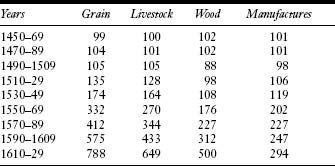

*资料来源：* Fischer (1996:74)。

*Source:* Fischer (1996:74).

另一个表明价格通胀主要由人口增长驱动的指标是实际工资，在 1500 年至 1640 年间实际工资下降了 40% 以上（Allen 2001）。土地租金也加速上涨（表3.4）。在 16 世纪，租金随价格上涨，但 1580 年之后，租金迅速超过了通货膨胀。结果，实际租金在扩张阶段停滞不前，因此地主增加收入的唯一途径就是获得更多土地。相比之下，在滞胀阶段，实际租金增长迅速，房东的收入大幅增加。例如，沃里克郡贵族的平均生活水平在 1530 年代至 1630 年代提高了近 400%（Stone 1972：74）。

Another indicator suggesting that price inflation was driven primarily by population growth is real wages, which declined by more than 40 percent between 1500 and 1640 (Allen 2001). Land rents also increased at an accelerating rate (table 3.4). During the sixteenth century rents increased in line with prices, but after 1580 rents rapidly outpaced inflation. As a result, real rents stagnated during the expansion phase, so that the only way for landlords to increase their revenues was to get more land. During the stagflation phase, by contrast, real rents grew rapidly, and the landlords enjoyed a substantial increase in their incomes. For example, the standard of living of the average gentry in Warwickshire increased by nearly 400 percent between the 1530s and 1630s (Stone 1972:74).

## **城市化与贸易**

## **Urbanization and Trade**

十六世纪期间，伦敦人口的增长基本上与英格兰总人口的增长保持同步。结果，伦敦人口占总人口的 2% 到 3%。然而，1600年后，伦敦的规模迅速扩大，居住着总人口的10%以上。十八世纪下半叶和十九世纪初，伦敦人口的增长再次落后于全国的增长（1830年伦敦人口占总人口的9%）。换句话说，城市化呈现出典型的长期动态，城市化高峰大大滞后于人口高峰。城市化以但不限于伦敦为主导。例如，1603 年至 1670 年间，东安格利亚的城市人口增长了 50%，而该地区的总人口仅增长了 11%。最大的城镇增长最快：诺尔哪些城镇在 17 世纪从 12,000 增加到 30,000 (Clay 1984a:20)。

During the sixteenth century the growth of the London population largely kept pace with the total population of England. As a result, London had between 2 and 3 percent of the total population. After 1600, however, the size of London mushroomed to the point where over 10 percent of the total population resided in it. During the second half of the eighteenth century and the early nineteenth century the growth of London's population again lagged behind that of the country (in 1830 London had 9 percent of the total population). In other words, urbanization exhibited the typical secular dynamics, with the peak of urbanization lagging substantially behind the population peak. Urbanization was dominated by, but not limited to, London. For example, between 1603 and 1670 the urban population of East Anglia grew by 50 percent, while the total population of the area rose by only 11 percent. The largest towns grew fastest: Norwhich increased from 12,000 to 30,000 during the seventeenth century (Clay 1984a:20).

**表 3.4**

**TABLE 3.4**

租金

Rents

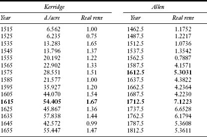

*资料来源：*数据来自 Kerridge (1953) 和 Allen (1992)。

*Source:* Data from Kerridge (1953) and Allen (1992).

*注：*实际租金峰值以粗体显示。

*Note:* Peaks in real rents are in boldface.

贸易和工业的动态与城市化的动态平行。伦敦拥有的航运量从 1582 年的 12,300 吨增加到 1629 年的 35,300 吨，到 1686 年增加到约 150,000 吨（Clay 1984a:202）。1622 年至 1700 年间，伦敦进口食品和原材料的价值从 100 万英镑增加到 300 万英镑（Clay 1984b）。工业的增长可以用铁产量的一些数据来说明。1500 年，这一数字仅为每年 140 吨，但到了 1600 年，这一数字已增至每年 10,000 吨。1660 年，家庭铁总产量上升至 20,000 吨。

The dynamics of trade and industry paralleled those of urbanization. Shipping owned in London rose from 12,300 tons in 1582 to 35,300 tons in 1629, and to about 150,000 tons by 1686 (Clay 1984a:202). Between 1622 and 1700 the value of imports of food and raw materials to London increased from £1 million to £3 million (Clay 1984b). The growth of industry can be illustrated with some numbers on iron production. In 1500 this was a mere 140 tons per year, but by 1600 it had grown to 10,000 tons per year. In 1660 total home iron production rose to 20,000 tons.

## **精英人士**

## **Elites**

1540年至1640年间，各个精英阶层的人数增长速度远远快于普通人口的增长速度（见表3.1）。尽管人口增长了 80%（从 2.8 万人增加到 510 万人），但精英人数却增加了两倍（从 6,300 个贵族家庭增加到 18,500 个贵族家庭）。贵族人数的急剧增加影响到了所有精英阶层：贵族人数从60人增加到160人，从男爵和骑士人数从500人增加到1400人，侍从人数从800人增加到3000人，武装士绅的数量增加从 5,000 到 15,000（Stone 1972：72）。

Between 1540 and 1640 the numbers of the various elite strata expanded much faster than the general population did (see table 3.1). Whereas the population grew by 80 percent (from 2.8 to 5.1 million), the elite numbers tripled (from 6,300 to 18,500 aristocratic families). The radical increase in aristocratic numbers affected all elite strata: the number of peers increased from 60 to 160, the number of baronets and knights increased from 500 to 1400, the number of esquires increased from 800 to 3,000, and the number of armigerous gentry increased from 5,000 to 15,000 (Stone 1972:72).

随着士绅数量的增加，他们对地方和中央政府的参与也随之增加。例如，四个样本县（肯特郡、诺福克郡、沃里克郡和约克郡北区）被任命为太平绅士的人数从 15 世纪末的 60 人增加到 1562 年的 96 人，1636 年的 166 人，1636 年的 396 人。 1702 (Heal and Holmes 1994:167)——增加了 6.6 倍。下议院的成员资格议员人数从 300 人增加到 500 人，而其中的士绅成分则从 50% 上升到 75%（Stone 1972：92），这意味着士绅议员的数量增加了 2.5 倍。

As the numbers of the gentry grew, so did their involvement in the local and central government. For example, the number of men appointed justices of the peace in four sample counties (Kent, Norfolk, Warwickshire, and the North Riding of Yorkshire) increased from 60 in the late fifteenth century to 96 in 1562, 166 in 1636, and 396 in 1702 (Heal and Holmes 1994:167)—a 6.6-fold increase. The membership of the House of Commons grew from 300 to 500, while the gentry component in it rose from 50 percent to 75 percent (Stone 1972:92), implying a 2.5-fold increase in the number of gentry MPs.

地主精英的扩张伴随着职业的兴起。律师、医生和其他医学从业者以及秘书/行政助理的数量呈现出持续而显着的增长，一般在 1640 年达到顶峰（Stone 1976：34）。例如，1578 年至 1633 年间，普通法院注册的律师人数从 342 人增加到 1,383 人。神职人员的数量也有所增加，从 1560 年开始，到 1640 年达到顶峰（Stone 1976：34）。

The expansion of the landed elites was accompanied by a rise of professions. The numbers of lawyers, doctors and other practitioners of medicine, and secretarial/administrative assistants showed a sustained and striking increase, generally peaking in 1640 (Stone 1976:34). For example, the number of attorneys enrolled in the Court of Common Pleas rose between 1578 and 1633 from 342 to 1,383. The numbers of the clergy also increased, starting in 1560 and reaching a peak in 1640 (Stone 1976:34).

士绅兴起的原因是众所周知的。在第一阶段，大约是 1540-60 年，士绅们从教会财产的大规模土地转让中获利。第二阶段，即1580年以后，士绅们受益于实际租金的上涨。此外，随着皇家财政状况恶化，它被迫出售更多土地。1589 年至 1635 年间出售的皇家土地价值为 210 万英镑（Stone 1972：154），其中大部分最终落入士绅手中。

The causal factors underlying the rise of the gentry are well understood. In the first phase, roughly 1540–60, the gentry profited from the massive land transfer of church property. In the second phase, after 1580, the gentry benefited from rising real rents. Additionally, as the Crown's finances worsened, it was forced to sell more land. The value of the Crown lands sold between 1589 and 1635 was £2.1 million (Stone 1972:154), and most of it ended up in the hands of the gentry.

士绅的崛起伴随着炫耀性消费的不断增加，以及不平等程度的加剧：

The rise of the gentry was accompanied by ever increasing levels of conspicuous consumption, as well as by increasing degree of inequality:

1485 年，大多数英国人，即使是富裕的人，也穿着类似的衣服。女性穿着朴素、宽松的衣服，男性也是如此。精致而简单的亚麻布在正式服装中与华丽的丝绸一样可以接受...... 然而，十六世纪三四十年代，昂贵华丽服装的消费出现了爆炸性增长。需求大幅增长，尤其是富人，他们购买昂贵的锦缎、天鹅绒和丝绸来制作新的华丽服装……。在伊丽莎白统治时期，人们彻底改变了他们的时尚。他们的衣服变得更加精致和独特……。女性则用装饰精美的法丁加勒和精美的锦缎礼服来搭配男性服装……。十六世纪以“奢侈的疯狂狂欢”结束，外省士绅试图效仿伦敦的*上流社会*穿着奢华的服装，戴着十二英寸冠的帽子。（伯杰 1993：20-21）

In 1485 most English people, even well to do, wore similar dress. Women wore plain, loose-fitting garments and men did likewise. Fine but simple linen was as acceptable in formal costume as ornate silk…. The third and fourth decades of the sixteenth century, however, saw an explosive growth in the consumption of expensive and ornate costume. Demand rose enormously, especially among the wealthy, who purchased expensive brocades, velvets, and silks for new and splendid costumes…. During the reign of Elizabeth, men changed their fashions entirely; their clothes became more elaborate and distinctive…. Women matched male attire with exquisitely decorated farthingales and fine damask gowns…. [T]he sixteenth century closed with a “wild orgy of extravagance,” as the provincial gentry attempted to emulate the London *haute monde* by wearing extravagant costumes and hats with twelve-inch crowns. (Berger 1993:20–21)

然而，在某个时刻，精英人数的增加超出了“可持续水平”。结果，工作和庇护的竞争逐渐加剧，给英国社会的政治稳定带来了可怕的后果。Goldstone（1991）提出了两种量化精英内部竞争的方法。首先，我们可以检查大学入学数据。16 世纪下半叶，大学入学人数急剧增加，并于 1640 年达到顶峰。这种长期趋势不仅仅是欧洲识字率和教育总体水平长期（“千禧一代”）增长的一部分，因为1750年代，当精英内部竞争大大减弱时，入学率下降到1600年前的水平（图3.5））。“大学培养出的受过教育的神职人员和平信徒超出了合适的工作机会，因此创造了一个庞大且有影响力的不满的‘出局者’群体”（Stone 1972：96）。

At a certain point, however, the elite numbers increased beyond the “sustainable level.” As a result, competition for jobs and patronage gradually intensified, with all the dire consequences for political stability of the English society. Goldstone (1991) proposed two ways to quantify intraelite competition. First, one can examine the data on university enrollments. University enrollments increased drastically during the second half of the sixteenth century, reaching a peak in 1640. This secular trend was not simply a part of the much longer (“millennial”) increase in the general level of European literacy and education, because by the 1750s, when intraelite competition had greatly subsided, the enrollments had declined to pre-1600 levels (figure 3.5). “The universities were turning out an educated clergy and laity in excess of suitable job opportunities, and were thus creating a large and influential group of discontented ‘Outs”’ (Stone 1972:96).

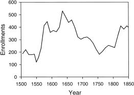

图 3.5 牛津大学的入学人数，1500 年至 1850 年。

Figure 3.5 Enrollments at Oxford University, 1500–1850.

精英内部竞争的第二个指标是士绅之间的诉讼数量。“1640 年，威斯敏斯特中央法院的人均诉讼量可能比之前或之后的任何时候都多。但一百年后的 1750 年，普通法似乎创下了历史新低”（Brooks 1989：360）。例如，从 1640 年到 1750 年，作为原告或被告出庭的士绅数量减少了 65% 以上（Brooks 1989）。因此，诉讼的增加不仅仅是英国现代社会兴起的结果。

The second indicator of intraelite competition was the amount of litigation among gentry. “In 1640, there was probably more litigation per head of population going through the central courts at Westminster than at any time before or since. But one hundred years later in 1750, the common law hit what appears to have been a spectacular all-time low” (Brooks 1989:360). For example, from 1640 to 1750, the number of gentry who appeared in the Courts of Common Pleas as plaintiffs or defendants dropped by over 65 percent (Brooks 1989). Thus, the increase in litigation was not simply a result of the rise of the modern society in England.

除了戈德斯通提出的两个指标之外，精英内部竞争的第三个指标是十六世纪末困扰英国贵族的决斗现象。时事通讯和信件中提到的决斗和挑战的数量从 1580 年代的 5 次跃升至 1590 年代的近 20 次，然后在 1610 年代达到峰值 39 次（Stone 1965）。

A third indicator of intraelite competition, in addition to the two proposed by Goldstone, was the veritable epidemic of dueling that afflicted the English aristocracy in the late sixteenth century. The number of duels and challenges mentioned in newsletters and correspondence jumped from five in the 1580s to nearly twenty in the 1590s, and then to a peak of thirtynine in the 1610s (Stone 1965).

决斗的兴起与十六世纪末席卷英国社会并在十七世纪初达到顶峰的犯罪浪潮同时发生（也许是犯罪浪潮的一部分）。艾斯纳（Eisner，2003）收集的凶杀案数据表明，犯罪率的总体上升和下降与人口压力和实际工资的倒数同步上升和下降（图 3.6 ）。

The rise of dueling coincided with (and perhaps was a part of) the crime wave that inundated the English society in the late sixteenth century and peaked in the early seventeenth. Data on homicides assembled by Eisner (2003) suggest that the general incidence of crime increased and declined in step with population pressure and inverse real wages (figure 3.6).

## **国家**

## **The State**

人口增长的最后一个主要后果是英国政府的财政压力日益加大。亨利七世统治下的国家收入强劲，并持续增加，直到十六世纪中叶。此后，实际收入下降（见图3.3），而支出继续上升。国家财政困难在 16 世纪加剧，并在大革命前夕达到顶峰（图 3.7a）。基本问题是，政府的实际开支与人口数量成比例地增加，而实际收入却下降了。此外，精英人数的增加给国家带来了更大的赞助成本。从十六世纪中叶开始，王室越来越被迫出售资产、征收强制贷款，甚至在和平时期也寻求议会拨款（Goldstone 1991：93）。到了 1630 年代，皇家土地大部分消失，未偿还的皇家债务达到了利息高于普通收入的地步。此外，之前为确保超额收入所做的努力已经疏远了精英阶层，以至于他们不太可能默许国王进一步的财政要求或恳求。

The final major consequence of population growth was the increasing fiscal strain on the English state. The state revenues were strong under Henry VII and continued to increase until the mid-sixteenth century. After that point, revenues declined in real terms (see figure 3.3), while expenses continued to rise. The state's fiscal difficulties mounted during the sixteenth century and reached a peak on the eve of the Great Revolution (figure 3.7a). The basic problem was that the Crown's real expenses increased proportionately to population numbers, while real income declined. Additionally, the expanded elite numbers imposed greater patronage costs on the state. Increasingly, from the mid-sixteenth century on, the Crown was forced to sell assets, levy forced loans, and seek parliamentary grants even in peacetime (Goldstone 1991:93). By the 1630s, the Crown lands were largely gone, and the unpaid Crown debt reached the point where the interest on it was greater than the ordinary revenues. Furthermore, prior efforts to secure extraordinary revenues had alienated the elites to the point where they were unlikely to acquiesce to further fiscal demands or entreaties by the Crown.

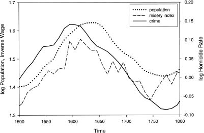

图 3.6 凶杀率与实际工资倒数（痛苦指数）和人口压力的关系。

Figure 3.6 Homicide rate in relation to inverse real wages (misery index) and population pressure.

以下是一些数字。国家债务从 1603 年的 40 万英镑增长到 1618 年的 90 万英镑（Hughes 1991：27）。在伊丽莎白的领导下，每年向贵族们发放 8,000 英镑的“津贴”；在詹姆斯一世统治下，这个数字增加到 105,000 英镑（Hughes 1991：151）。到 1626 年，养老金已增加到每年 140,000 英镑，约占王室现金总收入的四分之一（Stone 1965：419）。其中一些养老金是出于政府服务的合法要求，但越来越多的部分用于推动“掠夺王室收入的寄生宫廷贵族的增长”（Stone 1965：419）。在 1630 年代，超过一半的政府收入被官方工资吸收（Clay 1984b：261）。

Here are some numbers. The state debt grew from £400,000 in 1603 to £900,000 in 1618 (Hughes 1991:27). Under Elizabeth, “perks” of £8,000 per annum were distributed to the peers; under James I, this figure increased to £105,000 (Hughes 1991:151). By 1626 pensions had increased to £140,000 per year, or about a quarter of the total cash revenues of the Crown (Stone 1965:419). Some of these pensions were due to legitimate demands of government service, but an increasing part went to fuel “the growth of a parasitic court aristocracy preying upon the revenues of the Crown” (Stone 1965:419). In the 1630s more than half of government revenue was absorbed by official salaries (Clay 1984b:261).

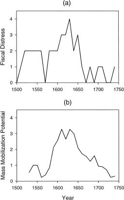

## 3.4 危机（1640–60）

## 3.4 Crisis (1640–60)

## **内战的爆发**

## **The Onset of the Civil War**

到了 1640 年，人口膨胀、精英生产过剩和国家破产日益严重所带来的社会压力已经达到了极限。杰克·戈德斯通（Jack Goldstone，1991）在他的开创性著作《*早期现代世界的革命与叛乱》*中使用了几个社会和政治指标来量化日益增长的压力。

By 1640 the social pressure resulting from population expansion, elite overproduction, and growing state insolvency had reached the breaking point. In his seminal work, *Revolution and Rebellion in the Early Modern World*, Jack Goldstone (1991) used several social and political indicators to quantify the growing pressure.

第一个指标是普通民众的群众动员潜力（MMP）。一个人口群体特别重要，即城市化的工人和工匠，特别是在首都，因为他们位于城市附近权力中心。戈德斯通在 MMP 中提出了三个可衡量的组成部分：（1）实际工资动态影响城市大众的痛苦程度，（2）年轻化的年龄结构，增加了人群的动员潜力，以及（3）城市增长，它集中了贫困的幼子和其他不满的平民，因此应该在放大因贫困加剧而带来的民众不满方面发挥重要的乘数作用。戈德斯通提出了一个公式，将这三种机制的影响结合起来，用于衡量群众动员潜力。图 3.7b绘制了 1530 年至 1750 年期间英格兰的 MMP 估计值。

The first index is the mass mobilization potential (MMP) of the general populace. One population group is of particular importance, the urbanized workers and artisans, especially in the capital, because they are located near the centers of power. Goldstone proposed three measurable components in the MMP: (1) the degree of misery affecting the urban masses by the dynamics of real wages, (2) youthful age structure, which increases the mobilization potential of the crowd, and (3) urban growth, which concentrates the poor young sons and other discontented commoners and thus should play an important multiplier role in amplifying the popular discontent brought about by increasing poverty. Goldstone proposed a formula combining the effects of these three mechanisms in one measure of mass mobilization potential. The estimated MMP for England during 1530–1750 is plotted in figure 3.7b.

当精英们团结起来并决心阻止国家崩溃时，增加的 MMP 本身并不足以导致国家崩溃。因此，导致国家崩溃的第二个趋势是精英团结的丧失。滞胀阶段，对土地所有者有利的经济形势导致了精英人数的大规模扩张。然而，可以从农民那里榨取的剩余量在 1620 年之后停滞不前，甚至下降。例如，实际租金在 17 世纪前 25 年达到顶峰，此后下降（表 3.4 ））。这两种相反趋势的直接后果是大革命前夕精英人均收入下降。正如通常发生的那样，痛苦并没有均匀地传播，尽管许多精英家庭陷入了极度贫困，但其他家庭仍然过得很好。因此，不仅有越来越多的精英面临向下流动的前景，而且不平等现象也明显加剧。保持精英地位的途径之一是在国家、教会或权贵中寻求就业机会。但就业机会跟不上精英渴望者（其中大多数人拥有大学学位）数量的增长。“对可用土地、民事和教会办公室以及王室赞助的限制导致赞助人和客户团体之间为了争夺可用战利品而日益两极分化的派系斗争”（Goldstone 1991：119）。当一个精英派系获胜时，它试图完全排除其竞争对手。这就是白金汉公爵乔治·维利尔斯 (George Villiers) 领导的派系从 1617 年左右到他 1628 年去世期间成功垄断宫廷的赞助权时所发生的情况。用大卫·洛兹 (David Loades) (1999:308) 的话来说，“白金汉的优势......将虐待变成了系统性剥削的丑闻。”

An increased MMP by itself was not enough to cause the state collapse when the elites were unified and determined to prevent it. Thus, the second trend contributing to state breakdown was the loss of elite unity. A favorable economic conjuncture for landowners during the stagflation phase resulted in the massive expansion of elite numbers. However, the amount of surplus that could be wrung from the peasants stagnated and even declined after 1620. For example, real rents peaked during the first quarter of the seventeenth century and declined thereafter (table 3.4). The direct consequence of these two opposing trends was that the average income per elite capita declined on the eve of the Great Revolution. As usually happens, the pain was not spread evenly, and although many elite families were greatly impoverished, others continued to do well. Thus, not only was there a growing segment of elites who faced the prospect of downward mobility, there was also a visible rise in inequality. One avenue for preserving elite status was to seek employment with the state, church, or the magnates. But employment opportunities could not keep pace with the growing numbers of elite aspirants (most of whom had university degrees). “Limits on available land, civil and ecclesiastical offices, and royal patronage led to increasingly polarized factional battles between patron-client groups for available spoils” (Goldstone 1991:119). When one elite faction won, it attempted to completely exclude its rivals. This is what happened when the faction led by George Villiers, the Duke of Buckingham, managed to monopolize the court's patronage from about 1617 to his death in 1628. In the words of David Loades (1999:308), “the ascendancy of Buckingham…transformed abuse into a scandal of systematic exploitation.”

精英阶层对职位的呼声日益高涨，加剧了第三个趋势，即国家财政困难。国家财政还面临着十六世纪军事革命带来的军事费用上升的压力。然而，收入最终未能跟上支出增长的步伐。事实上，实际收入在 16 世纪下半叶下降，并从 1600 年到 1640 年停滞不前（见图3.3）。因此，国家增加收入的能力无法跟上日益增长的财政需求。皇室使用了多种权宜之计提供短期救济——出售皇家土地、办公室和头衔、货币贬值以及从伦敦市和国际货币市场借款。然而，到了 1630 年代，皇家土地消失了，国家债务已超过 100 万英镑。国家正处于破产的边缘，只需要一次非常轻微的冲击（主教战争）就可以将其推向悬崖。

The increasing clamor of the elites for positions aggravated the third trend, the fiscal difficulties of the state. The state finances were also under pressure from rising military costs from the military revolution of the sixteenth century. The revenues, however, ultimately failed to match the pace of increased outlays. In fact, real revenues declined during the second half of the sixteenth century, and stagnated from 1600 to 1640 (see figure 3.3). Thus, the ability of the state to raise revenue could not keep up with the increasing fiscal demands on it. The Crown used a variety of expedients to provide short-term relief—the sale of Crown lands, offices, and titles, debasement of coinage, and borrowing from the city of London and the international money market. By the 1630s, however, Crown lands were gone and the state debt had reached over £1 million. The state was on the brink of bankruptcy, and it took a very slight shock (the Bishops’ Wars) to tip it over the precipice.

## **内战的经济后果**

## **Economic Consequences of the Civil War**

The civil wars started in 1642 and lasted with intervals until 1651, followed by a period of continuing political instability until the restoration of the monarchy in 1660. During this period of civil war and governmental confusion some 10 percent of the male population was killed. Towns such as Birmingham (1643), Bolton (1644), and Leicester (1645) were sacked. The castles and houses of the nobility and gentry were sacked or destroyed to prevent their use in future campaigns (King 1971:355). Local studies document the extent of property damage. For example, even though Gloucester remained under one side's control throughout the conflict, and its siege was not reckoned to be particularly destructive, a 1646 investigation found 241 houses destroyed, leaving 1,250 people homeless, and the suburbs were not rebuilt until the eighteenth century (Warmington 1997:78). The countryside suffered much more. Almost every village in Inshire (the area around Gloucester) was plundered at least once, and many repeatedly. The Tewkesbury region (also in Gloucestershire) was plundered in 1643, 1644, and 1645. As a result of pillage and heavy taxation imposed by both sides, land values declined so far that tenants refused to pay rents and abandoned their leases. Some villages were reportedly depopulated as a result of the war (Warmington 1997:77).

大量土地易手（尽管其中大部分后来被逆转），包括 350 万英镑的皇家土地、250 万英镑的教会土地和超过 100 万英镑的保皇党土地（King 1971：355）。这次土地流转造成了农村的严重混乱。被没收土地的购买者急于获得快速回报，而无法出示其所有权书面证据的租户可能会被驱逐（Hill 1982：125）。

An enormous amount of land changed hands (although much of it was later reversed), including £3.5 million of Crown lands, £2.5 million of ecclesiastical lands, and over £1 million of royalist lands (King 1971:355). This transfer of land caused significant dislocation in the countryside. Purchasers of confiscated lands were anxious to secure quick returns, and tenants who could not produce written evidence of their titles were liable to eviction (Hill 1982:125).

在 1640 年代和 1650 年代，英国农村的穷人几乎完全是中立的。农村穷人唯一的严重干预是以战争后期在几个县聚集的“俱乐部成员”集会的形式出现的。这些干预措施只不过是农村穷人为保护他们的田地、农作物、牲畜和妇女免受两军掠夺而做出的绝望尝试（Stone 1972：55）

The rural poor in England were almost entirely neutral during the 1640s and 1650s. The only serious intervention by the rural poor came in the form of assemblies of the “clubmen” who gathered in several counties during the latter stages of the war. These interventions were no more than desperate attempts by the rural poor to protect their fields, crops, cattle, and women from the depredations of both armies (Stone 1972:55)

综上所述，内战对英国的经济基础设施造成了巨大的破坏。看来，造成这一轻微后果的唯一原因是该国在十七世纪经历的人口下降却使农业生产力迅速提高。因此，17 世纪小麦产量增加了 50% 以上，显然是为了补偿因内战而损失的耕地。

To sum up, the civil war did enormous damage to the economic infrastructure of England. It appears that the only reason for the very slight population decline that the country experienced during the seventeenth century was rapidly increasing agricultural productivity. Thus, wheat yields increased by more than 50 percent during the seventeenth century, apparently compensating for the loss of cultivated land resulting from internal warfare.

## **人口**

## **Population**

感谢瑞格利、斯科菲尔德和同事对近代早期英格兰人口重建的工作，我们对 16 世纪中叶到 19 世纪人口变化背后的人口机制有了牢固的把握。人口增长率的时间变化是由于出生率和死亡率的变化造成的，但粗出生率和死亡率对人口数量变化的反应具有不同的滞后性。

Thanks to work by Wrigley, Schofield, and co-workers on the population reconstruction of the early modern England, we have a firm grasp of the demographic machinery underlying population changes from the midsixteenth century to the nineteenth century. The temporal variation in the population growth rate was due to changes in both birth and death rates, but crude birth and death rates responded with different lags to changes in population numbers.

瑞格利、斯科菲尔德和同事表明，粗出生率的很大一部分差异可以用结婚来解释。从未结婚的人口比例从 16 世纪中叶的 5% 增加到 1650 年的 25% 以上，然后在接下来的一百年里又下降到 5% (Wrigley and Schofield 1981:262)。1550 年至 1650 年间，初婚平均年龄也有所增加，这导致每个已婚妇女的平均孩子数减少了至少一个（Wrigley 等，1997：136）。

Wrigley, Schofield, and co-workers showed that a large proportion of variance in the crude birth rate could be explained by nuptiality. The proportion of the population never marrying increased from 5 percent in the mid-sixteenth century to over 25 percent by 1650, before declining back to 5 percent during the next hundred years (Wrigley and Schofield 1981:262). The average age at first marriage also increased between 1550 and 1650, which had the effect of reducing the average number of children per married woman by at least one (Wrigley et al. 1997:136).

17 世纪是死亡率稳步恶化的时代，在 1680 年左右达到最高点。1700 年左右死亡率有所改善，然后在 1720 年代又达到死亡率峰值，特别影响婴儿和儿童（Wrigley 等，1997：283）。十八世纪人们对生活的期望逐渐（而且并不总是单调）改善。移民在 1550 年开始增长，在 1650 年达到顶峰，然后进入长期衰退，直到 1780 年代（Wrigley 和 Schofield 1981：220）。

The seventeenth century was an era of steadily worsening mortality that reached a maximum around 1680. There was an improvement around 1700, then another mortality peak during the 1720s, particularly affecting infants and children (Wrigley et al. 1997:283). The eighteenth century saw a gradual (and not always monotonic) improvement in the expectation of life. Migration began growing in 1550, peaked in 1650, and then entered a secular decline until the 1780s (Wrigley and Schofield 1981:220).

对人口状况恶化的解释是由饥荒、疾病和战争等“常见嫌疑人”提供的。这一时期最严重的饥荒发生在 1594-97 年，这一时期出现了 16 世纪最长的歉收（Clay 1984a：19）。一代人之后，即 1622-23 年，粮食价格上涨，同时布料工业严重萧条，导致许多人无钱购买食物。两个时期都有明显的证据表明饥饿导致死亡，特别是流浪者、老年寡妇和赤贫儿童。其他生存危机接踵而至，但到了 17 世纪中叶，大范围的饥荒似乎已成为过去（Clay 1984a：19）。

The explanations of the worsening demographic regime are provided by the “usual suspects” of famine, disease, and war. The worst famine of the period occurred during the years 1594–97, which saw the longest run of bad harvests of the sixteenth century (Clay 1984a:19). A generation later, in 1622–23, a rise in the price of grain coincided with a severe depression in the cloth industry, leaving many people without money to buy food. There is clear evidence from both periods of deaths from starvation, especially of vagrants, elderly widows, and pauper children. Other subsistence crises followed, but by the middle of the seventeenth century widespread famine seems to have become a thing of the past (Clay 1984a:19).

鼠疫在 15 世纪末放松了对英国人口的控制，并在 16 世纪逐渐增加（Biraben 1975）。1570年至1670年间是一个反复出现的时期鼠疫流行，最终导致伦敦大瘟疫（1665年）。十七世纪末，鼠疫在英国突然灭绝。然而，瘟疫并不是十七世纪唯一的祸害。当自相残杀加剧时（例如 1648 年），斑疹伤寒的流行常常爆发。1670 年代，伦敦每年因天花流行而死亡的人数经常超过 2,000 人（Scott 和 Duncan 2001：40）。

The plague, which relaxed its grip on the English population by the end of the fifteenth century, gradually increased during the sixteenth (Biraben 1975). The century between 1570 and 1670 was a period of recurrent plague epidemics, culminating in the great plague of London (1665). During the late seventeenth century the plague suddenly went extinct in England. However, the plague was not the only scourge during the seventeenth century. Typhus epidemics often flared up when internecine fighting intensified (for example, in 1648). The annual death toll of smallpox epidemics in London often exceeded 2,000 during the 1670s (Scott and Duncan 2001:40).

## 3.5 萧条（1660-1730）

## 3.5 Depression (1660–1730)

## **人口停滞**

## **Population Stagnation**

英格兰人口从 1650 年代达到的 540 万峰值下降到 1680 年代的 500 万谷底。此后的一段时期的特点是增长非常缓慢且不均匀。1730年人口仍为540万，下一个时期的旺盛增长期是在1750年后才开始。解释这种长期停滞的主要因素似乎是死亡率，因为从1650年起，生育力呈现出增加的趋势。然而，瑞格利等人进行了详细的人口统计调查。(1997:298)表明，成人死亡率在 18 世纪有所改善，但这种改善直到 1750 年代才被婴儿和儿童的高死亡率所抵消。英国杀婴案件的起诉率在 17 世纪末达到顶峰，并在 18 世纪缓慢下降（图 3.8）），表明这一时期的高婴儿死亡率可能是有意识（或无意识）尝试节育的结果。因此，人口统计数据是模糊的，并没有告诉我们太多关于 1750 年之前人口停滞的可能原因。

The population of England declined from the peak of 5.4 million, achieved during the 1650s, to a trough of 5 million in the 1680s. The period after that was characterized by very slow and uneven growth. The population was still 5.4 million in 1730, and the next period of vigorous growth began only after 1750. The main factor explaining this prolonged period of stagnation appears to be mortality, because fecundity exhibited an increasing trend from 1650 on. However, detailed demographic investigation by Wrigley et al. (1997:298) indicates that adult mortality improved during the eighteenth century, but this improvement was offset until the 1750s by high infant and child mortality rates. Infanticide indictment rates in England peaked in the very late seventeenth century and slowly declined during the eighteenth (figure 3.8), suggesting that high infant mortality during this period may have been a result of a conscious (or unconscious) attempt at birth control. Thus, the demographic picture is murky and does not tell us much about the possible causes of population stagnation prior to 1750.

We believe that three factors, two endogenous and one exogenous, can help us understand this puzzling phenomenon (but not a unique one; a similar period of population stagnation occurred during the depression phase of the Plantagenet cycle). First, there was a strong negative effect of urbanization on population growth. As we discussed above, the peak of urbanization was considerably lagged with respect to the population peak. Between 1700 and 1750 London had 10 percent of the country's population, a fourfold increase from 1580 and slightly greater than the urbanization index of 1830 (9 percent). A high degree of urbanization during the depression phase of the Tudor cycle without doubt was an important factor contributing to the unfavorable demographic regime. E. A. Wrigley (cited in Clay 1984a:191) calculated that during 1690–1710 immigration to London (estimated at 30,000 per year, on average) absorbed half of the natural increase of the entire population of the country. The enormous losses that London suffered in the seventeenth-century plagues were made good by the second year after an outbreak. The dampening demographic effect of London was amplified by the fact that it disproportionately attracted female immigrants, who came in response to the great demand for domestic servants. As a result, there were fewer than ninety men for every one hundred women (Clay 1984a:209). The sex imbalance served to further depress the ability of population to increase.

[figure not shown]

图 3.8 1560-1800 年每 10 万人中杀婴罪的起诉率（Roth 2001）。

Figure 3.8 Infanticide indictment rates per 100,000, 1560–1800 (Roth 2001).

其次，罗伯特·艾伦收集的租金数据表明，从 17 世纪最后 25 年到 18 世纪前 25 年，实际租金跃升了 70%（Allen 1992：172）。很可能，一旦精英内部不团结的时期结束，精英们就处于一个更好的位置来“拧紧”农民。尽管地租的增加部分被十七世纪英国农业生产率的提高所补偿，但它仍然必然大幅减少了农民的个人消费。这是一个非常尝试性的解释，并非没有问题。例如，这一时期的实际工资总体上持续增长（尽管从未达到 15 世纪的最高水平）。但如果农民受到过度剥削 这应该会影响到实际工资，但我们没有看到这一点。也许租金上涨只是阻碍了农村人口的增长，从而间接导致人口增长缓慢。这个问题需要进一步调查。

Second, the data on rents collected by Robert Allen suggests that real rents jumped by 70 percent from the last quarter of the seventeenth century to the first quarter of the eighteenth century (Allen 1992:172). It is likely that, once the period of intraelite disunity was over, the elites were in a much better position to “turn the screws” on the peasants. Although the increased rent was partly compensated for by the increase in productivity achieved by English agriculture during the seventeenth century, it still must have substantially decreased the personal consumption of peasants. This is a very tentative interpretation, and not free of problems. For example, real wages during this period generally kept increasing (although they never reached their fifteenth-century maximum). But if peasants were overexploited, this should have spilled over into real wages, which we do not see. Perhaps increased rents simply retarded the growth of the rural population, thus contributing indirectly to slow population growth. This issue requires further investigation.

第三个因素是十八世纪初气候的普遍恶化（与太阳活动的蒙德极小期有关）。气候变冷影响了从伦敦到莫斯科的欧洲，导致了一系列农作物歉收和饥荒。我们知道，法国和俄罗斯的人口在本世纪头十年都经历了下降，这通常归因于路易十四和彼得一世分别进行的战争所施加的勒索。然而，同样有可能的是，这种泛欧洲人口下降的原因可能在于气候的外生因素。

The third factor was the general worsening of the climate in the early eighteenth century (associated with the Maunder Minimum of solar activity). The climate cooling affected Europe from London to Moscow, causing a sequence of crop failures and famines. We know that populations of both France and Russia experienced declines during the first decade of the century, which are usually attributed to the exactions imposed by wars pursued by Louis XIV and Peter I, respectively. However, it is equally possible that the explanation for this pan-European population decline may lie in the exogenous factor of climate.

## **精英们**

## **The Elites**

The civil wars resulted in serious deterioration of the economic position of the landed elites. Particularly affected were the royalists, whose lands were confiscated and sold. The combined value of these properties was over £1.25 million. This land transfer was partially reversed because many royalists bought their estates back before 1660 (Hill 1982:126). However, most of them had to incur heavy debt to do so. Nearly £1.5 million was raised from some 3,000 royalists by the Committee of Compounding. On top of these and other exactions came heavy taxation. In order to pay composition fines after a long period of receiving no rents, royalists had to sell part of their lands, and these lands were not restored after 1660. Thus, although the bulk of royalist landlords retained their position, many were greatly impoverished in the process, and some lesser elite families had a stiff fight to keep their heads above water (Hill 1982:126).

在 17 世纪最后 25 年，由于农产品价格低廉和租金下降，几乎所有地主的收入都进一步减少（Clay 1984a：162）。除此之外，他们还必须承担很高的税率。例如，1692年之后，税收占据了许多士绅收入的五分之一。许多处于士绅底层的人不得不放弃他们的土地（Clay 1984a：162）。士绅经济财富的下降反映在他们的消费模式上。尽管十七世纪初见证了奢侈品进口的迅速扩张（Clay 1984a：26），但内战之后精英阶层的精神观念发生了重大变化，导致在住房、衣服和娱乐方面的显着支出减少（克莱 1984a：160）。

During the last quarter of the seventeenth century almost all landlords experienced a further reduction in their incomes as a result of low agricultural prices and falling rents (Clay 1984a:162). On top of this, again, they had to bear a much great rate of taxation. For example, after 1692 taxes were absorbing one-fifth of the income of many gentry. Many of those at the lower fringes of the gentry had to part with their land (Clay 1984a:162). The declining economic fortunes of the gentry were reflected in their consumption patterns. Whereas the early seventeenth century witnessed a rapid expansion in the imports of luxury (Clay 1984a:26), after the civil wars there was significant change of ethos among the elites, leading to a reduction of conspicuous expenditure on houses, clothes, and entertaining (Clay 1984a:160).

The economic malaise affecting gentry extended into the eighteenth century. Thus, the average wealth of esquires in Norfolk and Suffolk was £700 in 1628–40 and then declined to £330 for the period of 1700–40, a drop of more than 50 percent in real terms (Overton 1996:39). The result was increased downward mobility, with an almost automatic descent by younger sons into lower social strata. For example, in Cumbria between 1680 and 1750 only one younger son of the gentry was able to purchase land and climb back up into the group (Beckett 1986:23). The upward mobility into the ranks of the gentry was similarly restricted. “With a few exceptions, the days when a man of fortune converted his wealth into landed acreage were already numbered by the end of the seventeenth century, and the practice had more or less disappeared by the mid-eighteenth century” (Beckett 1986:69).

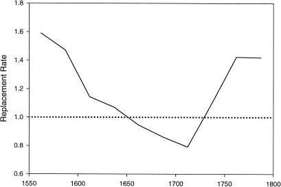

图 3.9 1550-1800 年同龄人的替代率（Hollingsworth 1964）。

Figure 3.9 Replacement rates of peers, 1550–1800 (Hollingsworth 1964).

**表 3.5**

**TABLE 3.5**

上层精英数量

Numbers of upper rank elites

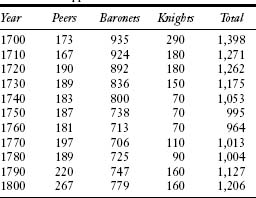

*资料来源：*贝克特（1986）。

*Source:* Beckett (1986).

*注：*还有爱尔兰和苏格兰的同行，此处未显示。

*Note:* There were also Irish and Scottish peers, not shown here.

## **内战的后果：改变了社会情绪**

## **Consequences of the Civil War: Changed Social Mood**

当 1642 年内战开始时，英国人可以回顾一个世纪的内部和平：

When the civil wars began in 1642, the English could look back to a century of internal peace:

1549 年的起义没有遇到太大困难就被镇压了…… 萨默塞特的推翻是在没有流血的情况下完成的。诺森伯兰郡转移继承权的企图仅因内战的暗示而失败。玛丽的政权虽然不太受欢迎，但实现了其最初的大部分目标，并且即使在最后也从未面临被推翻的危险。1550 年代中期和 1590 年代中期的收成给穷人带来了可怕的痛苦，但英格兰没有任何地方引发大规模的起义……。伊丽莎白镇压了长老会运动并有效遏制了天主教的威胁，而埃塞克斯的叛乱在二十四小时内崩溃成了黑色喜剧……。伊丽莎白去世后的继承危机得到了巧妙而和平的解决。（威廉姆斯 1995：22）

The risings of 1549 were quelled without undue difficulty…. The overthrow of Somerset was accomplished without bloodshed. Northumberland's attempt to divert succession collapsed with only a hint of civil war. Mary's regime, although hardly popular, achieved most of its initial objectives and never looked, even at the end, in danger of being overthrown. The harvests of the mid-1550s and the mid-1590s inflicted terrible sufferings upon the poor, but nowhere in England set off the large-scale risings…. Elizabeth crushed the Presbyterian movement and effectively contained the Catholic threat, while Essex's revolt collapsed into black comedy in twenty-four hours…. [T]he succession crisis at the death of Elizabeth was solved dextrously and peacefully. (Williams 1995:22)

“最后一次严重到足以让士绅们惊恐地逃离家园的农民起义发生在1549年……[并且]到1640年，自这场巨大的恐惧以来，两代士绅已经过去了，记忆也变得模糊了”（Stone 1972：76） 。精英中很少有人能够预见到他们的行为将导致社会崩溃的严重程度，精英内部的冲突被允许不受控制地升级，直到它获得自己的动力。

“The last peasant revolt serious enough to send gentry fleeing from their homes in terror had been in 1549…[and] by 1640 two generations of gentry had gone by since the great fear, and memories had grown dim” (Stone 1972:76). Few among the elites could foresee the depth of the societal collapse that would result from their actions, and the intraelite conflict was allowed to escalate unchecked until it acquired a dynamic of its own.

1640 年之后的二十年是英国自玫瑰战争以来最持久、最激烈的社会政治不稳定时期。相比之下，接下来的二十年（斯图亚特王朝复辟之后）是一个内部和平时期。因此，内战和内部稳定之间的交替提供了两代循环的另一个例子。然而，1680年左右，社会压力再次开始增加。三个议会来来去去都很快（1679-81）。1682 年，针对辉格党和持不同政见者的“法律恐怖”统治开始。一些人被处决，另一些人被流放（Hill 1982：169）。1685年查理二世去世后，詹姆斯二世和平继位，但同年发生了两次起义。阿盖尔和蒙茅斯的叛乱很快被镇压，但三年后奥兰治的威廉登陆英国时，叛乱迅速蔓延，詹姆斯二世选择逃离英国。这次“光荣革命”（1688-90年，苏格兰和爱尔兰余震直至1692年）的结果是，斯图亚特王朝被废除，议会将王位共同授予威廉和玛丽。这场革命的一个显着特点是它相对不流血。辉格党和托利党在许多问题上存在尖锐分歧，但这些分歧得到了弥合，很大程度上是由于“人们对四十五年前发生的事情的回忆，当时有产阶级的团结被打破”（Hill 1982：236） ）。精英们达成的妥协在整个 18 世纪及以后的时期都得到了很好的维持。光荣革命之后，英国（1707 年英格兰和苏格兰联合后的名称）除了两次雅各布派起义（一次发生在 1715-16 年，另一次发生在 1745-46 年）之外，没有发生重大叛乱。光荣革命之后，这些余震大约每隔几代人就发生一次：第一次是由詹姆斯二世的儿子领导的，第二次是由他的孙子领导的。

The two decades following 1640 were the most protracted and intense period of sociopolitical instability in England since the Wars of the Roses. The following two decades (after the Stuart Restoration) were, in contrast, internally a peaceful period. This alternation between civil war and internal stability thus provides another example of a bigenerational cycle. Around 1680, however, social pressure began increasing again. Three parliaments came and went in rapid succession (1679–81). A reign of “legal terror” against Whigs and dissenters began in 1682. Several were executed, and others driven into exile (Hill 1982:169). When Charles II died in 1685, he was succeeded peacefully by James II, but the same year two risings took place. The Argyll and Monmouth rebellions were rapidly suppressed, but when William of Orange landed in England three years later, the rebellion quickly spread, and James II chose to flee England. As a result of this “Glorious Revolution” (1688–90, with aftershocks in Scotland and Ireland until 1692), the Stuart dynasty was abolished, and Parliament offered the crown to William and Mary jointly. One remarkable feature of this revolution was its relative bloodlessness. Whigs and Tories disagreed sharply on a number of issues, but these differences were patched up, largely as a result of “men's recollection of what happened forty-five years earlier, when unity of the propertied class had been broken” (Hill 1982:236). The compromise reached by the elites held up remarkably well throughout the whole of the eighteenth century and beyond. After the Glorious Revolution there were no major rebellions in Great Britain (as the union of England and Scotland was called after 1707), apart from two Jacobite risings, one in 1715–16 and another in 1745–46. These aftershocks followed the Glorious Revolution at roughly generational intervals: the first one was led by James II's son and the second by his grandson.

## **转折点：十八世纪中叶**

## **The Turnaround Point: The Mid-eighteenth Century**

到十八世纪中叶，现代早期危机的最后余波已经消散。整个 18 世纪初，实际工资不断增长，在 1750 年左右达到顶峰。英国最近一次严重扰乱内部和平的是 1745-46 年的雅各布派起义。精英人数在 1760 年代左右达到最低限度。统治阶级达到了前所未有的团结程度。1721年政治制度稳定后，土地所有者大幅减少了选举人和议会选举的人数（Stone and Stone 1984：14）。精英的凝聚力使他们能够在早期现代社会中以前所未有的速度向自己征税，这种能力在与法国长达一个世纪的冲突中为英国提供了很好的帮助，最终导致拿破仑战争。因此，到了十八世纪中叶，英国在下一个半世纪将经历惊人的人口、经济和领土扩张。

By the mid-eighteenth century, the last echoes of the early modern crisis had dissipated. Real wages increased throughout the early eighteenth century, reaching a peak around 1750. The last serious disturbance of internal peace in Great Britain was the Jacobite rising in 1745–46. The numbers of the elites reached a minimum sometime around the 1760s. The ruling class achieved an unprecedented degree of unity. After the stabilization of the political system in 1721, landowners drastically reduced the number of both electors and contested elections to Parliament (Stone and Stone 1984:14). The elite cohesiveness allowed them to tax themselves at an unprecedented rate for an early modern society, an ability that served England well during the century-long conflict with France culminating in the Napoleonic Wars. Thus, by the mid-eighteenth century, the stage was set for the astonishing demographic, economic, and territorial expansion England was to experience during the next century and a half.

## 3.6 结论

## 3.6 Conclusion

大约从 1485 年到 1730 年，现代早期英格兰的人口、经济、政治和社会趋势总体上与人口结构理论的预测一致。正如戈德斯通 (Goldstone, 1991) 先前所论证的那样，英国革命的案例特别适合人口结构理论。革命的三个要素是国家的财政危机、精英之间的激烈竞争和派系斗争，以及议会领导人可以动员他们反对伦敦保皇党的大量心怀不满的平民。所有这些过程的测量结果在 16 世纪下半叶和 17 世纪初有所增加，并在 1640 年左右达到顶峰。

The demographic, economic, political, and social trends in early modern England, from roughly 1485 to 1730, generally moved in ways that were consistent with the predictions of the demographic-structural theory. The case of the English Revolution fits the demographic-structural theory particularly well, as was argued earlier by Goldstone (1991). The three ingredients of the revolution were the financial crisis of the state, acute competition and factionalism among the elites, and the existence of a large body of disaffected commoners who could be mobilized by parliamentary leaders against the royalists in London. Measures of all these processes increased during the second half of the sixteenth and the early seventeenth centuries, peaking around 1640.

正如之前金雀花周期的案例研究一样，我们发现人口结构机器的运行受到其他因素的影响和修改。地缘政治环境显然在此周期中发挥了次要作用。虽然是荷兰总督奥兰治的威廉的入侵促成了光荣革命，但光荣革命的成功完全是由于内部因素。

As in the previous case study of the Plantagenet cycle, we found that the operation of the demographic-structural machinery was influenced and modified by other factors. The geopolitical environment apparently played a minor role during this cycle. Although it was the invasion by the Dutch Statholder, William of Orange, that precipitated the Glorious Revolution, the success of it was entirely due to internal factors.

气候的长期波动可能是造成十七世纪末至十八世纪初人口停滞的重要原因。在这个周期中，没有发生可与1348年黑死病的到来相媲美的创伤性外生事件。17世纪期间流行病发生率的增加显然是一个内生过程。

Long-term fluctuations in climate were probably important in contributing to population stagnation of the late seventeenth century to early eighteenth century. During this cycle there were no traumatic exogenous events comparable to the arrival of the Black Death in 1348. The increase in the incidence of epidemics during the seventeenth century was apparently an endogenous process.

人口结构理论核心变量之外最重要的因素是社会进化的加速，最终导致了工业革命。由于科学和农艺的进步，农作物产量在 1600 年之后不久就开始增加。在 17 世纪，产量翻了一番。结果，承载能力也增加了一倍。我们相信，正是承载能力的急剧增加解释了为什么英国的人口数量没有像十七世纪的西班牙或德国那样崩溃。当我们将总人口除以估计的承载能力时，我们观察到所得变量，即人口对资源的压力，以与金雀花周期期间发生的情况非常相似的方式振荡（图 3.10）。

The most important factor outside the core variables of the demographicstructural theory was the acceleration of social evolution that eventually resulted in the Industrial Revolution. Because of scientific and agronomic advances, crop yields began increasing shortly after 1600. During the seventeenth century yields doubled. As a result, the carrying capacity also doubled. We believe it was this dramatic increase in the carrying capacity that explains why population numbers in England did not collapse to the same degree as happened in, for example, Spain or Germany in the seventeenth century. When we divide the total population by the estimated carrying capacity, we observe that the resulting variable, the population pressure on resources, oscillates in a very similar fashion to what happened during the Plantagenet cycle (figure 3.10).

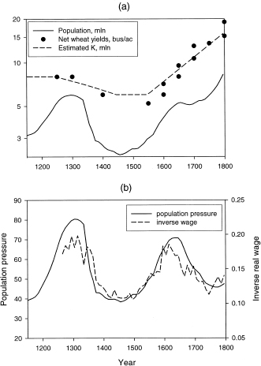

图 3.10 英国人口动态，1150-1800 年（见本章附录）。(a) 原始种群数量、平均产量和估计承载能力。(b) 人口压力（与承载能力相关的人口数量，以*K*的百分比表示）和痛苦指数（实际工资的倒数）。

Figure 3.10 Population dynamics in England, 1150–1800 (see appendix to this chapter). (a) Raw population numbers, average yields, and estimated carrying capacity. (b) Population pressure (population numbers in relation to carrying capacity, in percent of *K*) and the misery index (inverse real wages).

## 第 3 章附录：去趋势化人口数据（本材料转载自 Turchin 2005。）

## Appendix to Chapter 3: Detrending Population Data (This material is reproduced from Turchin 2005.)

## **英国 1450 年至 1800 年：人口数据**

## **England 1450–1800: Population Data**

1540-1800 年期间的人口数量取自 Wrigley 等人的表 A.9.1。（1997）。Wrigley 等人的五年一次数据。以十年为间隔重新采样。1450-1525 年期间的人口数据取自 Hatcher (1977)，也是以十年为间隔采样（此处分析的所有数据均以十年为间隔采样）。1530 的值是插值的。人口数据显示出长期增长趋势。这种非平稳性违反了非线性时间序列分析最重要的假设之一；因此，数据需要去趋势化（Turchin 2003a：175）。

Population numbers for the period 1540–1800 were taken from Table A.9.1 in Wrigley et al. (1997). The quinquennial data of Wrigley et al. were resampled at decadal intervals. For the period 1450–1525, population data were taken from Hatcher (1977), also sampled at ten-year intervals (all data analyzed here were sampled at ten-year intervals). The value for 1530 was interpolated. The population data show an increasing long-term trend. Such nonstationarity violates one of the most important assumptions of nonlinear time-series analysis; thus, the data need to be detrended (Turchin 2003a:175).

## **英国人口数据的去趋势化**

## **Detrending the English Population Data**

英国的土地革命始于十七世纪（Grigg 1989，Allen 1992，Overton 1996）。我们可以利用粮食产量长期变化的数据来追踪这场革命（Grigg 1989，Overton 1996）。13 世纪小麦的平均产量约为每英亩 10 蒲式耳。在 14 世纪和 15 世纪，产量略有下降，降至每英亩 8 蒲式耳（可能是全球气候恶化的结果）。即使到了 1580 年代，产量仍处于中世纪晚期的水平。然而，在 17 世纪，产量开始提高，增加到大约 10%。1700 年的 15 次和 19 世纪初的 20-21 次（Grigg 1989：69）。净产量（减去玉米种子）较低。例如，典型的中世纪晚期播种量为每英亩 2 蒲式耳；因此，每英亩净产量仅为 6 蒲式耳。格里格和奥弗顿的净收益率绘制在图3.10a。为了捕捉上升趋势，我们用直线拟合了 1580 年之后的数据（见图3.10a，并注意对数刻度）。线性关系似乎是对趋势的充分描述（例如，添加二次项未能以统计显着的方式改善回归）。

The agrarian revolution in England started during the seventeenth century (Grigg 1989, Allen 1992, Overton 1996). We can trace this revolution using data on long-term changes in grain yields (Grigg 1989, Overton 1996). Average wheat yields in the thirteenth century were around 10 bushels of grain per acre. Yields declined slightly during the fourteenth and fifteenth centuries to 8 bushels per acre (perhaps as a result of the worsening global climate). Even as late as the 1580s, the yields were still at their late medieval level. During the seventeenth century, however, yields began improving, increasing to ca. 15 in 1700 and 20–21 in the early nineteenth century (Grigg 1989:69). Net yields (subtracting seed corn) were lower. For example, the typical late medieval seeding rates were 2 bushels per acre; thus, the net yield was only 6 bushels per acre. Net yields from Grigg and Overton are plotted in figure 3.10a. To capture the rising trend, we fitted the data after 1580 with a straight line (see figure 3.10a, and note the log-scale). The linear relationship appears to be an adequate description of the trend (for example, adding a quadratic term failed to better the regression in a statistically significant fashion).

我们可以通过假设承载能力与净产量成正比来获得承载能力的近似估计。假设潜在耕地总面积为 1200 万英亩（Grigg 1989），并且一个人（成人和儿童的平均值）每年至少需要四分之一（8 蒲式耳或 2.9 百升）谷物，我们计算了英格兰的承载能力如图 3.10a中的虚线所示（巧合的是，每英亩 1 蒲式耳的净产量正好相当于 100 万人的承载能力）。

We can obtain an approximate estimate of the carrying capacity by assuming that it was proportional to the net yield. Assuming a total potentially arable area of 12 million acres (Grigg 1989) and that one individual (averaging over adults and children) needed a minimum of one quarter (8 bushels or 2.9 hectoliters) of grain per year, we calculated the carrying capacity of England shown by the dashed line in figure 3.10a (by coincidence, 1 bushel of net yield per acre translates exactly into 1 million persons of carrying capacity).

我们现在可以通过将观察到的人口数量除以估计的承载能力来消除趋势。去趋势人口也可以被认为是人口对资源的压力，定义为*N* ′( *t* ) *=N* ( *t* ) */K* ( *t* )。这里的关键假设是*K*与净产量*Y*成正比；因为*Y*是公式中唯一随时间变化的量；其他组成部分（总耕地面积、消耗最小值）是常数乘数，*K将与**Y*同步增减。换句话说，常数倍数的确切值并不重要，因为我们感兴趣的是人口压力的相对变化。*K*的估计不是基于实际耕种面积（随人口数量波动），而是基于潜在耕地面积。后者数量波动几个世纪以来的差异很小（例如，由于中世纪期间沿海地区的一些淹没或最近使用现代方法进行的填海造地），并且可以用常数来近似，而不会严重损失精度。

We can now detrend the observed population numbers by dividing them by the estimated carrying capacity. The detrended population, which can also be thought of as population pressure on resources, is defined as *N*′(*t*) *= N*(*t*)*/K*(*t*). The critical assumption here is that *K* is proportional to the net yield, *Y*; since *Y* is the only quantity varying with time in the formula; other components (total arable area, consumption minimum) being constant multipliers, *K* will wax and wane in step with *Y*. In other words, the exact values of constant multiples do not matter, since we are interested in the relative changes of population pressure. The estimate of *K* is based not on the area that was actually cultivated (this fluctuated with population numbers) but on the potentially arable area. The latter quantity fluctuated little across the centuries (for example, as a result of some inundation of coastal areas during the Middle Ages or more recent reclamation using modern methods) and can be approximated with a constant without a serious loss of precision.

通过对 Allen (2001) 报告的人口压力对实际工资的估计进行回归，可以检验这种去趋势的适当性。这两个变量之间存在非常密切的反比关系，如果我们使用非去趋势人口数，这种反比关系就不是很好。如图3.10b所示，人口压力和逆实际工资几乎完全同步波动。

A test of the appropriateness of this detrending was obtained by regressing the estimated population pressure on real wages reported by Allen (2001). There was a very close inverse relationship between these two variables, and not a very good one if we were to use the nondetrended population numbers. As figure 3.10b shows, population pressure and inverse real wages fluctuated virtually in perfect synchrony.

## **第4章**

## **Chapter 4**

## 中世纪法国：卡佩周期（1150–1450）

## Medieval France: The Capetian Cycle (1150–1450)

## 4.1 周期概述

## 4.1 Overview of the Cycle

卡佩王朝的正式开始可以追溯到 987 年于格·卡佩 (Hugh Capet) 登上法国王位。然而，在 1200 年之前，法国卡佩国王直接控制的领土面积相当小，被法国北部其他政体（最重要的国家）所掩盖。其中有诺曼人和安茹人。一体化趋势在十二世纪逐渐出现。重要的里程碑是路易六世“胖子”（1108-37 年）统治下的王室土地的巩固以及圣但尼修道院院长苏热 (Suger) 在 1122 年至 1151 年间的活动。因此，我们将中世纪盛期的开始定为法国的周期为1150年。

The official start of the Capetian dynasty is dated to the accession of Hugh Capet to the French throne in 987. However, before 1200 the Capetian kings of France directly controlled a rather insignificant extent of territory, overshadowed by other north French polities, the most important of which were the Normans and the Angevins. The integrative trend set in gradually during the twelfth century. The important landmarks were the consolidation of royal lands under Louis VI “the Fat” (1108–37) and the activities of Suger, abbot of St. Denis, between 1122 and 1151. For this reason, we date the beginning of the high medieval cycle in France to 1150.

和以前一样，我们的周期和周期内阶段的日期是临时的，如果有新的证据出现，可能会发生变化。它们也是“模糊的”，因为必须在围绕该日期的十年或二十年中发生的事件的广泛范围内选择一个特定日期。因此，1450 年这个日期实际上意味着 1440-60，甚至 1430-70。我们将连续周期划分为离散阶段是组织演示的有用方法，但这并不意味着连续阶段之间的过渡在一年内突然发生。

As before, our dates for the cycles and phases within cycles are provisional and subject to change should new evidence be forthcoming. They are also “fuzzy,” in that a specific date had to be selected within a broad penumbra of events occurring in the ten or twenty years surrounding it. Thus, the date of 1450 really means 1440–60, or even 1430–70. Our division of a continuous cycle into discrete stages is a useful device for organizing the presentation but does not mean that transitions between successive phases occurred abruptly, in a single year.

法兰西王国庞大且空间异质的实体给历史分析带来了进一步的挑战。我们所知道的国家在中世纪时期，现代法国是不同政体和文化区域的聚集体，它们可能而且确实彼此不同步。那么，接下来的年表主要与法国国家的领土核心有关，即卢瓦尔河以北的语言使用者居住的地区（Planhol 1994：124）。

The large and spatially heterogeneous entity of the kingdom of France offers further challenges to historical analysis. The country we know as modern France was, in the medieval period, an aggregation of different polities and cultural regions, which could and did move out of synchrony with one other. The chronology that follows, then, is primarily relevant to the territorial core of the French state, the region north of the Loire inhabited by the speakers of Langue d'Oïl (Planhol 1994:124).

## **人口与经济**

## **Population and Economy**

1100 年左右，法国可能有 600 万人口，1328 年接近 2000 万（Braudel 1988：137）。十二世纪和十三世纪人口增长两倍（最快增长集中在1200年左右的世纪）是西欧国家的典型现象（Abel 1980）。黑死病爆发后的一个世纪里，法国人口下降至 1000 万人左右（图 4.1a）。

There were perhaps 6 million people in France around 1100, and close to 20 million in 1328 (Braudel 1988:137). Such a tripling of the population during the twelfth and thirteenth centuries (with the fastest growth concentrated in the century around 1200) was quite typical of Western European countries (Abel 1980). During the century after the Black Death, the French population declined to around 10 million people (figure 4.1a).

这些数字指的是现代法国境内的人口。卡佩王朝控制地区的人口高峰期较小，大约为 1600 万（Sumption 1991：10）。1328年，王室官员统计了近2,470,000户家庭（不包括国王不征税的大封地和王子领地）。

These numbers refer to the population within modern French borders. The peak population in the area controlled by the Capetians was smaller, perhaps around 16 million (Sumption 1991:10). In 1328 the officials of the royal treasury counted nearly 2,470,000 households (the great fiefs and princely appanages, not taxed by the king, were excluded).

当以白银等价物表示时，食品价格的动态表现出与人口动态非常相似的模式：13世纪上升，随后在15世纪中叶下降至最低点（图4.1b ）。长期周期上还叠加了短期振荡（大约五十年）。

The dynamics of food prices, when expressed in silver equivalents, exhibited a very similar pattern to population dynamics: a thirteenth-century increase, followed by a decline to a minimum toward the mid-fifteenth century (figure 4.1b). There are also shorter-term oscillations (of about fifty years) superimposed on the secular cycles.

## **社会结构**

## **Social Structure**

法国权力等级制度的顶端是伟大的领土权贵——世俗领主（国王、公爵、伯爵和男爵）和高级教士（修道院院长、主教和大主教）。在他们之下的是中下层精英，从实力雄厚的骑士到相对贫穷的乡村乡绅（Tuchman 1978）。Edouard Perroy (1962) 对 13 世纪末 Forez 郡（法国中南部）贵族的研究提供了对各种精英阶层典型收入的看法。福雷兹伯爵 (Count of Forez) 处于当地等级制度的顶端，拥有 12,000*里弗维也纳币*(lv) 年收入。在他下面还有两三个年收入在1000到2000lv之间的男爵。二十名左右的大骑士，每人拥有一座城堡，收入在100-500lv之间。防御工事的持有者情况更糟，每年收入在50-100lv。贵族等级制度的最底层是大约一百名小士绅，他们的收入每年在25至50卢布之间。考虑到这一收入，当时一个人能够过上舒适生活的最低基本收入是 5 lv（这是当时的水平）。向上大学的年轻贵族提供的典型津贴或向小贵族的寡妇提供的养老金）。换句话说，每年25吕布足以维持一个四五口之家的生活，但没有剩下任何剩余来追求地位。当时25lv相当于5英镑；因此，法国和英国下层士绅的最低收入基本相同。福雷兹的大骑士的最低收入为 100 卢比，而他的对手则是年收入 20 英镑的英国骑士或绅士。

At the top of the power hierarchy of France stood the great territorial magnates—lay lords (the king, dukes, counts, and barons) and prelates (abbots, bishops, and archbishops). Below them were the middle and lower rank elites, from the more substantial knights to the relatively poor country squires (Tuchman 1978). A view of the typical incomes of various elite substrata is provided by Edouard Perroy's (1962) study of the nobility of the county of Forez (south-central France) in the late thirteenth century. At the top of the local hierarchy stood the Count of Forez, with 12,000 *livres viennois* (l.v.) of annual income. Below him were two or three barons with incomes of between 1,000 and 2,000 l.v. per year. Twenty or so substantial knights, each with a castle, enjoyed incomes between 100 and 500 l.v. The holders of fortified houses were worse off, with incomes of 50–100 l.v. per year. At the bottom of the noble hierarchy were about a hundred lesser gentry whose incomes varied between 25 and 50 l.v. per year. To put this income in perspective, the basic minimum on which a single person could live in modest comfort at the time was 5 l.v. (this was the typical allowance provided to a young nobleman attending university or a pension to a widow of the lesser gentry). In other words, 25 l.v. per year was enough to maintain a family of four or five, but left no surplus for status-seeking. A sum of 25 l.v. at that time was equivalent to £5; thus, the minimum incomes of the lesser gentry in France and in England were essentially the same. The substantial knight in Forez with a minimum income of 100 l.v. had his counterpart in an English knight or esquire with £20 per annum.

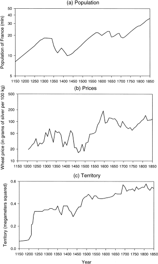

图 4.1 法国的人口、经济和领土动态，1150-1850 年。(a) 现代法国境内的人口（注意对数刻度）（根据 Braudel 1988 和 Dupâquier 1988a）。(b) 小麦价格，单位为每 100 公斤含银克数（数据来自 Abel 1980）。(c) 法国领土，单位为百万平方公里 (Mm <sup>2</sup> ) (Reed 1996)。

Figure 4.1 Demographic, economic, and territorial dynamics of France, 1150–1850. (a) Population within the modern borders of France (note the logarithmic scale) (after Braudel 1988 and Dupâquier 1988a). (b) Wheat price in grams of silver per 100 kg (data from Abel 1980). (c) Territory of the French state, in millions of square kilometers (Mm<sup>2</sup>) (Reed 1996).

在这个周期中，精英人数发生了巨大变化。大约 1300 年，贵族家庭在人口中的比例在 1% 到 4% 之间变化，具体取决于地区 (Contamine 1997:50-52)。平均水平为 2.4%，但 Philippe Contamine 谨慎地将这一数字降至 1.8%（Contamine 1997：53）。假设人口为 2000 万，每户 5 人，则在 1300 年估计会有 70,000 个贵族家庭。一个半世纪后，Contamine (1997:56)估计，贵族占总人口的比例已下降至 1.5%。假设 15 世纪中叶人口接近 1000 万大关，则在该周期结束时估计将有 30,000 个贵族家庭。

The elite numbers changed dramatically during the cycle. Around 1300 the proportion of noble households in the population varied between 1 and 4 percent, depending on the region (Contamine 1997:50–52). The average was 2.4 percent, a figure that Philippe Contamine, however, has cautiously lowered to 1.8 percent (Contamine 1997:53). Assuming a population of 20 million and five persons per household yields an estimate of 70,000 noble families in 1300. A century and a half later, Contamine (1997:56) estimates, the proportion of nobles to the total population had declined to 1.5 percent. Assuming a population near the 10 million mark in the middle of the fifteenth century, this produces an estimate of 30,000 noble families at the end of the cycle.

## **政治动态**

## **Political Dynamics**

早期的卡佩国王统治着法国北部以巴黎和奥尔良为中心的一小片地区。这种情况在十二世纪发生了巨大的变化（诺曼国家经历了旷日持久的内战和王朝更迭）。在腓力二世·奥古斯都（1180-1223）统治下，法国国家直接控制的领土急剧扩张，到1223年，法国国家直接控制的领土面积是于格·卡佩控制的领土的十倍（图4.1c ）。因此，在十二世纪的大部分时间里，法国首先在诺曼王朝，然后在安茹王朝统治下与英国交战，这段冲突时期有时被称为“第一次百年战争”。“掠夺、谋杀、盗匪和不安全是日常生活的一部分”（布罗代尔 1988：133）。

The early Capetian kings ruled a tiny area centered on Paris and Orléans in northern France. The situation changed dramatically during the twelfth century (when the Norman state experienced protracted civil war and change of dynasty). Under Philip II Augustus (1180–1223), the territory directly controlled by the French state expanded enormously, so that in 1223 it was ten times as large as the territory controlled by Hugh Capet (figure 4.1c). During most of the twelfth century, thus, France was at war with England under first the Norman and then the Angevin dynasties, a period of conflict sometimes called “the first Hundred Years’ War.” “Pillage, murder, banditry, and insecurity were part of everyday life” (Braudel 1988:133).

这一不稳定时期与卡佩王朝对法国的征服（其中包括阿尔比派十字军东征等暴力事件）相关，清楚地反映在钱币囤积的时间分布中（图4.2 ）。然而，一旦王国疆域扩大，中部地区就开始享受和平带来的好处。十三世纪几十年的大部分时间和十四世纪上半叶产出的宝藏相对较少（图4.2）。在 14 世纪的第二个十年期间出现了轻微的上升波动（可能与腓力四世统治末期的男爵叛乱有关），但下一个不稳定的主要高峰是由 1350 年代的国家崩溃和1360s（图4.2）。不幸的是，Jean Duplessy 的*Les Trésors Monétaires Médiévaux et Modernes Découverts en France*的第三卷尚未出版，因此我们缺乏有关 1385 年之后这一时期极其有用的指标的信息。

This period of instability, associated with the Capetian conquest of France (which included such violent episodes as the Albigensian Crusades), is clearly reflected in the temporal distribution of coin hoards (figure 4.2). Once the boundaries of the kingdom expanded, however, the central regions began to enjoy the benefits of the peace. Most of the decades of the thirteenth century and the first half of the fourteenth century have yielded relatively few hoards (figure 4.2). There is a minor upward fluctuation during the second decade of the fourteenth century (perhaps associated with the baronial rebellion at the end of Philip IV's reign), but the next major peak of instability was brought about by the collapse of the state in the 1350s and 1360s (figure 4.2). Unfortunately, the third volume of Jean Duplessy's *Les Trésors Monétaires Médiévaux et Modernes Découverts en France* has not been published, and thus we lack information on this extremely useful indicator for the period after 1385.

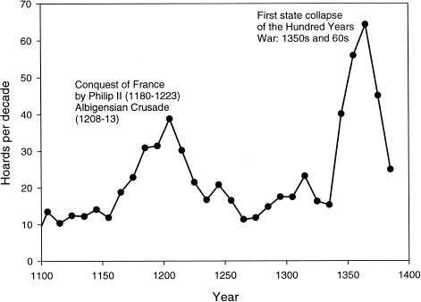

图 4.2 法国钱币储藏的时间分布，1100-1385 年（Duplessy 1985）。

Figure 4.2 Temporal distribution of the French coin hoards, 1100–1385 (Duplessy 1985).

## 4.2 扩张（1150-1250）

## 4.2 Expansion (1150–1250)

中世纪时期的人口统计数据很难获得。表 4.1汇总了来自不同来源的对一个家庭中幸存儿童人数的几种估计。这是一个很好的统计数据，因为它整合了生育力和生存率（到成年），并且与人口增长率直接相关。不同地区和不同社会阶层的交叉比较是无效的，但每个数据集中的时间变化总体上是一致的。十世纪和十一世纪期间人口增长明显放缓（尽管数据非常粗略）。显而易见的是，在 12 世纪，更替率呈上升趋势（表 4.1）。

Demographic data are hard to come by for the medieval period. Table 4.1 gathers together several estimates on the number of surviving children in a family from various sources. This is a good statistic, because it integrates over fecundity and survival (to adulthood) and because it is directly related to the population growth rate. Cross comparisons of different localities and of different social strata are not valid, but temporal changes within each data set are in general agreement. There was apparently a slowing of population growth during the tenth and eleventh centuries (although the data are very crude). What is clear is that replacement rates tended to increase during the twelfth century (table 4.1).

During the twelfth and thirteenth centuries the population of France must have tripled from 6 million to 20 million (figure 4.1a). The economic base for this enormous population build-up had to come primarily from the expansion of cultivated lands. As a result of massive internal colonization, farmland expanded at the expense of heath, forest, and marsh. It is estimated that out of 26 million ha of forest cover in France in 1000, onehalf was destroyed by 1300 (Braudel 1988:140). To appreciate the magnitude of this land clearance, the total arable land of modern France is 18 million ha (CIA 2002). It is difficult to estimate, though, how much new land was actually brought into production. Estimates of the increase range from a conservative 40 percent to a more optimistic 100 percent (Carpentier and Le Mené 1996:158). The increase in cultivated area was probably accompanied by increased yields per unit of area. Thus, Carpentier and Le Mené (1996:161) suggest that yields increased from 3–4:1 before the twelfth century and 4–5:1 toward 1180. This translates into a 40 percent increase in *net* yield.

**表 4.1**

**TABLE 4.1**

法国每个家庭的平均孩子数量，800–1500

Average number of children per family in France, 800–1500

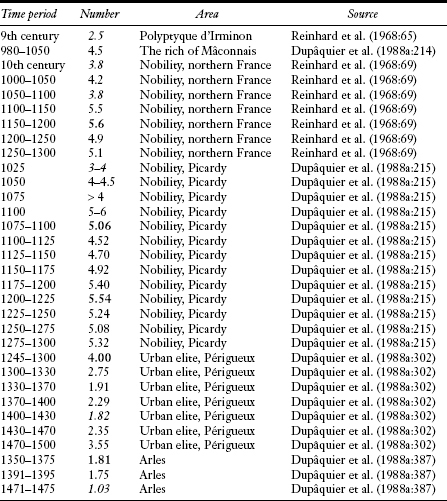

*注：*最大值为粗体，最小值为斜体。

*Note:* Maximum values are in bold, minimum values are in italic.

不断增长的人口，加上不断增长的生产力（或者至少，生产力不会因收益递减而下降——而且在 1250 年之前没有证据表明收益递减），应该会转化为健康的国家财政。事实上，在 1200 年左右的世纪，王室收入大幅增长。1202-3 年的账目显示，菲利普·奥古斯都的普通收入约为 115,000*里弗巴黎*(lp)，自 1180 年他统治以来，这些数字增加了 72%（Henneman 1999：104）。1202-3 年的总收入（包括针对金雀花王朝战争筹集的收入）达 196,327 镑（Hallam 和 Everard 2001：226）。到 1250 年，路易九世的固定年收入可能在 200,000 到 250,000 利普之间（Hallam and Everard 2001:311），是菲利普·奥古斯都的两倍。因此，实际收入大幅增长，因为粮食价格在 1200 至 1250 之间仅上涨了 20%（图 4.1b）。收入的增加支持了国家的扩张，从而带来了更多潜在的纳税人，形成了一种良性循环。这种动态可能解释了这一时期卡佩国家的爆炸性增长。

An expanding population, coupled with growing productivity (or, at least, productivity not decreasing as a result of diminishing returns—and there is no evidence of diminishing returns prior to 1250), should have translated into healthy state finances. Indeed, the century around 1200 saw a great expansion of royal revenues. Accounts for the year 1202–3 suggest that the ordinary revenues of Philip Augustus were about 115,000 *livres parisis* (l.p.), and that these had increased by 72 percent since the beginning of his reign in 1180 (Henneman 1999:104). Gross receipts in 1202–3 (including revenue raised for the war against the Plantagenets) amounted to 196,327 l.p. (Hallam and Everard 2001:226). Louis IX's fixed annual revenue was probably between 200,000 and 250,000 l.p. by 1250 (Hallam and Everard 2001:311), twice that of Philip Augustus. Thus, real revenues grew substantially, since the price of grain increased between 1200 and the 1250s by only 20 percent (figure 4.1b). Increasing revenues underwrote state expansion, which brought in more potential taxpayers, in a kind of a virtuous cycle. This dynamic probably explains the explosive growth of the Capetian state during this period.

## 4.3 滞胀（1250–1315）

## 4.3 Stagflation (1250–1315)

## **人口与经济**

## **Population and Economy**

在十三世纪下半叶的某个时候，农业生产的增长速度开始落后于人口的增长速度。1230 年至 1280 年间，大部分省份停止了土地开垦活动（Blaudel 1988:155，Carpentier and Le Mené 1996:331）。此后不久，即 1280 年至 1315 年之间的某个时间点，人口达到顶峰。不同当局对于高峰日期存在轻微分歧。最有可能的是，不同地区的峰值出现时间不同；没有理由期望完美的同步。例如，Carpentier 和 Le Mené (1996:314) 认为，迟至 1340 年，迷底人的人口可能仍在持续增长。

At some point during the second half of the thirteenth century, the rate of growth of agricultural production started to lag behind that of population. The reclamation of land ceased between 1230 and 1280 in most provinces (Braudel 1988:155, Carpentier and Le Mené 1996:331). Shortly thereafter—at some point between 1280 and 1315—the population reached its peak. There is mild disagreement among different authorities on the date of the peak. Most likely, different regions peaked at different times; there is no reason to expect a perfect synchrony. For example, Carpentier and Le Mené (1996:314) suggest that the population of the Midi may have continued to expand as late as 1340.

人口增长反映在物价上涨上（图4.1b）。小麦价格在整个 13 世纪不断上涨，但通货膨胀最严重的时期是从 1250 年代到 1310 年代，当时一公担小麦的价格从 24 克白银升至 66 克白银（Abel 1980）。中世纪法国没有系统的工资数据，但士兵的工资率表明，名义工资有所增加，尽管没有跟上通货膨胀的步伐（表4.2）。有趣的是，精英士兵和平民士兵的实际工资都下降了，但平民遭受的损失更大（我们在英国士兵的工资中看到了类似的动态；见第二章）。

Population growth was reflected in the rise of prices (figure 4.1b). The price of wheat increased through the thirteenth century, but the worst period of inflation was from the 1250s to the 1310s, when the price of a quintal of wheat went from 24 to 66 g of silver (Abel 1980). There are no systematic wage data for medieval France, but pay rates for soldiers suggest that nominal wages increased, although they did not keep pace with inflation (table 4.2). What is interesting is that the real wages declined for both elite and commoner soldiers, but the commoners suffered more (we saw a similar dynamic in the wages of English soldiers; see chapter 2).

|  | **表 4.2** **TABLE 4.2** |  |  |  |
| --- | --- | --- | --- | --- |
|  | 法国士兵的日薪 Daily rates of pay for soldiers in France |  |  |  |
|  | *工资率* | *1202* | *1295* |  |
|  | 骑士 |  |  |  |
|  | 标称，lt Nominal, l.t. | 7秒。6天。 | 10 秒、12 秒 6 天，或 15 秒。 |  |
|  | 银色 In silver | 25.1克 | 41.8克 |  |
|  | 在小麦中 In wheat | 1.71 HL | 1.06 百升 |  |
|  | 步兵 |  |  |  |
|  | 标称，lt Nominal, l.t. | 10 天。 | 12 天。 |  |
|  | 银色 In silver | 2.8克 | 3.3克 |  |
|  | 在小麦中 In wheat | 0.19 百升 | 0.08 百升 |  |
|  | *资料来源：* Contamine (1984:94)。 *Source:* Contamine (1984:94). *注：*单位：lt、*livretournois；*克，克；hl，百升；s.，苏；d. 否认者。 *Note:* Units: l.t., *livre tournois;* g, gram; hl, hectoliter; s., sou; d., denier. |  |  |  |

人口压力也转化为农民土地所有权的逐步分割。在多菲内 (Dauphiné)，75% 的农民拥有的农田不足 2 公顷；在埃诺，60% 的人持有 1 公顷或更少的土地（Carpentier 和 Le Mené 1996：328）。这个土地数量远远低于养活一个农民家庭所需的水平。对农民土地生产预算的估计表明，允许舒适离开的最小土地约为 6 公顷（Carpentier 和 Le Mené 1996：340）。假设采用三田系统，平均产量为 10 百升/公顷，则 6 公顷每年应产量 40 百升。由此农民必须缴纳十分之一的什一税和*土地*七分之一，留给他 30 HL。保留 8 升种子后，农民和家庭可支配的粮食为 22 升（16 公担）供个人消费，足够一家四到五口人食用。然而，只有一小部分农民（不到 20%）拥有 6 公顷或更多的土地（Carpentier 和 Le Mené 1996）。因此，绝大多数农户没有足够的土地来养活自己，他们的生存严重依赖于外出就业。这一过程的结果是产生了庞大且不断增长的农村无产阶级。由于徒劳地希望找到就业机会，许多农村贫困人口迁移到城镇，进一步压低了城市实际工资（Carpentier and Le Mené 1996：357），同时也推动了城市的显着增长。

The pressure of population also translated into progressive fragmentation of peasant land holdings. In Dauphiné, 75 percent of peasants had less than 2 ha of farmland; in Hainault, 60 percent held 1 ha or less (Carpentier and Le Mené 1996:328). This amount of land was far below the level needed to feed a peasant family. Estimates of the production budgets of peasant holdings suggest that the minimum land allowing a comfortable leaving was around 6 ha (Carpentier and Le Mené 1996:340). Assuming a three-field system and an average harvest of 10 hl/ha, 6 ha should yield 40 hl every year. From this the peasant had to pay the tithe of one-ninth and *terrage* of one-seventh, leaving him with 30 hl. After reserving 8 hl for seed, the peasant and the family had at its disposal 22 hl (16 quintals) of grain for personal consumption, enough for a family of four to five people. However, only a small minority of peasants, less than 20 percent, had land of 6 ha or more (Carpentier and Le Mené 1996). Thus, the huge majority of rural households did not have enough land to feed themselves, and their very existence critically depended on securing outside employment. The result of this process was a vast and growing rural proletariat. In a vain hope of finding employment, many of the rural poor migrated to towns, further depressing urban real wages (Carpentier and Le Mené 1996:357), as well as fueling the remarkable urban growth.

随着土地变得稀缺，其价格飙升。十三世纪初，诺曼底一英亩土地的价格为 2 里弗；一个世纪后，它的价格达到了20里弗。在皮卡第，十三世纪上半叶，一本*期刊*（约 0.4 公顷）的价格在 1 到 3 里弗之间，最多 4 里弗。*在本世纪下半叶，每本期刊的*价格超过 4 里弗，接近 1300 时，它们在 6 到 10 里弗之间波动。然而，存在一些地区差异。例如，在 Beamont-le-Roger，土地价格一直上涨到 1260 年，然后停滞到 1313 年。在 Beauce（沙特尔附近），土地价格实际上有下降的趋势。地租的上涨速度甚至快于价格的上涨。例如，在 1276 年至 1316 年间的短短四十年间，里尔周边的租金增加了五倍（Carpentier and Le Mené 1996:334, 336）。

As land became scarce, its price shot up. In Normandy an acre of land at the beginning of the thirteenth century cost 2 livres; a century later it went for 20 livres. In Picardy a price of a *journal* (approximately 0.4 ha) during the first half of the thirteenth century varied between 1 and 3, at most 4, livres. During the second half of the century, prices went above 4 livres per *journal*, and toward 1300 they fluctuated between 6 and 10 livres. There were some regional variations, however. At Beamont-le-Roger, for example, land prices rose until 1260 and then stagnated until 1313. In Beauce (near Chartres) there was actually a tendency for prices to decline. Land rents increased even faster than prices. For example, in just forty years between 1276 and 1316, rents around Lille increased fivefold (Carpentier and Le Mené 1996:334, 336).

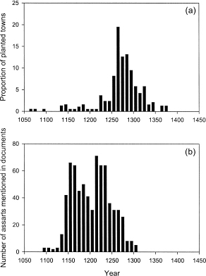

图4.3 城乡发展动态明显。(a) 种植城镇的动态（Beresford 1967）。(b) 文件中提到的 assart 数量（Fossier 1968）。

Figure 4.3 Distinct dynamics of urban and rural development. (a) Dynamics of planted towns (Beresford 1967). (b) Number of assarts mentioned in documents (Fossier 1968).

在此期间，虽然农村人口增长越来越缓慢并最终停滞不前，但城市人口却迅速增长。13 世纪出现了大量新城镇，1250 年后城市发展速度尤其疯狂（图 4.3a）。法国加斯科涅以外 70% 以上的种植城镇出现在滞胀时期 (1250-1315) (Beresford 1967)。因此，按照文件中提到的 assart 数量来衡量（图 4.3b），农村发展先于城市发展。农村土地清理集中在扩张阶段，而城市扩张大部分属于滞胀阶段。

While the rural population grew ever more slowly and eventually stagnated during this period, the urban population increased rapidly. Large numbers of new towns appeared during the thirteenth century, with a particularly frenetic pace of urban development after 1250 (figure 4.3a). Over 70 percent of planted towns in France outside Gascony appeared during the stagflation period (1250–1315) (Beresford 1967). Rural development, as measured by the number of assarts mentioned in the documents (figure 4.3b), thus preceded urban development. Rural land clearance was concentrated in the expansion phase, while the bulk of urban expansion fell within the stagflation phase.

十三世纪期间，巴黎人口翻了一番（图 4.4a），并在下个世纪继续增加。人口在 10,000 到 20,000 之间的城市数量增加到 20 个左右，而人口在 20,000 到 50,000 之间的城市有十几个（Carpentier 和勒梅内 1996：317）。城市的发展部分是由于农村地区移民的涌入，部分是由于贸易和手工艺的增加。但城墙也提供了保护，随着社会政治不稳定的加剧，越来越多的农村居民放弃暴露的*工资*，搬到相对安全的设防城镇和城市。

During the thirteenth century the population of Paris doubled (figure 4.4a), and it kept on increasing during the next century. The number of cities having populations between 10,000 and 20,000 increased to twenty or so, and there were a dozen in the 20,000–50,000 range (Carpentier and Le Mené 1996:317). Cities grew partly because of the influx of migrants from rural areas, partly because of increasing trade and crafts. But city walls also offered protection, and as sociopolitical instability increased, growing numbers of rural dwellers abandoned exposed *plat pays* and moved to the relative safety of fortified towns and cities.

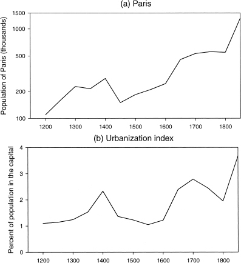

图 4.4 法国城市化动态，1200-1850 年。(a) 巴黎人口（Chandler 1987）。(b) 城市化指数（定义为首都人口比例）。

Figure 4.4 Dynamics of urbanization in France, 1200–1850. (a) Population of Paris (Chandler 1987). (b) An index of urbanization (defined as the proportion of the population in the capital).

## **精英生产过剩**

## **Elite Overproduction**

尽管主要是轶事，但有大量证据表明精英生产过剩在滞胀阶段结束时发展，例如乔纳森·萨普蒂恩（Jonathan Sumption）（1991：30-32）所总结的。主要问题是小贵族的特点是“他们的财产很少，是几代人虔诚的遗赠和家庭分割的结果。即使在理论上实行法治的法国西部和北部，长子继承权也从未被严格适用。在其他地方，它甚至没有被原则上接受。结果，到了十四世纪初，许多小贵族的财产已经减少到几乎无法耕作的地块”（Sumption 1991：31）。法兰西岛的情况尤其严峻。巴黎修道院和王室的至少四分之一的贵族封臣的年收入低于 10 里弗（Guy Fourquin 的数据，引自 Sumption 1991:31）。许多小贵族将自己的土地抵押或卖给富农。

There is abundant, although largely anecdotal, evidence of elite overproduction developing toward the end of the stagflation phase, summarized, for example, by Jonathan Sumption (1991:30–32). The main problem of minor noblemen was “the smallness of their holdings, the result of generations of pious bequests and family partitions. Primogeniture was never rigidly applied even in the west and north of France, where it was theoretically the rule of law. Elsewhere, it was not even accepted in principle. As a result, by the beginning of the fourteenth century the holdings of much of the lesser nobility had been reduced to barely workable parcels” (Sumption 1991:31). The situation was particularly dire in Ile-de-France. At least a quarter of the noble vassals of the Parisian abbeys and the Crown had an annual income of less than 10 livres (data of Guy Fourquin, cited in Sumption 1991:31). Many petty nobles mortgaged their land or sold it to rich peasants. “In the century to come the survivors of this pauperized gentry would turn to war for their living and finally to brigandage” (Sumption 1991:32).

## **国家**

## **The State**

During the stagflation period royal revenues increased in nominal terms but could not keep up with inflation. Louis IX's ordinary revenues were around 0.25 million l.t. around 1250 (Kaeuper 1988:62, Henneman 1999:104). By the late thirteenth century the annual income of Philip IV had climbed to between 0.4 and 0.6 million l.t. (Kaeuper 1988). Thus, nominal income perhaps doubled, but prices also doubled. Philip's son Charles IV (1322–28) received average net ordinary revenues of 0.28 million l.t., which in real terms amounted to only 53 percent of what his father had enjoyed thirty years earlier (Henneman 1999:109). The accession of Philip VI (1328–50) brought the vast appanage of the Valois family into the royal domain, but his ordinary revenues (in real terms) amounted to only 80 percent of those available to Philip IV (Henneman 1999:109).

## 4.4 危机（1315–65）

## 4.4 Crisis (1315–65)

## **人口锐减**

## **Population Collapse**

到了十四世纪初，法国以及西欧大部分地区都挤满了人。“生态系统”（用勒罗伊·拉杜里的术语）已经紧张到了崩溃的边缘，濒临崩溃。十四世纪经历的崩溃是饥荒、瘟疫和战争典型串联的结果。

By the early fourteenth century, France, as well as most of Western Europe, was literally crammed with people. The “ecosystem” (to use Le Roy Ladurie's term) was strained to the breaking point and on the verge of collapse. The collapse experienced during the fourteenth century was the result of a typical concatenation of famine, pestilence, and war.

饥荒首先袭来。到了十四世纪初，农业生产仅够维持人口的生计，大多数人的食物仅够维持生计。饥荒在十三世纪几乎消失了，但在十四世纪却一再出现。1302 年，第一次严重饥荒袭击了法国（卡彭蒂埃和 Le Mené 1996:353），但人口持续下降很可能是在 1315-17 年的多年饥荒之后开始的。事实上，在 1315-30 年期间，一系列可怕的冬天带来了饥荒，这是下个世纪即将到来的麻烦的一个令人震惊的警告信号（布罗代尔 1988：154-55）。

Famine struck first. By the early fourteenth century, agricultural production was barely enough to provide sustenance for the population, and the majority had just enough food to live. Famines had practically disappeared during the thirteenth century, but they returned again and again during the fourteenth. The first important famine hit France in 1302 (Carpentier and Le Mené 1996:353), but the sustained population decline most likely began after the multi-annual famine of 1315–17. In fact, during 1315–30 a series of terrible winters brought famine in, an alarming warning sign of the troubles to come during the following century (Braudel 1988:154–55).

第二次打击是黑死病带来的。第一波黑死病于 1348-49 年席卷法国。四分之一半的人口死亡，在某些情况下是 80% 至 90%，具体取决于地区（Braudel 1988：157）。在本世纪余下的时间里，法国每隔大约十年就会遭受一次鼠疫疫情的反复袭击。例如，里昂继 1348-49 年之后的第二高死亡率峰值是在 1361 年（Lorcin 1974）。

The second blow was delivered by the Black Death. The first wave of bubonic plague swept France in 1348–49. Between a quarter and a half, and in some cases 80–90 percent, of the population perished, depending on the region (Braudel 1988:157). Recurrent plague epidemics were to hit France at intervals of roughly a decade during the rest of the century. For example, the second highest mortality peak in Lyon after 1348–49 was in 1361 (Lorcin 1974).

瘟疫给穷人带来了不成比例的死亡率。例如，1343 年至 1357 年间，阿尔比的赤贫人口（拥有的财产估计少于 50 里弗）的比例从 76% 下降到 62%。与此同时，中产阶级（50-200 里弗）从 21% 增加到 28.5%，富人（超过 200 里弗）的比例翻了一番，从 4.2% 增加到 8.1%（Dupâquier et al. 1988a:323）。因此，瘟疫的后果之一就是社会金字塔的扭曲，使其比瘟疫之前更加头重脚轻（我们在英国数据中看到了同样的模式）。

The plague imposed a disproportionate mortality on the poor. For example, at Albi between 1343 and 1357 the proportion of the very poor (owning possessions estimated at less than 50 livres) fell from 76 percent to 62 percent. At the same time, the middle stratum (50–200 livres) increased from 21 percent to 28.5 percent, and the proportion of the rich (over 200 livres) doubled from 4.2 percent to 8.1 percent (Dupâquier et al. 1988a:323). Thus, one consequence of the plague was a distortion of the social pyramid, making it even more top-heavy than it was before the plague (we saw the same pattern in the English data).

即使缺乏精确的定量估计，人们也能以定性的方式很好地理解 14 世纪饥荒、疾病以及战争对人口动态的影响（Dupâquier 等人，1988a）。与其他西欧政体一样，法国人口在公元 1300 年之后开始下降，然后在 1348 年黑死病流行之后经历了急剧下降，随后由于流行病复发（如 1361 年）和战争而进一步减少。百年战争愈演愈烈。总人口数量减少了约一半（Dupâquier et al. 1988b:149），从 2000 万减少到 1000 万。此后大约一个世纪的时间里，人口数量一直在低水平波动，直到十五世纪下半叶才开始增加。

The effects of famine and disease, as well as war, on the population dynamics during the fourteenth century are well understood in a qualitative way, even if precise quantitative estimates are lacking (Dupâquier et al. 1988a). The French population, like that in other Western European polities, began declining after 1300 CE, then experienced a precipitous drop in the wake of the Black Death epidemic of 1348, followed by further losses as epidemics recurred (as in 1361) and fighting in the Hundred Years’ War intensified. Overall population numbers declined by about one-half (Dupâquier et al. 1988b:149), from 20 million to 10 million. After that, for about a century population numbers fluctuated at a low level, starting to increase only during the second half of the fifteenth century.

尽管十四世纪的危机带来了许多苦难，但人口锐减也产生了一些积极的影响，至少对下层来说是这样。马尔萨斯压力的放松给农民和工人带来了经济救济。除了特别激烈的战争时期外，普通民众的实际工资和消费水平在 14 世纪末显着提高（表 4.3）。1338 年，在领主的保护区工作的普罗旺斯牧羊人吃的是一种主要用大麦制成的非常粗糙的面包。黑死病之后，大麦面包被认为只适合牧羊犬，而劳动者有权吃小麦面包（Le Roy Ladurie 1987：70）。

Although the crisis of the fourteenth century brought much misery, the population collapse had also some positive effects, at least for the lower strata. A relaxation of Malthusian pressure brought economic relief to peasants and workers. Apart from periods of particularly intense warfare, real wages and the consumptions levels of ordinary people improved dramatically toward the end of the fourteenth century (table 4.3). In 1338 the Provençal drovers working on their lord's reserve ate a very crude kind of bread made mainly with barley. After the Black Death, barley bread was considered to be good enough only for the sheepdogs, while the laborers were entitled to wheat bread (Le Roy Ladurie 1987:70).

|  | **表 4.3** **TABLE 4.3** |  |  |  |
| --- | --- | --- | --- | --- |
|  | 日工资（标准），1320–1500 Daily wages (s.t.), 1320–1500 |  |  |  |
|  | *年* | *鲁昂的建筑工人* | *步兵* |  |
|  | 1320 | 1.5 | 1.0 |  |
|  | 1350 | 3.5 | 2.0 |  |
|  | 1380 | 4.0 | 5.2 |  |
|  | 1410 | 3.8 | 3.3 |  |
|  | 1440 | 4.5 | 2.7 |  |
|  | 第1470章 | 4.0 | 2.7 |  |
|  | 1500 | 4.5 | 3.4 |  |
|  | *资料来源：* Bois (1984) 和 Contamine (1984)。 *Source:* Bois (1984) and Contamine (1984). |  |  |  |

## **领主与农民**

## **Lords and Peasants**

As we noted earlier, the beginning of the fourteenth century in France was characterized by elite overproduction. As the amount of surplus produced by peasants was shrinking, an example of the law of diminishing returns in action, the number of elites who were supported by the surplus was increasing. “To preserve caste, the lord was compelled to draw more, on peasant production, and by other means. On the other hand, any additional drain endangered the ability for self-subsistence of the peasant holding. The contradiction was insoluble and disruptive” (Bois 1984:260). The population decline of the years 1315–50 further exacerbated this basic contradiction. The post-1315 famines affected mainly the poorest strata of the society, and although many noblemen died in the plague, it had a disproportionate effect on the poor. As a result, the proportion of elites to the general population increased even beyond the already high levels of the early fourteenth century.

用盖伊·博伊斯的话说，随着收入下降，精英们不得不寻求“其他方式”来维持他们的种姓。最终的结果是精英内部对稀缺资源的冲突加剧。受到打击尤其严重的是贫困贵族。即使在 13 世纪，福雷兹的许多小贵族也靠 25*里弗维也纳生活*（5 英镑）或更少（Perroy 1962：28）。随着食品价格翻倍（甚至在1310年代翻了三倍），这些贵族家庭的消费水平跌破了与贵族身份相符的最低水平。事实上，在十四世纪初期的饥荒期间，一些贵族家庭一定已经挨饿了。到了本世纪中叶，实际上已经有数以万计的处于战斗年龄的贫困而绝望的贵族。Philippe Contamine (1997:204)估计，1340年，有25,000名甚至30,000名贵族涌入菲利普六世的军队，希望获得军饷（9月份有27,000名骑兵在皇家军队服役）1340 [Sumption 1991]）。国王和他的副官们似乎对响应他们的战斗号召而响应的大量武装人员感到惊讶，甚至感到不安（Contamine 1972：73）。这些无组织、无纪律的人群是导致法国队随后在克雷西和普瓦捷惨败的因素之一。大量绝望且受过使用武器训练的人的存在是一个巨大的不稳定因素。

As their incomes declined, the elites had to look to “other means,” in Guy Bois's words, to preserve their caste. The end result was intensification of the intraelite conflict for scarce resources. Particularly hard hit were the poorer nobles. Even in the thirteenth century a great number of the lesser gentry in Forez lived on 25 *livres viennois* (£5) or less (Perroy 1962:28). As the food prices doubled (or even tripled, as in the 1310s), these noble households slipped below the minimum level of consumption consistent with noble status. Indeed, some noble households must have starved during the famines of the early fourteenth century. By mid-century there were literally tens of thousands of destitute and desperate noblemen of fighting age. Philippe Contamine (1997:204) estimates that 25,000 if not 30,000 nobles flocked to the army of Philip VI in 1340 in the hope of military pay (there were 27,000 cavalrymen serving in the royal army in September 1340 [Sumption 1991]). It appears that the king and his lieutenants were surprised, even disconcerted by the huge numbers of men-at-arms responding to their call to arms (Contamine 1972:73). This disorganized and undisciplined crowd was one of the factors contributing to the subsequent French defeats at Crécy and Poitiers. The presence of huge numbers of men desperate and trained in the use of arms was a tremendous destabilizing factor.

精英生产过剩并不仅限于军事阶层。“从 1314 年到 1343 年，巴黎各个皇家法院的主要司法官员的数量增加了四倍；公证人的数量大致相同；强制执行国王大臣和法官命令的“军士”增加了七倍”（Sumption 1991：19）。

Elite overproduction was not limited to the military class. “Between 1314 and 1343 the number of principal judicial officers of the various royal courts in Paris increased fourfold; the number of notaries by about the same; the ‘sergeants’ who enforced compliance with the orders of the King's ministers and judges increased sevenfold” (Sumption 1991:19).

## **国家崩溃**

## **State Collapse**

在精英内部竞争和冲突加剧的同时，国家也逐渐丧失维持内部和平和保护国家免受外来侵略的能力。主要问题是财务问题。在腓力四世（1270-1314 年）统治之前，王室靠普通收入生活毫无困难，偶尔还会征收特别征税（例如，路易九世在埃及十字军东征时被俘时需要赎回）。然而，到了十三世纪末，按实际价值计算的普通收入停滞不前，而支出，特别是军事行动的支出却猛增。为了增加收入，菲利普四世利用他的封建权利，要求补贴，向资产阶级强制贷款，并操纵货币（Henneman 1999：105-6）。这些方法引起了很多人的不满，十四世纪上半叶，不同精英阶层对税收的抵制日趋强烈。基本且本质上无法解决的问题是国家与精英争夺日益萎缩的盈余。因此，我们应该把盖伊·布瓦的地主与农民的二元矛盾修改为生产阶级—精英—国家的三元矛盾。

At the same time that the intensity of intraelite competition and conflict was rising, the state was gradually losing its ability to keep internal peace and protect the country from external invasion. The main problem was financial. Before the reign of Philip IV (1270–1314), the Crown had no difficulty living off its ordinary revenues, and occasionally collecting extraordinary levies (needed, for example, to ransom Louis IX when he was captured while on crusade in Egypt). By the end of the thirteenth century, however, the ordinary revenues had stagnated in real terms, while expenses, especially for military operations, soared. To raise revenues, Philip IV exploited his feudal rights, demanded subsidies, imposed forced loans on the bourgeois, and manipulated the currency (Henneman 1999:105–6). These methods incurred much resentment, and the first half of the fourteenth century saw increasing resistance to taxation on behalf of various elites. The basic and essentially unresolvable problem was that the state competed with the elites for the shrinking surplus. Thus, we should modify the binary contradiction of Guy Bois, that between lord and peasant, to a trinary contradiction of the productive class–the elites–the state.

对国家征税的必要性缺乏共识，直接影响了国家对英国发动战争的能力。腓力六世（1328-50）和约翰二世（1350-64）除了在彻底冲突的时候之外无法收取补贴，并且一直处于财务困境中（Henneman 1999：110）。因此，每当休战后恢复军事行动时，法国总是措手不及。1346 年和 1347 年的军事灾难（克雷西战败、加来失陷）最终说服了三级会议在 1355-56 年授权征收必要的税收，但现在他们的征税尝试遭到了地方层面的抵制。最终，庄园未能兑现承诺的资金（亨尼曼 1999：111）。王室财政崩溃后不久，法国国家全面崩溃，这是由约翰二世在普瓦捷的失败和俘虏引发的（1356年）。

The lack of consensus on the need for national taxation had a direct effect on the ability of the state to wage war against the English. Philip VI (1328–50) and John II (1350–64) were unable to collect subsidies except in times of outright conflict, and were in a constant state of financial distress (Henneman 1999:110). As a result, France was always unprepared whenever military operations resumed after a truce. The military disasters of 1346 and 1347 (the defeat at Crécy, the loss of Calais) finally persuaded the Estates General in 1355–56 to authorize necessary taxation, but now their attempts to impose taxes ran into resistance at the local level. In the end, the Estates were unable to produce the money they had promised (Henneman 1999:111). The collapse of royal finances was followed shortly by a general collapse of the French state, triggered by the defeat and capture of John II at Poitiers (1356).

|  | **表 4.4** **TABLE 4.4** |  |  |  |
| --- | --- | --- | --- | --- |
|  | Cerisy（诺曼底）官方的攻击动态 Dynamics of assaults in the Officiality of Cerisy (Normandy) |  |  |  |
|  | *时期* | *每年的袭击次数* | *涉及使用武器的百分比* |  |
|  | 1314–1346 | 1.2 | 2 |  |
|  | 1370–1414 | 4.9 | 25 |  |
|  | 1451–1458 | 4.3 | 40 |  |
|  | 1471–1486 | 0.7 | 8 |  |
|  | *资料来源：*芬奇 (1997)。 *Source:* Finch (1997). |  |  |  |

The disintegrative phase of the Capetian cycle was dominated by a conflict known as the Hundred Years’ War. The Hundred Years’ War was not simply a dynastic conflict between the French and English kings but a period of great political instability primarily within France (Salmon 1976). As Braudel suggests (1988:159), it would be more appropriate to call it a “hundred years of hostilities rather than a hundred-year-war”—a period of recurrent state collapse and civil war. The conflict occurred at multiple levels. The highest-level factions were led by the great seigneurs of France—the king himself, the duke of Guyenne (who also was the king of England), the duke of Burgundy, and the count of Flanders. From there the level of conflict descended through the magnates (counts and barons) and various factions of nobility, down to knights and peasants. This multilevel nature of the conflict can be illustrated with the example of later medieval Gascony (Vale 1986). At the “national” level, Gascony was one of the military frontiers in the Anglo-French struggle. At the regional level, the period from 1290 to the middle of the fifteenth century was dominated by the feud between the houses of Armagnac and Foix over the succession of the viscounty of Béarn. At a more local level, private wars between lesser nobility proliferated in Gascony. Between 1290 and 1327, for example, at least twelve outbreaks of intraelite violence are recorded in surviving sources (Vale 1986:140). And then there were numerous bands of *routiers* and *écorcheurs* who robbed and killed indiscriminantly both lords and peasants or ran “protection rackets” from castles, fortified churches, and manor houses (Wright 1998).

人际暴力（即犯罪）与有组织的暴力同时增加。至少一个地方的暴力犯罪统计数据表明，14 世纪曾出现过一次犯罪浪潮，在 1400 年左右达到顶峰，并在 15 世纪下半叶消退（表 4.4 ）。

Interpersonal violence—crime—increased in parallel with organized violence. Statistics on violent crimes in at least one locality indicate there was a crime wave during the fourteenth century that peaked around 1400 and subsided by the second half of the fifteenth century (table 4.4).

## **社会政治不稳定的动态（1290-1365）**

## **The Dynamics of Sociopolitical Instability (1290–1365)**

十四世纪的社会政治危机在法国逐渐发展。1300 年左右，边境地区出现了不稳定加剧的最初迹象。我们已经讨论过 1290 年以来加斯科涅秩序的崩溃。在王国的另一端，城市化的佛兰德斯，社会冲突首先在 1279 年至 1281 年爆发，后来在 1300 年左右爆发。问题的根源似乎是老牌城市贵族与新富裕的资产阶级之间的紧张关系。将无产阶级用作突击部队（Carpentier and Le Mené 1996：356）。最终，权力斗争导致了全面的叛乱和 1302 年的考特莱战役（“马刺之战”），佛兰德斯步兵击败了法国贵族骑兵。1325-26 年，佛兰德斯的城市社区起来反抗他们的统治者，讷韦尔的路易伯爵。市民们在卡塞尔战场被法军屠杀（1328年），佛兰德斯暂时得到平定。然而，1337年，佛兰德人再次起义，并在根特的范·阿尔特维尔特的领导下驱逐了讷韦尔的路易（Perroy 1965）。佛兰德斯叛乱为爱德华三世领导下的英国入侵开辟了北方路线。

The sociopolitical crisis of the fourteenth century developed in France by degrees. The first signs of growing instability appeared in the frontier regions toward 1300. We have already discussed the collapse of order in Gascony from 1290 on. At the opposite end of the kingdom, in urbanized Flanders, social conflicts first broke out between 1279 and 1281 and later around the year 1300. The origin of the troubles seems to have been tensions between the established urban patriciate and the newly enriched bourgeoisie, who used the proletariat as shock troops (Carpentier and Le Mené 1996:356). Eventually the struggle for power led to a fullblown rebellion and the battle of Courtrai (“the Battle of the Spurs”) in 1302, when Flemish infantry crushed aristocratic French cavalry. In 1325–26 the urban communities of Flanders rose against their ruler, Count Louis of Nevers. The burghers were massacred by the French army at the field of Cassel (1328), and Flanders was temporarily pacified. However, in 1337 the Flemish revolted again and, under the leadership of van Arteveldt of Ghent, expelled Louis of Nevers (Perroy 1965). The Flemish rebellion opened the northern route for the English invasion under Edward III.

与此同时，法国其他地区的不稳定局势也日益加剧。法国北部和东部（皮卡第、勃艮第）是路易十世 (1314-16 年) 统治时期反对王室征税的贵族运动的所在地。在阿图瓦县，阿图瓦的罗伯特和他的姨妈马豪的追随者之间的自相残杀使反对中央权力的叛乱变得更加复杂，他们都声称拥有该县（Hallam and Everard 2001：392-93）。阿图瓦的罗伯特在这场斗争中失败，最终流亡英国，在那里他加入了那些敦促爱德华三世对法国宣战的人的行列。但布列塔尼事件对百年战争的进程产生了更直接的影响。1341年，布列塔尼公爵约翰三世去世，没有直接继承人。布卢瓦和蒙福特两个派系之间的继承权存在争议。在随后的内战中，小贵族和凯尔特西部支持蒙福特家族，而东部的大领主和法语资产阶级则团结到布卢瓦派系。英国人发起了一场支持蒙福特派的运动。*chevauchée*（一场骑马袭击，其目的是蹂躏国家）并围困雷恩、瓦纳和南特（Seward 1978：49）。

Meanwhile, other regions of France were also experiencing increasing instability. The north and east of France (Picardy, Burgundy) were sites of the baronial movement against royal taxation during the reign of Louis X (1314–16). In the county of Artois, the revolt against the central power became complicated by internecine fighting between the adherents of Robert of Artois and his aunt Mahaut, who both claimed the county (Hallam and Everard 2001:392–93). Robert of Artois lost the struggle and eventually ended up in exile in England, where he joined his voice to those urging Edward III to go to war against France. But the events in Brittany had a much more direct effect on the course of the Hundred Years’ War. In 1341, Duke John III of Brittany died without direct heirs. The succession was disputed between two factions, Blois and Monfort. In the ensuing civil war the lesser nobles and the Celtic west supported the Monforts, while the great lords and the French-speaking bourgeois of the east rallied to the Blois faction. The English supported the Monfort faction by launching a *chevauchée* (a mounted raid whose purpose was to lay waste to the country) and besieging Rennes, Vannes, and Nantes (Seward 1978:49).

另一个派别出现在1350年代。它由纳瓦拉国王坏人查理和埃夫勒的菲利普领导，他是法国琼的儿子（因此是路易十世的孙子，这使他对法国王位有合理的要求）。该派别有时被称为埃夫勒派，有时被称为纳瓦拉派。坏人查理继承了大量遗产他在诺曼底和法兰西岛拥有土地，并为这些地区的持不同政见的贵族提供了领导。从1354年谋杀法国警察（首席军事长官）到1364年他在诺曼底和法兰西岛的派系叛乱被查理五世镇压，坏人查理一直具有破坏性影响。

Another faction arose in the 1350s. It was led by Charles the Bad, the king of Navarre, who was son of Joan of France (and therefore a grandson of Louis X, giving him a reasonable claim on the French throne) and Philip of Évreux. This faction was sometimes referred to as the Évreux faction and sometimes as the Navarrese. Charles the Bad inherited substantial landholdings in Normandy and Ile-de-France, and he provided leadership to the dissident nobilities of these regions. Charles the Bad was a disruptive influence from 1354, when he murdered the French Constable (the chief military officer), to 1364, when the rising of his faction in Normandy and Ile-de-France was suppressed by Charles V.

These examples of internecine fighting (to which we should add the later factional conflict between the Armagnacs and the Burgundians) illustrate the thesis, generally supported by modern historians, that the Hundred Years’ War was primarily an internal conflict. The international aspect of the war arose primarily (if not solely) because various rival factions appealed to the kings of England or France. Thus, the Monfort and Arteveldt factions invited Edward III to intervene in Brittany and Flanders, respectively. It was supposedly Jan van Arteveldt who suggested that Edward III should declare himself the king of France, in order to legitimize the Flemish support. Another example of the same trend is the resumption of war in 1369, which resulted from the appeal to Charles V by the count of Armagnac against the Black Prince. Finally, the darkest period of the war for the French, 1420–36, came about as a result of the alliance of the Burgundians and the English.

精英内部的冲突随之引发了一系列其他叛乱和起义，其中我们仅提及其中两个，即巴黎叛乱和雅克利叛乱。1357 年，王太子（未来的查理五世）因其父亲在普瓦捷被捕而成为国家元首，但他却将巴黎输给了由富有的布商艾蒂安·马塞尔领导的城市精英联盟。在起义期间，巴黎暴徒在王太子面前谋杀了两名皇家元帅。顺便说一句，巴黎的马塞尔派与另一位麻烦制造者纳瓦拉的查理四世结盟。1357-58 年冬天，盎格鲁-纳瓦拉帮派“日复一日地征服并蹂躏卢瓦尔河和塞纳河之间的整个地区”（Froissart，引自 Fourquin 1978：136）。除了君主政体的财政需求和领主的反动之外，武装人员的掠夺，将法兰西岛的农民推向了崩溃的边缘。Jacquerie运动始于1358年5月，6月遭到贵族镇压（Fourquin 1978：134-36）。

Intraelite conflicts brought a host of other rebellions and uprisings in their wake, of which we will mention only two, the Paris rebellion and the Jacquerie. In 1357 the dauphin (future Charles V), who was the head of state as a result of his father's capture at Poitiers, lost Paris to a coalition of urban elites led by the wealthy cloth-dealer Etienne Marcel. During the revolt the Paris mob murdered two royal marshals in front of the dauphin. Incidentally, the Marcel faction in Paris was allied with another troublemaker, Charles the Bad of Navarre. During the winter of 1357–58 the gangs of Anglo-Navarrese “were day by day conquering and laying waste the entire region between the Loire and Seine” (Froissart, cited in Fourquin 1978:136). The pillaging by men-at-arms, on top of the fiscal demands of the monarchy and the seigneurial reaction, pushed the peasants of Ile-de-France beyond the breaking point. The Jacquerie started in May 1358 and was suppressed by the nobles in June (Fourquin 1978:134–36).

1356-60 年是最低谷。贵族们对国家崩溃感到震惊，开始在皇太子周围进行巩固，并就财政改革达成了普遍共识（Henneman 1999：112）。征税的直接刺激因素是需要为在普瓦捷被捕的约翰二世支付巨额赎金。然而，1360 年 12 月 5 日的法令成为法国财政史上的一个里程碑（Henneman 1999：113），建立了旧政权的基本框架。它对其他类型的消费征收盐税（*gabelle*）和间接（销售）税（*aides*）。三级会议同意另一种重要的新税，称为 *fouage*（壁炉税）。直接税，例如后来更名为*尾税的**福阿税*，成为法国王室税收的悠久传统。间接税主要影响城市人口，而直接税（例如*森林税）则主要影响城市人口。*也对乡村领主产生了影响。它不受贵族欢迎，但他们并没有引起太大的反对，因为这种税的主要目的是支付军饷。事实上，令人惊讶的是，对新税种的反对如此之少。赎回国王的需要显然是一个因素（最终，赎金总额从未支付；相反，查理五世政府明智地使用这笔钱建立了一支新军队）。也许更重要的是集体认识到必须采取一些行动，否则法国就会失败。另一个促成因素是战争对法国贵族的大规模“修剪”。最严重的灾难是克雷西灾难，“法国贵族之花”中的 10,000 人丧生，普瓦捷又损失了 2,500 人。斯鲁伊斯海战（1340 年）中有数千人死亡。法兰西岛的*雅克。*简而言之，到了 1360 年，闹事的“贵族暴徒”少了很多——有些人被杀了，另一些人继承了被杀亲属的财产。公众舆论倾向于和平的倾向在有关战争和骑士精神的文学的新基调中显而易见。早些时候，重点是私人战争的权利以及追求荣誉和荣耀，现在它解决了纪律和公共秩序的问题（Henneman 1996：142）。然而，我们不应该高估这一共识的力量。它持续了二十年，即1360年代和1370年代；当没有直接经历1356-60年崩溃的新一代上台时，事情再次分崩离析。

The years 1356–60 were the nadir. Shocked by the state collapse, the nobility started to consolidate around the dauphin and achieved a general consensus on fiscal reform (Henneman 1999:112). The immediate stimulus for imposing taxes was the need to pay the huge ransom for John II, who had been captured at Poitiers. However, the ordinance of 5 December 1360 became a landmark in French fiscal history (Henneman 1999:113), establishing the basic framework of the ancien régime. It imposed the salt tax (*gabelle*) and indirect (sales) taxes on other types of consumption (*aides*). The Estates General agreed to another important new tax known as the *fouage* (the hearth tax). Direct taxes, such as the *fouage*, later renamed *taille*, became a long tradition in French royal taxation. Whereas indirect taxes primarily affected the urban population, direct taxes such as the *fouage* also bore on rural lordships. It was not popular with the nobility, but they did not raise much opposition because the primary purpose of this tax was to pay military salaries. In fact, it may appear surprising how little opposition there was to new taxes. The need to ransom the king was clearly one factor (in the end, the whole amount of ransom was never paid; instead, the government of Charles V wisely used the money to build a new army). Perhaps even more important was the collective realization that something had to be done or France would be lost. Another contributing factor was the massive “pruning” of the French nobility administered by the war. The worst disaster, that of Crécy, wiped out 10,000 of the “flower of the French nobility,” and Poitiers accounted for another 2,500. Some thousands died at the naval battle of Sluys (1340). And unknown thousands died in the local civil wars and at the hands of the *jacques* of Ile-de-France. In short, by 1360 there were simply many fewer “noble thugs” to raise trouble—some had been killed off, others had inherited the property of their slain relatives. The swing in public opinion in favor of peace is evident in the new tone of the literature on warfare and chivalry. Whereas earlier the emphasis had been on the right to private war and the pursuit of honor and glory, now it addressed questions of discipline and public order (Henneman 1996:142). We should not, however, overestimate the strength of this consensus. It lasted for two decades, the 1360s and 1370s; when the new generation, which did not directly experience the collapse of 1356–60, came to power, it allowed things to fall apart again.

当查理五世于 1365 年成为国王时，国家的巩固，即使是暂时的，也导致英国失去的领土迅速收复。与前任统治时期庞大且缺乏纪律的人群不同，查理五世的军队仅由 2,400 名武装人员和 1,000 名弩手组成，其中 60% 是骑兵（Contamine 1972:138）。这些部队被永久雇用并定期领取工资。在活动特别激烈的时期，常备部队会得到补充的武装近卫军的加入（使总数达到最多 5,200 人）。新军队的第一次军事胜利是在1364年春天粉碎了诺曼底埃夫勒派（由坏人查理领导）的军队（Henneman 1999：115）。1369年，由于阿马尼亚克伯爵的呼吁，与英国的战争重新开始，1380 年查理五世去世之前，几乎所有法国领土都被收复。英国人只占领了波尔多、巴约讷、布雷斯特、加莱、瑟堡和瓦莱及其周边地区。

When Charles V became king in 1365, the national consolidation, even if temporary, resulted in a rapid recovery of the territory lost to the English. Unlike the huge and undisciplined throngs of the previous reign, the army of Charles V consisted of only 2,400 men-at-arms and 1,000 crossbowmen, of which 60 percent were mounted (Contamine 1972:138). These troops were permanently employed and regularly paid. The permanent forces were joined during periods of particularly intense activity by supplementary retinues of men-at-arms (bringing the total to the maximum of 5,200). The first military success of the new army was in crushing the forces of the Évreux faction in Normandy (led by Charles the Bad) in the spring of 1364 (Henneman 1999:115). In 1369 the war with the English resumed as a result of the appeal by the count of Armagnac, and before the death of Charles V in 1380 almost all French territory was regained. The English held only Bordeaux, Bayonne, Brest, Calais, Cherbourg, and Valais and their immediately surrounding territory.

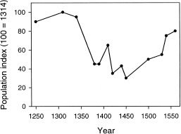

图 4.5 诺曼底的人口动态，1250-1560 年（Bois 1984 之后）。

Figure 4.5 Population dynamics in Normandy, 1250–1560 (after Bois 1984).

## 4.5 萧条（1365–1450）

## 4.5 Depression (1365–1450)

## **人口停滞**

## **Population Stagnation**

14 世纪中叶的灾难导致人口减少三分之一半后，法国进入了一个看似停滞的时期，直到 1450 年。然而，停滞并不意味着“稳定状态”。相反，这一时期的特点是短暂的复苏，然后是新的崩溃。这个过程可以用诺曼底的数据来说明（Bois 1984：76）。经历了三个危机时期，即1380年、1420年和1450年人口最低点，中间穿插着两个部分恢复时期，然后是1450年后人口持续增长（图4.5 ）。

After the disasters of the mid-fourteenth century that reduced its population by a third and half, France entered a period of seeming stagnation until 1450. Stagnation, however, does not mean “steady state.” Rather, this period was characterized by short periods of recovery followed by new collapses. The process can be illustrated with data from Normandy (Bois 1984:76). There were three periods of crisis, with population minima in 1380, 1420, and 1450, interspersed with two periods of partial recovery, and then by a sustained population growth after 1450 (figure 4.5).

人口下降的发生与内战的加剧密切相关，这不仅因为战争对人口比率的直接影响，而且还因为战争对生产基础设施的间接影响。部分复苏后崩溃的类似动态是其他地区的特征，尽管波动的时间根据内战和反复流行病的变化而变化。Carpentier 和 Le Mené (1996:378–80) 概述了埃诺、阿图瓦、省和多菲内的波动情况。他们总共提出，法国人口在 1350 年（即黑死病第一次冲击之后）和 1450 年（最低点）之间减少了三分之一。当这种下降加上 14 世纪中叶的人口灾难（在上一节中讨论）时，1300 年至 1450 年之间的总体变化估计约为二分之一（Le Roy Ladurie 1987，Dupâquier 等人 1988a）。一些地区经历了更为灾难性的下降，例如诺曼底下降了 70%（Bois 1984）。此外，对一些数据的重新分析表明，早期的历史学家有时过于保守估计人口崩溃的程度。例如，Fourquin（1964）在一项被广泛引用的估计中计算出巴黎地区人口减少了一半。然而，Bois 后来对相同数据的重新分析表明下降了 75%（Bois 2000）。

The incidence of population decline is closely correlated with the intensification of internal war, not only because of war's direct effect on demographic rates but also because of its indirect consequences for the productive infrastructure. Similar dynamics of partial recovery followed by crashes were characteristic of other regions, although the timing of the fluctuations varied in accordance with regional variations in the fluxes of internal warfare and recurrent epidemics. Carpentier and Le Mené (1996:378–80) provide an overview of fluctuations in Hainault, Artois, Province, and Dauphiné. Altogether, they propose that the French population decreased between 1350 (that is, after the first shock of the Black Death) and 1450 (the lowest point) by a third. When this decline is added to the demographic catastrophe of the mid-fourteenth century (discussed in the previous section) the overall change between 1300 and 1450 is estimated to be around one-half (Le Roy Ladurie 1987, Dupâquier et al. 1988a). Some regions experienced declines that were even more catastrophic, such as the 70 percent fall in Normandy (Bois 1984). Furthermore, a reanalysis of some data suggests that earlier historians were sometimes too conservative in estimating the degree of population crash. For example, in a widely cited estimate, Fourquin (1964) calculated that the region of Paris lost one-half its population. However, a later reanalysis of the same data by Bois indicated a fall of 75 percent (Bois 2000).

## **持续战争的影响**

## **The Effect of Persistent Warfare**

百年战争的社会政治不稳定对法国社会的生产能力产生了巨大的影响（布罗代尔，1988：160-61）。有些地区屡战屡败，受害最深。我们已经（在第一章中）引用了托马斯·巴辛的编年史，描述了诺曼底的毁灭。到 1450 年，诺曼底的人口已下降至 14 世纪初高峰时期的 30%（图 4.5）。

The sociopolitical instability of the Hundred Years’ War had an enormous impact on the productive capacity of French society (Braudel 1988: 160–61). Some areas were fought over repeatedly and suffered most. We have already quoted (in chapter 1) from the chronicle of Thomas Basin describing the devastation of Normandy. By 1450 the population of Normandy had fallen to 30 percent of its peak in the early fourteenth century (figure 4.5).

巴黎地区是另一个战斗长期持续的地区，其农村人口可能减少了四倍。该地区因靠近法兰德斯和诺曼底而遭受双重打击，而这两个地区是英国*chevauchées的发源地*，而且因为它是国家首都。以下是彼特拉克 1360 年访问法国的经历：“我几乎认不出我所看到的任何东西。最富丽堂皇的王国，也是一堆灰烬；除了受到城镇和城堡城墙保护的房屋外，没有一栋房屋矗立着。曾经如此伟大的城市巴黎现在在哪里？” （布罗代尔引述，1988：161）。两代人之后，巴黎成为阿马尼亚克人和勃艮第人之间的战场，他们“互相竞争，以证明嗜血可以走多远：谋杀和屠杀从未停止。当勃艮第人于 1418 年 5 月进入首都时，这里到处都是雅文邑的尸体，“像猪一样堆在泥里”（Braudel 1988：160，引自当代巴黎资产阶级杂志*）*。

The Paris region was another area where fighting was prolonged, and its rural population may have decreased fourfold. The region suffered both because it was close to Flanders and Normandy, the sources of the English *chevauchées*, and because it was the national capital. Here is Petrarch on his visit to France in 1360: “I could scarcely recognise anything I saw. The most opulent of kingdoms is a heap of ashes; there was not a single house standing except those protected by the ramparts of towns and citadels. Where is now Paris that was once such a great city?” (quoted by Braudel 1988:161). Two generations later Paris was the battleground between Armagnacs and Burgundians, who “vied with each other to prove how far bloodthirstiness could go: murders and massacres never ceased. When the Burgundians entered the capital in May 1418, it was littered with Armagnac corpses ‘piled up like pigs in the mud”’ (Braudel 1988:160, the quote is from a contemporary *Journal d'un bourgeois de Paris*).

南部（尤其是西南部）也同样遭到破坏。菲利普·德拉布瓦西埃 (Philippe de la Boissière) 在 15 世纪写道：“圣东日的这片土地，除了城镇和堡垒外，荒无人烟，无人居住……。曾经有精美庄园、领地和遗产的地方，长出了高耸的灌木丛”（布罗代尔 1988：160）。一些地区暂时逃脱了灾难。1356 年，当黑太子领导下的英国人进军中央高原时，他们发现“他们以前从未进入过的奥弗涅土地……如此繁荣，充满了各种各样的商品，令人惊叹不已”（弗鲁瓦萨，引自布罗代尔 1988：160）。不用说，奥弗涅的繁荣并没有在黑王子和他的军队中幸存下来。

The south (especially southwest) was similarly devastated. Philippe de la Boissière wrote in the fifteenth century that “this land of Saintonge, except for the towns and fortresses, was deserted and uninhabited…. Where there had once been fine manors, domains, and heritages, towering bushes grew” (Braudel 1988:160). Some areas escaped devastation for a while. When the English under the Black Prince marched through the Massif Central in 1356, they found “the land of Auvergne which they had never before entered…so prosperous and so full of all manner of goods that it was a marvel to see” (Froissart, quoted in Braudel 1988:160). Needless to say, the prosperity of Auvergne did not survive the Black Prince and his troops.

十五世纪上半叶，饥荒在法国流行。1421 年、1432 年、1433 年，特别是 1437 年至 39 年，巴黎和鲁昂周边地区曾出现过粮食供应危机。但这些危机并不是人口停滞的根本原因；而是人口停滞的根本原因。相反，它们是一种令人恼火的行为环境。根本原因是战争（Le Roy Ladurie 1987：35）。这可以从实际工资的动态变化中最形象地看出（Allen 2001）。十四世纪的人口下降为劳动人民带来了丰厚的实际工资。因此，在15世纪的前十年，巴黎的一个建筑工人每天的工资可以购买20多公斤的粮食。百年战争结束后的几十年里，同样的高工资盛行。相比之下，在 1420 年代和 1430 年代的战争年代，工人的工资锐减到每天不到 8 公斤粮食。

Famine became endemic in France in the first half of the fifteenth century. There were crises in food supplies around Paris and Rouen in 1421, 1432, 1433, and particularly 1437–39. But these crises were not a fundamental cause of population stagnation; rather, they were an aggravating circumstance. The underlying cause was the war (Le Roy Ladurie 1987:35). This can be seen most graphically in the dynamics of the real wage (Allen 2001). The fourteenth-century population decline translated into excellent real wages for working people. Thus, in the first decade of the fifteenth century a building laborer in Paris could buy more than 20 kg of grain with his daily wage. Similarly high wages prevailed for several decades after the end of the Hundred Years’ War. During the war decades of the 1420s and 1430s, by contrast, the laborer's wage collapsed to less than 8 kg of grain per day.

问题不在于缺乏耕地或耕种人口。根本问题是缺乏安全感。农民为了相对安全的坚固城镇而放弃了村庄。例如，在科尔马这样的阿尔萨斯城镇周围，有一片片死寂的村庄。被遗弃的土地可以休耕，或者少量用于放牧牲畜（Le Roy Ladurie 1987：37）。持续不断的战争也摧毁了基础设施。例如，在兰格尔（今加来海峡）地区，排水系统被废弃，土地先是被洪水淹没，然后荒芜（Le Roy Ladurie 1987：38）。村庄废弃程度（类似德国*Wüstungen*）因法国地区而异。南部地区受到的影响更为严重，普罗旺斯有 25% 至 33% 的村庄被遗弃。其中许多逃兵是最终的，影响了山区四分之一的地区。相比之下，在北部，只有 3-10% 的村庄被永远废弃（Le Roy Ladurie 1987:38）。Le Roy Ladurie (1974:42) 估计，1350 年至 1440 年间至少有 3-400 万公顷土地被废弃。

The problem was not lack of cultivable land or people to cultivate it. The fundamental problem was lack of security. Peasants abandoned villages for the relative safety of fortified towns. For example, around such Alsatian towns as Colmar, there were whole belts of dead villages. The land that was abandoned was allowed to turn fallow, or was lightly utilized for grazing cattle (Le Roy Ladurie 1987:37). Incessant warfare also destroyed infrastructure. For example, in the area of Langle (modern Pas-de-Calais), the drainage system was abandoned, and the land was first flooded and then deserted (Le Roy Ladurie 1987:38). The degree of village abandonment (similar to German *Wüstungen*) varied with region in France. The south was more strongly affected, with between 25 and 33 percent of villages abandoned in Provence. Many of these desertions were final, affecting onequarter of localities in mountainous regions. In the north, by contrast, only 3–10 percent of villages were abandoned forever (Le Roy Ladurie 1987:38). Altogether, Le Roy Ladurie (1974:42) estimates that a minimum of 3–4 million ha of land was abandoned between 1350 and 1440.

## **精英动力**

## **Elite Dynamics**

持续不断的战争对贵族的影响比对平民的影响更大。在此期间，大量法国贵族被剥夺了财产（Wright 1998）。十四世纪下半叶的人口崩溃和随之而来的萧条导致贵族和农民的经济福祉出现不同的演变（Carpentier and Le Mené 1996：463）。经过一段时间的滞后期，人口减少压低了粮食价格，推高了实际工资。小人物是新经济形势的受益者。称这一时期为农民的“黄金时代”未免有些夸张，因为他们一直遭受着连绵不断的战乱、周期性的流行病和经常性的饥荒（其本身很大程度上是由战争造成的）。尽管如此，他们通常还是有足够的食物来养活一家人。

Incessant fighting affected aristocracy to an even greater degree than the commoner population. Enormous numbers of French nobles were dispossessed during this period (Wright 1998). The population collapse of the second half of the fourteenth century and the ensuing depression resulted in a divergent evolution of the economic well-being of nobility and peasants (Carpentier and Le Mené 1996:463). After some lag time, declining population pushed down grain prices and drove up real wages. Small people were the beneficiaries of the new economic conjuncture. It would be an exaggeration to call this period the “golden age” of peasants, because they continuously suffered from incessant warfare, periodic epidemics, and recurrent famines (themselves largely caused by warfare). Nevertheless, they usually had enough food to feed the family. And even during bad times, for example, between 1420 and 1440 in Paris, their wages were substantially above those during the peaceful period of 1520–60, when population densities again approached the ceiling of the carrying capacity.

贵族的经济福利与农民的经济福利相反。他们从廉价谷物中获得的利润微乎其微，因为许多人在自己的庄园里种植粮食，而且无论如何，粮食在他们的消费预算中并不像平民那样重要。由于工资增加，贵族必须为彰显其精英地位所必需的制造品和服务支付更多费用（另一种选择是悄悄滑入平民行列）。换句话说，贵族们为了维持自己已经习惯的生活水平，就必须花费更多的钱。

The economic well-being of the nobility moved opposite to that of the peasants. They profited little from cheaper grain, because many grew food on their own estates, and in any case food did not loom as large in their consumption budget as it did for commoners. Because wages increased, nobles had to pay more for manufactures and services necessary for signaling their elite status (the alternative was a quiet slide into the ranks of commoners). In other words, nobles had to spend more just to maintain the level of living they had previously become accustomed to.

不幸的是，贵族的收入随着支出的增加而减少。即使在 1350 年之前，一半贵族的收入也仅为 40 里弗或更少，低于收入约为 60 里弗的富裕农民（Carpentier 和 Le Mené 1996：464）。康塔米恩（Contamine，1997：107）在回顾了 1280 年至 1340 年间贵族收入的情况后，得出结论认为，绝大多数贵族收入微薄甚至平庸，即使维持下去对他们来说也是相当成问题的。他们的生存手段。十四世纪的严重经济衰退，加上内战和农民起义，导致了灾难。所有贵族收入来源都减少了：租金、司法收入、来自磨坊和烤炉等领主设备的利润，以及集市和市场的通行费（Carpentier and Le Mené 1996:465, Bois 2000:115）。1350 年至 1450 年间，大多数领主损失了二分之一到四分之三的收入（Bois 2000:115）。因此，在短短三十年（1335-64）内，珍妮·德·纳瓦拉（Jeanne de Navarre）从香槟和布里财产中获得的收入下降了 58%（从 23,000 里弗降至 10,000 里弗）。1340 年至 1400 年间，圣但尼修道院的名义收入下降了 50%，实际收入下降了三分之二（从 72,000 下降到 24,000）。*谷物的塞提尔*）。1420 年 Jeanne de Chalon 领主收入的谷物购买力仅为她祖父母在 1340 年代所享有的谷物购买力的 15-20%（Le Roy Ladurie 1987:61-64）。

Unfortunately, noble incomes declined at the same time as their expenditures increased. Even before 1350, a good half of nobility enjoyed incomes of only 40 livres or less, less than a well-to-do farmer, who had an income of about 60 livres (Carpentier and Le Mené 1996:464). After his review of what is known about the noble incomes during the period between 1280 and 1340, Contamine (1997:107) concluded that the great majority of noble incomes were modest or even mediocre, and that it was quite problematic for them even to maintain their means of existence. The severe recession of the fourteenth century, coupled with the civil wars and peasant uprisings, resulted in nothing short of catastrophe. All sources of noble income declined: rents, revenues from justice, profits from seigneurial equipment such as mills and baking ovens, and tolls from fairs and markets (Carpentier and Le Mené 1996:465, Bois 2000:115). Most seigneurs lost one-half to three-quarters of their revenues between 1350 and 1450 (Bois 2000:115). Thus, in just thirty years (1335–64), the income of Jeanne de Navarre from her Champaign and Brie properties fell by 58 percent (from 23,000 to 10,000 livres). Between 1340 and 1400 the income of the abbey of Saint-Denis fell by 50 percent in nominal terms and by two-thirds in real terms (from 72,000 to 24,000 *setiers* of grain). The buying power in cereals of the seigneurial income of Jeanne de Chalon in 1420 was only 15–20 percent of that enjoyed by her grandparents in the 1340s (Le Roy Ladurie 1987:61–64).

夏隆夫人至少勉强生存了下来，并将一些遗产传给了她的继承人。其他不幸的贵族家庭就这样消失了：在战斗中被屠杀，死于瘟疫，或者破产并陷入下层阶级。1378 年，梅洛*城堡*骑士的平均收入（以*bailliage计算）*巴黎地区桑利斯 (Senlis) 的产量只有 45 磅，而乡绅则只有 25 磅（B. Guenée，Contamine 1997:89 中引用）。1380 年至 1410 年的和平时期，贵族收入有所恢复。但随着内战的重新开始和英国的入侵，收入跌至新低。例如，1405 年至 1425 年间，Tonnerre 县 Laignes 和 Griselles 的城堡主的收入从 500 里弗下降到 238 里弗。 1343 年，在发生麻烦之前，Tonnerre 的 prévôté 报告的年收入为 520*里弗*。随后收入下降至 1405 年的 182 里弗和 114 里弗1425 年（Contamine 1997：110）。来自诺曼底的数据表明，从 1400 年到 1450 年，收入下降了近 50%（Contamine 1997：111-12）。苏利领主（位于奥尔良地区）提供了一个更极端崩溃的例子，其收入从 1383-84 年的 700 法郎下降到 1455 年的 143 法郎（Contamine 1997：113）。

The Dame de Chalon at least managed to survive modestly and pass on to her heirs some vestiges of her patrimony. Other less fortunate noble families disappeared as such: slaughtered in battle, succumbed to the plague, or ruined and plunged into the lower classes. In 1378 the average income of a knight in the *châtellenie* of Mello (in the *bailliage* of Senlis, the Paris region) was only 45 l.p, while squires had to do with only 25 l.p (B. Guenée, cited in Contamine 1997:89). The peaceful period of 1380–1410 saw some restoration of noble incomes. But with the resumption of civil war and English invasions, the revenues plunged to new lows. For example, the income of the castellanies of Laignes and Griselles in the county of Tonnerre fell from 500 to 238 l.p. between 1405 and 1425. In 1343, before the troubles, the *prévôté* of Tonnerre reported an annual revenue of 520 livres. The revenue then fell to 182 livres in 1405 and 114 livres in 1425 (Contamine 1997:110). The data from Normandy indicate income declined nearly 50 percent between 1400 and 1450 (Contamine 1997:111–12). An example of a more extreme collapse is provided by the seigneury of Sully (in the Orléans region), whose revenue fell from 700 l.p. in 1383–84 to 143 l.p. in 1455 (Contamine 1997:113).

土地收入的严重下降并没有对所有贵族家庭造成统一的影响。相反，它强加了一种选择制度，其中弱者和不幸者衰落并最终屈服，而强者和幸运者则保持自己的地位，甚至取得成功。贫困贵族试图维持维持其地位所需的消费水平，但债务迅速增加，最终不得不出售他们的土地。因此，大多数*plèbe nobiliare（平民贵族）*，即那些到 1350 年就已经处于崩溃边缘的家庭，已经陷入了无法挽回的境地。另一方面，这一时期许多权贵家族都在购买土地。*对于大领主*来说更容易减少消费，但不跨越贵族与平民的界限。此外，权贵们能够更好地从皇家赞助中获利（尽管在这个时代皇家恩惠的流动量大大减少），而且土地也很便宜。另一个从经济形势中获利的群体是某些资产阶级，特别是那些为国家提供行政官员和立法者的资产阶级（本质上，这些官员是在随后的几个世纪中融入统治阶级的长袍贵族的先驱）。另一方面，商人显然表现不佳（除非他们首先成为官员）；至少巴黎地区似乎是这样（Fourquin 1964）。

The severe depression of landed incomes did not affect all noble families uniformly. Rather, it imposed a selection regime in which the weak and unlucky declined and eventually succumbed, while the strong and lucky held their own, or even got ahead. The impoverished nobles who attempted to maintain the levels of consumption necessary for preserving their status rapidly ran up debt, and eventually had to sell their lands. Thus, the majority of the *plèbe nobiliare*, those families that already were on the brink by 1350, were plunged beyond the point of no return. On the other hand, many magnate families during this period were buying up lands. It was easier for a *grand seigneur* to reduce consumption without crossing the line between nobility and commonality. Furthermore, magnates were better positioned to profit from the royal patronage (even though the volume of the flow of royal favors was greatly diminished during this era), and land was cheap. Another group that profited from the economic situation consisted of certain bourgeois, particularly those who provided administrators and legists for the state (essentially, these officeholders were the forerunners of the robe nobility that merged into the ruling class during the subsequent centuries). On the other hand, merchants apparently did not do particularly well (unless they had first become officeholders); at least this appears to be true for the Paris region (Fourquin 1964).

这些经济困难对贵族数量和更替率造成了什么后果？有一些区域研究提供了记录中世纪法国精英动态的定量数据。Lorcin (1981) 对在里昂官方机构登记的遗嘱进行的研究得出了立遗嘱人死亡时在世子女人数的一些信息（表 4.5）。这些数字顺便为我们提供了有关替代率相对动态的信息（为了计算绝对替代率，我们必须将其乘以儿童中男性的比例，并考虑到没有生育的家庭的比例）有孩子；但是，出于我们的目的，我们需要相对的改变）。

What were the consequences of these economic difficulties for noble numbers and replacement rates? There are a few regional studies that yield quantitative data documenting elite dynamics in medieval France. Lorcin's (1981) study of wills registered in the officialty of Lyon yielded some information on the number of living children at the time of death of a testator (table 4.5). These numbers incidentally give us information about the relative dynamics of the replacement rate (in order to calculate the absolute replacement rate, we would have to multiply it by the proportion of males among the children and also take into account the proportion of families that did not have any children; however, for our purposes, relative changes is what we need).

数据表明，贵族和非贵族家庭的家庭规模在十四世纪期间均有所下降，而在十五世纪期间则有所增加。贵族家庭和非贵族家庭之间的区别是有启发性的。在十四世纪，贵族家庭的孩子数量往往比非贵族家庭多得多，但随着时间的推移，这种差异逐渐缩小，甚至到了十五世纪末，其符号倒转了。然而，更大的家庭规模的“高贵优势”在很大程度上是由于大部分贵族女儿成为修女的趋势，这一趋势即使没有消失，也有所减少。里昂三分之二的贵族女性在 14 世纪上半叶进入女修道院，但在 15 世纪下半叶只有 14% 进入女修道院（表 4.6）。与这一比例相比，整个时期选择宗教职业的非贵族只有 2.4%。显然，贵族家庭将其“剩余”女性后代运送到宗教场所，因为成为修女的女儿比例从小家庭（三个孩子或以下）的 15% 增加到最大家庭（七个孩子或以上）的 45% 。此外，很大一部分男性选择了宗教职业。

The data indicate that family sizes of both noble and non-noble families declined during the fourteenth century, then increased during the fifteenth century. The difference between the noble and non-noble families is instructive. During the fourteenth century, noble households tended to have substantially more children than non-noble families, but with time this differential declined, and even inverted its sign by the end of the fifteenth century. However, the “noble advantage” of greater family size was substantially reduced, if not nullified, by the tendency of a high proportion of noble daughters to become nuns. Two-thirds of noblewomen in Lyon entered a nunnery during the first half of the fourteenth century, but only 14 percent did so during the last half of the fifteenth century (table 4.6). These proportions should be compared to just 2.4 percent of non-nobles choosing a religious career during the whole period. It is clear that noble families shipped to religious houses their “surplus” female progeny, since the proportion of daughters becoming nuns increased from 15 percent for small families (three children or less) to 45 percent for the largest families (seven children or more). Also, a very substantial proportion of males chose a religious career.

[output not shown]

洛尔辛的研究得出的最后一个有趣的数据是贵族和非贵族家庭的性别比例差异。在平民家庭中，男女比例为113：100，正如我们在前工业社会所预期的那样，相当一部分妇女死于分娩。贵族家庭的性别比例惊人，男性为100女性85人。也就是说，贵族男性的数量比想象中少了四分之一。这种模式的部分原因可能是由于大量妇女进入修道院，从而避免了分娩的危险，但大部分差异可能是由于英国和内战的“大屠杀”。总而言之——家庭规模下降，贵族男女选择宗教职业的比例很高，以及巨大的男性赤字——这些数据表明里昂地区的贵族承受着相当大的压力，以至于这一时期可以恰当地描述为贵族危机。到了十五世纪，压力逐渐放松。然而，即使到了1500年，贵族家庭的替代率仍然落后于平民。

The final interesting datum yielded by the study of Lorcin is the disparity between sex ratios of noble and non-noble families. In commoner families the ratio of males to females was 113:100, just as we would expect in a preindustrial society where a substantial proportion of women died in childbirth. The sex ratio of noble families was an astonishing 85 males per 100 females. In other words, there were one-fourth fewer noble males than expected. Partly this pattern must be due to a high proportion of women entering nunneries and thus being spared the dangers of childbirth, but most of the difference is probably due to the “hecatombs” of the English and civil wars. Taken together—falling family sizes, a high proportion of noblemen and noblewomen choosing a religious career, and a huge male deficit—these data suggest that the nobility of the Lyon region was under a substantial degree of pressure, to the point where this period can be appropriately characterized by a crisis of nobility. The pressure gradually relaxed during the fifteenth century; however, even by 1500 the replacement rates of noble households continued to lag that of commoners.

来自其他地区的一些不太详细的数据似乎支持洛尔辛研究所描绘的图景。例如，Tournemine de la Hunaudaye 的布列塔尼家族在 13 世纪每婚平均生育 4 个孩子，14 世纪为 2.75 个，15 世纪为 3.25 个（Contamine 1997：60）。城市精英也受到类似的影响，佩里格的数据表明：13 世纪下半叶家庭规模较大，15 世纪降至最低，然后增加至 1500 人（见表 4.1 ）。

Some less detailed data from other regions appear to support the picture painted by the study of Lorcin. For example, the Breton family of Tournemine de la Hunaudaye produced an average of four children per marriage in the thirteenth century, 2.75 in the fourteenth, and 3.25 in the fifteenth (Contamine 1997:60). Urban elites were affected in a similar way, as the data from Périgueux indicate: high family sizes in the second half of the thirteenth century, a decline to a minimum in the fifteenth century, and then an increase to 1500 (see table 4.1).

|  | **表 4.6** **TABLE 4.6** |  |  |  |
| --- | --- | --- | --- | --- |
|  | 贵族家庭的孩子成为牧师或僧侣/修女的比例 Proportion of children in noble families becoming priests or monks/nuns |  |  |  |
|  | *时期* | *儿子 (%)* | *女儿 (%)* |  |
|  | 1300–1350 | 45 | 64 |  |
|  | 1350–1400 | 22 | 40 |  |
|  | 1400–1450 | 22 | 29 |  |
|  | 1450–1500 | 16 | 14 |  |
|  | *资料来源：* Lorcin (1981)，引用于 Contamine (1997:246)。 *Source:* Lorcin (1981), cited in Contamine (1997:246). |  |  |  |

经济困难、冲突造成的死亡率上升以及较低的更替率对贵族家庭和血统灭绝的速度产生了可衡量的影响。尽管福雷兹县（位于法国中南部）躲过了百年战争中最严重的暴行，但该地区贵族血统的灭绝率几乎增加了一倍，从十三世纪的 31% 增加到 14 世纪的 54%世纪和 15 世纪为 55%（Perroy 1962：31）。在塞纳河畔巴尔地区，十三世纪的家族灭绝率为 58%（六十个中的三十五个），但在接下来的世纪中，这一数字增加到 75%（二十个中的十五个）（Contamine 1997： 63）。需要注意的是，Forez和Bar-sur-Seine的数据不能直接比较，因为前者与世系有关（可能包括几个家族），而后者则涉及单个家族（因此，世系灭绝的速度预计会低于家族的灭绝速度）。在 Vésubie 山谷，三分之一的家族在 15 世纪前 25 年间消失了，这意味着每个世纪的灭绝率为 80%。这个比率比 14 世纪要高得多，当时的灭绝率已经相当高了 67% (Contamine 1997:63)。

Economic difficulties, elevated mortality due to conflicts, and low replacement rates had a measurable effect on the rate of noble family and lineage extinction. Although the county of Forez (in south-central France) escaped the worst excesses of the Hundred Years’ War, the rate of extinction of noble lineages in this region increased almost twofold, from 31 percent during the thirteenth century to 54 percent in the fourteenth century and 55 percent in the fifteenth century (Perroy 1962:31). In the region of Bar-sur-Seine the family extinction rate during the thirteenth century was 58 percent (thirty-five out of sixty), but this figure increased to 75 percent (fifteen out of twenty) during the following century (Contamine 1997:63). It should be noted that the Forez and Bar-sur-Seine data cannot be directly compared, because the former relate to lineages (potentially comprising several families) and the latter refer to individual families (thus, the rate of lineage extinction is expected to be less than that of families). In the Vésubie valley a third of all families faded away during the first quarter of the fifteenth century, implying an extinction rate of 80 percent per century. This was a much higher rate than during the fourteenth century, when the extinction rate was already a rather high 67 percent (Contamine 1997:63).

## **社会政治不稳定的动态（1365-1450）**

## **The Dynamics of Sociopolitical Instability (1365–1450)**

1356-60 年间，法国经历了全面的国家崩溃，随后经历了一段暂时巩固时期，在此期间，大部分领土被英国人重新征服。然而，这种共识被证明是暂时的，并在查理五世去世后开始瓦解。下一个统治时期，即查理六世（1380-1422），见证了百年战争中第二次国家崩溃。查理六世在位之初，还是个未成年人，政府由他的叔叔、公爵们把持。安茹、贝里和勃艮第（也被称为“百合王子”）。国家政策受到派系斗争的干扰。一些税收被永久取消，例如*森林税*；其他人首先被废除，然后重新任命，例如*助手*和*加贝勒*，尽管必须镇压针对他们的短暂叛乱。皇家征税权的削弱伴随着百合王子挪用大量资金而造成的皇家收入的侵蚀，他们将王室征收的几乎所有税收都收入囊中（Henneman 1999）。

France experienced a full-blown state collapse during 1356–60, followed by a period of temporary consolidation during which most of the territory was reconquered from the English. The consensus, however, proved to be temporary and began unraveling after the death of Charles V. The next reign, that of Charles VI (1380–1422), was to see the second state collapse of the Hundred Years’ War. At the beginning of his reign, Charles VI was a minor, and the government was dominated by his uncles, the dukes of Anjou, Berri, and Burgundy (also known as “the Princes of the Lilies”). The state policy was disrupted by factionalism. Some taxes were permanently annulled, such as the *fouage*; others were first annulled, then reimposed, such as the *aides*, and *gabelles*, although brief rebellions against them had to be crushed. The erosion of royal taxing power was accompanied by an erosion of royal revenues brought about by the diversion of large sums by the Princes of the Lilies, who pocketed virtually all taxes collected by the Crown in their appanages (Henneman 1999).

社会和政治形势开始以与 1340 年代和 1350 年代非常相似的方式发展。再次，有大批贫困贵族寻求军事工作。因此，1386 年秋天，10,000 至 20,000 名贵族涌向 L'Écluse，那里正在准备入侵英格兰（入侵从未发生）（Contamine 1997:205）。

The social and political situation began to develop in a manner very similar to that of the 1340s and 1350s. Again, there were great crowds of impoverished nobles looking for military employment. Thus, in the fall of 1386 between 10,000 and 20,000 nobles flocked to L'Écluse, where preparations to invade England were under way (the invasion never took place) (Contamine 1997:205).

精英派系之争逐渐发展成为一场极其惨烈、血腥的内战。主要派系之一围绕勃艮第公爵大胆菲利普（查理六世的叔叔）联合起来。反对派由“狨猴”领导，该团体包括与前国王查理五世关系密切的文官和军事领导人（Henneman 1996）。勃艮第公爵的政治纲领是利用法国的资源在勃艮第和低地国家建立一个独立的公国。狨猴的目标是减轻纳税人的负担，同时增加皇家金库的资源（Henneman 1996：141-42）。狨猴家族还支持另一位王室叔叔安茹的路易及其儿子路易二世的意大利计划，路易二世对那不勒斯王位抱有王朝野心。另一位重要的领导人是国王的兄弟奥尔良的路易，他逐渐接管了狨猴派。随着贵族派系的增长，中央政府因国王间歇性的疯狂而受到极大的削弱。总而言之，法国政治舞台最终被两大派系所主导，一个派系由勃艮第公爵（勃艮第人）领导，另一个首先由奥尔良的路易（奥尔良派）领导，然后由奥尔良伯爵领导。阿马尼亚克 (Armagnac)，1407 年父亲被暗杀后成为新奥尔良公爵查尔斯 (阿马尼亚克人) 的岳父。

Elite factionalism gradually developed into an extremely bitter and sanguinary civil war. One of the main factions coalesced around Philip the Bold, Duke of Burgundy, who was the uncle of Charles VI. The opposing faction was led by the “Marmousets,” a group that included the civil officials and military leaders close to the previous king, Charles V (Henneman 1996). The political program of the Duke of Burgundy was to use the resources of France to build an independent principality in Burgundy and the Low Countries. The Marmousets’ objectives were to relieve the burden on the taxpayers while building up the resources in the royal coffers (Henneman 1996:141–42). The Marmousets were also supportive of the Italian project of another royal uncle, Louis of Anjou, and his son, Louis II, who had dynastic ambitions on the throne of Naples. Another important leader was the king's brother, Louis of Orléans, who gradually took over the Marmouset faction. As noble factionism grew, the central government was greatly weakened by the intermittent insanity of the king. To cut the long and confusing story short, eventually the French political scene became dominated by two great factions, one led by the dukes of Burgundy (the Burgundians) and the other first by Louis of Orléans (the Orleanists) and then by the Count of Armagnac, father-in-law of Charles, the new Duke of Orléans after his father was assassinated in 1407 (the Armagnacs).

在勃艮第无畏者约翰（大胆的菲利普之子）的命令下刺杀奥尔良的路易之后，法国分为两个武装阵营（Seward 1978：148）。勃艮第人从约翰在东北和北部的领土以及巴黎资产阶级和学者那里汲取力量。雅马邑人是高级皇室官员和高级贵族的聚会，在南部和西南部拥有大量追随者。1407-14 年期间，两派争夺首都，并在不同时期向英国寻求援助。到 1414 年，阿马尼亚克人已经控制了法国大部分地区，包括(Seward 1978:155)，但勃艮第的约翰与英国新国王亨利五世结盟。1415年亨利五世入侵法国并在阿金库尔赢得了伟大胜利。失去 10,000 名法国骑士对雅文邑来说是一个可怕的打击，因为它决定性地扭转了力量平衡，有利于勃艮第人。当新任警察阿马尼亚克伯爵被勃艮第军队围困在巴黎时，英国对诺曼底的征服完全没有遇到阻力（Seward 1978：172）。1418年，勃艮第支持者在巴黎起义，杀害了数千名雅文邑人。正是在这个时候，巴黎资产阶级引用了阿马尼亚克酒像被宰杀的猪一样躺在街上的说法。王太子（未来的查理七世）和阿马尼亚克人将巴黎遗弃给勃艮第人。

After the assassination of Louis of Orléans, which was carried out under orders of John the Fearless of Burgundy (the son of Philip the Bold), France divided into two armed camps (Seward 1978:148). The Burgundians drew their strength from John's territories in the northeast and north, and from the Parisian bourgeoisie and academics. The Armagnacs were the party of the greater royal officials and high nobility, with a large following in the south and southwest. During 1407–14 the two factions battled for the capital, and both at different times appealed to the English for aid. By 1414 the Armagnacs had gained control of most of France, including the capital (Seward 1978:155), but John of Burgundy allied himself with the new English king, Henry V. In 1415 Henry V invaded France and won the great victory at Agincourt. The loss of 10,000 French knights was a terrible blow to the Armagnacs, because it reversed the balance of forces decisively in favor of the Burgundians. As the new Constable, the Count of Armagnac, was besieged in Paris by the Burgundian forces, the English conquest of Normandy proceeded completely unopposed (Seward 1978:172). In 1418 the Burgundian supporters rose up in Paris and killed thousands of Armagnacs. This was the occasion of the quotation from the bourgeois of Paris about the Armagnacs lying in the streets like slaughtered pigs. The dauphin (the future Charles VII) and the Armagnacs abandoned Paris to the Burgundians.

In 1419 Rouen surrendered to Henry V, and the English conquest of Normandy was complete. The English advance horrified John the Fearless, and he attempted to negotiate with the dauphin and the Armagnacs. But the Armagnacs revenged themselves on John of Burgundy by assassinating him at a conference with the dauphin at the bridge of Montereau. The new duke, Philip the Good, vowed vengeance and returned to the English alliance. Working with the Burgundians, the English overran northern France and installed themselves in Paris. By the Treaty of Troyes, Henry V married the daughter of Charles VI and was named the heir to the French throne, while the dauphin (future Charles VII) was disinherited. In 1422 both Charles VI and Henry V died. The infant Henry VI of England was recognized as king of France in the north, supported by the Burgundians, and crowned in Paris (1436).

王太子派（以前称为雅文邑派）的地位在 1420 年代持续恶化。1424 年，他们在韦尔纳伊战役中失败，1428 年，英国人开始围攻奥尔良。与此同时，兰开斯特王朝的法国已成为一片荒野，被驻军、王太子袭击者、逃兵和叛徒*蹂躏*。écorcheurs或 flayers 是上个世纪*routiers**的*继承人。他们的名字来源于剥去受害者的皮，甚至活活剥皮的习俗（Seward 1978：194）。正是在这一时期，法兰西岛、诺曼底以及许多其他地区的人口数量下降到了 1300 年峰值的 25% 至 30%。

The position of the Dauphinists (formerly Armagnacs) continued to deteriorate during the 1420s. In 1424 they lost the battle of Verneuil, and in 1428 the English began the siege of Orléans. Meanwhile, Lancastrian France had become a wilderness laid waste by its garrisons, by Dauphinist raiders, by deserters, and by *écorcheurs*. The *écorcheurs* or flayers were the heirs of the *routiers* of the previous century. They took their name from the custom of stripping their victims to the skin, or even flaying them alive (Seward 1978:194). It was during this period that the populations of Ilede-France, Normandy, and doubtlessly many other regions declined to 25–30 percent of their 1300 peak.

## **瓦解趋势自行逆转**

## **The Disintegrative Trend Reverses Itself**

1428-29 年是百年战争中法国第二次国家崩溃的最低谷。当圣女贞德解除了对奥尔良的围困，随后查理七世在兰斯加冕（1429 年）时，转折点出现了。与勃艮第公爵签订条约（1435年）结束了内战，法国的收复失地慢慢聚集蒸汽。1436年收复巴黎，1442年收复加斯科尼（波尔多和巴约讷除外），1450年收复诺曼底，最后于1453年沦陷波尔多。

The years 1428–29 were the nadir of the second French state collapse of the Hundred Years’ War. The turning point came when Jeanne d'Arc lifted the siege of Orléans, followed by the coronation of Charles VII in Reims (1429). The conclusion of a treaty with the Duke of Burgundy (1435) brought the civil war to an end, and the French reconquest slowly gathered steam. Paris was recovered in 1436, Gascony (except Bordeaux and Bayonne) was reconquered in 1442, Normandy in 1450, and finally Bordeaux fell on 1453.

1435 年之后的十年见证了法国国家财政的永久建立（Henneman 1999：117）。间接税（*助手*）于 1435 年（朗格多伊尔）和 1437 年（朗格多克）恢复。1439 年，朗格多伊尔庄园授予为期一年的直接税（ *taille ），以支持定期领薪的军队。*财政和政治秩序的恢复因 1440 年王子起义（布拉格叛乱）而短暂中断，但王室在没有咨询庄园的情况下继续征收*尾款。*1445年，查理七世建立了正规骑兵队（*compagnies d'ordonnance*）。到 1460 年，恢复的财政体系每年生产 180 万升，其中大部分来自直接税，只有 5 万升来自皇家领地（Henneman 1999：118）。因此，1360年代首次引入的基本财政制度最终在1440年代得以实施。坚实的财政基础是结束百年战争的一个至关重要的因素，但它本身也是精英们新发现的民族团结感的结果。

The decade after 1435 saw a permanent establishment of state finance in France (Henneman 1999:117). Indirect taxes (*aides*) were restored in 1435 (Languedoïl) and 1437 (Languedoc). In 1439 the Estates of Languedoïl granted direct taxes (*taille*) for one year to support regularly paid troops. The restoration of fiscal and political order was briefly interrupted by a revolt of princes in 1440 (the Praguerie), but the Crown continued collecting the *taille* without consulting the Estates. In 1445 Charles VII established a regular cavalry (*compagnies d'ordonnance*). By 1460 the restored fiscal system was producing 1.8 million l.t. a year, most of it coming from direct taxes, with only 50,000 l.t. from the royal domain (Henneman 1999:118). Thus, the basic fiscal system first introduced in the 1360s was finally implemented in the 1440s. A solid fiscal foundation was a factor of critical importance in ending the Hundred Years’ War, but it itself was a consequence of the new-found feeling of national unity among the elites.

这种新的统一的基础是什么？它是如何取代十五世纪初的分裂气氛的？有两个因素在起作用。第一个是社会心理的转变：每个人都厌倦了持续不断的内战和外战。1400年左右，人们越来越多地表达出对和平的渴望。“ *Veniat Pax* ”（让和平）是让·格尔森（Jean Gerson）在 14 世纪初的一次布道中的口号（Tuchman 1978：537）。此外，尽管冲突一开始是一场内战，但它逐渐转变为一场针对英国的民族解放战争（Henneman 1996）。

What was the basis of this new unity, and how did it replace the divisive atmosphere of the early fifteenth century? Two factors were at work. The first one was a shift in the social psychology: everybody was tired of incessant internal and external warfare. Around 1400 the yearning for peace was increasingly voiced. “*Veniat Pax*” (let there be peace) was the cry of an early fourteenth-century sermon by Jean Gerson (Tuchman 1978:537). Furthermore, although the conflict started as a civil war, it gradually transmuted into a national war of liberation against the English (Henneman 1996).

The second factor was that the nobility was numerically decimated, which removed the social pressure for elite factionalization that had fueled the civil conflict. The hecatombs inflicted on the French nobility during the second stage of the Hundred Years’ War were comparable in magnitude to, if not greater (proportionately speaking) than, those of the first. The worst was undoubtedly Agincourt (1415), where 10,000 French nobles died (Contamine 1984). Among the fallen were more than ten dukes and counts, 120 barons, and 1,500 knights (Seward 1978:169). Earlier, many thousands of French nobles had participated in the crusade to free Hungary from the Turks, where they perished in the battle of Nicopolis (1396). The Dauphinist casualties at the battle of Verneuil (1424) were about 7,000, although many of them were Scots. But casualties in the large battles were probably only a minor part of the total drain on the French nobility. Untold thousands lost their lives in the civil wars and small-scale military operations (sieges, skirmishes) against the English. We have already referred to the massacre of Armagnacs in Paris (1418). King Henry V of England (as well as other military leaders of the time) was notorious for the atrocities he routinely committed. Best known is the killing of the prisoners he ordered on the field of Agincourt, but there were many others. For example, when he took the Armagnac castle of Rougemont (1421), he hanged the entire garrison. Those defenders who escaped and were later caught were drowned (Seward 1978:186). When dispossessed nobles in Normandy persisted in fighting a guerilla warfare, the English called them “brigands” and hanged them when they caught them (Seward 1978:178). Other atrocities include the butchering of 2,000 men, women, and children in Caen (1417), and Henry's refusal to allow 12,000 poor folk driven out of the besieged and starving Rouen to leave. He forced them to stay in a ditch, where most of them died of inclement climate (it was winter) and starvation (Seward 1978). The last two examples refer to commoners, but they illustrate how callous the fighting men were about taking life, and the nobility were often treated in the same way as commoners (except when there was the hope of a ransom). The result of this casual attitude to taking life was a population decline in general, but more specifically the decimation of nobility. Because the proportion of nobility among the general population declined between 1300 and 1450, the numbers of nobility decreased even more than the general population.

The crisis phases of secular cycles are typically characterized by increased social mobility, both upward and downward. The main factor driving the turnover of the social hierarchy is the growing economic inequality during the stagflation and crisis phases. As the conditions of overpopulation develop and large numbers of peasants are impoverished, some favored few nevertheless become richer. These families desire to translate their improved economic conditions into social status. Similarly, under the conditions of elite overproduction the majority of aristocrats lose ground and are faced with the prospect of downward mobility, but a few accumulate property and wish to move up into the magnate stratum. The pent-up demand for upward social mobility from elite and magnate aspirants during the crisis phase provides a cheap alternative for cash-strapped rulers to recompense their supporters. As a result, this is when we typically see evidence of upward social mobility. In medieval France, we can quantify this process by observing how the numbers of letters of ennoblement fluctuated between different reigns (Contamine 1997:67–68). According to this indicator, the movement of commoners into the ranks of the nobility greatly accelerated in the early fourteenth century and peaked during its second half (figure 4.6). During the rest of the fifteenth century, however, the rate of ennoblement declined to much lower levels, suggesting a greatly decreased upward social mobility. Because downward mobility continued unabated during this period, the net result was a substantial decline in elite numbers.

在前面的章节中，我们引用了大量的数据表明，贵族家庭的灭绝速度在十四、十五时期有所上升。与前一个时期相比，有几个世纪了。当向上流动性也被抑制时（图 4.6），不再补偿旧家族的损失，旧贵族的数量减少了。然而，得出旧精英被新晋贵族精英全面取代的结论还为时过早。许多新晋贵族血统未能建立自己的地位并灭绝了。在古老的世系中，一些人失去了土地并消失了，但另一些人却坚持了下来，甚至设法增加了他们的土地。这个过程可以用索洛涅（布卢瓦县）的情况来说明。索洛涅有九个封地，拥有最高司法权。其中五个封地一直保留在旧贵族手中，没有间断。剩下的四件，一件被奥尔良公爵扣押，一件被卖给了另一个老贵族家族，最后两件被新贵族收购，d'Ètamps家族，起源于十四世纪末。因此，老贵族家庭的总数明显减少，但只有一个暴富家庭填补了这一缺口（Guérin 1960）。莫里斯·贝尔特（Maurice Berthe，1976）的一项研究也同样表明，在比戈尔郡，1313 年有 40 个封地，但到 1429 年只剩下 18 个。12 个封地及其赖以生存的村庄消失了，另外 10 个被六个封地收购了。幸存的十八位领主（Major 1981:23 引用）。另一个例子来自爱德华·巴拉蒂尔（Edouard Baratier，1971）的研究。1377年，普罗旺斯的五个村庄居住着三十八名贵族，其中十七人没有以贵族身份生活（可能是因为他们负担不起）。到 1427-31 年，贵族人数已减少至 22 人。1458年只剩下六名贵族，但此后人数增加，到1474年有十二名贵族（少校1993：70）。随着精英家族数量的减少，留下来的家族却得到了加强。

In the previous sections we have cited numerous data suggesting that the rate of extinction of noble families went up in the fourteenth and fifteenth centuries, compared to that of the preceding period. When upward mobility was also choked off (figure 4.6), it stopped compensating for the losses of old families, and the old nobility shrank in number. However, a conclusion that the old elites were replaced wholesale by new, recently ennobled elites would be too hasty. Many of the newly ennobled lineages did not manage to establish themselves and went extinct. Of the old lineages, some lost ground and disappeared, but others persisted and even managed to increase their lands. This process can be illustrated with the situation in the Sologne (in the county of Blois). The Sologne contained nine fiefs possessing the right of high justice. Five of these fiefs remained within the hands of the old nobility without interruption. Of the remaining four, one was seized by the Duke of Orléans for its debts, one was sold to another old noble family, and the last two were acquired by new nobility, the d'Ètamps family, originating in the late fourteenth century. Thus, the total number of old noble families shrank appreciably, but there was only one parvenue family to plug the resulting gap (Guérin 1960). A study by Maurice Berthe (1976) indicated similarly that in the county of Bigorre, there were forty fiefs in 1313 but only eighteen in 1429. Twelve fiefs disappeared, together with the villages on which their existence depended, while ten had been acquired by six of the surviving eighteen seigneurs (cited in Major 1981:23). Another example comes from the study of Edouard Baratier (1971). In 1377 five villages in Provence were inhabited by thirty-eight nobles, of whom seventeen were not living as nobles (probably because they could not afford it). By 1427–31 the number of nobles had declined to twenty-two. In 1458 there were only six nobles left, but after that the number increased, and there were twelve nobles in 1474 (Major 1993:70). As the number of elite families was pruned, those that remained were strengthened.

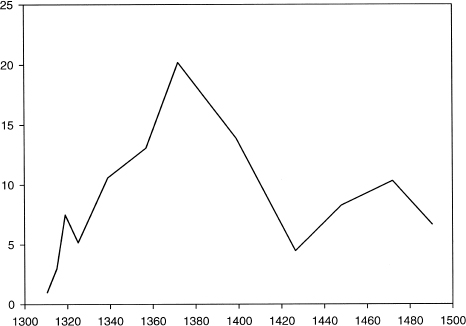

图 4.6 1300-1500 年法国社会向上流动：皇家贵族封信（Contamine 1997）。

Figure 4.6 Upward social mobility in France, 1300–1500: royal letters of ennoblements (Contamine 1997).

## 4.6 结论：“近乎完美的多世周期”

## 4.6 Conclusion: “A Near Perfect Multi-secular Cycle”

当然，标题中的引文来自布罗代尔（1988：131）。我们的周期起始日期与布罗代尔的不同（有理由相信 950 年至 1150 年是西欧的一个单独的世俗周期），但如果我们关注 1150 年至 1450 年之间的法国，那么确实，数据绘制这是一个近乎完美的长期循环的例子。

The quotation in the heading is, of course, from Braudel (1988:131). Our starting date for the cycle differs from that of Braudel (there are reasons to believe that the period 950–1150 was a separate secular cycle in Western Europe), but if we focus on France between 1150 and 1450, then indeed, the data paint a nearly perfect example of a secular cycle.

所有主要变量在此期间的表现都符合人口结构理论的假设。我们掌握的数据中的人口、价格和其他经济变量经历了大幅波动。例如，人口最小值和最大值之间的差异是两倍（在某些地区，例如诺曼底和法兰西岛，差异是三倍甚至四倍）。

All the major variables behaved during this period as postulated by the demographic-structural theory. Population, prices, and other economic variables for which we have data went through a high-amplitude oscillation. For example, the difference between population minima and the maximum was twofold (and in some regions, such as Normandy and Ile-de-France, the difference was three- and even fourfold).

社会结构也以理论预测的方式波动，尽管Contamine (1997)的估计，即1300年左右贵族占总人口的1.8%（此后在15世纪下降到1.5%）过于保守。他发现的 11 个地区的贵族与平民比例数据的平均值为 2.4%。此外，在十四世纪上半叶的饥荒和流行病之后，由于各阶层死亡率的差异，贵族与平民的比例应该进一步增加。换句话说，1350 年至 1450 年间精英与平民比例的下降可能比康塔明的估计更为极端。

Social structure also oscillated in a manner predicted by the theory, although the estimates of Contamine (1997), namely, that nobility accounted 1.8 percent of the total population around 1300 (decreasing thereafter to 1.5 percent in the fifteenth century,) are overly conservative. The average of the eleven regions for which he found data on noble-commoner proportions is 2.4 percent. Furthermore, after the famines and epidemics of the first half of the fourteenth century, the ratio of nobles to commoners should have increased even further, driven by variation in the mortality rate among classes. In other words, the decline in the elite-commoner ratio between 1350 and 1450 was probably more extreme than what is suggested by Contamine's estimates. The extreme nature of elite overproduction in fourteenth-century France is graphically illustrated by tens of thousands of “surplus nobility” seeking military employment but finding death or capture on the fields of Crécy, Poitiers, and others.

国家的实力经历了一个大循环，从十二世纪和十三世纪的地缘政治成功，到百年战争期间持续的财政困难和领土损失，这些情况直到 1450 年才得到逆转。政治不稳定的先衰后升以图形方式呈现通过硬币囤积的时间分布来说明。

The strength of the state followed a grand cycle, from geopolitical successes during the twelfth and thirteenth centuries to persistent fiscal troubles and territorial losses of the Hundred Years’ War, which were reversed only after 1450. The fall and then rise of political instability is graphically illustrated by the time distribution of coin hoards.

理论预测与经验模式完美匹配的主要原因可能有两个。首先是进展缓慢这一时期的技术，特别是农业技术。因此，与随后的近代早期相比，法国的承载能力在 1150 年至 1450 年间几乎没有变化。其次，在大部分时期法国都是西欧霸权国家（Tuchman 1978，Sumption 1991）。因此，其动态主要由内生力而非外生力决定。唯一的重大例外是1348年黑死病从欧亚大陆的草原到来。但鼠疫疫情是在人口已经开始下降之后到来的，因此它加速并加深了持续的下降，而不是改变内生驱动的趋势。到完全不同的吸引子的轨迹。

The main reasons for an excellent match between theoretical predictions and empirical patterns are probably two. The first is the slow advance of technology, especially agricultural technology, during the period. Thus, it appears that the carrying capacity of France hardly changed between 1150 and 1450, in contrast to the following early modern period. Second, during most of the period France was the hegemonic power in Western Europe (Tuchman 1978, Sumption 1991). Its dynamics were therefore primarily determined by endogenous rather than exogenous forces. The only major exception to this was the arrival of the Black Death from the steppes of Eurasia in 1348. But the plague epidemic arrived after the population had already started to decline, and thus it accelerated and deepened the ongoing decline rather than shifting the endogenously driven trajectory to an entirely different attractor.

## **第5章**

## **Chapter 5**

## 早期现代法国：瓦卢瓦循环 （1450–1660）

## Early Modern France: The Valois Cycle (1450–1660)

## 5.1 概述

## 5.1 Overview

在近代早期，法国经历了两次世俗浪潮，即瓦卢瓦周期和波旁周期（我们按照在其一体化阶段统治的王朝来命名该周期的惯例）。在本章中，我们剖析了瓦卢瓦周期的人口、经济和社会趋势（我们在本书中不讨论波旁周期，因为它的动力，特别是在后期阶段，被工业革命极大地改变了）。

During the early modern period France went through two secular waves, the Valois and the Bourbon cycles (we use the convention of naming the cycle after the dynasty that ruled during its integrative phase). In this chapter we dissect the demographic, economic, and social trends of the Valois cycle (we do not address the Bourbon cycle in this book because its dynamics, especially during the later phases, were greatly modified by the Industrial Revolution).

百年战争的结束标志着法国世俗一体化趋势的开始。扩张阶段持续到大约1520年，滞胀阶段从1520年持续到1570年。宗教战争危机之后是萧条和另一场投石党危机。结果，1570年至1660年期间，瓦解倾向盛行。当“太阳王”路易十四个人掌控政府时，这一周期结束，标志着下一个世俗周期扩张阶段的开始。

The end of the Hundred Years’ War marked the beginning of a secular integrative trend in France. The expansion phase lasted until roughly 1520 and the stagflation phase from 1520 to 1570. The crisis of the Wars of Religion was followed by depression and another crisis of the Fronde. As a result, the disintegrative tendency prevailed during the period of 1570–1660. The cycle ended when Louis XIV, the “Sun King,” assumed personal control of the government, marking the beginning of the expansionary phase of the next secular cycle.

## **人口与经济**

## **Population and Economy**

作为参考，人口趋势如图 4.1a所示。与往常一样，一体化阶段是人口持续增长的时期。在瓦解阶段，人口下降期间穿插着短期增长期（这些动态将在第 5.6 节中更详细地讨论）。价格（见图4.1b和前一章的讨论）的表现也与周期的各个阶段大体一致：巨大的价格通胀（16 世纪的价格革命）之后是 17 世纪的通货紧缩。实际工资是价格的镜像（图 5.1）。十六世纪期间，实际工资实际上下降到了十五世纪后期“黄金时代”水平的五分之一。十七世纪出现了一些增长（有重要的波动，稍后讨论），但工人阶级从未重新获得经济地位：即使在十七世纪后期的顶峰，实际工资还不到两个世纪前的一半。

For reference, the population trend is depicted in figure 4.1a. As usual, the integrative phase was a period of sustained population growth. During the disintegrative phase population declines were interspersed with short-term periods of growth (these dynamics are discussed in more detail in section 5.6). Prices (see figure 4.1b and the discussion in the previous chapter) also behaved in a way generally consistent with the phases of the cycle: the great price inflation (the price revolution of the sixteenth century) was followed by deflation during the seventeenth. Real wages were the mirror image of prices (figure 5.1). During the sixteenth century real wages literally collapsed to one-fifth of their level in the “golden age” of the later fifteenth century. The seventeenth century saw some increase (with important fluctuations, to be discussed later), but the working classes never regained their economic ground: even at the peak of the later seventeenth century, real wages were less than half what they were two centuries earlier.

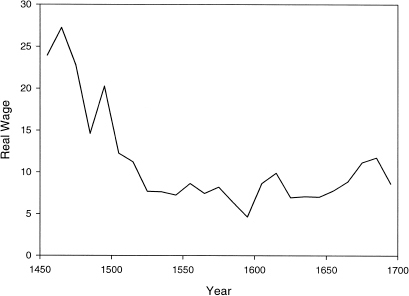

图 5.1 1450-1700 年法国的实际工资，以每天的粮食公斤数表示。正如 Allen (2001) 所报告的，实际工资是通过计算支付给巴黎工人和工匠的平均工资，并用小麦价格进行平减来计算的(Abel 1980)。

Figure 5.1 Real wage in France, 1450–1700, in kg of grain per day. The real wage is calculated by taking an average of the wages paid to laborers and craftsmen in Paris, as reported by Allen (2001), and deflating them by the price of wheat (Abel 1980).

## **社会结构**

## **Social Structure**

1500年左右法国的社会结构与中世纪时期并没有太大的不同。农村人口居住在3万个村庄（教区）。农村等级制度的最高层是领主，通常但并不总是贵族（Knecht 2001：8）。根据Contamine (1997:56)的估计，贵族占总人口的比例为1.5%。4万个贵族家族，约有20万人。因此，许多教区都有不止一个贵族家庭。布列塔尼的贵族密度特别高，一些教区有十多名贵族（Contamine 1997：54）。

The social structure of France around 1500 was not dramatically different from that of the medieval period. The rural population lived in 30,000 villages (parishes). At the top of the rural hierarchy was the seigneur, usually but not always a nobleman (Knecht 2001:8). According to the estimate of Contamine (1997:56), the proportion of nobles among the general population was 1.5 percent. There were about 200,000 persons in 40,000 noble families. Thus, many parishes had more than one noble family. The noble density was particularly high in Bretagne, where some parishes had more than ten nobles (Contamine 1997:54).

在社会等级中，领主之下是“农民”（*费米尔*）。这些都是拥有 30 公顷或更多土地的大量农民（Knecht 2001：9）。他们利用自己和雇佣的劳动力耕种了丰富的土地，使他们能够过上舒适甚至不奢侈的生活（Le Roy Ladurie 1987：181），并留下了剩余的资金，可以用来购买更多的土地或种植谷物商人或养牛者。农民经常充当领主和其他农民之间的中间人（Knecht 2001：9）。

Below the seigneur in the social hierarchy came “farmers” (*fermier*). These were substantial peasants with 30 ha of land or more (Knecht 2001:9). Their abundant land, which they cultivated using their own and hired labor, permitted them to lead comfortable if not ostentatious lives (Le Roy Ladurie 1987:181), and left a surplus that could be used to buy more land or to set up as grain merchants or cattle-breeders. Farmers often acted as intermediaries between the seigneur and the rest of the peasants (Knecht 2001:9).

村里的第一阶层由教区牧师代表。世俗神职人员约有10万人，其中教区神父有3万人。大约有 100 名主教和数百名修道院院长 (Knecht 2001:9)。

The first estate in the village was represented by the parish priest. The numbers of the secular clergy were in the region of 100,000, including 30,000 parish priests. There were about 100 bishops and several hundred abbots (Knecht 2001:9).

城市社会有自己的等级制度。精英分为富商和官员。在他们之下是工匠、小商人、熟练工和大量体力工人。

The urban society had its own hierarchy. The elites were divided between wealthy merchants and officeholders. Below them were artisans, smaller merchants, journeymen, and large numbers of manual workers.

## **国家**

## **The State**

十六世纪和十七世纪皇家收入的时间序列数据很难获得，而且各个权威机构给出的数字常常相互矛盾。图 5.2显示了瓦卢瓦周期期间王室税收的三种观点：(1) 总税收，由布罗代尔和拉布鲁斯 (1977:979) 计算，从 1453 年到 1683 年的一组年份（来自 Chaunu 的原始数据），(2) 最近的税收Kiser 和 Linton (2001) 对 1515 年至 1788 年间总收入的汇编（未显示 18 世纪的数字），以及 (3)*尾数*Bonney (1999) 中给出了（土地税）。后两个数据集是年度数据，并出于演示目的转换为十年平均值。所有数据集均以相同单位表示（百万公顷小麦）。尽管他们在细节上存在分歧，但总体情况相当一致。这些数据表明，由于人口增长和领土征服导致纳税人基础不断扩大，实际收入在十五世纪下半叶有所增长。十六世纪期间，国家收入停滞不前，然后按实际价值计算下降，在宗教战争期间达到最低点。王朝更迭后，波旁王朝得以恢复王室财政（除了投石党时期的财政崩溃），然后在路易十四的统治下，超过了文艺复兴时期君主所达到的水平。

Time-series data on royal revenues during the sixteenth and seventeenth centuries are hard to come by, and the numbers given by various authorities often contradict each other. Figure 5.2 shows three views of royal taxation during the Valois cycle: (1) total taxes, calculated by Braudel and Labrousse (1977:979) for a set of years from 1453 to 1683 (original data from Chaunu), (2) a recent compilation of the total revenues between 1515 and 1788 (eighteenth-century numbers are not shown) by Kiser and Linton (2001), and (3) the *taille* (land tax) given in Bonney (1999). The latter two data sets are annual and were converted to decadal averages for presentation purposes. All data sets are expressed in the same units (millions of hectaliters of wheat). Although they disagree in detail, the overall picture is rather consistent. These data suggest that real revenues grew during the second half of the fifteenth century, owing to an increasing taxpayer base resulting from population growth and territorial conquest. During the sixteenth century state revenues stagnated and then declined in real terms, reaching their lowest point during the Wars of Religion. After the change of dynasty, the Bourbons were able to restore royal finances (apart from the fiscal collapse during the Fronde), and then, under Louis XIV, exceed the levels achieved by the Renaissance monarchs.

由于我们目前还没有对 1385 年之后法国钱币储备的良好总结，因此我们使用 Sorokin (1937) 开发的不稳定指数。在图 5.3中，我们绘制了 1150 年至 1700 年期间的指数，为我们提供了中世纪和现代早期周期的概况。前两个内战时期，分别在 1200 年和 1400 年左右，与钱币囤积的高峰期非常吻合（与图 4.2相比））。这增强了我们的信心，即社会政治不稳定的两种衡量标准反映了真实的历史进程。第三个内战时期的特点是对应宗教战争和投石党战争的双高峰。领土扩张一般发生在内部稳定和国家巩固时期（见图4.1c）。世纪1450年后，法国领土几乎扩大了一倍，随后陷入停滞，甚至出现逆转，直到下一个周期开始，法国在路易十四统治下又经历了一次领土扩张时期。现在我们对瓦卢瓦循环的各个阶段进行更详细的讨论。

Because we do not currently have a good summary of French coin hoards for the period after 1385, we use the instability index developed by Sorokin (1937). In figure 5.3 we plot the index for the period of 1150–1700, giving us a synoptic view of both the medieval and early modern cycles. The first two periods of internal warfare, around 1200 and 1400, respectively, match well the peaks of coin hoard deposition (compare with figure 4.2). This increases our confidence that the two measures of sociopolitical instability reflect real historical processes. The third period of internal warfare is characterized by a double peak corresponding to the Wars of Religion and the Fronde. Territorial expansion generally occurred during the periods of internal stability and national consolidation (see figure 4.1c). The century after 1450 resulted in an almost doubling of the French territory, followed by stagnation and even reverses until the beginning of the next cycle, when France enjoyed another period of territorial expansion under Louis XIV. We now turn to a more detailed discussion of phases in the Valois cycle.

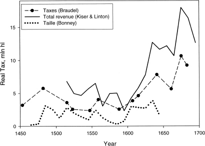

图 5.2 法国皇家收入，1450 年至 1700 年。数据来自 Braudel 和 Labrousse (1977:979)、Kiser 和 Linton (2001) 以及 Bonney (1999)。

Figure 5.2 Royal revenues in France, 1450–1700. Data from Braudel and Labrousse (1977:979), Kiser and Linton (2001), and Bonney (1999).

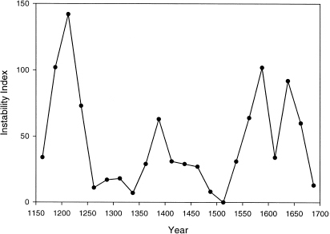

图 5.3 法国索罗金不稳定指数，1150-1700 年。

Figure 5.3 Sorokin's instability index for France, 1150–1700.

## 5.2 扩张（1450–1520）

## 5.2 Expansion (1450–1520)

## **总人口**

## **General Population**

1450 年至 1520 年这段时间非常有利于人口扩张。第一个也是最重要的因素是英国人被驱逐出法国以及百年战争（通常可追溯至 1453 年）的结束。1477 年，大胆的查理在南锡被瑞士人击败并阵亡，勃艮第国家崩溃，内部稳定的另一个重要威胁也随之消除。流行病继续袭击人们，但速度比十四或十七世纪要低。

The period between 1450 and 1520 was very favorable for demographic expansion. The first and foremost factor was the expulsion of the English from France and the end of the Hundred Years’ War (usually dated to 1453). Another important threat to internal stability was removed when the Burgundian state collapsed in 1477 as a result of the defeat and death of Charles the Bold at the hands of the Swiss at Nancy. Epidemics continued to strike the population, but at a comparatively lower rate than during the fourteenth or seventeenth centuries.

农业产量增加（仅仅由于先前废弃土地的开垦），并且在 1520 年之前，饥荒是罕见的事件（Le Roy Ladurie 1987：11-12）。农业生产总量的趋势可以通过检查什一税的收入来追踪（Le Roy Ladurie 1987：45-46）。巴黎盆地农业生产的最低点出现在1440年左右。1450年至1500年间，谷物产量几乎翻了一番。在南方，最低点出现得更早，即 1400 年至 1430 年之间，谷物的总供应量翻了一番，到 15 世纪末就增加了一倍多。那么，1500 年的粮食产量很可能是 15 世纪初最低产量的两倍。这一时期的人口增长要温和得多（很难给出定量估计，但增幅不超过 50%）。换句话说，人均粮食供应以及生活水平大幅提高。

Agricultural production increased (owing simply to the reclamation of previously abandoned land), and before 1520 famine was a rare event (Le Roy Ladurie 1987:11–12). A trend in the overall volume of agricultural production can be traced by examining the receipts of tithes (Le Roy Ladurie 1987:45–46). The lowest point of agricultural production in the Paris basin was achieved around 1440. Between 1450 and 1500, cereal production nearly doubled. In the south, the lowest point was earlier, between 1400 and 1430, and the overall supply of cereals doubled, or more than doubled by the end of the fifteenth century. It is likely, then, that food production in 1500 was double the minimum of the early fifteenth century. Population growth during this period was much more modest (it is difficult to give a quantitative estimate, but the increase was no more than 50 percent). In other words, the supply of food per capita, and by implication the standard of living, grew very substantially.

15世纪末，由于老百姓相对富裕，总体死亡率下降到较低水平，15世纪早期盛行的对死亡的迷恋也随之而来。20世纪的*恐怖之舞*和赤裸尸体躺着的雕像不再占据文化高峰。人口扩张的活力体现在农村人口的重新增加和收复失地后的移民。例如，从路易十一统治时期开始，吉伦特省许多在英国战争期间被遗弃的村庄被来自奥克西唐和法语区的新殖民者重新安置（Le Roy Ladurie 1987：11）。

As a result of relative prosperity among the common people toward the end of the fifteenth century, the general mortality rate fell to a comparatively low level, and the obsession with death, so prevalent earlier in the century with its *danses macabre* and recumbent effigies of naked corpses, ceased to occupy cultural heights. The vigor of the demographic expansion was manifested in repopulation of the countryside and immigration after reconquest. For example, many villages in the Gironde that had been abandoned during the English wars were resettled with new colonists from the Occitan and French-speaking zones, starting with the reign of Louis XI (Le Roy Ladurie 1987:11).

## **精英们**

## **The Elites**

贵族财富在此期间开始复苏（Carpentier and Le Mené 1996：图29）。安茹 (Anjou) 的领主杜普莱西斯-格拉莫瓦尔 (Seigneurie du Plessis-Grammoire) 贵族家族的收入动态表明，最糟糕的时期是 1420 年代。1460 年后上升趋势变得明显，到 1500 年与 1300 的水平相匹配（名义上）。到1500年贵族收入恢复似乎是一种普遍模式。例如，克朗领主的收入从1396年的不到1000里弗增加到1500年的1700里弗。本世纪中叶，圣法尔戈领主的收入约为100里弗；到 1484 年，它已增加到 500 里弗（Carpentier 和 Le Mené 1996：468）。诺曼底的几个领地（Bois 1984：257，Dewald 1987）和拉特雷莫伊勒家族（Weary 1977：D1007）也证明了类似的动态。

The noble fortunes began their recovery during this period (Carpentier and Le Mené 1996: Figure 29). The dynamics of the revenues of one noble family, the seigneurie du Plessis-Grammoire in Anjou, show that the worst period was the 1420s. The rising tendency becomes evident after 1460, and by 1500 the levels of 1300 are matched (in nominal terms). The restoration of noble incomes by 1500 appears to be a general pattern. For example, the seigneurie de Craon increased from less than 1,000 livres in 1396 to 1,700 livres toward 1500. The income of the lordship of Saint-Fargeau was about a hundred livres in mid-century; by 1484 it had increased to 500 livres (Carpentier and Le Mené 1996:468). A similar dynamic is demonstrated by several seigneuries in Normandy (Bois 1984:257, Dewald 1987) and by the House of La Trémoille (Weary 1977:D1007).

## **国家**

## **The State**

1435年，皇太子派与勃艮第派之间的和解结束了内战，但两次余震除外。第一个是 1440 年的布拉格，大贵族在王太子（未来的路易十一）的支持下反抗国王（查理七世）。第二次是 1465 年的公共福利联盟，这是阿朗松、勃艮第、贝里、波旁和洛林公爵阴谋反对路易十一，同样得到王太子（未来的查理八世）的支持。在这最后一次余震之后，法国在一个世纪内没有再出现精英叛乱。从 1453 年到 1562 年宗教战争开始，法国的核心地区没有发生任何严重的战斗（Knecht 2001：3）。

The reconciliation of the Dauphinist and Burgundian factions in 1435 ended the civil war, except for two aftershocks. The first one was the Praguerie in 1440, a revolt by the great nobles against the king (Charles VII), with support from the dauphin (the future Louis XI). The second was the League of the Public Weal in 1465, a conspiracy against Louis XI by the dukes of Alençon, Burgundy, Berri, Bourbon, and Lorraine, again supported by the dauphin (future Charles VIII). After this last aftershock, France was not to see an elite rebellion for a century. The core regions of France were spared any serious fighting from 1453 to the start of the Wars of Religion in 1562 (Knecht 2001:3).

The increasing internal strength of France, both economic and sociopolitical, was rapidly translated by the ruling elites into territorial expansion. The state territory grew, first by a reconquest of the English-occupied lands, then by the reversal to the Crown of the appanages earlier granted to Valois princes. In 1477 Charles the Bold of Burgundy died in the battle of Nancy without male issue. Louis XI united the duchy of Burgundy with the Crown and occupied the county of Burgundy (Franche Comté). On the extinction of the house of Anjou in 1480, Anjou, Bar, Maine, and Provence reverted to the French Crown. Other smaller incidents of territorial expansion were the acquisition of Cerdagne and Roussillon (1462) and the redemption of the Somme towns (1463). The last great duchy of medieval France that was still independent of the Crown, Brittany, was attached to France when Charles VIII married Anne of Brittany in 1491. In 1495 Charles VIII began a series of Italian campaigns that eventually mutated into the great Habsburg-Valois struggle for European hegemony in the sixteenth century. The territorial expansion of France during the fifteenth century was striking. From a low point in 1430 of 290,000 square kilometers, the territory controlled by the French kings reached 500,000 square kilometers in 1510. Increased territory and a growing population expanded the tax base of the kingdom. Between 1453 and 1515, state revenues tripled from 1.8 to 5.5 million *livres tournois* (l.t.) (Braudel and Labrousse 1977:979).

## 5.3 滞胀（1520–70）

## 5.3 Stagflation (1520–70)

## **人口与经济**

## **Population and Economy**

到 1560 年，法国人口从中世纪晚期的低点（Dupâquier 等人，1988b）翻了一番，达到 2000 万，或与 1300 年左右的水平大致相同。然而，在 16 世纪末，人口动态进入了一个不同的状态，一个短期增长夹杂着下降，总体上导致人口数量停滞。人口停止增长的原因很明显：人口增长超过了早期现代农业养活人口的能力。正如我们在上一节中指出的，谷物产量（以什一税为指标）在 1450 年之后迅速增长。1450 年至 1505 年间，生产增长大大超过了人口增长。经过短暂的过渡期（1505-20）后，谷物产量继续增长（直到 1560 年），但增长速度较慢，随着可用土地数量接近极限（Le Roy Ladurie 1987：121）。现在是人口超过了生产，到 1560 年，考虑到 16 世纪的技术水平，人口已接近法国可以支持的上限。

By 1560 the population of France had doubled from its late medieval low (Dupâquier et al. 1988b), reaching 20 million, or roughly the same level as around 1300. In the late sixteenth century, however, population dynamics entered a different regime, one of short periods of growth interspersed with declines, leading overall to the stagnation of population numbers. The reason for the cessation of population growth is clear: population growth outpaced the ability of early modern agriculture to feed it. As we noted in the previous section, cereal production (as indexed by tithes) expanded rapidly in the post-1450 period. Between 1450 and 1505 production gains substantially outpaced population increases. After a brief transitional period (1505–20), the production of cereals continued to rise (until 1560) but at a slower pace, as the limit to the amount of available land was approached (Le Roy Ladurie 1987:121). Now it was population that outpaced production, and by 1560 the population was approaching the upper ceiling that could be supported in France, given the sixteenthcentury level of technology.

This number makes sense (at least to the order of magnitude) in light of what we know about the productive capacity of medieval and early modern French agriculture. “At the rate of 210 to 240 kilograms of cereals per year per inhabitant (this figure takes into account children, who eat less than adults) and adding the quantities of grain necessary for sowing and for animal consumption, the 20 million inhabitants of France between 1550 and 1720 must have consumed 60 million quintals of cereals” (Le Roy Ladurie 1987:231). Since the annual cereal crop was produced on about 10 million ha (Le Roy Ladurie 1987:240), the average yield implied by these numbers is 600 kg/ha, or 8 hl/ha. The latter number is comfortably in the middle between average yields prevailing in the south (5 hl/ha) and those in the north (10 hl/ha), taking into account the rotation systems prevailing in each region (Le Roy Ladurie 1987:176).

谷物生产动态的时间顺序在 1560 年左右接近上限（直到 1700 年之后才超过），与法国北部尤其相关。其他地方也存在重要的地区差异。因此，南方显然在 1540 年代达到了生产高峰。直到一个世纪后，即 1649 年至 1678 年期间，这一最高水平才得以改善。相比之下，在阿尔萨斯，最好的时期是在 1600 年至 1630 年之间，即三十年战争崩溃之前达到的（Le Roy Ladurie 1987:120） ）。下面以法国不同地区发生人口下降的情况为背景讨论这些区域差异。

The chronology of cereal production dynamics, with the ceiling approached around 1560 (and not exceeded until after 1700), is particularly relevant to the north of France. Elsewhere there were important regional variations. Thus, the south apparently reached a production peak during the 1540s. This maximum level was not to be bettered until a century later, between 1649 and 1678. In Alsace, by contrast, the best period was reached between 1600 and 1630, before the collapse of the Thirty Years’ War (Le Roy Ladurie 1987:120). These regional variations are discussed below in the context of when population declines occurred in different parts of France.

人口增长对农民与土地的比例有直接影响。在人口稀少的15世纪，拥有约10公顷土地的中型土地所有者约占地籍调查所列人数的一半。到 1550 年，这些中等规模的财产大部分都消失了，其中一些是由于家庭内部加速分割的结果，另一些则被贵族和城市资产阶级购买（Le Roy Ladurie 1987：56）。在巴黎地区，土地碎片化达到了令人难以置信的程度，每个租户只有 1.3 公顷（Jacquart，引自 Le Roy Ladurie 1987：162）

Population growth had a direct effect on peasant to land ratios. In the depopulated fifteenth century, middle-sized landowners who owned about 10 ha accounted for about half of those listed in the cadastral surveys. Most of these fair-sized holdings had disappeared by 1550, some as a result of accelerating subdivision within families, others bought by nobles and urban bourgeois (Le Roy Ladurie 1987:56). In the Paris region land fragmentation achieved an incredible degree, with only 1.3 ha per tenant (Jacquart, cited in Le Roy Ladurie 1987:162)

人口增长也导致地租普遍上涨，尽管地租上涨时间存在重要的地理差异。首先，十五世纪的地租非常低。1448 年，Vierzay (Soissonais) 村的谷物地租仅为每公顷 0.5 百升。到 1511 年，它已升至每公顷 2 百升 (Le Roy Ladurie 1987:177)。1500 年至 1560 年期间，法国南部的租金稳定在 1.5 百升/公顷左右，巴黎地区和苏松内的租金稳定在 2.5 百升/公顷。在宗教战争期间，租金略有下降，但在 17 世纪又开始上涨。大约 1650-70 年，朗格多克的产量增加到 3 百升/公顷，巴黎地区的产量增加到每公顷 5 百升，考虑到产量和轮作系统的差异，几乎达到了产量的一半（Le Roy Ladurie 1987：177） ）。

Population growth also caused a general rise in ground-rents, although there were important geographic variations in the timing of rent increases. To start with, the ground-rents were very low in the fifteenth century. In the village of Vierzay (Soissonais) the rent was only 0.5 hl of grain per ha in 1448. By 1511 it had risen to 2 hl/ha (Le Roy Ladurie 1987:177). Between 1500 and 1560 rents stayed steady at about 1.5 hl/ha in the south of France and 2.5 hl/ha in the Paris region and Soisonnais. During the Wars of Religion rents slightly declined, but in the seventeenth century they again started to increase. About 1650–70 they rose to 3 hl/ha in Languedoc and to 5 hl/ha in the Paris region, which amounted to almost one-half the product, taking into account disparities in yields and rotation systems (Le Roy Ladurie 1987:177).

在其他地区，如胡雷普瓦和普瓦图，租金在 1560 年就已经上涨。例如，普瓦图的*梅泰耶人*在 16 世纪必须向地主支付一半的农产品（相比之下，15 世纪的四分之一到三分之一）。世纪）。这些严酷的*métayage*条件直到 1650 年之后才得到放松（Le Roy Ladurie 1987：177-78）。

In other regions, such as the Hurepoix and Poitou, rent increases had already occurred by 1560. For example, the *métayers* in Poitou had to pay half their produce to the landlord in the sixteenth century (compared to a fourth to a third in the fifteenth century). These conditions of harsh *métayage* were relaxed only after 1650 (Le Roy Ladurie 1987:177–78).

土地价格上涨。1550 年代，巴黎周围一公顷耕地的售价为 63 里弗。二十年后，土地价格上涨至每公顷 150 里弗（Le Roy Ladurie 1987：239-40）。

Land prices increased. In the 1550s a hectare of plowland around Paris cost 63 livres. Two decades later land prices had increased to 150 livres per hectare (Le Roy Ladurie 1987:239–40).

实际工资的趋势是滞胀阶段的典型趋势。巴黎建筑工人的平均实际工资从 15 世纪和平时期典型的每天 25 ± 2 公斤小麦，下降到 16 世纪下半叶的 7-8 公斤/天，然后下降到不足 5 公斤。 1590-99 年灾难性的十年期间 / 天（图 5.1）。农业工资也出现了灾难性的下降。1495 年至 1560 年间，葡萄园工人的实际工资损失了其价值的三分之二到四分之三。另一方面，某些类别的工人，例如干草收割者，表现稍好一些，在同一时期实际工资仅损失了 30%。时期（Le Roy Ladurie 1987：185-86）。实际工资的下降不仅影响到工作穷人。1480 年，纳博讷附近的一个大农场的经理收到的工资相当于 31 百升小麦，而他的继任者在 1590 年的工资仅为 17.2 百升 (Le Roy Ladurie 1987:69)。

The trend in real wages was typical of the stagflation phase. The average real wage of Parisian builders fell from 25 ± 2 kg of wheat per day, typical of peaceful periods of the fifteenth century, to 7–8 kg/day during the second half of the sixteenth century, and then to less than 5 kg/day during the disastrous decade of 1590–99 (figure 5.1). Agricultural wages also declined calamitously. The real wage of vineyard workers lost two-thirds to threequarters of its value between 1495 and 1560. On the other hand, some categories of workers, such as hay-reapers, did somewhat better, losing only 30 percent in real terms during the same period (Le Roy Ladurie 1987:185–86). The fall in real wages affected not only the working poor. Whereas in 1480 the manager of a large farm near Narbonne received a salary equivalent to 31 hl of wheat, his successor's salary in 1590 was only 17.2 hl (Le Roy Ladurie 1987:69).

在滞胀阶段表现相对较好（或至少没有失势）的一个阶层是农民，他们从作为地主和农民之间的中间人的地位中受益。粮食价格上涨、租金停滞（无论是十进制还是财政租金）以及工资迅速下降的经济结合对他们有利（Le Roy Ladurie 1987：181-84）。结果，在十六世纪（但与十七世纪不同），农民能够保持自己的地位，甚至可以渴望提升社会等级。

One stratum that did relatively well (or at least did not lose ground) during the stagflation phase was the farmers, who benefited from their situation as intermediaries between the lords and peasants. The economic conjuncture of rising grain prices, stagnating rents (whether decimal or fiscal), and rapidly falling wages worked to their advantage (Le Roy Ladurie 1987:181–84). As a result, during the sixteenth century (but unlike in the seventeenth century), farmers were able to hold their own and could even aspire to advance up the social hierarchy.

## **精英人士**

## **Elites**

虽然滞胀阶段普通民众的经济状况逐渐恶化，但对于精英来说，经济形势却是好的，导致了两个相关的发展。首先，平民之间不平等的加剧意味着，尽管大多数人陷入苦难，但少数人却过得很好，获得了巨额财富。这些富裕的平民（上一段讨论的农民）和商人自然渴望将自己的财富转化为地位。许多这样的精英野心家都取得了成功，并稳定地进入了贵族行列。

While the stagflation phase saw a progressive worsening of the economic situation of common people, for the elites the economic conjuncture was good, resulting in two related developments. First, growing inequality among commoners meant that although the majority of them were sinking into misery, a small minority did very well and acquired substantial wealth. These well-to-do commoners (the farmers discussed in the previous paragraph) and merchants naturally aspired to translate their wealth into status. Many such elite aspirants succeeded, generating a steady inflow into the ranks of nobility.

其次，由于经济条件优越，许多贵族家庭向其小儿子提供了大量遗产。这种做法导致了庄园的细分和贵族的繁衍。例如，法国最富有的富豪之一弗朗索瓦·德·拉·特雷莫耶（François de la Trémoille，1502-42 年）必须养活五个儿子，并为两个女儿提供嫁妆。庄园的分割和随后的宗教战争导致家庭收入从 1530 年代的 600 公斤白银下降到 1619 年的 430 公斤（Weary 1977，Major 1981）。另一个例子是诺曼底的 Roncherolles 家族，该家族于 1570 年将其庄园分给了四个儿子。圣皮埃尔桥男爵爵位归长子所有，但其他三人也获得了相当于实质性领主（Dewald 1987：163）。当然，这两个例子只不过是轶事证据，但 1463-1666 年间巴约地区贵族家庭的数据提供了更坚实的定量支持（Wood 1980）。在这一时期的大部分时间里，古代贵族（1463 年之前被封为贵族的家庭）的数量都在减少，除了 1540-98 年这一时期（见表 5.2 和第 5.5 节的讨论）。

Second, given favorable economic conditions, many noble families provided substantial inheritances to their younger sons. This practice led to estate subdivision and the multiplication of nobles. For example, one of the richest French magnates, François de la Trémoille (1502–42), had to provide for five sons, and dowries for two daughters. This division of the estate and the subsequent Wars of Religion led to a drop in family revenues from 600 kg of silver in the 1530s to 430 kg in 1619 (Weary 1977, Major 1981). Another example is the Roncherolles family in Normandy, which divided its estates in 1570 among four sons. The barony of Pont-St-Pierre went to the eldest son, but the other three also got what amounted to substantial lordships (Dewald 1987:163). These two examples, of course, are no more than anecdotal evidence, but data on the noble families of the Bayeux region during 1463–1666 provide a firmer quantitative support (Wood 1980). During most of this period the numbers of ancient nobility (families who were ennobled prior to 1463) shrank, except during one time interval, 1540–98 (see table 5.2 and the discussion in section 5.5).

在向上流动和阶层分割的推动下，16世纪贵族的数量急剧增加。*例如，骑士*（骑士）的数量在 16 世纪翻了一番，从 1,000 人增加到 2,000 多人（Orlea 1980:59）。但顶级精英阶层（*外行同*侪）的扩张速度更快，从 1505 年的 12 人增加到 1588 年的 36 人（Labatut 1972）。这种增长的必然结果是加剧了精英内部对地位和财富的竞争。我们衡量精英阶层日益增长的社会压力的一种方法是通过精英内部暴力的发生率，这一时期的暴力形式表现为决斗（另见第 3 章））。十五世纪和十六世纪初，决斗在法国几乎消失了（Harding 1978：77）。在弗朗索瓦一世和亨利二世的统治下，在王室批准下进行了一些司法决斗。然而，1560 年后，为个人荣誉而未经王室批准的决斗变得如此普遍，以至于拉努埃认为死于决斗的贵族数量比死于战斗的贵族还要多。Estoile 相信 1588 年之后的二十年里有 7,000 到 8,000 人被杀（Harding 1978：77,253）。据说，亨利四世在 17 世纪的头十年里赦免了 6000 多名在决斗中杀害绅士的人（Stone 1965：246）。仅仅一个世纪后，在路易十四统治时期，决斗就被有效地消除了（Collins 1995：85）。

Driven by upward mobility and estate subdivision, the numbers of nobles increased dramatically during the sixteenth century. The numbers of *chevaliers* (knights), for example, doubled during the sixteenth century from 1,000 to more than 2,000 (Orlea 1980:59). But the top elite stratum (*pairs laïques*, or lay peers) expanded even faster, from only twelve in 1505 to thirty-six in 1588 (Labatut 1972). An inevitable result of this increase was intensifying intraelite competition for status and wealth. One way we can gage the increasing social pressure on the elites is by the incidence of intraelite violence, which during this period took the form of dueling (see also chapter 3). Dueling had almost disappeared in France during the fifteenth century and early sixteenth century (Harding 1978:77). Under François I and Henri II, a handful of judicial duels took place with royal sanction. After 1560, however, dueling for personal honor and without royal sanction became so common that La Noue believed more noblemen died from it than in combat. Estoile believed 7,000 to 8,000 were killed in the two decades after 1588 (Harding 1978:77,253). It was said that Henri IV granted more than 6,000 pardons for the killing of gentlemen in duels during the first ten years of the seventeenth century (Stone 1965:246). Dueling was effectively eliminated only a century later, during the rule of Louis XIV (Collins 1995:85).

人口结构危机日益成熟的另一个迹象是精英网络之间争夺庇护的竞争加剧。蒙莫朗西派和吉斯派之间争夺宫廷赞助权的斗争是著名的。亨利二世去世后，在弗朗索瓦二世的短暂统治期间，吉斯派几乎垄断了他们手中的王室赞助权（Harding 1978：35）。弗朗索瓦二世的去世和吉斯家族与宫廷的疏远使凯瑟琳·德·美第奇重新获得了对王室赞助的控制权，但代价是疏远了大部分法国精英。

Another sign of the ripening demographic-structural crisis was the increased competition for patronage among elite networks. The struggle between the Montmorency and Guise factions for control of court patronage is famous. After the death of Henri II, during the short reign of François II, the Guise faction managed to practically monopolize the royal patronage in their hands (Harding 1978:35). The death of François II and the alienation of the Guises from the court allowed Catherine de Medici to regain control of the royal patronage, but at the expense of alienating a large segment of the French elites.

## **精英与国家**

## **Elites and the State**

At the same time that the expanding elite numbers were putting increasing pressure on the state finances, the state's ability to collect revenue (in real terms) was declining (figure 5.2). The fiscal crisis of the state was a major precondition of the crisis of the Wars of Religion. In 1559 Henri II signed the Peace of Cateau-Cambrésis with the Spanish. The cessation of the Habsburg-Valois wars meant that “hundreds of noble sons were thrown back on the home estates, where the family resources were often insufficient to support them” (Bitton 1969). Moreover, the financial situation of the Crown made it impossible to continue the patronage system on the old footing (Briggs 1998:15). The Cardinal of Lorraine, beset by would-be clients, was reduced to threatening to hang the next man who asked for a pension (Briggs 1998:15). The contraction of the largesse of the state affected even the top magnates of the kingdom, the provincial governors (Harding 1978:47). The governors from southern and western provinces reported that they could not rely on the loyalty of their subordinates, who were attracted to the new religion. “As the era of the secret conventicles came to an end, service as ‘protectors’ for the Calvinist communities represented an available option to royal service for noblemen, and the pastors apparently resorted to straightforward bribery” (Harding 1978:49).

吉斯家族对赞助的垄断引起了被他们排除在外的人的极大不满（Briggs 1998：15）。“昂布瓦斯骚乱”（1560）是一些新教贵族针对吉斯家族的阴谋。大多数阴谋者都是古老血统的小领主（Salmon 1976：124）。

The Guises’ monopoly of patronage bred much resentment on the part of those they excluded (Briggs 1998:15). The “Tumult of Amboise” (1560) was a conspiracy by some protestant nobles against the Guises. Most of the conspirators were petty seigneurs of ancient lineage (Salmon 1976:124).

随着金融危机的加深，军队的工资被拖欠，最终国家失去了对军队的控制。当代信件（Harding 1978：49-50 引用）为这种国家崩溃的人口结构机制提供了精彩的例证（Goldstone 1991）。1561 年，一名军官报告称，他在布列塔尼的未领军饷的部队“已经离开去进行掠夺……” 最后我希望自己一个人。我的连队成员们有太多的功劳……我既不被畏惧，也不被服从。” 一年后，另一名军官描述了他的部队如何一年没有领到军饷，“吃了驻军里的马，然后就退到了自己的房子里，没有一分钱” *。*”。同年，第三位上尉因为没有钱支付他们的工资，解散了他的普罗旺斯征兵部队，他们分散成团伙，袭击“全省”的加尔文主义者，劫持一些人索要赎金，并杀害另一些人。

As the financial crisis deepened, the wages of troops fell into arrears, and eventually the state lost control of the army. Contemporary letters (cited by Harding 1978:49–50) provide a wonderful illustration of this demographic-structural mechanism of state collapse (Goldstone 1991). One officer reported in 1561 that his unpaid troops in Brittany “have left to pillage…. In the end I expect to be all alone. There is so much due to the men of my company…that I am neither feared nor obeyed.” A year later another officer described how his troops, who had not been paid in a year, “ate the horses in the garrison and then retired to their houses without a *sou*.” The same year a third captain, lacking money to pay them, disbanded his Provençal levies, who dispersed in gangs that attacked Calvinists “all over the province,” holding some for ransom and killing others.

随着1562年内战的爆发，王室财政彻底崩溃。典当皇家珠宝（Bonney 1999）和出售教堂财产（带来超过 1300 万里弗；Le Roy Ladurie 1994：240）等绝望措施完全不足以跟上军费开支。结果是国家债务螺旋式上升，到 1595 年达到 2.96 亿里弗（Bonney 1999）。在亨利四世统治期间，债务几乎被消灭，但在投石党危机期间再次激增，在 1661 年达到 7 亿里弗（Briggs 1998）。

With the onset of civil war in 1562, the royal finances completely collapsed. Desperate measures such as pawning royal jewels (Bonney 1999) and selling church property (which brought more than 13 million livres; Le Roy Ladurie 1994:240) were completely insufficient to keep up with military expenditures. The result was a spiraling state debt, which reached 296 million livres by 1595 (Bonney 1999). The debt was almost wiped out during the reign of Henri IV but ballooned again during the crisis of the Fronde, reaching 700 million livres in 1661 (Briggs 1998).

## 5.4 危机（1570-1600）

## 5.4 Crisis (1570–1600)

到滞胀阶段结束时，法国人口已大致恢复到十四世纪崩溃之前的水平。在 16 世纪末和整个 17 世纪，人口生长停止了。法国的总人口（包括农村和城市地区以及北部和南部省份）“停滞不前”，因此 1720 年的法国人口基本上与 1560 年相同（Le Roy Ladurie 1987：232）。这并不意味着人口数量处于平衡状态：存在几次时间波动，王国的不同地区遵循不同的轨迹。这里我们关注时间波动，而将区域变化的讨论推迟到下一节。

By the end of the stagflation phase the population of France had recovered to roughly the level that obtained before the fourteenth-century collapse. In the late sixteenth century and all of the seventeenth century, population growth ceased. The overall population of France (adding together rural and urban locations and northern and southern provinces) “stagnated,” so that the French population of 1720 was essentially the same as that of 1560 (Le Roy Ladurie 1987:232). This does not mean that population numbers were in equilibrium: there were several temporal fluctuations, and different regions of the kingdom followed different trajectories. Here we focus on the temporal fluctuations, while deferring a discussion of regional variations to the next section.

勒罗伊·拉杜里（Le Roy Ladurie）区分了三类时间波动：（1）发生在数百年时间尺度上的波动（我们称为长期周期），（2）发生在数十年时间尺度上的波动（我们称为两代周期），以及（ 3) 每年发生的事件。1560年至1720年期间，出现了三次第二类波动（Le Roy Ladurie 1987:233）：（1）宗教战争期间人口下降，随后在亨利四世统治时期和早年有所恢复路易十三；（2）三十年战争和投石党运动期间衰落，随后在富凯和科尔伯特领导下复苏；(3)路易十四统治后半期的麻烦，随后在他的两位继任者的领导下人口持续增长，最终突破了中世纪2000万的上限（见图 4.1a）。

Le Roy Ladurie distinguishes three classes of temporal fluctuations: (1) those occurring on the time scale of centuries (which we call secular cycles), (2) those occurring on the time scale of decades (which we call bigenerational cycles), and (3) those occurring on an annual time scale. During the period of 1560–1720 there were three fluctuations of the second type (Le Roy Ladurie 1987:233): (1) a population decline during the Wars of Religion, followed by some recovery during the reign of Henri IV and the early years of Louis XIII; (2) a decline during the Thirty Years’ War and the Fronde, followed by a recovery under Fouquet and Colbert; and (3) the troubles of the second half of the reign of Louis XIV, followed by a sustained population take-off under his two successors that finally broke through the medieval ceiling of 20 million (see figure 4.1a).

这一时期饥荒十分普遍，从 1590 年代反胡格诺天主教联盟活动造成的粮食短缺，到 1630 年、1649 年、1652 年、1661 年和 1694 年的生存危机，再到 1709 年的无粮大冬（勒罗伊·拉杜里 1987：272）。这些危机的直接触发因素是非常寒冷或非常潮湿的冬季和异常潮湿的夏季。例如，1630年和1661年的饥荒发生在和平时期，完全是由于恶劣的天气造成的。然而，此类危机导致了非常短期的下跌，勒罗伊·拉杜里（Le Roy Ladurie）称之为三级波动。“这些波动暂时受到干扰，没有真正以持久的方式改变人口和粮食供应的水平和比例”（Le Roy Ladurie 1987：276）。1590 年代和 1649-52 年的饥荒对人口产生了更持久的影响，而天气则扮演了次要角色。杀死谷物的是内战而不是雨水（Le Roy Ladurie 1987：273）。

Famine was widespread during this period, from the food shortages arising from the activities of the anti-Huguenot Catholic League in the 1590s, through the subsistence crises of 1630, 1649, 1652, 1661, and 1694, to the great grainless winter of 1709 (Le Roy Ladurie 1987:272). The immediate triggers of these crises were periods of very cold or very damp winters and unusually wet summers. For example, the famines of 1630 and 1661 occurred during peacetime and were entirely due to bad weather. However, such crises caused very short-term declines, what Le Roy Ladurie has called third-order fluctuations. “These fluctuations temporarily disturbed, without really altering them in a lasting way, the levels and ratios of population and food supplies” (Le Roy Ladurie 1987:276). During the famines of the 1590s and 1649–52, which had a much more lasting effect on population, the weather played a secondary role. It was civil war rather than the rain that killed the grain (Le Roy Ladurie 1987:273).

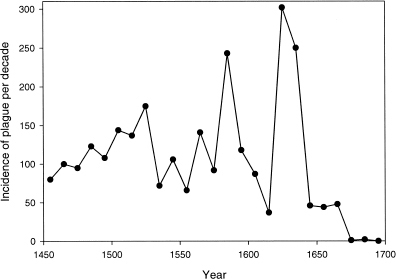

图 5.4 法国鼠疫发病率，1450-1700 年。数据来自 Biraben (1975)。

Figure 5.4 Incidence of plague in France, 1450–1700. Data from Biraben (1975).

我们应该通过指出它最有说服力地适用于前两次人口下降（发生在 1660 年代之前）来限定这一论点。第三次衰落发生在1700年左右的二十年里，发生在国家强大的时候（尽管恰逢一系列特别激烈的外部战争）。因此，我们认为，这不是人口结构机制造成的。历史学家对此提出了各种解释，其中最有可能的是两种：气候显着恶化以及路易十四侵略性的对外政策对法国农民提出的巨大要求。无论如何，第三次人口下降问题不属于本章的时间框架，下文我们重点关注 1660 年之前的人口动态。

We should qualify this argument by noting that it applies most cogently to the first two population declines (occurring prior the 1660s). The third decline, in the two decades around 1700, occurred when the state was strong (although it coincided with a series of particularly intense external wars). In our opinion, therefore, it was not brought about by demographicstructural mechanisms. Historians have proposed various explanations for it, of which two appear most probable: a significant worsening of the climate and the great demands placed on the French peasantry by the aggressive external policy of Louis XIV. In any case, the issue of the third population decline falls outside the temporal framework of this chapter, and in the following we focus on the population dynamics up until 1660.

尽管这一时期（1570-1660年）人口减少的直接因素包括流行病和饥荒，但流行病的传播往往是军队的调动，军事行动和士兵的抢劫也威胁或破坏了收成。因此，人口波动的根本机制是社会政治不稳定导致王国内战，国家衰弱，容易受到外国入侵。

Although the proximate factors of population declines during this period (1570–1660) included epidemics and famine, it was often troop movements that spread epidemics, and the harvests were threatened or damaged by military operations and looting soldiers. Thus, the fundamental mechanism of population fluctuations was sociopolitical instability leading to civil war within the kingdom, and the weakening of the state, which made it susceptible to foreign invasions.

法国政治高度不稳定的时期持续了大约一个世纪，从 1562 年到 1675 年（表 5.1）。有两波浪潮，第一波以宗教战争为标志，在 1590 年左右达到顶峰，第二波是权贵叛乱、胡格诺派起义和农民起义的时期，最终在 1648-53 年的投石党运动中达到顶峰（图 5.3中的双峰反映了这些浪潮）两波）。

The period of heightened political instability in France lasted about a century, from 1562 to 1675 (table 5.1). There were two waves, the first marked by the Wars of Religion and culminating around 1590, the second a period of magnate rebellions, Huguenot insurrections, and peasant uprisings that culminated in the Fronde of 1648–53 (the double peak in figure 5.3 reflects these two waves).

内战的两个高峰期相隔亨利四世时期和路易十三时期相对稳定的二十年。宗教战争可能导致人口减少 20% 或更多 (Benedict 1985:96)。1561 年至 1597 年间，奥尔良的人口减少了三分之一（Dupâquier 等人，1988b：197）。1562 年至 1594 年间，鲁昂的人口减少了四分之一以上（Benedict 1975：232）。在第二次社会政治不稳定时期，一些地区的人口损失甚至更大。因此，由于三十年战争和投石党运动的综合影响，北部和东部的某些省份可能失去了近一半的居民（Dupâquier et al. 1988b:152）。法国南部受到的影响要小得多（这将在第 5.6 节中讨论）。

The two peaks of internal warfare were separated by a relatively stable two decades under Henri IV and the early years of Louis XIII. The Wars of Religion may have resulted in a population loss of 20 percent or more (Benedict 1985:96). In Orléans, the population was reduced by one-third between 1561 and 1597 (Dupâquier et al. 1988b:197). The population of Rouen was reduced by more than a quarter between 1562 and 1594 (Benedict 1975:232). During the second period of sociopolitical instability, demographic losses in some regions were even greater. Thus, as a result of the combined effect of the Thirty Years’ War and the Fronde, certain provinces in the north and east probably lost close to half their inhabitants (Dupâquier et al. 1988b:152). The south of France was much less affected (this is discussed in section 5.6).

## 5.5 案例研究：诺曼贵族

## 5.5 A Case Study: The Norman Nobility

As a result of research by historians such as Guy Bois, James Wood, and Jonathan Dewald, we have excellent quantitative data on the nobility of one region of France, Normandy. The situation in Normandy is particularly interesting because this province appears to be reasonably representative of northern France. It is situated next to the core of the French state, but unlike Ile-de-France, its development was not heavily distorted by the influence of the capital with its royal court and the central administrative apparatus. Thus, what we learn about the Norman situation at the very least yields testable hypotheses about other French regions and France as a whole. Certainly, it appears that the insights of Guy Bois, developed from the Norman material, proved to be of general validity, especially for northern France, but also for the whole kingdom, as long as known variations in social structures between the north and the south are taken into account.

## **精英人数的动态**

## **The Dynamics of Elite Numbers**

第一个问题是，贵族的数字动态是什么，特别是贵族与平民家庭的比例在瓦卢瓦循环期间是如何演变的？Bois（1984：71-77）利用各种数据来源，确定 16 世纪总人口的峰值是在 1560 年达到的。事实上，峰值基本上在 1540 年接近。1540 年之后，各个社区的洗礼人数停滞不前。 （更准确地说，它们以大约一代人的周期振荡）。早些时候我们表明，法国北部人口的长期下降发生在 1560 年至 1660 年之间（围绕这一趋势存在短期波动），随后人口增长（在 1700 年左右再次下降中断）。到 1720 年，人口数量可能恢复到 1560 年的水平。

The first issue is, what were the numerical dynamics of nobility, and in particular, how did the ratio of noble to commoner households evolve during the Valois cycle? Using a variety of data sources, Bois (1984:71–77) established that the peak of general population during the sixteenth century was achieved by 1560. In fact, the peak was essentially approached by 1540. After 1540 baptism numbers in various communities stagnated (more precisely, they oscillated with periods of about a generation). Earlier we showed that the secular decline of the population in northern France took place between 1560 and 1660 (with shorter-term fluctuations around this trend), followed by population growth (interrupted by another decline around 1700). By 1720 the population numbers had probably regained the level of 1560.

**表 5.1**

**TABLE 5.1**

法国革命形势，1500 年至 1900 年

Revolutionary situations in France, 1500–1900

[output not shown]

*资料来源：*蒂莉（1993：151）。

*Source:* Tilly (1993:151).

贵族的数字动态表现出与一般（平民）人口明显不同的模式。根据对下诺曼底巴约*选举*中贵族的定期调查的研究，Wood（1980）能够重建 1463 年至 1666 年期间贵族人数的变化（表 5.2和5.3）。

The numerical dynamics of nobility exhibited a distinctly different pattern from the one characterizing the general (commoner) population. Based on a study of the periodic investigations of the nobility in the *élection* of Bayeux in Lower Normandy, Wood (1980) was able to reconstruct changes in their numbers during the period 1463–1666 (tables 5.2 and 5.3).

起初，贵族家庭的总数增长缓慢。1540年之前的八十年里，贵族人数以每年不到0.5%的速度增长。同一时期，诺曼底的总人口以平均每年 1.1% 的速度增长（根据 Bois 1984:76 图 2 的相对规模，从 30 人增加到 75 人）。结果，贵族占总人口的比例下降了。事实上，我们可以按如下方式对该数量进行绝对估计。1713 年，巴约*选举*拥有 22,620 个炉灶（Wood 1980：22）。1560 年的峰值肯定非常接近这个值，到 1540 年人口可能减少了 10%。因此，到1540年，该地区至少有2万户，其中贵族309户，贵族比例为1.5%。

At first, the total number of noble households grew slowly. In the eighty years before 1540 the numbers of nobles expanded at a rate of less than 0.5 percent per year. During the same period, the general population of Normandy increased at an average rate of 1.1 percent per year (from 30 to 75 on the relative scale in Figure 2 of Bois 1984:76). As a result, the proportion of nobles to the total population declined. In fact, we can put an absolute estimate to this quantity as follows. In 1713 the *élection* of Bayeux contained 22,620 hearths (Wood 1980:22). The peak of 1560 must have been very close to this value, and by 1540 the population was perhaps 10 percent less. Thus, by 1540 there were at least 20,000 households in this region, of which 309 were noble, implying the proportion of nobility at 1.5 percent.

Between 1540 and 1600, while the general population stagnated (and in fact declined during 1570–1600), the numbers of nobility exploded. The growth rate during 1540–98 was more than 1 percent per year. During the first two-thirds of the seventeenth century the numbers of nobility stagnated (even declining between 1598 and 1624), but since the general population probably reached its minimum around 1660, the proportion of noble households among the total was at that time over 3 percent, double its value in 1540. To sum up, between 1460 and 1540 the numbers of nobles increased, but more slowly than the numbers of commoners, so that noble to commoner ratio decreased to 1.5 percent. Between 1540 and 1600 the commoner population stagnated while the numbers of nobles exploded; and between 1600 and 1660 both commoner and noble numbers stagnated, with the noble to commoner ratio at around 3 percent.

巴约地区的贵族主要居住在农村。其中三分之一到二分之一是剑贵族，只有百分之三到百分之六担任官员或专业人士（Wood 1980：75,86）。为了考察 16 世纪长袍贵族的动态，我们转向 Dewald（1980）对鲁昂议会法官的研究。号码鲁昂高级官员的数量在 16 世纪经历了巨大的增长（表 5.4）。

The nobility of the Bayeux region was primarily rural. One-third to onehalf of them were sword nobles, and only between 3 and 6 percent served as officials or professionals (Wood 1980:75,86). To examine the dynamics of the robe nobility during the sixteenth century we turn to Dewald's (1980) study of the magistrates in the Parlement of Rouen. The numbers of high officials in Rouen experienced a tremendous growth during the sixteenth century (table 5.4).

**表 5.2**

**TABLE 5.2**

皇家官员对贵族证书的定期检查或*研究*揭示了巴约*选举*的贵族人数。

Numbers of nobility of the *élection* of Bayeux as revealed by the *recherches*, or periodic inspections of noble credentials by Crown officials.

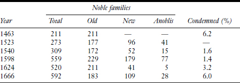

*注：* “总计”表示贵族家族总数，“旧”表示1463年之前封爵的贵族家族数量，“新”表示上一时期*选举*中出现的贵族家族数量，“阿诺布利斯*”*表示上一时期被封为贵族的新贵族家庭的数量，“谴责”表示那些被研究委员会永久谴责（拒绝贵族地位）的家族*族长*。

*Note:* “Total” denotes the total number of noble households, “Old” denotes the number of noble families that were ennobled prior to 1463, “New” denotes the number of noble families appearing in the *élection* during the previous period, “*Anoblis”* denotes the number of new noble families that were ennobled during the previous period, “Condemned” denotes those family heads permanently condemned (refused noble status) by the *Recherche* Commissions.

**表 5.3**

**TABLE 5.3**

巴约*选举*贵族人数变化率

Rates of change in numbers of nobility of the *élection* of Bayeux

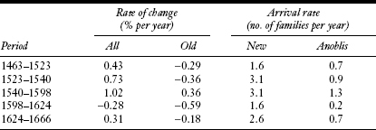

*注：* “变化率”是指期初和期末建立的贵族家庭数量的比例变化（每年的百分比）。负号表示减少。“旧”表示贵族家族在上一次*研究*之前就已经存在，“到达率”表示由于新家族（贵族移民和新近的阿诺布利斯）出现而导致贵族的比例增长（每年的家庭数量）*，* “ *Anoblis”指已知在**研究*之前的时期被封为贵族的家庭。

*Note:* “Rate of change” is the proportional change (percent per year) in the number of noble families established at the beginning of the period and the end of the period. A negative sign indicates a decrease. “Old” denotes families whose nobility dated before the previous *recherche*, “Arrival rate” denotes the proportional increase (number of families per year) in the nobility as a result of the appearance of new families (both noble immigrants and recent *anoblis*), “*Anoblis”* denotes families known to have been ennobled during the period preceeding the *recherche*.

官员数量的如此急剧增加并不是诺曼底所特有的。在法国的另一端蒙彼利埃，公职人员的数量几乎翻了两番，从 1500 年的 112 人增加到 1600 年的 442 人（Greengrass 1985：122）。据估计，1515 年，整个法国的王室官员人数略多于 4,000 人（Salmon 1976：79）。这个数字在接下来的五十年里翻了一番，然后又翻了三倍。到 1610 年法国有 25,000 名公职人员（Le Roy Ladurie 1994：275）。在 17 世纪，官员的数量剧烈波动，到 1660 年代增加到大约 50,000 人（科尔伯特下令进行的一项调查统计出有 46,047 名贪污官员）。科尔伯特政府齐心协力减少这一数字，因此到 1670 年科尔伯特声称已经压制了 20,000 个办公室（Doyle 1996：23）。到了本世纪末，路易十四政府使用一切权宜之计为一系列残酷的对外战争筹集资金，腐败办公室的数量再次增加。

Such a drastic expansion in the number of officials was not peculiar to Normandy. At the other end of France, in Montpellier, the number of officeholders almost quadrupled, from 112 in 1500 to 442 in 1600 (Greengrass 1985:122). It was estimated that in the whole of France, royal officials numbered slightly over 4,000 in 1515 (Salmon 1976:79). This number doubled during the next fifty years, then tripled again. By 1610 there were 25,000 officeholders in France (Le Roy Ladurie 1994:275). During the seventeenth century the numbers of officials oscillated wildly, increasing to perhaps 50,000 by the 1660s (a survey ordered by Colbert counted 46,047 venal officeholders). The administration of Colbert made a concerted effort to reduce this number, so that by 1670 Colbert was claiming to have suppressed 20,000 offices (Doyle 1996:23). Toward the end of the century the number of venal offices had again increased, as the government of Louis XIV used all expedients to raise money for a series of grueling foreign wars.

**表 5.4**

**TABLE 5.4**

鲁昂高级官员人数的增长

The growth of the number of high officials in Rouen

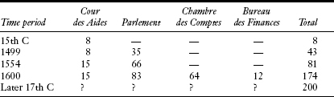

*资料来源：* Dewald (1980:69)。

*Source:* Dewald (1980:69).

*注：* 15世纪末，1499年高等法院成立之前，鲁昂只有一个主权法院（Cour *des Aides*），由八名成员组成。200 年后，17 世纪末的总督 Voysin de La Noiraye 列出了鲁昂四个主权法院的 200 名成员。这一增长的最大部分发生在 1600 年之前。在 16 世纪期间，仅议会成员就从 35 人增加到 83 人。

*Note:* In the late fifteenth century, before the establishment of parlement in 1499, there was only one sovereign court in Rouen (the *Cour des Aides*), which included eight members. Two hundred years later, the late seventeenth-century intendant Voysin de La Noiraye listed 200 members of Rouen's four sovereign courts. The lion's share of this growth occurred prior to 1600. Just the membership of parlement increased from thirty-five to eighty-three during the sixteenth century.

## **精英人数增长的原因**

## **Causes Underlying the Growth of Elite Numbers**

总而言之，1450年至1660年间，贵族数量大幅增加，其中大部分增长发生在16世纪下半叶。袍爵的数量增幅尤为惊人，但剑爵的数量也大幅增加。在巴约地区等农村地区，佩剑贵族与长袍贵族的比例大致保持不变。贵族的这种巨大扩张是如何实现的？贵族数量的变化是由两个过程决定的：既定贵族家族的自然增加和由于向上流动而产生的新贵族（ *anoblis* ）的出现。表5.3（标有“增长率”的栏）给出了巴约地区已建立的贵族家庭数量的变化率。在大多数时期，由于男性血统的失败、该地区的移民或贵族地位的丧失，已建立的家庭数量不断减少。仅在 1540 年至 98 年这一时期，家庭的自然增长才得以实现。分裂（当家庭遗产被分割给两个或更多的儿子，每个儿子建立一个单独的核心家庭）压倒了减少旧贵族数量的力量。这些动态可以通过古代贵族的数量来说明，1463 年之前封爵的贵族数量从 1463 年到 1540 年有所下降，到 1598 年有所增加，此后再次下降（表 5.3 ）。

To sum up, the numbers of nobility greatly expanded between 1450 and 1660, with the bulk of the increase occurring during the second half of the sixteenth century. The numbers of robe nobility exhibited a particularly spectacular increase, but sword nobility numbers also increased substantially. In rural areas, such as the Bayeux region, the proportion of sword to robe nobles stayed roughly constant. How was this enormous expansion of nobility accomplished? The change in the number of nobles was determined by two processes: the natural increase in established noble families and the appearance of new nobles (*anoblis*) resulting from upward mobility. Table 5.3 (the column labeled “Growth Rate”) gives the rate of change in the number of established noble families in the Bayeux region. For most time periods, the number of established families shrank, as a result of failure in the male line, emigration from the region, or loss of the noble status. In only one period, 1540–98, did the natural increase resulting from family splitting (when the family patrimony is split between two or more sons, each of whom establishes a separate nuclear family) overwhelm the forces reducing the number of old nobility. These dynamics are illustrated by the numbers of ancient nobility, those who were ennobled prior to 1463, which showed a decline from 1463 to 1540, an increase to 1598, and thereafter another decline (table 5.3).

十六世纪是向上流动性最大的时期。因为贝叶地区出现的“新”贵族大部分都是从其他地方移民而来的老贵族，所以要研究向上流动，我们需要关注那些从平民身份提升到贵族身份的个体，即*阿诺布利斯*。新晋贵族的社会出身相当多样化。但获得（和保持）贵族地位的主要要求是财富，通常基于拥有土地、办公室或两者兼而有之。因此，进入贵族的家庭已经成为精英（或精英追求者）的一部分。表 5.3表明，向上流动的动态在很大程度上与已经确立的贵族的动态相似。*anoblis*出现率整个 16 世纪不断增长，在 1540-98 年达到顶峰，然后在 17 世纪崩溃（表 5.3）。因此，1540-98 年时期不仅有利于古老贵族家庭的生存和繁衍，也有利于向上流动的平民的生存和繁衍。

The sixteenth century was the period of the greatest upward mobility. Because the majority of “new” nobles appearing in the Bayeux region were actually old nobles immigrating from elsewhere, to study upward mobility we need to focus on individuals who were elevated from commoner status to noble status, the *anoblis*. The social origins of the newly ennobled were quite diverse. But the main requirement for obtaining (and preserving) noble status was wealth, usually based on owning land, office, or both. Thus, families entering the nobility were already a part of the elite (or elite aspirants). Table 5.3 indicates that the dynamics of upward mobility largely paralleled those of already established nobility. The rate of appearance of *anoblis* grew throughout the sixteenth century, reaching a peak in 1540–98, then collapsed in the seventeenth century (table 5.3). Thus, the period 1540–98 was particularly favorable to the survival and multiplication not only of the old noble families but also of upwardly mobile commoners.

通过检查在巴黎孔子学院注册的贵族数量，可以更精确地（在具有更好的时间分辨率的意义上）了解向上流动的动态（图 5.5 ）。显然，新贵族的最大涌入并非统一发生在 1540-98 年期间，而是发生在本世纪末的宗教战争期间。内战与封爵率之间的这种相关性并不是虚假的，因为所有三个封爵高峰——1350-1410年、1570-1600年和1640-60年——都发生在社会政治高度不稳定的时期。

A more precise (in the sense of having better temporal resolution) look at the dynamics of upward mobility can be gained by examining the numbers of ennoblements that were registered with the Chambre des Comptes in Paris (figure 5.5). It is clear that the greatest influx of new nobles did not occur uniformly during the period 1540–98 but toward the end of the century, during the Wars of Religion. This correlation between civil war and the rate of ennoblements is not a spurious one, since all three peaks of ennoblement—1350–1410, 1570–1600, and 1640–60—occurred during periods of high sociopolitical instability.

## **精英收入和财富**

## **Elite Incomes and Wealth**

为什么16世纪的精英，无论是已成名的还是有抱负的，都表现得如此出色？这一时期向上流动的主要要求是拥有足够的财富。贵族本质上对任何富裕家庭开放，只要它愿意遵守规则并保持耐心。获得贵族地位的策略包括购买土地（最好是封地）、获得官职、嫁得好、送儿子上大学或服兵役。

Why did the elites, both established and aspirants, do so well during the sixteenth century? The main requirement for upward mobility during this period was possession of sufficient wealth. Nobility was essentially open to any wealthy family, if it was willing to play by the rules and be patient. Strategies for achieving noble status included purchasing land (preferably a fief), acquiring offices, marrying well, and sending sons to the university or into military service.

十六世纪中叶，精英人士和有抱负的精英人士的经济状况也很好。精英阶层繁荣的主要动力是农业收入的增长。许多诺曼领地的登陆收入是已知的，并且它们显示出相似的情况轨迹。例如，坦卡维尔县的收入在 15 世纪上半叶崩溃，然后到 1510 年略有恢复，随后到 1540 年代增长更快（Bois 1984：257）。Roncherolle 家族的总收入在十五世纪也崩溃了。1480 年至 1520 年间，名义收入有所增加。当以谷物衡量时，其真实价值停滞不前（但以“鸡肉当量”衡量时则有所增长）。然而，在 1520 年至 1570 年间，谷物和家禽的收入迅速增长（Dewald 1987：234）。十七世纪，收入停滞不前。索西庄园属于富有的鲁昂地方法官梅格纳特家族，提供了同一模式的另一个例证（表 5.5））。1480 年至 1520 年之间几乎没有变化。实际收入的大幅增长出现在 1520 年至 1560 年之间（1575 年之后，由于佃户的经济困难，收入下降）。然而，粮食收入翻番却是一个异常好的表现。

The economic situation for elites and elite aspirants was also good during the middle part of the sixteenth century. The main engine of elite prosperity was the growth of income from agriculture. Landed revenues of a number of Norman seigneuries are known, and they show similar trajectories. For example, the receipts of the county of Tancarville collapsed during the first half of the fifteenth century, then enjoyed a mild recovery to 1510, followed by more rapid growth to the 1540s (Bois 1984:257). The total income of the Roncherolle family also collapsed during the fifteenth century. Between 1480 and 1520 the nominal revenue increased. Its real value when measured in grain stagnated (but grew when measured in “chicken-equivalents”). Between 1520 and 1570, however, revenues grew rapidly, in terms of both grain and poultry (Dewald 1987:234). In the seventeenth century, revenues stagnated. The estate of Saussey, belonging to the Maignart family of wealthy Rouen magistrates, provides another illustration of the same pattern (table 5.5). There was little movement between 1480 and 1520. The great jump in real revenues came between 1520 and 1560 (after 1575 revenues declined as a result of the economic troubles of tenants). A doubling of income in grain-equivalents, however, was an unusually good showing.

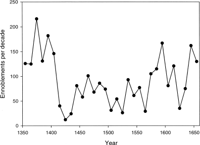

图 5.5 1350-1660 年法国的贵族封建（Schalk 1982）。

Figure 5.5 Ennoblements in France, 1350–1660 (Schalk 1982).

各阶层对十六世纪不断变化的经济环境的反应表现出极大的多样性。鲁昂长袍贵族持有的一些庄园，尤其是那些通过货币租金租赁“封地”的庄园，通货膨胀造成的损失非常严重（Dewald 1980：208）。最典型的是属于 Romé 家族的 Bec Crespin 等庄园。1517-29 年间，Bec Crespin 的所有收入（包括领地和封地）均以每年 667 里弗的价格出租（按巴黎价格计算，大约 350 升谷物）。1604 年，仅分封的领地就以 2,075 里弗（340 百升谷物）的价格出租，1638 年则以 3,150 里弗（350 百升）的价格出租。换句话说，实际总收入在 1520 年至 1600 年间有所增加，因为这个数字不包括来自直辖领的收入，然后在 17 世纪上半叶保持稳定。那些可以追踪的诺曼庄园的情况与 Bec Crispin 大致相同（Dewald 1980：208）。

The responses of estates to the changing economic circumstances of the sixteenth century showed great diversity. Losses to inflation were serious on some estates held by the robe nobility of Rouen, especially on those whose “enfeoffed domains” were leased by money rents (Dewald 1980:208). Most typical were estates such as Bec Crespin, belonging to the Romé family. In the years 1517–29 all Bec Crespin revenues (including the demesnes and enfeoffed domain) were leased for 667 livres per year (around 350 hl of grain at the Paris prices). The enfeoffed domain alone was leased for 2,075 livres (340 hl of grain) in 1604 and 3,150 livres (350 hl) in 1638. In other words, the total revenue in real terms increased between 1520 and 1600, since this number does not include the revenues from the demesne, and then stayed constant during the first half of the seventeenth century. Those Norman estates that could be followed were in much the same situation as Bec Crispin (Dewald 1980:208).

[output not shown]

总而言之，在1520年之后的半个世纪里（即瓦卢瓦周期的滞胀阶段），来自土地的平均收入至少与粮食价格保持同步，而且许多庄园的实际收入都在增长。对这种模式最可能的解释是这一时期的人口过剩，导致实际工资下降并推高实际租金。办公室的年收入也快速增长：1520年至1610年间，鲁昂地方法官收取的费用增加了八倍（Dewald 1980：158）。

In sum, during the half-century after 1520 (that is, during the stagflation phase of the Valois cycle), average revenues from land at least kept pace with the price of grain, and on many estates grew in real terms. The most likely explanation for this pattern is the overpopulation during this period, which drove down real wages and pushed up real rents. Yearly income from office also increased at a rapid pace: between 1520 and 1610, fees charged by the magistrates of Rouen increased eightfold (Dewald 1980:158).

我们可以通过查看蒙彼利埃公职人员的工资来检查这些结果（Greengrass 1985：122）。这些数据不具有严格的可比性，因为对于鲁昂的地方法官，我们有总收入的估计（这是衡量他们经济福祉的更好指标），而对于蒙彼利埃这些数据指的是官员的工资（理论上）。此外，鲁昂的数据针对的是省长袍贵族中的一个特别特权阶层。然而，两个数据集共享一些模式（表 5.7）。特别是，官方数字及其给社会造成的成本（按实际价值计算）大幅增加。其次，官员数量的增长特别迅速是在16世纪后25年，当时鲁昂和蒙彼利埃的官员数量都翻了一番，而这种数量的增长伴随着平均收入或工资的下降。

We can check these results by looking at the salaries of officeholders in Montpellier (Greengrass 1985:122). The data are not strictly comparable, because for Rouen's magistrates we have estimates of total income (which is a better measure of their economic well-being), while for Montpellier the data refer to salaries, with which the officials were (theoretically) remunerated. Furthermore, the Rouen data are for a particularly privileged stratum of the provincial robe nobility. Nevertheless, some patterns are shared by both data sets (table 5.7). In particular, there was a great expansion of official numbers as well as of their cost to society (in real terms). Second, the particularly rapid expansion of numbers of officials came during the third quarter of the sixteenth century, when their numbers doubled at both Rouen and Montpellier, and this numerical expansion was accompanied by a drop in the average income or salary.

**表 5.6**

**TABLE 5.6**

鲁昂议员的收入，1500 年至 1600 年

Incomes of parlementaires of Rouen, 1500–1600

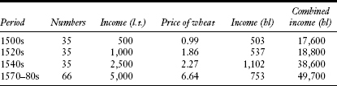

*资料来源：* Dewald (1980)。

*Source:* Dewald (1980).

*注：*单位：lt、*livretournois；*hl，百升。

*Note:* Units: l.t., *livre tournois;* hl, hectoliter.

**表 5.7**

**TABLE 5.7**

蒙彼利埃皇家官员的薪水，1500–1600 年

Salaries of royal officers in Montpelier, 1500–1600

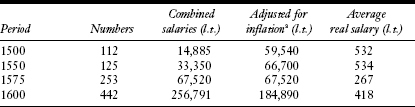

*资料来源：* Irvine (1979)，引自 Greengrass (1985：表 6.1 )。

*Source:* Irvine (1979), cited in Greengrass (1985:table 6.1).

<sup>a</sup>工资以 1575 年为基础，根据通货膨胀进行调整。

<sup>a</sup> Salaries are adjusted for inflation, taking the year 1575 as a base.

研究贵族其他阶层的收入动态将是非常有趣的，但不幸的是，缺乏此类调查的直接数据。然而，德瓦尔德通过检查婚姻合同得以一睹风采，婚姻合同提供了不同群体相对财富的大致了解。从 16 世纪上半叶到 1600 年左右，议会婚姻中的嫁妆中位数增加了六倍（表 5.8）。回想一下，年收入增加了大约相同的数量级，从 1,000 里弗增加到 5,000 里弗（表 5.6）。另一方面，小士绅（ *écuyiers* ）的嫁妆只增加了一倍，而律师（ *avocats ）的嫁妆却增长了两倍。*）婚姻介于小贵族和议员之间（表5.8）。同一时期，小麦价格上涨了约四倍。换句话说，小贵族正在节节败退，大法官们正在取得领先，而律师们则刚刚收支平衡，或者可能略有下滑。

It would be very interesting to examine the dynamics of the incomes of other segments of the nobility, but unfortunately, direct data for such an investigation are lacking. Dewald, however, was able to obtain a glimpse by examining marriage contracts, which provide an approximate idea of the relative wealth of different groups. Between the first half of the sixteenth century and around 1600 the median dowry in parlementaire marriages increased sixfold (table 5.8). Recollect that the annual income increased by about the same order of magnitude, from 1,000 to 5,000 livres (table 5.6). The dowries of lesser gentry (*écuyiers*), on the other hand, increased only twofold, while the growth of dowries in lawyer (*avocats*) marriages was intermediate between those of lesser gentry and parlementaires (table 5.8). During the same period wheat prices increased about fourfold. In other words, the lesser gentry were losing ground, the parlementaires were getting ahead, and the lawyers were just breaking even, or perhaps slightly slipping.

|  | **表 5.8** **TABLE 5.8** |  |  |  |
| --- | --- | --- | --- | --- |
|  | 诺曼底的嫁妆，1500–1614 年 Dowries in Normandy, 1500–1614 |  |  |  |
|  |  | *嫁妆中位数（lt）* |  |  |
|  | *社会阶层* | *1500–1550* | *1568–1614* |  |
|  | 小士绅 | 1,320 | 2,625 |  |
|  | 律师 | 1,375 | 5,368 |  |
|  | 议会党人 | 4,500 | 27,000 |  |
|  | *资料来源：* Hallam 估计 (1988b:537)。 *Source:* Estimated by Hallam (1988b:537). |  |  |  |

## **精英的压缩**

## **Compression of the Elites**

The basic problem facing the nobility was the irreconcilable contradiction between two processes: total production stagnated after 1540 and even declined toward the end of the century, while the numbers of the elites grew inexorably. One result of this dynamic was increasing exploitation of peasants, but there were biological limits on how low the standard of living of the productive class could be driven. The second consequence, therefore, was the lower real income per elite capita. This does not mean that all elite families suffered equally. On the contrary, the basic dynamic, at least for a while, was for the rich to get richer while the poor got poorer (this is typical of the stagflation and crisis phases of secular cycles). Thus, the real income of the lesser gentry was declining by 1600, while the privileged segment of the robe nobility, the parlementaires, was growing more wealthy.

然而，在议会阶层内部，同样的基本动力也在发挥作用。1499 年至 1600 年间，议员人数从 35 名增加到 83 名（表 5.4）。这种增长的直接原因是国王的财政困难，这一问题通过定期出售新设立的腐败办公室得到了部分解决。但同样重要的是要认识到此类办公室的需求量很大。事实上，随着贪污办公室数量的增加，它们的价格以惊人的速度上涨（Doyle 1996：11）。鲁昂议会的议员席位在 1570 年代售价不到 5,000 立弗，在 1580 年代售价为 10,000 升，在 1600 年代售价为 20,000 升。到 1615 年，它再次翻了一番，到 1634 年又翻了一番，到 1670 年代，它达到了议会办公楼价格的最高点，当时的估价为 88,000 升（Dewald 1980：138-40）。大约一半的增长是由于通货膨胀，但大多数（实际增长近十倍）是由激烈的精英内部竞争推动的。从经济上来说，办公室的成本没有意义；这些办公室因其超经济价值——地位而受到重视。这种解释被领地（封地）价格上涨所证实，领地是另一种主要因其超经济价值而寻求的财产。封地价值的膨胀表现为封建财产回报率的稳步下降：从 16 世纪初（1507 年）的 10% 下降到 1563-97 年的 4-4.5%、1601 年的 3.3% 和 1627 年的 2.2%（Dewald 1980） ：203）。

Within the parlementaire stratum, however, the same basic dynamic was also operating. Between 1499 and 1600 the numbers of parlementaires grew from thirty-five to eighty-three (table 5.4). The proximate reason for this growth was the Crown's fiscal difficulties, which were partially solved by a periodic sale of newly established venal offices. But it is also important to recognize that such offices were in great demand. In fact, as the number of venal offices was expanded, their price rose at a spectacular rate (Doyle 1996:11). A councillorship in the Parlement of Rouen sold for less than 5,000 livres in the 1570s, 10,000 l.t. in the 1580s, and 20,000 l.t. in the 1600s. It doubled again by 1615, yet again by 1634, and by the 1670s it had reached the highest point for office prices in the parlements, when it was evaluated at 88,000 l.t. (Dewald 1980:138–40). About half of the rise was due to inflation, but most (an almost tenfold increase in real terms) was driven by an intense intraelite competition. Economically, this increase in the cost of the office did not make sense; the offices were valued for their extraeconomic value—status. This interpretation is confirmed by the growing price of the seigneuries (fiefs), another kind of property sought primarily for its extraeconomic value. This inflation of fief values is indicated by the steadily decreasing returns on seigneurial property: from 10 percent in the early sixteenth century (1507) to 4–4.5 percent in 1563–97, 3.3 percent in 1601, and 2.2 percent in 1627 (Dewald 1980:203).

**表 5.9**

**TABLE 5.9**

主要总督的平均嫁妆 (lt)，1493–1663

Average dowries (l.t.) of major governors, 1493–1663

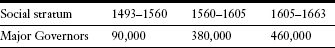

*资料来源：* Harding (1978:114)。

*Source:* Harding (1978:114).

The rising costs of office, coupled with the rising costs of education (Dewald 1980:135–36), had dramatic effects on the economics of officeholding. Until about 1570 offices were sold for prices corresponding to the economic returns they offered. After the great office inflation of 1570–1630, offices were bought for prestige or the political importance they offered (Dewald 1980:143). By 1610 the chances of creating a new fortune from the profits of office had become very small (Dewald 1980:160). Whereas officeholding was one of the routes for upward mobility during the sixteenth century, the magistrate stratum became increasingly closed after 1600. The situation in Rouen mirrored more general developments in France as a whole. Prior to 1600, merchant families often moved directly into royal courts by buying an office in a chamber of accounts or even a parlement for their sons. After 1600, this mechanism for social mobility to the highest levels of the robe slowed down, and two or three generations of royal office, each one more exalted than the last, were generally required (Collins 1995:41). The seventeenth-century tendency of slower upward mobility is reflected in the social origin of the members of Parlement. In the mid-sixteenth century only 20 percent of them were sons of high officials; a century later 60 percent followed in their fathers’ footsteps (table 5.10).

因此，十七世纪是鲁昂长袍贵族的紧缩时期。他们的人数基本上停止增长（表 5.4），并且他们的向上流动实际上被阻止了。巴约的乡村贵族也观察到了类似的模式。*1540-98年间， anoblis*家族的出现率达到了每年1.3个家族的峰值，然后在17世纪的前三分之二期间下降到每年0.2-0.7个家族（表5.3 ）。与此同时，对接受向上流动家庭的贵族身份的抵制也在加剧。而期间16世纪只有1.4-1.6%的假装贵族身份的家庭受到谴责（否认贵族身份），这一比例在17世纪上半叶上升到3.2%，在下半叶上升到6%（表5.2） 。请注意，在 15 世纪（1462 年为 6.2%），贵族比例又回到了之前的峰值，这是另一个贵族压缩时期。

The seventeenth century thus was a period of retrenchment for the robe nobility of Rouen. Their numbers essentially ceased to grow (table 5.4), and upward mobility into their ranks was practically choked off. A similar pattern was observed for the rural nobility of Bayeux. The rate of appearance of *anoblis* families reached a peak of 1.3 families per year during 1540–98, then dropped off to 0.2–0.7 families per year during the first two-thirds of the seventeenth century (table 5.3). At the same time, resistance to accepting the nobility of upwardly mobile families intensified. Whereas during the sixteenth century only 1.4–1.6 percent of families pretending to the noble status were condemned (denied the noble status), this proportion rose to 3.2 percent during the first half of the seventeenth century and to 6 percent during the second half (table 5.2). Note the cyclic return of the proportion condemned to the previous peak during the fifteenth century (6.2 percent in 1462), another period of nobility compression.

**表 5.10**

**TABLE 5.10**

议员的社会起源

Social origins of parlementaires

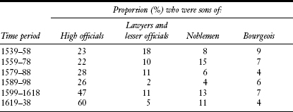

*资料来源：* Dewald (1980)。

*Source:* Dewald (1980).

与此同时，进入贵族阶层的向上流动受到阻碍，有抱负的精英群体的规模明显缩小。正如我们之前提到的，获得贵族地位的途径之一是获得贵族封地（seigneurie）。由于平民拥有的封地比例是已知的，我们可以用它来了解向上流动阶层的规模。平民拥有的封地收入的比例从1552年的8%增加到1587年的13%，然后在1640年下降到2%（Wood 1980:147）。换句话说，在 16 世纪下半叶，有抱负的精英人数有所增加，而在 17 世纪上半叶则缩减至几乎为零。同一时期，旧贵族持有的封地比例（按价值计算）从 52% 增加到 72%，而新贵族所占比例则从17%下降到12%。显然发生的事情是，在十六世纪和十七世纪初，精英野心家将他们所拥有的封地转变为贵族地位。1600年后，随着向上流动性的下降，前精英野心家的后代首先成为新贵族，然后成为老贵族。

At the same time that upward mobility into the ranks of nobility was choked off, the size of the group of elite aspirants apparently shrank. As we mentioned earlier, one of the routes to noble status was the acquisition of a noble fief (seigneurie). Since the proportion of fiefs held by commoners is known, we can use it to obtain an idea of the size of the upwardly mobile stratum. The proportion of income from fiefs held by commoners increased from 8 percent in 1552 to 13 percent in 1587, and then declined to 2 percent in 1640 (Wood 1980:147). In other words, during the second half of the sixteenth century, the pool of elite aspirants grew, whereas during the first half of the seventeenth century it shrank to almost zero. During the same period the proportion of fiefs (by value) held by the old nobility increased from 52 percent to 72 percent, while the proportion held by new nobility declined from 17 percent to 12 percent. What apparently happened was that elite aspirants converted their holdings of fiefs into noble status during the sixteenth century and the early seventeenth century. As upward mobility dropped off after 1600, the descendants of the former elite aspirants became first new nobles and then old nobles.

While the proportion of old nobility among the landed elites increased, the total numbers of rural nobles in Normandy probably declined toward 1700. We do not have the data for the Bayeux region, but in another rural *élection*, that of Gisors, there were seventy-four noble households out of the total of 7,500 in 1703, or about 1 percent of the population (Dewald 1987:91). In the *élection* of Rouen (excluding the city of Rouen), there were only 154 rural noble families out of population of 17,514, or less than 1 percent, in 1703. However, the regional capital was the home of additional 272 noble households and about 160 families of high royal officials (Dewald 1987:91).

[output not shown]

而 16 世纪下半叶，农村贵族的收入受到侵蚀（表 5.8），这种衰退被阻止，甚至在 17 世纪中叶的某个时候出现了逆转。我们很幸运能够获得 1639 年和 1666 年两个时间点贝叶地区贵族收入分配的数据（Wood 1980：127-28）。这两个日期之间，家庭平均收入从 1,400 升上升至 1,900 升。由于这两个日期里弗的实际价值大致相同，因此名义上 34% 的增长代表了贵族收入的实际增长。但收入中位数发生了更显着的变化：从不足 400 立特到 1,000 立特，而超过三分之二的贵族的收入不足 1,000 立特，到 1666 年，这一比例已降至不到一半（表5.11）。包括最富有贵族在内的类别也略有下降；增加的是“中产阶级”，反映了财富不平等程度的下降。

Whereas the second half of the sixteenth century saw an erosion of incomes of the rural nobility (table 5.8), this decline was stopped, and even reversed sometime in the mid-seventeenth century. We are fortunate to have data on income distribution among the nobility of the Bayeux region at two points in time, 1639 and 1666 (Wood 1980:127–28). Mean family income rose from 1,400 to 1,900 l.t. between the two dates. Since the real value of a livre was approximately the same at these two dates, this 34 percent increase in nominal terms represents a real increase in noble incomes. But an even more striking change occurred in the median income: from less than 400 l.t. to 1,000 l.t. Whereas more than two-thirds of nobles disposed of an income of less than 1,000 l.t., by 1666 this proportion had declined to less than half (table 5.11). The category including the richest nobles also declined slightly; it was the “middle class” that increased, reflecting the declining degree of wealth inequality.

The purging of nobility of its poorest members continued during the first half of the eighteenth century. In the *élections* of Gisors and rural Rouen (excluding the city), the proportions of noble families with incomes of less than 1,000 l.t. declined to 46 and 41 percent in 1703 and to 11 and 16 percent in 1757, respectively (Dewald 1987:115). What was apparently happening was that poor nobles were dropping out of the ranks of nobility, while the number of better-off nobles (those with more than 1,000 l.t. of annual income) stabilized. Thus, in the rural Rouen region, there were ninety-one such nobles in 1703 and eighty-eight in 1757, while in Gisors there were forty such nobles in both 1702 and 1757 (calculated from Tables 32 and 33 in Dewald 1987). The proportion of impoverished nobles, however, began increasing again during the second half of the century, and on the Revolution's eve (1788) the proportions of poor nobles increased to 26 percent and 17 percent in the two *élections* (Dewald 1987:115).

## **结论**

## **Conclusions**

Is there a general pattern underlying the material we have reviewed in this section? It appears so. The pattern is that the numbers (or, more precisely, the noble to commoner ratio) and per capita wealth of nobility existed in a state of dynamical interrelation. A decline in the noble-commoner ratio has a beneficial effect on noble incomes. Vice versa, increasing the number of nobles in relation to commoner numbers had a depressing effect on the mean incomes, and an even greater effect on the proportion of poor nobles. Incomes enjoyed by noble families also affected their numbers (this is a kind of feedback loop), because high incomes promoted family multiplication and upward mobility while low incomes compressed nobility by squeezing out the poorest stratum. The system was not dynamically closed, however, because it was affected by such factors (which themselves vary with the phase of the secular cycle) as commoner numbers (for example, high commoner numbers drive up rents and depress wages, benefiting the elites) and sociopolitical instability. On the one hand, civil wars sped up the ennoblement rate of elite aspirants, but on the other hand they elevated mortality, especially for young males. One overall effect of civil wars, thus, is a diminishing pool of elite aspirants—wealthy commoners and the younger sons of nobility—resulting in a (perhaps temporary) relief of the social pressure.

## 5.6 萧条（1600–1660）

## 5.6 Depression (1600–1660)

## **南北人口趋势的差异**

## **Diverging Population Trends between North and South**

法国不同地区的人口轨迹存在显着差异。法国是一个多元化的大国，其许多地区预计不会同步波动。我们可以利用什一税、人口统计和内战发生率的数据来追踪各地区的不同轨迹。我们在这里关注的主要区别是讲法语的北部和讲奥克西唐语的南部之间的区别。次要的兴趣区是法国北部的种族边缘，即布列塔尼、佛兰德斯，尤其是阿尔萨斯，当时阿尔萨斯更多地处于德国政治的轨道上，而不是法国政治的轨道上。

Different regions of France exhibited significant variations in their demographic trajectories. France is a large and diverse country, and its many regions would not be expected to oscillate in synchrony. We can trace the divergent trajectories of regions using the data on tithes, demography, and the incidence of internal warfare. The main distinction we focus on here is that between the French-speaking north and the Occitan-speaking south. Secondary divisions of interest are the ethnic fringes of northern France, namely, Brittany, Flanders, and above all Alsace, which at that time was much more in the orbit of German rather than French politics.

The tithe records discussed by Le Roy Ladurie indicate that both the south and the north followed trajectories of the same shape, which, however, were shifted with respect to each other by twenty years. The fifteenth century's minimum in the south occurred between 1400 and 1430, and the expansion took off between 1430 and 1450. In the north, the minimum occurred during the 1440s, and the expansion started only after 1450, probably as a result of a lag in the incidence of war-caused disasters (Le Roy Ladurie 1987:44–45). A century later the south was the first to achieve the maximum (around 1540), and thereafter production stayed flat to 1560. In the north the maximum was achieved twenty years later. The south was again the first to be affected by the devastation of the Wars of Religion. The documents on the sale of church property support the tithe records and indicate that by 1568 there was a “red zone” of maximum damage centered on Poitou, Aquitane, and Languedoc. This is where religious conflicts were the most intense and where the productive capacity was most seriously undermined by the conflict. By 1583 the worst affected zones were again in the Occitanian heartland: Aquitaine, Gascony, Languedoc, Rouergue, Auvergne, and Dauphiné. During the 1590s the war spread to the north. Normandy, Ile-de-France, Picardy, and Champaigne were all affected by the final convulsions of the Catholic League. However, the south was also subjected to continuing damage (Le Roy Ladurie 1987:251). Tithe records show three bad periods for Languedoc and the Mediterranean south. The first production fall (36 percent) occurred right after the outbreak of war in 1560. The second wave hit during the 1570s, when production was 43 percent less than the prewar level (1532–50). The third difficult period was between 1583 and 1596, when the average delivery of tithes was 36 percent below the prewar level (Le Roy Ladurie 1987:263). The adjacent regions were affected almost as badly. Auvergne lost 35–40 percent of its productive capacity, and Lyonnais lost 40 percent.

法国北部也经历了产量大幅下降，但直到 1590 年代才出现，而且总体上受破坏程度比南部要少。总体而言，北部地区损失了 33%，而巴黎地区仅损失了 20% 至 25%（什一税损失 25%，租金损失 16%）。法国东部的跌落深度与南部相似，但崩溃的时间与北部相同。因此，在勃艮第，什一税（实物）的净产品在 1588 年至 1600 年间急剧下降。这 12 年的谷物什一税比 1550-68 年的繁荣时期下降了 43%（Le Roy Ladurie 1987：262-63） 。最后，16 世纪受影响最小的地区是阿尔萨斯，那里的什一税净产品仅下降了 7.3%（Le Roy Ladurie 1987：265）。

The French north also experienced a significant drop in production, but it did not occur until the 1590s, and generally there was less devastation than in the south. Overall, the regions in the north lost 33 percent, while the Paris region lost only 20–25 percent (25 percent in tithes and 16 percent in rents). Eastern France was similar to the south with respect to the depth of the fall, but the timing of the collapse was the same as in the north. Thus, in Burgundy, the net product of tithes (in kind) fell spectacularly between 1588 and 1600. Grain tithes during these twelve years fell 43 percent in relation to the prosperous period of 1550–68 (Le Roy Ladurie 1987:262–63). Finally, the least affected region in the sixteenth century was Alsace, where the net product of tithes fell only 7.3 percent (Le Roy Ladurie 1987:265).

在十七世纪，不同地区的发展轨迹继续出现分歧（并且失去了平行性）。地中海南部似乎逃脱了 17 世纪中叶的经济和人口灾难（Le Roy Ladurie 1987：278）。那里的什一税从 1580 年代的最低限度一直扩大到 1670 年代，之后再次下降（图 5.6）。事实上，南方进入了从1680年持续到1740年甚至1750年的长期人口下降时期（Le Roy Ladurie 1974:295, 317）。

During the seventeenth century the trajectories of different regions continued to diverge (and the parallelism was lost). The Mediterranean south seems to have escaped the economic and demographic catastrophes of the mid-seventeenth century (Le Roy Ladurie 1987:278). The tithes there expanded from the minimum of the 1580s until the 1670s, after which they again declined (figure 5.6). In fact, the south entered a period of long-term population decline that lasted from 1680 to 1740 or even 1750 (Le Roy Ladurie 1974:295, 317).

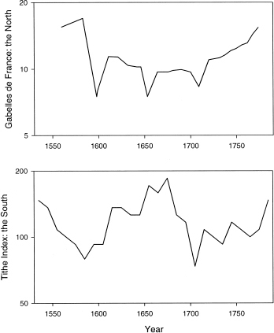

图 5.6 1500 年代中期至 1700 年代中期法国北部和南部的不同轨迹。(a) Gabelles de France 的收入（Le Roy Ladurie 1987：288），反映了北部的经济状况。(b) 南部的什一税（Le Roy Ladurie 和 Goy 1982）。

Figure 5.6 Diverging trajectories in northern and southern France, mid-1500s to mid-1700s. (a) Revenues from Gabelles de France (Le Roy Ladurie 1987:288), reflecting economic conditions in the north. (b) Tithes in the south (Le Roy Ladurie and Goy 1982).

在北方，经历了1590年代的灾难之后也出现了复苏，但与南方相比，复苏是短暂的。王国的最东北部和北部地区受到三十年战争（1618-48）期间战斗的影响。因此，在阿尔萨斯（当时不属于法国的一部分，但我们有关于那里生产的良好数据），粮食什一税跌至其峰值的不到 10%（Le Roy Ladurie 和 Goy 1982）。即使在和平结束后的 1650 年代，产量也仅为 1620 年的 30%。康布雷西斯等北部地区也因法国和西班牙之间的军事行动而遭到破坏。然后是投石党运动，这对中部地区造成的破坏尤其严重王国的。因此，从 1500 年到 1790 年，博纳周围的什一税收益率曲线显示出 1590 年左右的低点，以及从 1640 年到 1660 年的低点，随后从 1660 年到 1720 年上升（Benedict 1985：86）

In the north, there also was a recovery after the catastrophe of the 1590s, but in contrast to the south, the recovery was short-lived. The extreme northeast and north of the kingdom was affected by the fighting during the Thirty Years’ War (1618–48). Thus, in Alsace (not a part of France at that time, but we have good data on production there), grain tithes collapsed to less than 10 percent of their peak value (Le Roy Ladurie and Goy 1982). Even after the peace, during the 1650s, production was only 30 percent of that in 1620. Northern regions such as Cambrésis were also devastated by military operations between the French and Spanish. Then came the Fronde, which was particularly devastating in the central regions of the kingdom. Thus, the curve of tithe yields around Beaune from 1500 to 1790 shows lows around 1590 and again from 1640 to 1660, followed by a rise from 1660 to 1720 (Benedict 1985:86)

在朗格多克和地中海南部，实物什一税在 17 世纪初恢复，曲线随后在 1640 年左右趋于平缓。然而，什一税并没有完全恢复到 16 世纪中叶的水平（可能低了 5%） 。在奥弗涅，产量仍然比 16 世纪的峰值低 15%，在勃艮第则低 13%，而里昂的什一税也停滞不前，除了里昂周边地区。总体而言，什一税记录表明，王国的生产能力在十七世纪初有所恢复，但并未超过先前在十六世纪中叶达到的水平。这种模式的主要例外是巴黎周边地区，其显然超过了十六世纪的水平。因此，巴黎圣母院庄园的租金（实物）净值比 1580 年代的峰值增加了 44%（Le Roy Ladurie 1987:302）。然而，很难确定这种增长有多少是由于产量增加，有多少是由于对农民的剥削加剧。

In Languedoc and the Mediterranean south, tithes in kind recovered during the early seventeenth century, and the curve then flattens out around 1640. However, the tithes did not completely regain their level of the mid-sixteenth century (they were perhaps 5 percent below). In Auvergne, production remained 15 percent below the sixteenth-century peak, in Burgundy 13 percent below, and in the Lyonnais tithes also stagnated, except in the region around Lyons. Overall, the tithe records suggest that the productive capacity of the kingdom recovered during the early seventeenth century but did not exceed the previously achieved level of the mid-sixteenth century. The major exception to this pattern was the region around Paris, which apparently exceeded the sixteenth-century level. Thus, the net product in rents (in kind) from the estates of Notre-Dame-de-Paris increased to 44 percent above the previous peak in the 1580s (Le Roy Ladurie 1987:302). However, it is hard to decide how much of this increase was due to greater production and how much to greater exploitation of peasants.

## **顶级财富的增长**

## **Growth of Top Fortunes**

顶级财富的动态通常可以提供有关经济不平等波动的有用指标。毫无疑问，十七世纪法国最大的私人财富属于儒勒·马扎林（Jules Mazarin），他是路易十四未成年时期臭名昭著的首相。十七世纪部长们的命运就像坐过山车一样令人眼花缭乱。亨利四世的大臣苏利于 1610 年被迫辞职，他去世时估计获得了 520 万里弗的财富（Barbiche 1978）。1642 年黎塞留去世后，给他的继承人留下了 2200 万里弗的财产（Bonney 1999：127）。这是一笔巨大的财富，但马扎林的财富更胜一筹，他给他的继承人留下了 3700 万里弗的财富（Bonney 1999：127）。这是一项特别引人注目的成就，因为这是从 1653 年（马扎林在 1648-53 年投石党运动期间失去了他之前的大部分财富）到他于 1661 年去世之间的八年时间里完成的。第二梯队的部长们也做得非常好。黎塞留的财政部长克洛德·布利恩（Claude Bullion，1632-40 年）在短短八年的任期内就积累了 780 万里弗的财富。尼古拉斯·福凯 (Nicolas Foucquet) 1661 年被捕时，他的资产评估超过 1540 万里弗（尽管他的债务等于他的资产）。

The dynamics of the top fortunes often provide a useful indicator about fluctuations in the economic inequality. The largest private fortune of seventeenth-century France belonged, without a doubt, to Jules Mazarin, the notorious prime minister during the minority years of Louis XIV. Ministerial fortunes went on a dizzying roller-coaster ride during the seventeenth century. Henri IV's minister Sully, who was forced to resign his position in 1610, gained a fortune estimated at his death as 5.2 million livres (Barbiche 1978). On his death in 1642, Richelieu left his heirs a fortune of 22 million livres (Bonney 1999:127). This was a tremendous amount of wealth, but it was bettered by Mazarin, who left a fortune of 37 million livres to his heirs (Bonney 1999:127). This was a particularly striking achievement, because it was accomplished in eight years, between 1653 (Mazarin lost most of his previous wealth during the Fronde of 1648–53) and his death in 1661. Second-echelon ministers also did extremely well. Claude Bullion, Richelieu's finance minister (1632–40), gained a fortune of 7.8 million livres in just eight years of office. Nicolas Foucquet's assets were evaluated in excess of 15.4 million livres at the time of his arrest in 1661 (although his debts equaled his assets).

为了正确看待这些数字，我们可以将它们与已知的最伟大贵族家族的财富进行比较。的财富波旁王朝的一个分支，与国王孔蒂亲王关系密切，在 1655-65 年拥有 1200 万里弗，然后在 1670 年代下降到 760 万里弗（Mougel 1971）。内韦尔公爵路易斯·冈萨格斯留下了 800 万美元的遗产，然而，这笔遗产却被总计 250 万美元的债务所拖累（Harding 1978）。最富有的贵族家族可能是孔代亲王的家族。十八世纪初期，其总财富由几个分支机构分享，估计为 3100 万里弗（Roche 1967）。

To place these numbers in perspective, we can compare them to what is known about the fortunes of the greatest noble houses. The fortune of one branch of the Bourbons, closely related to the king, the princes de Conti, was 12 million livres in 1655–65 and then declined to 7.6 million during the 1670s (Mougel 1971). Louis Gonzagues, Duc de Nevers, left an inheritance of 8 million, which was, however, encumbered by debts totaling 2.5 million (Harding 1978). The wealthiest noble house was probably that of the princes de Condé. Its total fortune in the early eighteenth century, shared among several branches, was estimated as 31 million livres (Roche 1967).

路易十四统治时期，公职大臣的私人收益规模开始得到控制。科尔伯特的财富估计在 4.95 至 575 万之间，可能接近高端。卢瓦在长达二十年（1672-91）的职业生涯中获得了约 800 万美元的财富。“1720 年之后，与 1661 年之前的情况相比，部长们从办公室获得的收益确实微不足道”（Bonney 1999：127）。

The scale of private gains by ministers from public office began to be brought under control during the reign of Louis XIV. Colbert's wealth was estimated at between 4.95 and 5.75 million, probably closer to the high end. Louvois gained a fortune of some 8 million in a career spanning two decades (1672–91). “After 1720, ministerial gains from office were small beer indeed compared to the situation before 1661” (Bonney 1999:127).

## **瓦解趋势的逆转**

## **Reversal of the Disintegrative Trend**

显然，1661年路易十四的个人统治标志着法国历史上的一个重要转折点。最引人注目的发展是精英围绕中心的巩固，这结束了困扰过去百年的精英内部冲突，并将精英的能量引导到外部征服战争中。威廉·贝克（William Beik，1985，2005）以朗格多克省贵族为例，对精英与国家之间如何达成共识的内部运作进行了令人钦佩的探讨。从本质上讲，最后一个社会政治高度不稳定的时期，以 1648-53 年投石党运动达到顶峰，迫使精英们明白他们需要中央的军事、外交和经济保护（Beik 1985：331）。1560年至1660年间，参与内战的各派别要么完全由精英组成，要么是精英动员的民众起义。1660年后，精英们撤回了领导权，起义急剧下降（Beik 1985：12）。后来的民众起义，例如塞文山脉农民的起义（1702-4），缺乏精英阶层的支持，很容易被镇压。

It is clear that the assumption of personal rule by Louis XIV in 1661 marked an important turning point in the history of France. The most dramatic development was the consolidation of the elites around the center, which ended the intraelite conflict that had plagued the preceding hundred years and channeled elite energies into wars of external conquest. The internal workings of how this consensus between the elites and the state was achieved has been admirably probed by William Beik (1985, 2005), using as an example the provincial aristocracy of Languedoc. Essentially, the last period of high sociopolitical instability, peaking with the Fronde of 1648–53, forced the elites to understand that they needed military, diplomatic, and economic protection of the center (Beik 1985:331). Between 1560 and 1660 various factions fighting in civil wars were either entirely composed of the elites or were elite-mobilized popular uprisings. After 1660 the elites withdrew their leadership, and uprisings dramatically declined (Beik 1985:12). Later popular uprisings, such as the rebellion of Cévennes peasants (1702–4), lacked support among the elites and were easily put down.

新的共识使得路易十四政府将税收提高到了法国历史上前所未有的水平（见图5.2）。当然，精英阶层是主要受益者。首先，1647年和1677年皇家和地区精英之间税收流量的比较分配（Beik 1985：267）表明，至少在朗格多克，地区精英能够增加保留在该省的税收份额。其次，大部分税收用于资助路易十四的战争，这意味着改善剑贵族的就业。此外，至少在十七世纪末，路易的对外征服计划非常成功。

The new consensus allowed the government of Louis XIV to raise taxes to an unprecedented level in French history (see figure 5.2). The elites were, of course, the primary beneficiaries. First, the comparative distribution of tax flow between crown and regional elites in 1647 and 1677 (Beik 1985:267) shows that at least in Languedoc the regional elites were able to increase the share of taxes that remained in the province. Second, the lion's share of taxes went toward financing the wars of Louis XIV, which meant improved employment for the sword nobility. Furthermore, at least during the late seventeenth century, Louis's program of external conquest was highly successful.

然而，精英阶层的巩固和法律与秩序的重建并没有立即结束人口停滞状态，因为持续的人口扩张是在 1720 年之后才开始的。实际工资持续增长，直到 1680 年代（见图 5.1）。）（尽管即使在高峰期，实际工资还不到十五世纪初“黄金时代”的一半）。雅卡尔“挖掘”并由勒罗伊·拉杜里（Le Roy Ladurie）讨论的农业工资（1987：352）遵循相同的总体模式，至少在巴黎周围如此。1700 年左右的二十年里，人口再次大幅下降，尽管决定性（或至少是一个非常重要的影响）因素似乎是气候恶化。人口持续增长期从 1719 年之后开始，一直持续到 1790 年（Dupâquier 等人，1988b：151）。因此，尽管精英和国家动态在 1660 年左右出现了拐点，但人口和经济趋势表明，到本世纪末仍将持续停滞。这似乎是一个例子，说明现实生活中的动态可能不适合将世俗周期整齐地划分为各个阶段。

The consolidation of the elites and reestablishment of law and order, however, did not immediately end the regime of population stagnation, since sustained demographic expansion began only after 1720. Real wages continued to increase until the 1680s (see figure 5.1) (although even at its peak, the real wage was less than half that of the “golden age” of the early fifteenth century). Agricultural wages “exhumed” by Jacquart and discussed by Le Roy Ladurie (1987:352) followed the same general pattern, at least around Paris. The two decades around 1700 saw another substantial population decline, although the determining (or at least a very important contributing) factor appears to be worsening of the climate. A sustained period of population growth began only after 1719 and lasted to 1790 (Dupâquier et al. 1988b:151). Thus, although the elite and state dynamics turned a corner around 1660, the demographic and economic trends indicated continuing stagnation to the end of the century. This appears to be an example of how real-life dynamics may not fit the neat division of the secular cycle into phases.

## 5.7 结论

## 5.7 Conclusion

从很多方面来说，瓦卢瓦周期（1450-1660）是人口结构机制发挥作用的另一个教科书例子。我们幸运的是，历史记录足以让我们用具体而详细的历史数据来检验该理论所假设的许多机制（并且这一时期引起了伊曼纽尔·勒罗伊·拉杜里（Emmanuel Le Roy Ladurie）等巨头的关注）。这些过程包括人口增长的马尔萨斯效应，以及人口增长和精英生产过剩如何导致国家崩溃。对诺曼贵族的案例研究为我们揭示了精英生产过剩如何发展以及它对精英本身以及社会体系其他组成部分产生的后果提供了很多线索。

In many ways the Valois cycle (1450–1660) is another textbook example of demographic-structural mechanisms in action. We are lucky in that the historical record is good enough for us to test many mechanisms postulated by the theory with concrete and detailed historical data (and that this period attracted the attention of such giants as Emmanuel Le Roy Ladurie). These processes include the Malthusian effects of population growth, and how population growth and elite overproduction causes state breakdown. The case study of Norman nobility has thrown a lot of light on how elite overproduction develops and what consequences it has for the elites themselves as well as for other components of the social system.

杰克·戈德斯通（Jack Goldstone，1991）在他的开创性著作中没有以任何有意义的方式讨论法国宗教战争的先决条件（尽管他用了一些篇幅来讨论后来的冲突，即投石党运动）。然而，自 1559 年以来法国发生的事情与他在研究其他国家崩溃时发现的模式非常吻合——国家财政崩溃、失去对军队的控制、精英内部派系斗争和竞争加剧，以及最终全面爆发的内政。战争。

In his pathbreaking work, Jack Goldstone (1991) did not discuss in any significant way the preconditions of the French Wars of Religion (although he devoted some space to a later conflict, the Fronde). Yet what happened in France from 1559 on matches very well the patterns he discerned in his study of other state collapses—the financial ruin of the state, its loss of control over the military, intensifying intraelite factionalism and competition, and finally full-blown civil war.

不同变量之间的相互作用也存在一些复杂性，主要涉及人口和经济动态十七世纪末期的平民。虽然我们用 1660 年作为周期的终点，但可以认为萧条阶段一直持续到本世纪末。我们认为人口结构理论是理解历史动态的一个极其有用的工具，但历史是复杂的，我们不应该期望所有的历史都适合一个单一的简洁的方案。

There were also some complexities of the interplay among different variables, mainly dealing with the demographic and economic dynamics of the commoner population during the late seventeenth century. Although we used 1660 as the end of the cycle, an argument can be made that the depression phase lasted to the end of the century. We think that the demographicstructural theory is an extremely useful tool for understanding historical dynamics, but history is complex, and we should not expect all of it to fit into a single neat scheme.

## **第6章**

## **Chapter 6**

## 罗马：共和周期（公元前 350 年至公元前 30 年）

## Rome: The Republican Cycle (350–30 BCE)

## 6.1 周期概述

## 6.1 Overview of the Cycle

## **帝王时期至共和国早期的世俗周期？**

## **A Secular Cycle during the Regal–Early Republic Period?**

尽管资料来源的碎片性最多只能让我们对帝王时期和共和国早期的罗马经济和社会动态进行假设重建，但我们相信可以证明，在公元前 650 至 350 年间，罗马政体经历了一次完整的变革。世俗循环，公元前500年之前一体化趋势占主导地位，而分裂趋势一直持续到四世纪初。本论文的一些证据来自公共建筑活动的循环动态。第一个高峰出现在公元前 500 年左右，第二个高峰出现在共和国中期（图 6.1）。

Although the fragmentary nature of sources allows us at most a hypothetical reconstruction of the economic and social dynamics of Rome during the regal and early Republic periods, we believe a case can be made that between 650 and 350 BCE, the Roman polity went through a complete secular cycle, with the integrative trend dominating before 500 BCE and the disintegrative trend holding until the early fourth century. Some evidence for this thesis comes from the cyclic dynamics of public building activity. The first peak came around 500 BCE, while the second occurred during the middle Republic (figure 6.1).

更重要的是，在公元前五世纪，罗马经历了一段社会政治不稳定的时期（图 6.2），这是世俗周期瓦解阶段的典型特征。曲线中的锯齿状图案可能是“父子”周期运行的结果（索罗金的时间序列以四分之一个世纪为间隔进行采样，因此平均周期为五十年的周期显示为交替）高值和低值）。

More important, during the fifth century BCE Rome went through a period of heightened sociopolitical instability (figure 6.2) typical of the disintegrative phases of secular cycles. The saw-toothed pattern in the curve probably arises as a result of the operation of “fathers-and-sons” cycles (Sorokin's time series is sampled at quarter-century intervals, and therefore cycles with average periods of fifty years show up as alternating high and low values).

公元前 509 年，随着最后一位国王塔奎尼乌斯·苏佩布斯的推翻和共和国的建立，罗马开始了内部不稳定时期。第五世纪的大部分时间和第四世纪初期主要是秩序冲突，这是精英与平民之间以及精英不同派系之间的斗争（Raaflaub 1986，Cornell 1995，Ward，Heichelheim和Yeo） 2003：66）。有两个问题是政治争议的中心。一是公共土地的处置。从 486 年到 367 年期间，平民进行了 25 次单独的尝试，试图将公共土地，特别是新征服的地区，重新分配给公民（Cornell 1995：270）。第二个问题是减轻债务负担。然而，重要的是要认识到“平民”不是一个同质的社会群体。尽管大多数平民的动机是土地和债务这两个问题，但其中社会显赫和富有的人却致力于与贵族的社会和政治平等：他们要求正式允许贵族和平民之间的通婚，他们希望平民能够与平民通婚。有资格担任法官和神职人员（Von Ungern-Sternberg 1986：354）。因此，平民运动的领导人是来自富裕家庭的雄心勃勃的个人，他们想要分享权力（Cornell 1995：291），并利用平民的经济问题来动员政治支持，以支持他们反对贵族的政治斗争。 。367年颁布的利西诺-塞克斯特法律结束了贵族和富有的平民之间的冲突，该法律通过结束对平民的一切形式的歧视而改变了罗马国家的政治结构（Cornell 1995：340）。该立法为既有精英和有抱负的精英的融合创造了条件。“因此，在没有遇到重大困难的情况下，他们[平民]在四世纪下半叶就融入了新的社会和政治精英，即‘贵族’”（Von Ungern-Sternberg 1986：355）。

The period of internal instability began in Rome in 509 BCE with the overthrow of the last king, Tarquinius Superbus, and the establishment of the Republic. Most of the fifth century and the early part of the fourth century were dominated by the Conflict of the Orders, a struggle between the elites and commoners as well as between different factions of elites (Raaflaub 1986, Cornell 1995, Ward, Heichelheim, and Yeo 2003:66). Two issues were at the center of the political controversy. One was the disposition of the public land. In the period from 486 to 367 there were twenty-five separate attempts made by the plebeians to have public land, especially newly conquered areas, redistributed in allotments to the citizens (Cornell 1995:270). The second issue was alleviation of debt burden. However, it is important to recognize that the “plebeians” were not a homogeneous social group. Whereas the majority of plebeians were motivated by these two issues, land and debt, the socially prominent and wealthy among them aimed at social and political equality with the patricians: they demanded that intermarriage between patricians and plebeians be officially permitted, and they wanted plebeians to be eligible for magistracies and priesthoods (Von Ungern-Sternberg 1986:354). The leaders of the plebeian movement were thus ambitious individuals from well-to-do families who wanted their share of the power (Cornell 1995:291) and who used the economic concerns of the commoners to mobilize political support for their political struggle against the patricians. The conflict between the patricians and the wealthy plebeians was ended by the enactment of the Licino-Sextian laws of 367, which transformed the political structure of the Roman state by ending all forms of discrimination against plebeians (Cornell 1995:340). The legislation created the conditions for merging the established and aspirant elites. “Without major difficulties, therefore, they [plebeians] melted into a new social and political elite, the ‘nobility,’ already in the second half of the fourth century” (Von Ungern-Sternberg 1986:355).

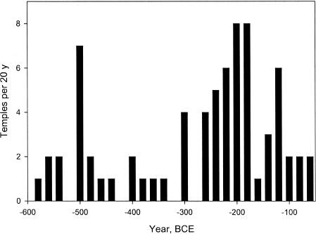

图 6.1 罗马寺庙建筑活动的时间分布 公元前 600–50 年。数据来自理查森 (1992)。

Figure 6.1 Temporal distribution of temple-building activity in Rome, ca. 600–50 BCE. Data from Richardson (1992).

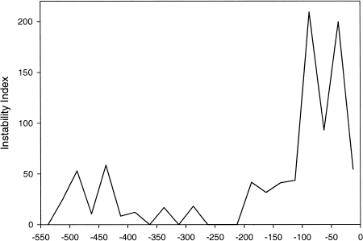

图 6.2 罗马共和国社会政治不稳定指数（Sorokin 1937）。

Figure 6.2 An index of sociopolitical instability in Republican Rome (Sorokin 1937).

## **共和周期的阶段**

## **Phases of the Republican Cycle**

367年里奇诺-塞克斯特妥协后精英阶层内部团结的实现，标志着从瓦解趋势向一体化趋势的转变，开启了罗马领土扩张的漫长而高度成功的时期。到公元前四世纪末，拉丁姆和坎帕尼亚合并成一个罗马-坎帕尼亚国家，罗马和卡普亚贵族之间达成协议，建立一支共同的军队。卡普安大家族受到罗马元老院的欢迎（Le Glay et al. 1997:51）。内部统一为领土扩张创造了条件，导致罗马首先建立了对意大利半岛的控制，然后获得了地中海帝国。在公元前三世纪，罗马不得不进行一系列旷日持久的激烈战争（第二次布匿战争最具破坏性），这给人口增长带来了数次冲击。与汉尼拔的战争（218-201）结束后经济恢复增长，罗马在公元前 180 年左右进入滞胀阶段。滞胀阶段和危机阶段之间没有明显的过渡。公元前133年至公元前91年间，罗马社会分阶段陷入危机。第一波严重不稳定是90至71年间的一系列内战，随后是60至50年代相对和平的插曲，然后是公元前50至31年间的第二次内战，这最终为瓦解趋势的逆转。我们以内战的结束和奥古斯都元首制的建立作为罗马共和周期的终点。因此，我们将瓦解趋势（危机和萧条阶段相结合）定为公元前130年至公元前30年之间的世纪。

The achievement of internal unity among the elites following the Licino-Sextian compromise of 367 marked the shift from the disintegrative to integrative trends and opened the long and highly successful period of Rome's territorial expansion. By the end of the fourth century BCE, Latium and Campania had merged together into a Roman-Campanian state, which involved agreement between the Roman and Capuan aristocracies to create a shared army. The great Capuan families were welcomed into the Roman senate (Le Glay et al. 1997:51). Internal unity created conditions for territorial expansion, which resulted in Rome first establishing control over peninsular Italy, and then acquiring a Mediterranean empire. During the third century BCE Rome had to fight a series of prolonged and bitter wars (the Second Punic War was particularly destructive) that delivered several shocks to population growth. Growth resumed after the end of the War with Hannibal (218–201), and Rome entered the stagflation phase around 180 BCE. There was no sharp transition between the stagflation and the crisis phase. Between 133 and 91 BCE Roman society slipped into crisis by stages. The first wave of severe instability was the series of civil wars between 90 and 71. It was followed by a relatively peaceful interlude in the 60s and 50s, and then the second series of civil wars from 50 to 31 BCE, which finally produced conditions for the reversal of the disintegrative trend. We use the end of the civil wars and the establishment of the Principate by Augustus as the end-point of the Roman Republican cycle. Therefore, the disintegrative trend (combining crisis and depression phases) is dated by us as the century between 130 and 30 BCE.

因此，在公元前一世纪，罗马的国家和社会发生了根本性的转变。导致共和国崩溃和元首国建立的直接因素是本世纪困扰意大利的一系列内战。然而，为什么罗马会经历这段社会和政治不稳定的时期，目前还没有一个被广泛接受的答案。解释这一时期最有影响力的模型可能是 Keith Hopkins (1978) 提出的模型。我们根据人口结构理论提供了一种解释，该解释在某些部分与霍普金斯的模型一致，而在其他部分则与之不同。尽管我们不一定同意霍普金斯模型的所有方面，但我们感谢他的开创性努力。

In the first century BCE, thus, the state and society of Rome were fundamentally transformed. The proximate factors leading to the collapse of the Republic and the establishment of the Principate were the series of civil wars that afflicted Italy during this century. Why Rome experienced this period of social and political instability, however, does not yet have a widely accepted answer. Probably the most influential model explaining this period is the one advanced by Keith Hopkins (1978). We offer an explanation, based on the demographic-structural theory, that in some parts coincides with Hopkins's model and in other parts diverges from it. Although we do not necessarily agree with all aspects of Hopkins's model, we are indebted to his pioneering effort.

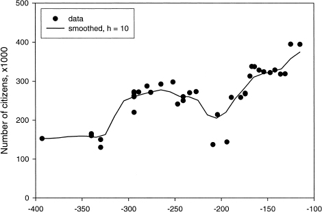

图 6.3 公元前 400-100 年罗马公民的数量（Toynbee 1965：438-39）。

Figure 6.3 Numbers of Roman citizens, 400–100 BCE (Toynbee 1965:438–39).

## **人口动态**

## **Population Dynamics**

我们很幸运能得到编年史学家转来的罗马共和时期的人口普查数据。罗马历史学家的共识似乎是，这些数字可以作为重建罗马人口动态的相当坚实的基础（Scheidel 2001，2004）。这些数字不是指总人口，而是指成年自由男性。

We are lucky to have the census numbers for the Roman Republican period, transmitted by the annalists. The consensus among the Roman historians appears to be that these numbers can serve as a reasonably solid basis for reconstructing the dynamics of the Roman population (Scheidel 2001, 2004). The numbers refer not to the total population but only to adult free males.

公元前 350 年至 100 年的总体趋势是增长，但被几次急剧下降所打断（图 6.3）。人口减少与战争非常激烈的时期有关，即第一次和第二次布匿战争（分别为 264-241 年和 218-201 年）。

The overall trend between 350 and 100 BCE was growth, which was interrupted by several sharp declines (figure 6.3). Population decreases correlate with periods of very intense warfare, the First and Second Punic Wars (264–241 and 218–201, respectively).

然而，我们真正想知道的不是罗马公民的数量如何变化，而是罗马的总人口发生了什么变化。意大利半岛。人口普查不能被视为总人口的指数，因为人口的增加不仅是人口增长的结果，也是某些吞并领土上的自由居民被接纳为罗马公民身份的结果。社会战争后，意大利盟友获得了特别大规模的选举权。此外，意大利人口因半岛以外的奴隶大量涌入而膨胀，随着罗马征服地中海的进行，这成为一个日益重要的因素。

What we really wish to know, however, is not how the numbers of Roman citizens changed but what happened to the total population of peninsular Italy. The censuses cannot be taken as an index of total population, because they increased not only as a result of demographic growth but also when free inhabitants of certain annexed territories were admitted to Roman citizenship. There was a particularly massive enfranchisement of Italian allies following the Social War. Additionally, the Italian population was swelled by huge influxes of slaves from outside the peninsula, which became an increasingly significant factor as Rome's conquest of Mediterranean proceeded.

人口学家和经济历史学家对共和国末期至元首执政初期的人口趋势进行了长时间的争论。主要争议与奥古斯都人口普查的解释有关。“高”计数的支持者（Frank 1933，Lo Cascio 1994，Morley 2001）认为人口普查数字代表成年自由男性，而“低”计数的支持者（Beloch 1886，Brunt 1971）则认为这些数字代表了成年自由男性。所有男女自由居民，一岁以下的婴儿可能除外。这里我们跟随接受 Beloch-Brunt 重建的 Walter Scheidel (2001 [ed.], 2004, 2007)，并请读者参考他 2004 年的著作以了解论证的细节。

Population trends during the late Republic–early Principate period have been debated at length by demographers and economic historians. The main controversy has to do with the interpretation of the Augustan censuses. The proponents of the “high” count (Frank 1933, Lo Cascio 1994, Morley 2001) assume that the census numbers represent adult free males, while the proponents of the “low” count (Beloch 1886, Brunt 1971) believe that the numbers represent all free inhabitants of both sexes, with the possible exception of infants less than one year old. Here we follow Walter Scheidel (2001 [ed.], 2004, 2007), who accepts the Beloch-Brunt reconstruction, and refer the reader to his 2004 work for details of the argument.

Brunt (1971) 得出的结论是，公元前 225 年和公元前 28 年，意大利半岛的自由人口数量约为 300 万。Scheidel 接受了这些数字，仅有微小的变化。霍普金斯（1978：68-69）也利用布伦特的数据，认为整个意大利（包括西萨普林高卢）的人口在公元前 225 年至 28 年间从 450 万下降到 400 万。然而，霍普金斯假设225年意大利北部（西萨普林高卢）有140万居民，并且有理由相信这个数字被高估了（de Ligt 2004：733）。由于人们对意大利北部知之甚少，因此仅使用意大利半岛的数字似乎更安全。

Brunt (1971) concluded that the free population of peninsular Italy numbered around 3 million in both 225 and 28 BCE. These numbers are accepted by Scheidel with only minor variations. Hopkins (1978:68–69), also working with Brunt's numbers, argued that the population of the whole of Italy (including Cisapline Gaul) declined between 225 and 28 BCE from 4.5 million to 4 million. However, Hopkins assumed that in 225 there were 1.4 million inhabitants in northern Italy (Cisapline Gaul), and there are reasons to believe this figure is an overestimate (de Ligt 2004:733). Because very little is known about northern Italy, it seems safer to stick with the numbers for peninsular Italy alone.

然而，公元前 225 年和公元前 28 年人口规模大致相同所表明的表面稳定性是具有欺骗性的——事实上，这些估计有助于确定意大利在公元前最后两个世纪所经历的长期人口周期。该循环分三个阶段进行。为了对变化进行定量估计，我们遵循布伦特的修正人口普查报告（他的表七），然后使用这些罗马人口普查作为意大利半岛其他人口发生情况的指标。当我们引用下面的人口普查统计数据时，我们将其四舍五入到最接近的千位。

The apparent stability suggested by roughly the same population size in 225 and 28 BCE, however, is deceptive—in fact, these estimates serve to anchor a secular population cycle that Italy experienced in the last two centuries BCE. The cycle occurred in three phases. To come up with quantitative estimates of change we follow Brunt's corrected census returns (his Table VII), and then use these Roman censuses as indicators of what was happening to the rest of the population in Italian peninsula. When we cite census statistics below, we round them to the nearest thousand.

在第一阶段，即公元前 225 年至 200 年之间，由于长期和破坏性的汉尼拔战争，人口下降（Toynbee 1965）。这一时期的人口普查数字表明了这一下降的幅度：从 225 年的 273,000 人下降到 203 年的 214,000 人。（208 年和 194 年，这一数字分别为 137,000 人和 144,000 人，但布伦特令人信服地认为，这些非常低的数字要么代表了在国外驻扎大量军队或人口普查程序不完善，或两者兼而有之。）就计算而言，下降了 22%，所以我们假设自由人口总数从 3 万人下降到 235 万人。

In the first phase, between 225 and 200 BCE, the population declined as a result of prolonged and destructive Hannibalic war (Toynbee 1965). The magnitude of this decline is suggested by the census numbers during this period: from 273,000 in 225 to 214,000 in 203. (In 208 and 194 the numbers were 137,000 and 144,000, respectively, but Brunt convincingly argues that these very low counts represent either the stationing of large numbers of troops abroad or deficient census procedures, or both.) In proportionate terms, the decline is 22 percent, so let us say that the total free population declined from 3 to 2.35 million.

在下一阶段，即公元前二世纪，人口增加。布伦特认为 168（313,000）和 124（395,000）的人口普查是可靠的。估计 203 年至 168 年之间的人口增长有点复杂，因为根据布伦特的说法，26,000 名坎帕尼亚人（他们在汉尼拔战争中倒戈）没有计入 203 年，而是计入了 168 年。考虑到这一因素，他估计了起始-点人口为 214,000 + 26,000 = 240,000。期末人口估计为313,000+33,000（驻外士兵估计数）=346,000，即增加44%。因此，203年至168年间，自由半岛人口从2.35万人增加到339万人。

In the next phase, the second century BCE, the population increased. Brunt accepts the censuses of 168 (313,000) and 124 (395,000) as reliable. Estimating population growth between 203 and 168 is a bit involved because, according to Brunt, 26,000 Campanians (who switched sides in the Hannibalic war) were not counted in 203 but were included in 168. Taking this factor into account, he estimated the starting-point population as 214,000 + 26,000 = 240,000. The ending population is estimated as 313,000 + 33,000 (the estimated number of soldiers stationed abroad) = 346,000, or an increase of 44 percent. Thus, between 203 and 168 the free peninsular population increased from 2.35 to 3.39 million.

124 年人口普查为 395,000 人，布伦特在其中加上 38,500 名士兵，总数为 433,500 人。因此，168 和 124 之间的比例变化为 25%。也就是说，124的自由人口为425万。

In 124 the census was 395,000, to which Brunt adds 38,500 soldiers, for a total of 433,500. The change between 168 and 124 in proportionate terms thus is 25 percent. In other words, the free population in 124 was 4.25 million.

在最后一个阶段，即公元前一世纪，由于持续的内战、高城市化指数以及后期国家资助的大规模人口转移，人口下降。Brunt 根据 69 个国家的人口普查计算得出人口为 370 万（Brunt 1971:97, Scheidel 2004:9）。最后，到公元前 28 年，人口进一步下降，降至 300 万，回到 225 人的水平。重建的人口动态如图 6.4所示。

In the last phase, the first century BCE, the population declined as a result of constant civil wars, a high urbanization index, and, during later stages, massive state-sponsored population transfers. Brunt's calculations based on the census of 69 suggest a population of 3.7 million (Brunt 1971:97, Scheidel 2004:9). Finally, by 28 BCE the population had declined further, to 3 million, returning to the level of 225. The reconstructed population dynamics are depicted in figure 6.4.

The graph in figure 6.4 is somewhat deceptive. For one thing, it is overly smooth. In reality, each estimate comes with at least a 10 percent error. Second, the start of population decline probably occurred in the early first century, rather than right after 124. The census of 114 reported essentially the same numbers as in 124, and the population probably stagnated until the beginning of the Social War in 91. In 85, reported census numbers rose to 463,000, but this increase probably reflects a partial enumeration of newly enfranchised Italian allies (Brunt 1971:93). Finally, all these numbers refer to the free population. The dynamics of the slave population are essentially inestimable (Scheidel 2005), but by the end of the cycle slave numbers probably reached 1–1.5 million. Thus, the total population (including both free and slave) decreased less during the first century than is shown by the graph (or even, conceivably, stayed flat).

## **社会结构和精英动态**

## **Social Structure and Elite Dynamics**

共和时期罗马社会的最高阶层（权贵）是元老院（*ordo senatorius*）。参议员是统治阶级：他们担任政府官员，垄断首席神职人员，并为军队提供军官（Cornell 1995，Ward、Heichelheim 和 Yeo 2003）。参议员来自贵族和平民氏族（*氏族*），并且都是富有的地主。

The top stratum (the magnates) of the Roman society during the Republican period was the senatorial order (*ordo senatorius*). Senators were the governing class: they served as government officials, monopolized the chief priesthoods, and provided officers for the army (Cornell 1995, Ward, Heichelheim, and Yeo 2003). Senators came from both patrician and plebeian clans (*gentes*) and were wealthy landowners.

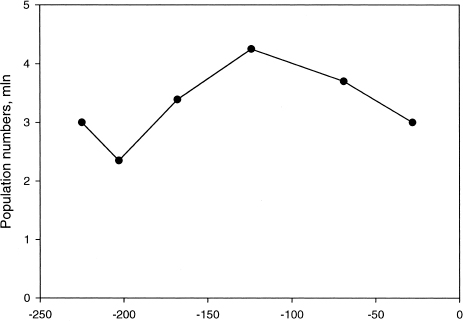

图6.4 公元前225年至公元前28年意大利半岛自由人口的估计数量（基于Brunt 1971年的数据和文中的计算）。

Figure 6.4 Estimated numbers of the free population in peninsular Italy from 225 to 28 BCE (based on data of Brunt 1971 and calculations in the text).

马术士（*Equites*）是低等贵族，之所以称为马术士，是因为他们最初在军队中担任骑兵。这个阶层提供了许多商人——进行海外贸易的商人和垄断国家合同的*税吏*。在共和国晚期，陪审员服务是为马术运动员保留的。

The equestrians (*equites*) were lesser aristocrats, called equestrians because originally they served as cavalry in the army. This stratum provided many businessmen—merchants who conducted overseas commerce and *publicani* who monopolized state contracts. In the late Republic, jury service was reserved for the equestrians.

在这个周期开始时（约公元前 300 年），大多数平民人口由小土地所有者——公民及其家庭组成。公民在军队中担任步兵（重装步兵），并在武装男性议会（*comitia centuriata*）和其他选举公职人员的民众议会中投票。他们根据财产价值分为五类（表6.1）。较富裕的公民，即财产价值超过10万头驴的人和马术爱好者，拥有超过一半的选票，因此在选举中占据主导地位。另一方面，他们还缴纳了大部分财产税，即贡品*（* Cornell 1995：187）。

At the beginning of the cycle (ca. 300 BCE), the majority of the commoner population consisted of small landowners—citizens and their families. Citizens served as infantry (hoplites) in the army and voted in the assembly of the arms-bearing males (*comitia centuriata*) and other popular assemblies that elected public officials. They were divided into five classes according to the value of their property (table 6.1). The wealthier citizens, those with property valued above 100,000 asses and the equestrians, had more than half the votes, and therefore dominated elections. On the other hand, they also paid the bulk of the property tax, the *tributum* (Cornell 1995:187).

有产公民（*assidui*）并不贫穷。拥有价值 50,000 头驴或更多财产的第三个人口普查阶层只能是“中型”土地所有者（Rosenstein 2004：163）。（公元前 200 年*左右，*青铜的重量为 2 罗马盎司；其价值约为 0.4 克白银。）在与汉尼拔的战争期间，元老院曾两次呼吁该人口普查类别的公民贡献一名奴隶以及六个月的粮食，作为船队中的一名赛艇运动员（富裕的公民预计会贡献更多）。这表明财富水平远高于生存水平。

The propertied citizens (*assidui*) were not poor. The third census class with property valued at 50,000 asses or more could not have been anything but “medium-sized” landholders (Rosenstein 2004:163). (An *as* around 200 BCE weighed two Roman ounces of bronze; its value was around 0.4 g silver.) On two occasions during the War with Hannibal the senate called for citizens in this census class to contribute one slave along with six months of provisions as a rower in the fleet (wealthier citizens were expected to contribute more). This suggests a degree of wealth well above the subsistence level.

**表 6.1**

**TABLE 6.1**

三世纪末罗马共和国各阶层的财富（或年收入）。

Wealth (or annual income) of various strata in the Roman Republic in the late third century.

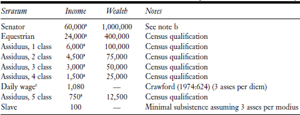

*资料来源：*康奈尔大学（1995：179-81）。

*Source:* Cornell (1995:179–81).

*注：*估值以资产为*单位*。公元前200 年*左右*，青铜重 2 罗马盎司，价值 0.1 第纳尔或 0.4 克白银。

*Note:* Valuations are given in *asses*. The *as* around 200 BCE weighed 2 Roman ounces of bronze and was valued at 0.1 denarius or 0.4 g silver.

<sup>a</sup>根据财富估算的收入，假设年收入 = 财富的 6%。

<sup>a</sup> Incomes estimated from wealth, assuming that annual income = 6% of wealth.

<sup>b</sup>最低财富资格可能与马术运动员相同，但参议员平均更富有。公元前 214 年，财产价值超过 100 万驴的人被要求为舰队提供 7 名水手；参议员提供了 8 头（Mitchell 1990：247-78），因此参议员的平均财产肯定超过 100 万头驴。马术参议员的比例也与奥古斯都人口普查相同。

<sup>b</sup> The minimum wealth qualification was probably the same as for the equestrians, but senators were on average wealthier. In 214 BCE those with property worth more than 1 million asses were required to supply seven sailors for the fleet; senators supplied eight (Mitchell 1990:247–78), so average senatorial property must have been more than 1 million asses. The equestrian-senator proportion is also the same as in the Augustan census.

<sup>c</sup>退伍军人工资，也可能是国家支付的最低日工资。

<sup>c</sup> Legionnaire pay, also probably the lowest daily salary paid by the state.

罗马社会的下层包括无地公民（*无产阶级*）、外国人、自由民和奴隶。

The lower strata of the Roman society included landless citizens (*proletarii*), foreigners, freedmen, and slaves.

民国时期的社会结构非常活跃。公元前 300 年左右，大部分人口很可能是小农 ( *assidui* )，而无土地的*无产阶级*只是少数。布伦特（Brunt，1971：77）认为，218年，*无产阶级*占公民总数的一半。但正如罗森斯坦（Rosenstein，2004：185）指出的那样，这不可能是正确的。虽然*无产阶级*没有在军队服役，但他们在舰队中担任桨手。214年，当时*无产阶级还不到2万*在担任这一职务期间，元老院被迫招募奴隶作为桨帆船划手。布伦特计算出，214 年约有 100,000 名公民被武装或被杀害。假设军事参与比例相似，这些数字表明，在三世纪末，*阿西杜伊*（在军队服役）与*无产阶级*（担任赛艇运动员）的比例大约为 10:2。Rosenstein（2002）估计，事实上，大约 90% 的公民是*阿西杜伊人*，因为其中一半（年长的已婚男子）没有被征召入伍经营农场。

The social structure during the Republic was very dynamic. Around 300 BCE the bulk of the population was most likely the smallholders (*assidui*), while landless *proletarii* were a minority. Brunt (1971:77) thought that in 218, *proletarii* amounted to half the citizen body. But as Rosenstein (2004:185) pointed out, this cannot be right. While *proletarii* did not serve in the army, they served as rowers in the fleet. In 214, at a time when there were no more than 20,000 *proletarii* serving in that capacity, the senate was forced to recruit slaves as galley rowers. Brunt calculates that in 214 about 100,000 citizens were under arms or had been killed. Assuming similar military participation ratios, these numbers suggest that in the late third century the ratio of *assidui* (who served in the army) to *proletarii* (who served as rowers) was roughly 10:2. Rosenstein (2002) estimates that, in fact, about 90 percent of the citizenry were *assidui*, because half of them (the older married men) were not drafted so that they could operate the farms.

根据 225 年罗马骑兵和步兵的数量表明，在第三世纪，富裕的地主（骑士和元老）与非精英地主（*阿西杜伊*）的比例略低于 1:10。波利比乌斯——分别为23,000和250,000（与帝王时期的比例相同）。使用此模板并结合上一段中的计算，我们得出共和国中期罗马社会结构的以下细分：*骑士*（包括元老）：*阿西杜伊*：*无产阶级*1:10:2（或 1:10:1，如果前一段中罗森斯坦的估计是正确的）。在这些类别中，我们需要添加数量未知的奴隶和外国人。

In the third century the ratio of wealthy landowners (equestrians and senators) to nonelite landholders (*assidui*) was just under 1:10, as suggested by the numbers of Roman cavalry and infantry in 225 reported by Polybius—23,000 and 250,000, respectively (the same proportion as in the regal period). Using this template together with the calculation in the previous paragraph, we arrive at the following breakdown of Roman social structure in mid-Republic: *equites* (including senators): *assidui* : *proletarii* 1:10:2 (or 1:10:1, if the Rosenstein estimate in the preceding paragraph is correct). To these categories we need to add unknown numbers of slaves and foreigners.

## **国家财政**

## **State Finances**

The basic demographic-structural model was developed for states with approximately stationary territory. By contrast, the territory of Rome expanded from around 5,000 km<sup>2</sup> in the fourth century BCE to more than 3 Mm<sup>2</sup> (millions of square kilometers) by the end of the first century BCE (Taagepera 1979). Such a spectacular 600-fold territorial expansion is a factor of enormous significance and must be added to the basic model described in chapter 1. Territorial expansion helped solve the problem of landless citizens. It also affected how the Roman elites and the state secured their means of livelihood. Whereas in “typical” agrarian societies the elites and the state extract surplus from the commoner population in the form of rents and taxes, in Republican Rome the ruling class largely lived off the spoils of conquest. When the Third Macedonian War ended in 167 with a particularly large haul of booty, taxes levied on Italian land owned by Roman citizens were abolished (Hopkins 1978:38). The land tax was not reimposed until the end of the third century CE. The state took a cut of the booty resulting from the conquest and taxed conquered territories at the probable rate of 10 percent of the crop on average (Hopkins 1978:16). As a result of Rome's success at war, the state revenues more than quadrupled during the third century (table 6.2). However, during the succeeding century, while the population and the numbers of elites expanded, the state revenues stagnated at the level of 55–80 million sesterces (table 6.2). The main reason seems to be that after the Third Punic War (149–146 BCE), Rome had simply run out of wealthy states to conquer. The endemic war against the Spanish guerillas consumed men and treasure without yielding any significant booty. The next great leap of revenue expansion came only after the first round of civil wars.

## **社会政治不稳定**

## **Sociopolitical Instability**

从 342 年平民最后一次撤离到第一次奴役战争（公元前 135-132 年）之间的两个世纪里，几乎没有发生内战（表 6.3）。相比之下，提比略·格拉古被谋杀后的一个世纪是几乎持续不断的内战之一。

The two centuries between the last exit of the Plebeians in 342 and the First Servile War (135–132 BCE) were remarkably free of civil warfare (table 6.3). By contrast, the century following the murder of Tiberius Gracchus was one of almost continuous internecine war.

|  | **表 6.2** **TABLE 6.2** |  |  |  |
| --- | --- | --- | --- | --- |
|  | 国家收入 State income |  |  |  |
|  | *日期* | *每年数百万塞斯特斯 (HS)* | *参考* |  |
|  | 公元前 264–241 年 | 15 | 弗兰克 (1933:66–67) |  |
|  | 公元前 218–201 年 | 65 | 弗兰克 (1933:95) |  |
|  | 公元前 200–157 年 | 55 | 弗兰克 (1933:145) |  |
|  | 公元前 150–90 年 | 80 | 弗兰克 (1933:228) |  |
|  | 约公元前65年 | 200 | 霍普金斯 (1978:37) |  |
|  | 约公元前60年 | 340 | 霍普金斯 (1978:37) |  |
|  | 公元前 55–51 年 | 320 | 弗兰克 (1933:332) |  |
|  | 约公元前50年 | 380<sup>一个</sup> | 哈尔 (1996:54) |  |
|  | <sup>a</sup>这一总额可能包括西西里岛、撒丁岛和非洲的粮食税价值。 <sup>a</sup> This total probably includes the value of grain taxes of Sicily, Sardinia, and Africa. |  |  |  |

迈克尔·克劳福德（Michael Crawford，1974）认为，钱币囤积的沉积率可以忠实地反映共和国中后期影响意大利的内部不稳定状况。将克劳福德关于硬币囤积的数据与内部战争指数一起绘制，我们观察到显着的并行性（图 6.5）。两条曲线在所有细节上并不重合，这在我们处理真实数据时是很自然的。例如，硬币囤积轨迹在 150 年代有一个小峰值，并且在这十年间没有出现重大的内部扰动。克劳福德认为，这些宝藏可能是军团士兵在前往外部战争并阵亡之前埋葬的。另一种可能性是，150年代的峰值只是数据的统计波动（该时期只有8个囤积）。

Michael Crawford (1974) has argued that the deposition rate of coin hoards can serve as a faithful reflection of the conditions of internal instability affecting Italy during the middle and late Republic periods. Plotting Crawford data on coin hoards together with an index of internal warfare we observe a remarkable degree of parallelism (figure 6.5). The two curves do not coincide in all the details, as is only natural when we deal with real data. For example, the coin hoards trajectory has a minor peak in the 150s, and there were no significant internal disturbances during this decade. Crawford thought that these hoards could have been buried by legionnaires prior to leaving for, and dying in, external wars. Another possibility is that the peak in the 150s is simply a statistical fluctuation in the data (the period has only eight hoards).

另一方面，两条曲线都反映了三个主要的内战时期：三世纪末的汉尼拔战争和一世纪的两次内战。第二世纪相对和平。上半年，囤积行为很少，也没有明显的内讧，而下半年囤积存款的增加表明社会政治紧张局势日益加剧。

The three major periods of internal war, on the other hand, are reflected in both curves: the Hannibalic wars of the late third century and the two civil wars of the first century. The second century was relatively peaceful. There were few hoards and no significant internecine infighting during the first half, while rising hoard deposits during the second half suggest growing sociopolitical tensions.

## 6.2 异常漫长的扩张（公元前 350 年至公元前 180 年）

## 6.2 An Unusually Long Expansion (350–180 BCE)

在与萨姆尼特人和意大利希腊人的战争之后，罗马国家最终间接控制了意大利半岛，其中约 20% 的领土位于阿杰罗马努斯 (Ager Romanus)。领土扩张伴随着公民群体的壮大（表6.4）。

After the wars with the Samnites and Italian Greeks, the Roman state ended up with indirect control of peninsular Italy, with about 20 percent of territory in the Ager Romanus. The territorial expansion was accompanied by growth of the citizen body (table 6.4).

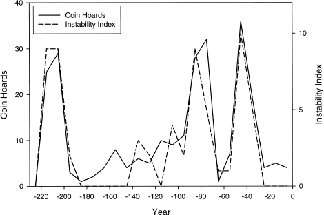

If we can trust the census data (and the consensus among historians seems to be that we can, at least from the late fourth century onward), then the Roman population almost doubled between the mid-fourth and midthird centuries, while territory almost quintupled. As a result, the population density actually declined (table 6.4). This development explains to a large degree the alleviation of the land problem, which had plagued the Roman poor since the fifth century. The census numbers reflect not only (and perhaps even not primarily) demographic growth. Numbers of citizens were increased by the enfranchisement of the Latins and Campanians, while at the same time an estimated 70,000 Romans were lost to the citizen rolls as a result of colonization during the period 334–263 (Cornell 1995:381). Population growth was also undoubtedly slowed by the series of intense wars that the Romans fought during the late fourth century and all of the third century against first the Samnites, then the Italian Greeks and Pyrrhus, and last the Carthaginians. These wars were fought within central and southern Italy and resulted in much devastation. A particularly destructive war was the Second Punic War, 218–201 BCE (Toynbee 1965). Census numbers dropped from a high near 300,000 in 265 BCE to close to 200,000 or even less around 200 BCE (for the censuses of 209 and 194 Livy transmits the figure of around 140,000, and for 204, 214,000). Part of this drop was artifactual and reflected the absence of large numbers of Roman soldiers stationed away from Rome, and who were therefore not counted in the census (Brunt 1971), but there is also no question that the Roman citizenry suffered huge casualties (Ward, Heichelheim, and Yeo 2003:131). However, it is logical to assume that the numbers of females and children did not decline to the same extent as those of males of military age. As a result, the census numbers rapidly bounced back to the level of 250,000 in the early second century.

**表 6.3**

**TABLE 6.3**

罗马社会政治不稳定，公元前 350-0 年

Sociopolitical instability in Rome, 350–0 BCE

[output not shown]

*资料来源：* Sorokin (1937)，并辅以其他资料来源。

*Source:* Sorokin (1937), supplemented by other sources.

**表 6.4**

**TABLE 6.4**

罗马特定年份的人口普查和领土，约 330-225 年，以及估计的人口密度

Roman census and territory for selected years, ca.330–225, and estimated population density

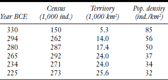

*资料来源：* Brunt 的人口普查数据和领土（1971 年：表 I 和 V）。

*Source:* Census figures and territory from Brunt (1971: tables I and V).

*注：*假设成年男性占自由人口总数的三分之一。

*Note:* Assumes that adult males constituted one-third of the total free population.

Falling population density due to war losses and territorial expansion meant that internal competition for resources ceased to be a factor in Roman politics (until the next stagflation phase, that is). Instead, all efforts of both aristocracy and commoners were directed at the struggle with external enemies. Aristocracy was also severely affected by war losses. For example, at the battle of Cannae (216 BCE) alone there were eighty senatorial casualties. Natural attrition and earlier battles also had taken a severe toll, resulting in ninety-seven additional vacancies between 219 and 217 (Raaflaub 1986:167). In other words, instead of the normal turnover of 10 percent over these three years, almost 60 percent of the senate was obliterated. The intense wars of the third century, in which the aristocracy was fighting on the front lines, thus helped to prevent elite overproduction.

公元前 201 年，第二次布匿战争结束后，所有随后的罗马战争都在国外（即意大利半岛以外）进行。罗马在这些冲突中通常占据上风，伤亡也较轻。结果，第二世纪出现了人口持续增长的时期。人口普查人数从公元前 189 年的 258,000 人增加到公元前 125 年和公元前 114 年的 394,000 至 395,000 人。意大利半岛的自由人口估计从 235 万增加到 425 万（第 6.1 节）。200 至 91 年间，罗马领土保持不变（Crawford 1993：46），这意味着人口密度增加了 50% 以上。这种增长仅指自由公民，但奴隶人口增长得更快。

Once the Second Punic War ended, in 201 BCE, all subsequent Roman wars were fought abroad (that is, outside peninsular Italy). Rome typically had the upper hand in those conflicts, and the casualties were lighter. As a result, the second century saw a period of sustained population growth. The census numbers increased from 258,000 in 189 to 394,000–395,000 in 125 and 114 BCE. The estimated free population of peninsular Italy increased from 2.35 million to 4.25 million (section 6.1). Between 200 and 91 the Roman territory stayed unchanged (Crawford 1993:46), which implies that the population density increased by more than 50 percent. This increase refers only to free citizens, but the population of slaves grew even faster.

伊特鲁里亚南部的考古数据也表明，这一时期人口密度有所增加。从公元前四世纪到公元前一世纪，Ager Veientanus 的定居点数量增加了一倍（Bintliff 和 Sbonias 1999）。公元前 300 年之后的时期也见证了伊特鲁里亚城镇的衰落和定居点向乡村的分散（Greene 1986：103）。这是一种典型的模式，经常在长期周期的扩张阶段观察到。它是伴随解体/一体化转变而增加的安全性的结果，并且是人口增长的标志（因为人口负增长的城市环境中的人口比例减少）。

Archaeological data from southern Etruria also suggest that the population density increased during this period. The number of settlements in Ager Veientanus doubled between the fourth and first centuries BCE (Bintliff and Sbonias 1999). The period after 300 BCE also saw the decline of Etruscan towns and the dispersal of settlements into the countryside (Greene 1986:103). This is a typical pattern, often observed during the expansion phase of the secular cycle. It results from the increased security accompanying the disintegrative/integrative shift and is a sign of population growth (as the proportion of the population in urban environments with its negative population growth is reduced).

总之，共和周期的扩张阶段以两个人口增长时期为特征。在四世纪中叶到三世纪中叶之间，罗马公民的总数首次增加了一倍。然而，国家控制的领土增长得更快，结果人口密度实际上下降了。在三世纪下半叶，由于一系列战争，人口数量下降，最终在第二次布匿战争中达到顶峰。201年，第二次布匿战争结束后，人口恢复增长。第二个世纪期间，公民人数增加了 50% 以上。由于这一时期罗马直接控制的领土大致保持不变，所以二世纪的人口增长导致人口密度增加。

In summary, the expansion phase of the Republican cycle was characterized by two periods of population growth. The total number of Roman citizens first doubled between the mid-fourth and mid-third centuries. However, the territory controlled by the state increased even faster, with the result that the population density actually declined. During the second half of the third century population numbers declined as a result of a series of wars, culminating in the Second Punic war. Once the Second Punic War was over, in 201, population growth resumed. During the second century the number of citizens increased by more than 50 percent. Because the territory directly controlled by Rome was approximately constant during this period, population growth in the second century resulted in an increased population density.

## 6.3 滞胀（公元前180-130年）

## 6.3 Stagflation (180–130 BCE)

## **公元前二世纪的人口趋势**

## **Demographic Trends in the Second Century BCE**

从提比略·格拉古（Tiberius Gracchus）保民官（公元前 133 年）到公元前 29 年奥古斯都建立元首国之间的一个世纪，持续的国内冲突占据主导地位，并两次爆发为旷日持久、激烈的内战。这段国家崩溃和长期内战（第 6.4 节中回顾）的时期具有典型的人口结构危机的所有特征，因为其爆发之前是民众的贫困、激烈的精英内部竞争和国家收入的停滞。在这里，我们依次回顾这些趋势。

The century between the tribuneship of Tiberius Gracchus (133 BCE) and the establishment of the Principate by Augustus in 29 BCE was dominated by persistent domestic strife that twice flared up into protracted and intense civil wars. This period of state collapse and chronic civil warfare (reviewed in section 6.4) has all the earmarks of a classic demographic-structural crisis, because its onset was preceded by popular immiseration, intense intraelite competition, and the stagnation of state revenues. Here we review each of these trends in turn.

关于转变发生的确切时间存在一些问题。直到最近，共识观点（如教科书中提出的；参见 Ward、Heichelheim 和 Yeo 2003）认为它始于三世纪末。阿诺德·汤因比、基思·霍普金斯和彼得·布伦特等历史学家认为，第三世纪和第二世纪的战争，特别是第二次布匿战争，破坏了 367 年里西诺-塞克斯特妥协所建立的相对农业稳定。汉尼拔对罗马人的胜利非常多——根据波利比乌斯的说法，有 110,000 人（尽管 Brunt [1971] 认为这个数字被夸大了）。此外，战争是在半岛上进行的意大利，并对生产基础设施造成了广泛的破坏（Toynbee 1965，尽管 Toynbee 可能夸大了这种影响的持续性）。罗马人口普查反映了战争对人口的影响：264 年（第一次布匿战争开始前）人口为 292,000 人，203 年（第二次布匿战争即将结束）人口为 214,000 人。那些在战争中幸存下来的士兵“回来后发现他们的农场已经破败不堪，而且还背负着养家糊口的债务。不少人因债务而被扣押，或者干脆被某个较大的邻居接管”（Ward、Heichelheim 和 Yeo 2003：131）。与此同时，从海外征服中获得最大利润的精英阶层，将大部分资本投资于土地。大规模资本密集型经营——*大庄园*—专门为市场生产高价值产品：

There is some question about precisely when the transformation took place. Until recently the consensus view (as put forth in the textbooks; see Ward, Heichelheim, and Yeo 2003) held that it began in the late third century. Historians such as Arnold Toynbee, Keith Hopkins, and Peter Brunt have argued that the wars of the third and second centuries, and especially the Second Punic War, undermined the relative agricultural stability established by the Licino-Sextian compromise of 367. Battle casualties inflicted by Hannibal's victories on the Romans were extraordinarily high—according to Polybius, 110,000 (although Brunt [1971] thinks such numbers are exaggerated). Moreover, the wars were fought in peninsular Italy and caused widespread destruction of the productive infrastructure (Toynbee 1965, although Toynbee probably exaggerates the persistence of the effect). The Roman censuses reflect the demographic impact of the wars: 292,000 in 264 (just before the start of the First Punic War) and 214,000 in 203, near the end of the Second Punic War. Those soldiers who survived the wars “returned to find their farms run down and burdened by debts incurred to support their families. Not a few had been seized for debt or simply taken over by some larger neighbor” (Ward, Heichelheim, and Yeo 2003:131). Meanwhile, the elites, who got the biggest share of the profits from the overseas conquests, invested the bulk of their capital in land. Large-scale capital-intensive operations—*latifundia*—specialized in producing high-value products for the market:

以前只产生少量剩余的自给经济转变为生产和消费大量剩余的市场经济，是通过提高大农场的农业劳动生产率来实现的。更少的人生产更多的食物。就业不足的小农被驱逐出他们的土地，取而代之的是数量较少的奴隶。富人买下了他们的土地，或者通过暴力占有了它。他们将小块土地重组为规模更大、利润更高的农场，以便与其他贵族竞争，增加土地和奴隶投资的回报，并更有效地剥削奴隶……。富人大规模驱逐穷人是罗马共和国上个世纪政治冲突和内战的根源。（霍普金斯 1978：2-5）

Jongman（2003：105）对这种对共和晚期转型的传统解释进行了简洁但不带同情心的总结，如下：

This conventional explanation for the late Republican transformation was summarized pithily if unsympathetically by Jongman (2003:105), as follows:

当规模越来越大的罗马军队开始在越来越远的土地上打越来越久的战争时，服兵役对作为军团传统骨干的普通农民来说变得越来越沉重。结果，许多人失去了土地，让给了更强大的富人，并离开了城市，增加了城市贫民的数量。富人从征服世界的战利品中变得更加富有，通过合法或其他方式购买和占用公共和私人土地，获得了大片地产。为了耕种土地，他们使用了罗马扩张战争中俘获的越来越多的奴隶。

最近，这种共识观点受到了Jongman（2003）、Rosenstein（2004）和de Ligt（2004，2007）的严厉批评。在一本内容广泛、逻辑严密的书中，罗森斯坦认为，罗马的公民士兵并不是罗马帝国冒险的受害者，而是“自愿且常常热情的参与者”（Rosenstein 2004：60）。他们的热情直到公元二世纪中叶：“自 153 年以来，西班牙的战斗一直是艰苦且无利可图的。失败屡屡发生，人员伤亡也十分惨重。正如普鲁塔克所报道的那样，应征入伍者是出了名的不愿意去，军队的士气跌入谷底”（Rosenstein 2004：53）。

Recently the consensus view was severely criticized by Jongman (2003), Rosenstein (2004), and de Ligt (2004, 2007). In a wide-ranging and closely reasoned book, Rosenstein argues that Rome's citizen soldiers were not victims of their city's imperial adventures but “willing and often enthusiastic participants” (Rosenstein 2004:60). Their enthusiasm waned only after the mid-second century: “Combat in Spain since 153 had been hard and unprofitable. Defeats were frequent, and the loss of life there often heavy. Conscripts were notoriously reluctant to go, just as Plutarch reports, and morale in the army was at rock bottom” (Rosenstein 2004:53).

此外，新的种植园农业最早在二世纪中叶就出现在文学和考古记录中，直到苏拉时代才变得普遍（Rosenstein 2004：6）。*因此，从战争伤亡最严重的时期到大庄园*的兴起，已经过去了几代人的时间，这使人们对这两个过程之间的直接因果关系产生了怀疑。

Furthermore, new plantation agriculture appears in the literary and archaeological record in the mid-second century at the earliest, and it became widespread only during the age of Sulla (Rosenstein 2004:6). Thus, several generations elapsed between the period of heaviest war casualties and the rise of *latifundia*, throwing doubt on a direct causal link between the two processes.

罗森斯坦利用人口模型和农业经济演算表明，大多数罗马小农家庭可以轻松地摆脱年轻男性的劳动力而不会破产。事实上，二世纪罗马农村（以及世俗周期适当阶段的许多其他农业社会）面临的主要问题一定是农村就业不足，而不是缺乏在田间劳作的劳动力。

Using demographic models and the calculus of agrarian economy, Rosenstein showed that most families of Roman smallholders could readily spare the labor of young males without going under. In fact, the main problem facing the Roman countryside during the second century (and many other agrarian societies during the appropriate phase of the secular cycle) must have been rural underemployment, rather than lack of labor to work the fields.

罗森斯坦完全站在了共识的观点上，并认为“越来越多的小农以及他们中分割继承的盛行，为格拉古试图解决的土地危机起源的传统解释提供了一个有吸引力的替代方案”（Rosenstein 2004： 155）：

Rosenstein stands the consensus view on its head and argues that “an increasing number of smallholders and the prevalence of partible inheritance among them offer an attractive alternative to the conventional accounts of the origins of the agrarian crisis that Gracchus sought to solve” (Rosenstein 2004:155):

从 218 年到二世纪最后三分之一左右，罗马年轻男性的大量死亡很可能对汉尼拔战败后人口急剧增长做出了重大贡献……。随着人口倍增，父母给子女分配的遗产越来越少，拥有财富的公民数量也越来越多，成为无产阶级*。*很可能一直在增加…… 因此，到了133年，汉尼拔入侵后的几年里，罗马战争不仅导致人口迅速增长，而且还产生了一批处于人口普查最低阶层的小农，总体而言，他们比三世纪的同辈人要贫穷得多，而且没有太多希望。通过自己的努力改善自己的命运。181年后，随着意大利殖民统治的结束，参议院关闭了无法让所有孩子在新农场定居的家庭的安全阀。（罗森斯坦 154–64 帕西姆）

正如我们所看到的，罗森斯坦提出了一个本质上是人口结构的论点。毫无疑问，旷日持久的战争对罗马人口动态产生了巨大影响，必须予以考虑。然而，其效果却与共识观点所假设的相反。它并没有引发一世纪的内战，而是将清算日推迟到那时（因此共和党周期的扩张阶段异常漫长）。

As we see it, Rosenstein advances an essentially demographic-structural argument. There is no question that the protracted series of wars had a great effect on Roman population dynamics, and must be taken into account. However, its effect is the opposite of the one postulated by the consensus view. It did not cause the civil wars of the first century but rather postponed the day of reckoning until then (thus the unusually long expansion phase of the Republican cycle).

第二次布匿战争的结束为意大利半岛带来了长达一个世纪的内部和平时期，因为所有随后的冲突都被转移到了罗马帝国不断扩大的边境地区。因冲突受损的生产基础设施迅速恢复，为人口快速增长创造了条件。起初，经济增长因对外战争的大量人员伤亡而受到一定程度的抑制，直到181年才受到波河流域殖民化的抑制。

The end of the Second Punic War introduced a century-long period of internal peace to peninsular Italy, since all succeeding conflicts were removed to the expanding frontier of the Roman Empire. Productive infrastructure damaged by the conflict was rapidly restored, creating conditions for rapid population growth. Growth was somewhat inhibited at first by high casualties in the external wars, and until 181 by colonization of the Po Valley.

203 年至 124 年间，人口数量几乎翻了一番，而阿杰罗曼努斯的领土在公元前 188 年至 85 年期间保持不变，为 55,000 平方公里<sup>（</sup> Beloch 1964：101-2）。如此大规模的人口增长必定会对农民的经济状况产生通常的人口结构后果。在罗马的例子中，继承人之间平等分配财产的普遍模式加剧了人口增长的影响。经过两三代人的人口快速增长，财产的分割肯定已经达到了每个继承人的份额严重不足以养活家庭的程度。一些（前）*阿西迪*毫无疑问，他们将土地卖给了那些拥有罗马征服战利品并渴望将自己的财富投资于土地的精英。其他人试图继续下去，但债务水平达到了不可持续的水平，也失去了土地。这一过程的最终结果是小地主阶级的减少，同时伴随着无地*无产阶级*和奴隶的增长（尽管奴隶数量的增长并非由意大利内部的人口变化主导，而是外部征服的结果）。许多没有土地的公民搬到了罗马，而其他人可能从精英地主那里租用了土地。例如，Jongman（2003）认为，共和国晚期的“大庄园化”程度被高估了。

Between 203 and 124 population numbers almost doubled, while the territory of Ager Romanus stayed constant between 188 and 85 BCE at 55,000 km<sup>2</sup> (Beloch 1964:101–2). Such a massive increase in population must have had the usual demographic-structural consequences for peasant economic conditions. In the Roman case, the effects of population growth were exacerbated by the universal pattern of equal division of property among the heirs. After two or three generations of rapid population growth, property fragmentation must have reached the point where each heir's share was grossly insufficient for feeding the family. Some (former) *assidui* undoubtedly sold their land to elites flush with the spoils of the Rome's conquests and eager to invest their fortune in land. Others tried to go on, ran up unsustainable debt levels, and also lost their land. The end result of this process was diminution of the class of small landowners, accompanied by the growth of landless *proletarii* and slaves (although the growth of slave numbers was not dominated by demographic processes internal to Italy but was a result of external conquests). Many of the landless citizens moved to Rome, while others probably rented land from the elite landowners. Jongman (2003), for example, argues that the degree of “latifundization” during the late Republic is overestimated.

人口增长带来了通常的马尔萨斯发展。在第四世纪后期和第三世纪相对没有流行病的时期之后，疾病频率在第二世纪再次增加（Duncan-Jones 1996）。疫情也变得更加严重。例如，奥罗修斯声称，142年的瘟疫导致许多殡葬者死亡，以至于尸体被留在床上腐烂，最终使罗马无法居住（Duncan-Jones 1996：113）。

Population growth brought about the usual Malthusian developments. After a period relatively free of epidemics during the later fourth and third centuries, the disease frequency increased again during the second century (Duncan-Jones 1996). Epidemics also became more severe. For example, Orosius claimed that the plague of 142 killed so many undertakers that the corpses were left to rot in their beds, eventually making Rome uninhabitable (Duncan-Jones 1996:113).

## **经济趋势**

## **Economic Trends**

We have extremely scanty information about the price and wage dynamics under the Republic, but what there is suggests that the century between 150 and 50 BCE saw a substantial inflation. Probably the best indicator is the military wages. In the late third century BCE a legionnaire received a daily pay of 3 asses per diem, or the cost of a modius of wheat (Harl 1996:212). This daily amount translates into an annual pay of 108 denarii (using a year of 360 days and 10 asses per denarius). The amount of 360 modii equals 2.34 tons of wheat, or about ten annual rations—quite a generous salary for a preindustrial society. In 141 the denarius was reevaluated at 16 asses, and the legionnaire's pay was set at 5 asses per diem, probably again reflecting the price of a modius of wheat (a quarter bushel) at that time. Thus, the annual pay increased to only 112.5 denarii (in nominal terms, staying constant in real terms), which suggest very mild inflation up to this point. The next time military pay was increased was a century later by Caesar in 46, to 225 denarii per annum (or 2.5 HS—sesterces—per diem). This doubling also probably reflects the price of wheat, since the “fair” price of wheat according to Cicero is 2.5 HS per modius (see the discussion in Duncan-Jones 1990:147–49). The Republic did not increase military wages between 141 and 46, instead compensating men with triumphal donatives and promises of land (Harl 1996:213). What probably happened, therefore, was that the price of wheat at least doubled between 141 and the onset of the civil wars in 91. We know that grain prices had already increased by the Gracchan times. The *lex frumentaria* of Gaius Gracchus, for example, provided for the state-supported sale of wheat to citizens at the price of 6.33 asses per modius (or 1.6 HS per modius), which was below the average market price (Ward, Heichelheim, and Yeo 2003:160). In fact, it is likely that the price of wheat increased even more than by a factor of two during the chaotic years of the civil wars, before it came down to the level of 2.5 HS per modius after political stability was established. Thus, the real pay of a legionnaire must have gone through the following dynamics: starting high at 2.34 tons of grain per annum in 141, collapsing by a factor of two (or more) in 90–71, and then regaining the 141 level by 10–9 BCE, profiting from the decline of wheat prices under the Principate.

从公元前二世纪到公元前一世纪，非熟练工人的日工资明显增加。根据 Cato 的说法，每天 2 HS，而在一个世纪后的西塞罗时代，每天 3 HS（Wells 1992：186）。

The daily wage of an unskilled laborer apparently increased between the second and first century BC. According to Cato, it was 2 HS per day, while in Cicero's day a century later it was 3 HS per day (Wells 1992:186).

意大利共和末期的另一个显着转变是工业、贸易和城市化的增长。因此，罗马人口在第二世纪增加了两倍，从大约 150,000 人增加到 450,000 人（Chandler 1987）。另一种估计是罗马人口从公元前 200 年的 150,000 人增加到公元前 100 年的 375,000 人，然后到公元前 50 年增加到 600,000 人（Scheidel 2004：14）。有两个主要因素推动了这一过程。首先，罗马的成功征服使其成为地中海帝国的首都。出售战利品、战争赔款、贡品和国有矿山带来的财富涌入罗马，首先使精英阶层富裕起来，然后“流向”满足精英阶层需求的商人和工匠。城镇就业的扩大吸引了农村人口的流入。第二，他们的家人移居城市寻找经济机会。因此，城市化是由拉力和推力共同驱动的（这与前几章讨论的英国和法国案例类似）。然而，到了第二世纪末，推力显然压倒了拉力。罗马的移民没有足够的工作机会，住房需求量很大，导致租金上涨。犯罪增加。城市贫民变得越来越不满（Ward、Heichelheim 和 Yeo 2003：135）。

Another striking transformation of late-Republican Italy was the growth of industry, trade, and urbanization. Thus, the population of Rome tripled during the second century from roughly 150,000 to 450,000 (Chandler 1987). An alternative estimate has the population of Rome increasing from 150,000 in 200 BCE to 375,000 in 100 BCE and then to 600,000 in 50 BCE (Scheidel 2004:14). Two main factors drove this process. First, Rome's successful conquest transformed it into the capital of a Mediterranean empire. Wealth from the sale of booty, war indemnity, tribute, and state-owned mines poured into Rome, first enriching the elites and then “trickling down” to benefit the tradesmen and artisans who catered to the elites’ needs. Expanded urban employment attracted rural immigrants. Second, increased numbers of peasants lacking land to feed themselves and their families migrated to the cities in search of economic opportunities. Thus, urbanization was driven by both pull and push forces (which parallels the English and French cases discussed in previous chapters). Toward the end of the second century, however, push apparently overwhelmed pull. There were not enough jobs for the immigrants to Rome, and housing was in high demand, driving rents up. Crime increased. The urban poor became increasingly discontented (Ward, Heichelheim, and Yeo 2003:135).

## **精英动力**

## **Elite Dynamics**

公元前二世纪最引人注目的发展是罗马精英的数量和财富的增加。正如我们在上一节中看到的，考古数据证实了民国早期精英简单生活方式的传统观点。然而，在公元前 300 年左右之后，我们开始看到精英消费水平开始增加的迹象。这一点在新寺庙建筑的曲线上表现得最为明显（图6.2）。在经历了 5 世纪后期和 4 世纪后期寺庙数量极少的长期时期后，寺庙建筑活动开始在 300 座左右增加，并在整个公元前 3 世纪继续增加，在 2 世纪达到顶峰。

The most striking development of the second century BCE was the increase in both the numbers and wealth of the Roman elites. As we saw in the previous section, archaeological data confirm the traditional view of simple lifestyles of early Republican elites. However, after around 300 BCE, we start seeing signs that elite consumption levels were beginning to increase. It is most clear in the curve of new temple building (figure 6.2). After a long spell with very few temples built in the later fifth and fourth centuries, temple-building activity began increasing around 300 and continued to increase throughout the third century BCE, reaching a peak in the second.

也许有人会说，在共和国时期，寺庙建筑活动反映了战争的成功，而不是精英消费（新寺庙往往是军队指挥官在关键战役前宣誓的，建筑费用的很大一部分来自战利品）。然而，贵族炫耀性消费的其他指标也指向同一方向。因此，从四世纪末开始，伊特鲁里亚的纪念墓数量突然开始增加（Barker and Rasmussen 1998：286）。沙兹曼（Shatzman，1975）根据对 200 多名罗马元老院经济数据的分析得出结论，第二次布匿战争（公元前 201 年）结束后，他们的开支稳步上升，并在 79 年苏拉退休后达到顶峰。公元前：

It may be argued that during the Republic, temple-building activity reflected success at war rather than elite consumption (new temples were often vowed by army commanders before a critical battle, and a significant portion of building expenses came from the booty). However, other indicators of aristocratic conspicuous consumption point in the same direction. Thus, beginning in the late fourth century, the number of monumental tombs in Etruria suddenly began increasing (Barker and Rasmussen 1998:286). On the basis of his analysis of economic data for more than 200 Roman senators, Shatzman (1975) concluded that their expenses rose steadily after the end of the Second Punic War (201 BCE) and reached a peak during the period after Sulla retired in 79 BCE:

显然，罗马在东方的战争导致了生活水平的提高。一旦元老们发现了希腊世界的精致和复杂的品味，他们就会毫不犹豫地模仿他们所发现的东西，并增加他们的私人支出。这个过程始于二世纪上半叶，在第一世纪达到了极端的高度。我们的信息表明，领事和*贵族*对这种奢侈行为负有主要责任，但整个元老阶层都增加了生活成本。（沙茨曼 1975：98）

第一世纪的私人财富规模达到了天文数字。在财产价值众所周知的参议员中，有五人拥有超过 1 亿HS的财富：L. Balbius、M. Crassus、L. Lucullus、Pompey 和 L. Tarius Rufus (Shatzman 1975:35)。将这些数字换算成白银当量，1 HS 约等于 1 g S。换句话说，1 亿 HS 约等于 100 吨白银。

The scale of private fortunes during the first century reached astronomical proportions. Of the senators for whom property values are known, five individuals possessed fortunes that were greater than 100 million HS: L. Balbius, M. Crassus, L. Lucullus, Pompey, and L. Tarius Rufus (Shatzman 1975:35). To convert these numbers into silver equivalents, 1 HS is approximately equal to 1 g S. In other words, 100 million HS is roughly equivalent to 100 tons of silver.

“普通”参议员拥有数百万塞斯特斯的财富。例如，M.西塞罗有1300万。西塞罗还写道，一个富有的罗马人每年需要 100,000-600,000 HS 的收入。由于前工业社会的总财富和年收入的比例通常为 20-12 比 1，因此这些收入数字意味着 1.2-1200 万 HS 的财富。有趣的是，从第二世纪到第一世纪，元老的财富规模显然有所增加。因此，167 年终结马其顿王国的 L. Aemilius Paullus 在去世时只留下了 144 万HS 的财产（Crawford 1993：75）。这比一个世纪后的平均财富要低一个数量级。

“Ordinary” senators had fortunes of several million sesterces. For example, M. Cicero had 13 million. Cicero also wrote that a rich Roman needed an income of 100,000–600,000 HS per year. Since total fortunes and annual incomes in preindustrial societies usually relate in a ratio of 20–12 to 1, these income figures imply fortunes of 1.2–12 million HS. What is interesting is that there apparently was an increase in the scale of senatorial fortunes between the second and first centuries. Thus, L. Aemilius Paullus, who put an end to the kingdom of Macedon in 167, left a fortune of only 1.44 million HS at his death (Crawford 1993:75). This is an order of magnitude less than average fortunes a century later.

在富人越来越富的同时，穷人也越来越穷。一个人获得第一*等级*资格所需的资本财富可能从 120,000 头驴减少到 100,000 头驴（Crawford 1993:79），以抵消阿西杜伊日益贫困的*影响*。*符合assidui*（第五级）资格的男子的下限曾经是 11,000 头驴（Crawford 1993：97）。它被降低到 4,000 个（在二世纪上半叶），然后降低到 1,500 个（到 141 年），最后被完全废除。107年，马略登记了*capate censi*，即那些没有财产、只是简单地列在人口普查中的人，*无产阶级*（克劳福德 1993：125）。自给自足的自由持有者（*assiduus*）阶层数量的下降还体现在罗马公民与罗马军队中盟友的比例下降。到二世纪末，盟友与罗马人的比例为 2:1 (Crawford 1993:128)。

At the same time that the rich were getting richer, the poor were becoming progressively poorer. The capital wealth needed to qualify a man for the first *classis* was probably lowered from 120,000 to 100,000 asses (Crawford 1993:79) in order to counteract the effect of increasing impoverishment of the *assidui*. The lower boundary qualifying men as *assidui* (fifth class) was once 11,000 asses (Crawford 1993:97). It was lowered to 4,000 (during the first half of the second century), then to 1,500 (by 141), and eventually abolished altogether. In 107 Marius enrolled *capitate censi*, those without property who were simply listed in the census, *proletarii* (Crawford 1993:125). The numerical decline in the stratum of self-supporting freeholder (*assiduus*) is also manifested in the declining proportion of Roman citizens versus allies in Roman armies. By the end of the second century the ratio of allies to Romans was 2:1 (Crawford 1993:128).

## **精英内部竞争**

## **Intraelite Competition**

为了深入了解这一时期的精英数值动力学，我们转向霍普金斯和伯顿的研究（Hopkins 1983：第 2 章）。这项研究的重点是罗马等级制度的顶层、执政官、罗马共和国的首席民选官员。每年选举两名执政官，因此，在典型的三十年一代中，最多可以有六十名执政官（因为同一个人有时会当选多次，实际人数通常在五十到六十之间波动） 。在任何特定时间，这五十到六十名罗马等级制度顶层的人都有相对详细的记录，为我们提供了研究罗马精英动态的极好样本。

To gain an insight into the elite numerical dynamics during this period we turn to the study by Hopkins and Burton (Hopkins 1983: Chapter 2). This study focused on the top stratum of the Roman hierarchy, the consuls, the chief elected officials of the Roman Republic. Every year two consuls were elected, so that over the period of a typical generation of thirty years, there could be a maximum of sixty consuls (because the same individual was sometimes elected more than once, the actual number usually fluctuated between fifty and sixty). These fifty to sixty men at the top of the Roman hierarchy at any given time were relatively well documented and provide us with an excellent sample with which to investigate Roman elite dynamics.

历史学家的传统观点认为，罗马精英阶层由一小部分贵族家族所主导。在提比略·格拉古 (Tiberius Gracchus) 保民官年（公元前 133 年）之前的一个世纪里，有十个氏族（*氏族*）占所有执政官的 50%，另外 11 个氏族提供了额外的 30%（De Sanctis，Toynbee 1965 引用）。在贵族家族中，科内利提供了二十三名执政官，埃米利提供了十一名执政官，法比和波斯图米各提供了七名执政官。在平民中，富尔维产生了十名执政官，马塞利产生了九名执政官，森普罗尼产生了八名执政官。因此，在 400 多个产生各种行政官（执政官、执政官、高级官员等）的*氏族*中，一小部分人（5% ）控制着罗马国家的顶层。

The traditional view among historians holds that the Roman elites were dominated by a small circle of noble families. During the century preceding the year of Tiberius Gracchus's tribunate (133 BCE), ten clans (*gentes*) supplied 50 percent of all consuls, and another eleven clans supplied an additional 30 percent (De Sanctis, cited in Toynbee 1965). Among the patrician clans, Cornelii supplied twenty-three consuls, Aemilii eleven, and Fabii and Postumii seven each. Among the plebeians, Fulvii produced ten consuls, Marcelii nine, and Sempronii eight. Thus, a small proportion—5 percent—of more than 400 *gentes* that produced magistrates of any kind (consuls, praetors, curule aediles, etc.) dominated the top stratum of the Roman state.

霍普金斯和伯顿根据他们的分析认为，权力集中在少数家族手中的程度被夸大了。他们指出，公元前250-50年期间当选的所有执政官中有三分之一在前三代中没有直接的领事祖先。只有三分之一的领事有一个领事儿子，不到四分之一的人设法将领事身份传给了孙子。根据他们的研究结果，霍普金斯和伯顿认为，与传统观点相反，“在共和国的最后两个世纪里，罗马政治精英不断进出”（Hopkins 1983：32）。

Hopkins and Burton argued, on the basis of their analysis, that the degree of power concentration in the hands of a few families was exaggerated. They pointed out that one-third of all consuls elected in the period 250–50 BCE had no direct consular ancestor in the previous three generations. Only a third of all consuls had a consular son, and less than a quarter managed to transmit their consular status to a grandson. On the basis of their results, Hopkins and Burton argued that, contrary to the traditional view, “there was a continuous movement into and out of the Roman political elite during the last two centuries of the Republic” (Hopkins 1983:32).

There is no particular contradiction between the observation by Hopkins and Burton that 65 percent of consuls had a direct consular ancestor and that by De Sanctis that twenty-one clans produced 80 percent of the consuls. First, the two numbers are based on different time periods (250–50 vs. 233–133). Second, a clan usually consisted of several, sometimes many, families. Both sets of numbers thus indicate a strong but not absolute control of the political power by the established families. What is more puzzling is the low probability of transmitting consular status to descendants: 32 percent to a son, and 24 percent to a grandson. Such a strong anisotropy in consular ascendants versus descendants actually suggests that the consular stratum was undergoing some interesting dynamics during this period. Fortunately, Hopkins and Burton presented their data broken down by thirty-year periods (roughly, generations), which allows us to examine the temporal changes in the probability of status transmittal during 250–50.

在图 6.6a中，我们绘制了公元前 250 至 50 年间领事地位的继承（数据来自 Hopkins 1983：表 2.2和2.4）。实线表示拥有领事父亲或领事祖父的领事比例（将这两类加在一起很重要，因为精英家庭常常不得不跨代，因为他们的资源被激烈而昂贵的政治活动所耗尽，而这些活动是实现实现目标所必需的）领事职位）。我们看到，领事上辈的比例从 249-220 年间的 45% 上升到 139-110 年间的 64%。换句话说，到了格拉古时期，贵族们实际上加强了对领事权力的控制。当观察有领事父亲的领事时，也观察到了同样的动态：从 170 年前的 30-38% 到 139-110 中的 58%（图 6.6b，实线）。

In figure 6.6a we plot the inheritance of consular status between 250 and 50 BCE (data from Hopkins 1983: Tables 2.2 and 2.4). The solid line indicates the proportion of consuls that had either a consular father or a consular grandfather (it is important to add these two categories together because elite families often had to skip generations because their resources were depleted by vigorous and costly political activity necessary for achieving consulship). What we see is that the proportion of consuls with consular ascendants increased from 45 percent in 249–220 to 64 percent in 139–110. In other words, the nobles actually tightened their grip on consular power toward the Gracchan period. The same dynamic is observed when looking at consuls with consular fathers: from 30–38 percent before 170 to 58 percent in 139–110 (figure 6.6b, solid line).

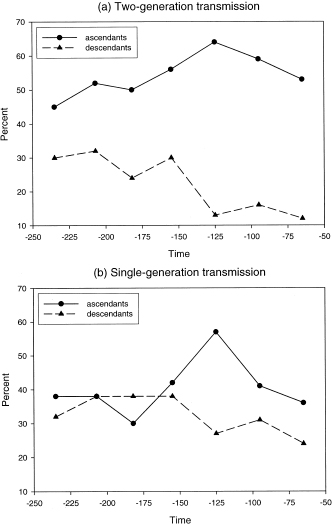

图 6.6 领事地位的继承，公元前 250-50 年。(a) 领事身份的两代传承：父亲和/或祖父为领事的领事（实线）和领事孙子的领事（虚线）。(b) 单代传承：领事父亲为领事（实线），领事儿子为领事（虚线）。Hopkins 和 Burton 数据来自 Hopkins 1983：表 2.2、表 2.4）。

Figure 6.6 Inheritance of consular status, 250–50 BCE. (a) Two-generation transmission of consular status: consuls with a consular father and/or grandfather (solid line) and consular grandsons of consuls (dashed line). (b) Single-generation transmission: consuls with consular fathers (solid line) and consuls with consular sons (dashed line). Hopkins and Burton data from Hopkins 1983: Table 2.2, Table 2.4).

图 6.6a中的第二条（虚线）表示拥有领事孙子的领事比例。与实线相反，这条曲线不会随着时间的推移而增加：直到公元前 169-140 年，它一直在 30% 左右波动，然后在公元前 139-110 年期间突然下降到 13%（图 6.6a ）。其他状态传递指标也同时经历了类似的下降。领事儿子比例从38%下降到27%（图6.6b，虚线），而领事曾孙的比例则从27%下降到10%。因此，矛盾的是，贵族们加强对领事馆的控制的同时，他们将自己的地位传递给后代的能力却下降了。

The second (dashed) line in figure 6.6a indicates the proportion of consuls that had a consular grandson. This curve, in contrast to the solid one, does not increase with time: it fluctuates around 30 percent until 169–140 BCE, then suddenly drops to 13 percent during 139–110 (figure 6.6a). Other measures of status transmittal experienced similar drops at the same time. The proportion of consuls with consular sons dropped from 38 percent to 27 percent (figure 6.6b, dashed line), while the proportion of consular great-grandsons dropped from 27 percent to 10 percent. Thus, paradoxically, at the same time that the nobles were tightening their grip on the consulate, their ability to transmit their status to their descendants decreased.

对这种动态的唯一可能的解释是，有志于担任领事职务的人的人数在第二世纪稳步扩大。随着越来越多的贵族争夺每代最多六十个领事职位，精英内部的竞争加剧，失败的可能性也随之增加。这种趋势首先导致贵族的向上流动受到阻碍，领事馆的统治地位日益增强，其次是贵族后代之间的竞争加剧。

The only possible explanation of this dynamic is that the pool of aspirants for consular positions was steadily expanding during the second century. As increased numbers of nobles contended for the same maximum of sixty consular positions per generation, intraelite competition increased and the probability of losing grew. This trend led first to the choking off of upward mobility and the growing domination of the consulate by the nobles, followed by intensifying competition among their descendants.

Hopkins 和 Burton 计算的另一组数字（Hopkins 1983：表 2.7）支持了这种解释。他们研究了“内部精英”（即具有执政官父亲和祖父的执政官）培养出成为执政官或执政官的继承人的能力。3世纪下半叶，每个内部精英成员平均生育1.25个执政官或禁卫军儿子。由于这个数字大于一，所以内部精英实际上在数量上正在扩大。半个世纪后，平均值降至 1 以下，降至 0.83，并在 139-80 年间降至其初始值 0.63 的一半。

Another set of numbers calculated by Hopkins and Burton (Hopkins 1983: table 2.7) supports this interpretation. They looked into the ability by the “inner elite” (that is, consuls with both consul fathers and grandfathers) to produce heirs that would become either consuls or praetors. During the second half of the third century, each member of the inner elite produced on average 1.25 consular or praetorian sons. Since this number is greater than one, the inner elite was actually expanding in numerical terms. Half a century later the average dropped below one to 0.83, and for the period of 139–80 is declined to half of its initial value, 0.63.

通过比较时间上各代人之间领事地位相关性之间的不对称性，可以对同一模式进行另一种观察。霍普金斯和伯顿指出，在研究期间，平均 40% 的领事的父亲也是领事，而只有 32% 的领事的儿子也是领事。在精英阶层更替、既没有赤字也没有盈余的稳定情况下，这两个统计数据应该是相同的。然而，数据显示，在此期间，罗马每代人的精英产量大约有 25% 的剩余。这一结论是根据以下观察得出的：32%的领事是“领事父亲”（即有领事儿子的领事），40%是“领事儿子”（即有领事父亲的领事）。因此，每一位领事父亲都提出，平均有1.25名领事儿子。由于领事职位总数有限，与稳定条件下的情况相比，有额外 20%（0.25/1.25）的领事抱负者在获得领事职位的野心上受到挫败，他们及其后代将不得不向下流动成为“纯粹的”参议员。

Yet another look at the same pattern is provided by comparing the asymmetry between the correlation of consular status among generations forward and backward in time. Hopkins and Burton noted that on average during the studied period, 40 percent of consuls had fathers that were also consuls, while only 32 percent had sons who were also consuls. In a stable situation in which elites replace themselves without either deficit or surplus, these two statistics should be the same. The data, however, suggest there was about a 25 percent surplus elite production in Rome per generation during this period. This conclusion follows from the observation that 32% of consuls were “consular fathers” (that is, consuls who had consular sons) and 40% were “consular sons” (that is, consuls who had consular fathers). Therefore, each consular father produced, on average, 1.25 consular sons. Since the total number of consular positions was limited, an extra 20 percent (0.25/1.25) of consular aspirants had to be frustrated in their ambitions to obtain a consulship than would be the case under stable conditions, and they and their descendants would have to suffer downward mobility into “mere” senators.

事实上，整个时期的平均数字掩盖了领事父子比例相当剧烈的波动。按时间段绘制领事父亲和领事儿子的比例，我们观察到直到二世纪中叶，两条曲线的波动水平大致相同（图6.6b ）。事实上，在 194-170 一代（即汉尼拔战争期间对精英阶层的严厉削减之后，父亲为领事的执政官比例下降至仅30%，而儿子为领事的执政官比例则维持在38%，这表明精英内部争夺领事地位的竞争大大减少在这段时期。相比之下，在格拉恰时期（139-110），父亲为领事的领事比例飙升至 57%，而儿子为领事的领事比例则下降到不到一半，即 27%（图 6.6b ））。结果，精英生产过剩率在共和国晚期长达一个世纪的社会政治不稳定时期之前达到顶峰。精英内部竞争的顶峰出现在下一代，大致是从格拉古时代到社会战争时期。

In actuality, the numbers averaged over the whole period hide fairly dramatic fluctuations in the consular father-son ratio. Plotting the proportions of consular fathers and consular sons by time period, we observe that until the middle of the second century, the two curves fluctuate at a roughly the same level (figure 6.6b). In fact, during the generation of 194–170 (the one following the severe pruning of the elites during the Hannibalic war), the proportion of consuls with consular fathers dipped to a mere 30 percent, while the proportion of consuls with consular sons stayed at 38 percent, suggesting that intraelite competition for consular status was greatly reduced during this period. By contrast, during the Gracchan period (139–110) the proportion of consuls with consular fathers shot up to 57 percent, while the proportion of consuls with consular sons dropped to less than half of it, 27 percent (figure 6.6b). As a result, the rate of elite overproduction peaked right before the century-long period of sociopolitical instability of the late Republic. The peak of intraelite competition fell within the next generation, roughly the period from the time of the Gracchi to the Social War.

## **国家财政**

## **State Finances**

从公元前 146 年到公元前 91 年，罗马的财政状况相对健康。公元前157年，国库储备达到7200万HS（Harl 1996：44），而在社会战争前夕，这一数字为8000万HS（Harl 1996：50）。然而，这种平衡被证明是脆弱的，国库储备很快就被社会战争消耗殆尽。事实上，社会战争的一个长期后果似乎是它破坏了共和国晚期的财政平衡。第纳尔贬值至 95% 的银含量表明 91 岁以后财务困难增加（Harl 1996：50）。此外，国家停止支付士兵的工资。公元 89 年，国库空空如也，这是自 213-12 年第二次布匿战争最黑暗的日子以来的第一次（Crawford 1974：640）。战争结束后，财政状况十分严峻，以至于元老院在88年熔化了神圣的宝藏，以资助苏拉在东方的战争。这种权宜之计产生了大约 9,000 磅黄金（Harl 1996:50），相当于 4320 万 HS（Crawford 1974:637）。在 83-82 年内战期间，苏拉及其盟友也曾抢劫寺庙的宝库。然而，一旦苏拉掌权并重新建立内部稳定，苏拉就设法使国家财政井然有序。因此，81 年苏拉恢复了第纳尔的纯度（98% 银）。苏拉在财政上取得成功的一个重要因素是他在东方的胜利——他从米特里达梯那里获得了 2,000 或 3,000 塔兰特的赔偿，并对亚洲各城市罚款了五年的欠税，总计 20,000 塔兰特（Harl 1996:51），或者4.8亿HS。然而令人惊奇的是，这些巨额财富很快就被花掉了，资金短缺的情况持续了整个70年代。苏拉征收新税并通过立法授权出售*公众*（Crawford 1974：638）。在 20 世纪 70 年代（西班牙与塞多留的战斗最激烈的时期），第纳尔再次贬值至 96-97% 的白银（Harl 1996:54）。

From 146 to 91 BCE Roman finances were relatively healthy. In 157 BCE the treasury reserve was built up to 72 million HS (Harl 1996:44), and on the eve of the Social War it was 80 million HS (Harl 1996:50). This equilibrium, however, turned out to be fragile, and the treasury reserve was rapidly consumed by the Social War. In fact, it looks like one long-term consequence of the Social War was that it destroyed the fiscal equilibrium of the late Republic. Increased financial difficulties after 91 are indicated by the debasement of the denarius to 95 percent silver content (Harl 1996:50). Furthermore, the state ceased to pay the soldiers. The treasury was empty in 89, for the first time since 213–12, during the darkest days of the Second Punic War (Crawford 1974:640). After the end of the war the financial situation was so desperate that the senate in 88 melted sacred treasures in order to finance Sulla's war in the East. This expedient yielded some 9,000 pounds of gold (Harl 1996:50), equivalent to 43.2 million HS (Crawford 1974:637). The looting of temple treasuries was also employed by Sulla and his allies during the civil war of 83–82. Once Sulla was in power and internal stability was reestablished, however, Sulla managed to get state finances in order. Thus, in 81 Sulla restored the denarius to purity (98 percent silver). A big factor in Sulla's fiscal success was his victories in the East—he gained from Mithridates an indemnity of 2,000 or 3,000 talents and fined the cities of Asia for five years of back taxes, amounting to 20,000 talents (Harl 1996:51), or 480 million HS. Amazingly, however, these huge treasures were immediately spent, and money shortages continued throughout the 70s. Sulla instituted new taxes and passed legislation authorizing the sale of *ager publicus* (Crawford 1974:638). During the 70s (at the peak of fighting in Spain against Sertorius), the denarius suffered another debasement to 96–97 percent silver (Harl 1996:54).

庞培为解决罗马财政困难奠定了基础，他重组了西班牙和东部省份，使税收取代了掠夺性掠夺（Harl 1996：54）。由于庞培的重组，罗马的收入翻了两番（见表6.2）。凯撒征服的高卢的贡品使总数达到了 3.8 亿HS。这些收入使共和国积累了巨大的储备，其中包括 15,000 根金条，尽管我们不知道一根金条的重量（Crawford 1974：639）。然而，储备金在 49 年被凯撒没收并立即花掉。一年后，凯撒缺乏金条，被迫将其第纳尔的标准降低到 95-96％的罚款（Harl 1996：55）。我们看到的是盛宴紧接着饥荒的循环往复。凯撒被刺杀后，这个循环又重复了一遍。44年，国库储备为7亿HS，很快就被凯撒的继任者在自相残杀的战争中挥霍殆尽（Harl 1996：56）。在 44-42 年间，三驾马车再次不得不将第纳尔贬值至 95-96% 的白银，到了 31 岁，马克·安东尼铸造的第纳尔的成色已降至 92%（Harl 1996：59）。与此同时，屋大维能够提高他所铸造的第纳尔的纯度。在奥古斯都时期（公元前 27 年之后），第纳尔的纯度得到恢复（达到 98%），此后的一个世纪里一直保持这种状态。

The basis for the solution of Rome's fiscal difficulties was laid by Pompey, who reorganized Spain and the eastern provinces so that taxation replaced predatory plundering (Harl 1996:54). As a result of Pompey's reorganization, Rome's revenues quadrupled (see table 6.2). The tribute from Gaul, conquered by Caesar, increased the total to 380 million HS. These revenues allowed the Republic to amass a great reserve that included 15,000 bars of gold, although we do not know how much a bar weighed (Crawford 1974:639). The reserve, however, was seized and immediately spent by Caesar in 49. A year later Caesar was short of bullion and was forced to lower the standard of his denarius to 95–96 percent fine (Harl 1996:55). What we see is recurring cycles of feast followed by famine. The cycle was repeated after the assassination of Caesar. In 44 there was a treasury reserve of 700 million HS, which was immediately squandered by Caesar's successors in their internecine wars (Harl 1996:56). During 44–42 the triumvirs again had to debase the denarius to 95–96 percent silver, and by 31 the denarius minted by Mark Antony had declined to 92 percent fineness (Harl 1996:59). Meanwhile, Octavian was able to increase the pureness of the denarius that he struck. In the Augustan period (after 27 BCE) the purity of the denarius was restored (to 98 percent), and it stayed that way for a century thereafter.

## **社会压力增加**

## **Increasing Social Pressures**

顺着社会等级制度往下看，我们发现非参议院精英，即马术阶层（*ordo equestris*），发现获得参议员地位越来越困难，而且几乎不可能跻身领事贵族行列（沃德、海歇尔海姆和杨） 2003：137）。罗马共和国的社会安排确保“骑士”（*骑士*）能够分享地中海征服所带来的利润。参议员被排除在建设公共工程、经营国有矿山、征税和供应军队的国家合同之外。这些合同由主要来自马术阶层的*publicani*公司承担（Ward、Heichelheim 和 Yeo 2003：134）。在第二世纪上半叶，大量因*公共*事务而变得极其富有的骑士将他们的新财富投资于更有社会声望的形式（主要是土地），并渴望进入元老阶层。因此，由于来自名门望族的候选人数量不断增加（由于人口增长），以及来自新富骑士的压力，对有限数量的元老职位的竞争变得更加激烈。

Working our way down the social hierarchy, we find that the nonsenatorial elites, the equestrian class (*ordo equestris*), found it increasingly difficult to achieve senatorial status and almost impossible to break into the ranks of the consular nobility (Ward, Heichelheim, and Yeo 2003:137). Social arrangements under the Roman Republic ensured that the “knights” (*equites*) would get their share of the profits resulting from Mediterranean conquests. Senators were excluded from state contracts to construct public works, operate state mines, collect taxes, and supply the military. These contracts were undertaken by companies of *publicani*, who came primarily from the equestrian class (Ward, Heichelheim, and Yeo 2003:134). During the first half of the second century, a large number of knights who had grown extremely wealthy from their activities as *publicani* invested their new wealth in more socially prestigious forms (mainly land) and developed aspirations to enter the senatorial class. Thus, the competition for the limited number of senatorial positions was aggravated both by the increasing numbers of aspirants from the established families (resulting from population growth) and by the pressure from the newly rich knights.

意大利同盟政体的精英发现自己的处境比马术派更糟糕，因为他们基本上被排除在海外征服的利润之外。汉尼拔战败后，随着罗马在意大利的安全，罗马人越来越多地将他们的意大利盟友视为臣民。同盟国反过来开始要求公民身份，但罗马精英顽固地拒绝纠正这种明显的不公正现象（Ward，Heichelheim和Yeo 2003：138）。事实上，罗马统治阶级面临着来自本土精英阶层的日益激烈的竞争，因此并不急于接纳意大利精英公民身份来增加竞争，这是可以理解的。

The elites of the allied Italian polities found themselves in a worse situation than the equestrians, because they were largely excluded from the profits of overseas conquests. As Rome became secure in Italy after the defeat of Hannibal, the Romans increasingly treated their Italian allies as subjects. The allies in turn began demanding citizenship, but the Roman elites obstinately refused to correct this palpable injustice (Ward, Heichelheim, and Yeo 2003:138). Actually, the Roman ruling class, faced with increasing competition from locally grown elite aspirants, was understandably not eager to add to it by admitting the Italian elites to citizenship.

在大众苦难和精英内部竞争加剧的同时，国家收入停滞不前（表6.2）。更糟糕的是，到了二世纪中叶，罗马人已经开始耗尽富裕的文明国家来征服。146 年迦太基和科林斯被毁后，一直没有发生有利可图的战争，直到近一个世纪后庞培和凯撒的征服。相反，罗马不得不应对对原始部落成员的精疲力尽且代价高昂的镇压，如西班牙、海盗、奴隶叛乱和一系列内战。

At the same time that popular misery and intraelite competition were growing, state revenues stagnated (table 6.2). What was worse, by the middle of the second century the Romans had begun running out of wealthy civilized states to conquer. After the destruction of Carthage and Corinth in 146, there were no profitable wars until the conquests of Pompey and Caesar almost a century later. Instead, Rome had to deal with an exhausting and costly suppression of primitive tribesmen, as in Spain, pirates, slave rebellions, and a series of internal wars.

随着所有这些趋势在二世纪末加剧，精英内部的竞争变得越来越激烈。精英内讧、精英动员的民众运动和地区叛乱的结合最终导致了国家的彻底崩溃。

As all these trends intensified near the end of the second century, intraelite competition became increasingly violent. A combination of elite infighting and elite-mobilized popular movement and regional rebellions eventually led to a complete collapse of the state.

## 6.4 共和后期危机（公元前 130-30 年）

## 6.4 The Late Republican Crisis (130–30 BCE)

瓦解阶段开始的第一个症状是奴隶起义，奴隶起义于公元前 138 年开始在罗马世界各地爆发：

The first symptom of the onset of the disintegrative phase was slave revolts, which began breaking out all over the Roman world in 138 BCE:

在意大利，罗马及周边城镇的 4500 多名奴隶被钉死在十字架上，镇压了一场叛乱。提洛岛大奴隶市场的一次起义被武力镇压，雅典附近劳里姆银矿的另一起起义也是如此。在别迦摩，阿里斯托尼库斯（欧迈尼斯二世的私生子）和他的斯多葛派“太阳国”对罗马（公元前 132-129 年）的战争只不过是奴隶、无产阶级和平民的一场重大反抗。士兵。最糟糕的是西西里岛的奴隶起义，在公元前 136 年左右，在一位名叫尤努斯的叙利亚奴隶的领导下，正常的奴隶谋杀和抢劫已经发展成为全面战争。通过吐火和发出神谕，他能够让他的 70,000（有人说 250,000）追随者相信他是叙利亚国王安条克。只有经过几年的艰苦战斗、杀害许多地主和大量财产损失后，罗马人才能够在公元前 131 年镇压这场叛乱并扑灭其最后的火花（Ward、Heichelheim 和 Yeo 2003：136）

第一次奴役战争之后是同样在西西里岛发生的第二次奴役战争（104-101），然后是由斯巴达克斯领导的第三次奴役战争（73-71），以及坎帕尼亚和普利亚的较小规模的叛乱（Bradley 1989）。

This First Servile War was followed by the Second (104–101), also in Sicily, and then the Third (73–71), led by Spartacus, as well as by lesser revolts in Campania and Apulia (Bradley 1989).

在农业社会中，当面对统一的精英时，农民起义很少成功，罗马共和国晚期的奴隶起义也不例外。当精英阶层分裂，某些派系开始动员民众支持以谋取权力时，对国家的威胁就会大得多。提比略·塞姆普罗尼乌斯·格拉古 (Tiberius Sempronius Gracchus) 是一位出身名门望族、有政治野心的年轻贵族。他的父亲取得了政治成功的顶峰，曾担任执政官（两次）和审查员（Ward、Heichelheim 和 Yeo 2003：156）。然而，由于上述过程，提比略·格拉古一代的贵族面临着比他们的父辈更激烈的高级职位竞争。他们中的一个人很自然地利用日益高涨的民众不满情绪作为政治进步的引擎。此外，财富的巨大两极分化导致少数超级富豪控制着巨额财富，而大多数公民却没有土地，这显然是不公平的。最后，“中产阶级”的衰落传统上为罗马军团提供大量新兵的*阿西杜伊正在危及罗马的生存。*

Peasant rebellions rarely succeeded in agrarian societies when they were confronted by unified elites, and slave revolts in late Republican Rome were not an exception to this rule. A much more dangerous threat to the state arises when the elites become splintered, and certain factions begin to mobilize popular support to be used in their quest for power. Tiberius Sempronius Gracchus was a politically ambitious young noble from a very prominent family. His father achieved the pinnacle of political success, having served as consul (twice) and censor (Ward, Heichelheim, and Yeo 2003:156). Owing to the processes discussed above, however, the nobles of the Tiberius Gracchus generation faced a much stiffer competition for the top offices than their fathers had. It was natural for one of them to use the swelling popular discontent as the engine of political advancement. Additionally, the great polarization of wealth, which resulted in a few superrich controlling immense fortunes while most of the citizens were landless, was patently unfair. Finally, the decline of the “middle class” of *assidui* who had traditionally provided the bulk of recruits to the Roman legions was endangering the very existence of Rome.

公元前 133 年，提比略·格拉古 (Tiberius Gracchus) 当选为人民保民官，并立即出台了一项法律，旨在打破在公共土地上建立的大型私人庄园，并将其分配给无土地的公民 (Ward, Heichelheim, and Yeo 2003:154)。经过围绕该法案的激烈斗争，提比略和他的 300 名支持者被论坛上的一群参议员及其客户谋杀。然而，为执行格拉恰土地法而设立的土地委员会在他去世后继续运作。在接下来的六年里，它向超过75,000人分配了土地，部分缓解了罗马的人力危机。

In 133 BCE Tiberius Gracchus was elected the tribune of the people and immediately introduced a law designed to break up the large private estates created out of public land and divide them among the landless citizens (Ward, Heichelheim, and Yeo 2003:154). After an increasingly bitter struggle over this bill, Tiberius and 300 of his supporters were murdered by a group of senators and their clients in the Forum. However, the land commission set up to administer the Gracchan land law continued to function after his death. During the next six years it allotted land to more than 75,000 men, achieving a partial alleviation of Rome's manpower crisis.

提比略·格拉古的去世使罗马精英正式分裂为*平民*派和*精英*派，这两个派系之间的斗争最终使意大利陷入了激烈的内战。然而，这些精英派别并不是真正的政党。虽然主要的冲突是在*民众*和*精英*之间，但同一派系的成员在政治上都存在分歧。他们之间发生了争斗。*人民*派的下一任领导人是提比略的兄弟盖乌斯·格拉古，他于公元前 123 年和公元前 122 年再次当选为人民保民官。盖乌斯继续支持他兄弟的土地分配计划，并引入了著名的*lex frumentaria*，以补贴价格向罗马公民提供粮食。他推动了其他受欢迎的计划，例如殖民计划和公共工程。最后，他还试图为意大利盟友获得公民身份，但没有成功。在保民官盖乌斯担任保民官的两年期间，由于他在平民中的巨大声望，他主宰了罗马的政治生活。然而，这种统治是短暂的。盖乌斯的政治对手联合起来反对他，并在他第三次竞选保民官的尝试中失败。此后不久，盖乌斯在他的追随者和敌人之间的巷战中去世。三千名他的支持者与他一起被杀（Le Glay et al. 1997:103）。格拉古兄弟的惨死是罗马政治框架瓦解的另一个迹象。

The death of Tiberius Gracchus formalized the split of the Roman elites into the factions of *populares* and *optimates*, and the struggle between the two groups eventually plunged Italy into bitter civil war. These elite factions, however, were not true political parties. Although the main conflict was between the *populares* and *optimates*, members of the same faction on occasion fought among themselves. The next leader of the *popularis* faction was Tiberius's brother Gaius Gracchus, who was elected the tribune of the people in 123 and again in 122 BCE. Gaius continued to support his brother's program of land distribution and introduced the famous *lex frumentaria*, which provided grain to the citizens of Rome at subsidized prices. He promoted other popular programs, such as colonization schemes and public works. Finally, he also attempted to procure citizenship for the Italian allies, but without success. During the two years of his tribunate Gaius dominated the political life of Rome, owing to his immense popularity among the plebs. This domination was short-lived, however. Gaius's political rivals united against him and engineered a defeat in his third attempt to run for the tribunate. Gaius died shortly thereafter during street fighting between his followers and enemies. Three thousand of his partisans were killed with him (Le Glay et al. 1997:103). The violent deaths of the Gracchus brothers were another sign that the Roman political framework was unraveling.

总而言之，公元前 130 年代和 120 年代的二十年是罗马历史上相对暴力的时期（其特点是多次奴隶起义、与格拉坎兄弟被谋杀相关的骚乱以及 125 年同盟城镇弗雷盖莱的起义）至少与之前和之后的几十年相比，虽然暴力程度远未达到顶峰，但两代人之后就会达到顶峰（图6.5））。正如世俗周期瓦解阶段通常发生的那样，社会政治不稳定以代代相传的方式盛衰。暴力的格拉恰时代之后的二十年里，冲突相对较少（至少是内部冲突）。这一时期重要的外部冲突是北非的朱古提战争（111-106）以及与辛布里和条顿人的战争（105-101）。这些战争的副作用之一是盖乌斯·马略的崛起，他成为后来内战中最重要的*民众领袖之一。*

In summary, the two decades of the 130s and 120s BCE were a relatively violent period in Roman history (characterized by multiple slave revolts, the disturbances associated with the murders of the Gracchan brothers, and the insurrection of the allied town of Fregellae in 125), at least when compared with the previous and following decades, although the level of violence was nowhere near the peak it would reach two generations later (figure 6.5). As usually happens during the disintegrative phases of secular cycles, sociopolitical instability waxed and waned in a pattern of alternating generations. The violent Gracchan era was followed by two decades relatively free of conflict (at least of the internal kind). Important external conflicts during this period were the Jugurthine War in North Africa (111–106) and the war with the Cimbri and Teutones (105–101). One side effect of these wars was the rise of Gaius Marius, who became one of the most important *popularis* leaders during the later civil wars.

相对的社会政治稳定并没有持续多久，因为不稳定的根源，即精英生产过剩导致的地位竞争，并没有因为格拉恰时期的发展而得到缓解。它在公元前 100 年之前不久开始瓦解，从公元 104 年到公元 101 年在西西里岛肆虐的第二次奴役战争开始。更重要的是，精英内部冲突在罗马再次爆发。100*流行*政治家卢修斯·阿普列乌斯·萨图尼努斯 (Lucius Apuleius Saturninus) 第二次当选护民官，并开始实施全面的社会立法计划。当破坏立法的常规方法（否决、“预兆”和暴力）失败时，最优控制的参议院通过了针对萨图尼努斯及其追随者的 SCU。一群愤怒的贵族和骑士暴民谋杀了萨图尼努斯和他的支持者（包括执政官盖乌斯·塞维利乌斯·格劳西亚）。马略在 100 岁时第六次担任执政官，他试图走一条中间路线精英派和*大众*派的要求之间存在分歧，但精英两极分化已经如此严重，即使受到像马吕斯这样非常受欢迎的人物的拥护，显然也不可能达成妥协。最终，马略未能阻止*民众*领袖被谋杀。*他没有得到上层人士的任何支持，却失去了民众*的信任，不得不以一种自我放逐的方式离开罗马，而没有履行为士兵获得土地的承诺。

The relative sociopolitical stability did not last long, because the root cause of instability, competition for status resulting from elite overproduction, was in no way alleviated by the developments during the Gracchan period. It began unraveling shortly before 100 BCE, starting with the Second Servile War, which raged in Sicily from 104 to 101. Even more important, intraelite conflict flared up again in Rome. In 100 a *popularis* politician, Lucius Apuleius Saturninus, was elected tribune for the second time and embarked on a full program of social legislation. When ordinary methods for derailing legislation (vetoes, “omens,” and violence) failed, the optimate-dominated senate passed the SCU against Saturninus and his followers. An angry mob of nobles and knights murdered Saturninus and his supporters (including the consul Gaius Servilius Glaucia). Marius, who in 100 was serving his sixth consulship, attempted to steer a middle course between the demands of the optimate and the *popularis* factions, but the elite polarization has gone so far that apparently no compromise was possible, even when espoused by such a hugely popular figure as Marius. In the end, Marius could not prevent the murders of the *popularis* leaders. He did not gain any support from the optimates but lost the confidence of the *populares*, and had to leave Rome in a kind of self-imposed exile without fulfilling his promise to obtain land for his soldiers.

*在萨图尼努斯被谋杀和民众*镇压之后的十年里，压力持续增大。通过在元老院中的主导地位控制公共事务的最佳领导人继续拒绝给予马略的退伍军人土地，并通过驱逐任何居住在罗马的人来满足意大利盟友获得公民身份的要求（Ward，Heichelheim和Yeo 2003：173） 。公元91年，以小利维乌斯·德鲁苏斯为首的温和派改革尝试最后一次失败，但由于德鲁苏斯死于一名身份不明的刺客之手，改革再次失败。次年，大多数意大利盟友反抗罗马（90-88 年社会战争）。

During the decade that followed the murder of Saturninus and suppression of the *populares*, pressure continued to build up. The optimate leaders, who controlled the public affaires through their dominance at the senate, continued to deny land to Marius's veterans and answered the demand of Italian allies for citizenship by expelling any who resided in Rome (Ward, Heichelheim, and Yeo 2003:173). In 91 there was one last abortive attempt at reform by a moderate optimate faction led by Livius Drusus the Younger, but it again came to nothing as a result of Drusus's death at the hands of an unknown assassin. The following year the majority of Italian allies revolted against Rome (the Social War of 90–88).

60 年代和 50 年代的特点是没有发生广泛的内战（图 6.5）。*这段相对的内部和平时期只受到喀提林阴谋（63）的干扰，这场叛乱很容易被执政官马库斯·图利乌斯·西塞罗镇压，以及平民*普布利乌斯·克洛狄乌斯和最优秀的提图斯·安尼乌斯之间的派别之间的巷战。米洛 (52)。罗马的军事力量是向外的，这二十年见证了自二世纪中叶以来罗马领土的首次重大扩张。庞培征服了小亚细亚和黎凡特（66-62），而凯撒则征服了高卢（58-51）。克拉苏试图在帕提亚做同样的事情，但失去了他的军队和他的生命（53）。此外，庞培结束了地中海海盗活动（68）。然而，尽管国内相对和平，国家的财政状况仍然脆弱，公元前 67 和 63 年的政治危机耗尽了国库（Harl 1996：49）。

The 60s and 50s were characterized by the absence of widespread civil war (figure 6.5). This period of relative internal peace was disturbed only by the Conspiracy of Catiline (63), a rebellion that was easily suppressed by the consul Marcus Tullius Cicero, and by street fighting between the factions of the *popularis* Publius Clodius and the optimate Titus Annius Milo (52). The military power of Rome was directed outward, and the two decades saw the first significant additions to the Roman territory since the middle of the second century. Pompey conquered Asia Minor and Levant (66–62), while Caesar conquered Gaul (58–51). Crassus, attempting to do the same in Parthia, lost his army and his life (53). Additionally, Pompey put an end to the Mediterranean piracy (68). However, despite relative internal peace, the fiscal health of the state remained fragile, and in 67 and 63 BCE political crises depleted the treasury (Harl 1996:49).

内战的最后阶段开始于公元 49 年，当时凯撒渡过卢比孔河，结束于公元 31 年的亚克兴战役。尽管凯撒一开始是作为*大众*尽管庞培是政治家，但意识形态差异变得越来越不重要，冲突的本质或多或少变成了各精英派系之间赤裸裸的权力斗争。内战的第一阶段（49-45）是凯撒与庞培以及庞培在埃及去世后的支持者之间的对立（48）。凯撒被刺杀后，一方面是刺杀凯撒的布鲁图斯和卡西乌斯，另一方面是凯撒的继任者马克·安东尼、莱必达和屋大维之间的斗争（44-42）。41-31年期间，屋大维、马克·安东尼和塞克斯图斯·庞培（庞培大帝的儿子）之间以各种组合形式进行了混乱的斗争。最终塞克斯图斯·庞培在西西里岛被击败并逃往希腊，并在那里被处决（36岁），而马克·安东尼在亚克兴海战中战败（31），并在埃及自杀（30）。公元前 27 年，屋大维（或现在被称为奥古斯都）建立元首制，标志着共和世俗周期的结束。

The final period of civil war began in 49, when Caesar crossed the Rubicon, and ended in 31, with the battle of Actium. Although Caesar began as a *popularis* politician, while Pompey was an optimate, the ideological differences became less and less important, and the nature of the conflict became a more or less naked power struggle between various elite factions. The first phase of the civil war (49–45) pitted Caesar against Pompey and Pompey's partisans after the Great One's death in Egypt (48). After the assassination of Caesar, the struggle was between, on the one hand, Caesar's assassins, Brutus and Cassius, and on the other Caesar's successors, Mark Antony, Lepidus, and Octavian (44–42). The period of 41–31 saw a confused struggle between Octavian, Mark Antony, and Sextus Pompey (the son of Pompey the Great) in various combinations. Eventually Sextus Pompey was defeated in Sicily and escaped to Greece, where he was executed (36), while Mark Antony was defeated in the battle of Actium (31) and committed suicide in Egypt (30). The establishment of the Principate by Octavian, or Augustus, as he was now styled, in 27 BCE marks the end of the Republican secular cycle.

## 6.5 分裂趋势的终结

## 6.5 The End of the Disintegrative Trend

总而言之，提比略·格拉古保民官之后的一个世纪可以被解释为罗马共和国世俗周期的瓦解阶段。暴力事件出现了三个高峰：格拉恰时代（133-121）期间相当温和的暴力高峰、“第一次内战”（90-71）和“第二次内战”（50-31）。造成长达一个世纪的社会政治不稳定的最重要因素是精英阶层的生产过剩。只有精英们能够达成共识，才能解决导致罗马共和国不稳定、民众苦难和国家破产的其他人口结构因素。事实上，解决这两个问题的基础是由20世纪60年代和50年代的征服奠定的，但直到奥古斯都统治下精英们恢复共识之后才得以利用。

In summary, the century following the tribunate of Tiberius Gracchus can be interpreted as the disintegrative phase of the secular cycle of the Roman Republic. There were three peaks of violence: a rather mild one during the Gracchan times (133–121), “Civil War I” (90–71) and “Civil War II” (50–31). The most important factor driving this century-long period of sociopolitical instability was elite overproduction. Other demographicstructural factors underlying the destabilization of the Roman Republic, popular misery and state insolvency, could be addressed only if the elites were able to develop a consensus. In fact, the basis for solving these two problems was laid by the conquests of the 60s and 50s but could not be utilized until consensus among the elites was restored under Augustus.

Such a consensus could only be achieved once the problem of elite overproduction was “solved” as a result of several processes that took place during the period of sociopolitical instability. Of particular importance were the two periods of civil war (90–71 and 50–31). The direct effect of sociopolitical instability was the physical liquidation of a portion of the elite. When the Marian faction won in 87, Marius's followers killed a number of their optimate enemies: “their mutilated bodies littered the streets and their heads, dripping blood, decorated the rostra” (Ward, Heichelheim, and Yeo 2003:178). Sulla's reign of terror five years later resulted in a much more thorough pruning of the elites. His victims included 15 men of consular rank, 90 senators, and 2,600 knights. Sulla's proscriptions thus had a significant impact on the elite numbers—90 senators accounted for 30 percent of the senate (300 members before Sulla's reforms). The proscriptions of the second triumvirate following Caesar's death in 43 BCE resulted in the execution of 300 senators and 2,000 equites (Stearns 2001). Untold numbers of elite aspirants perished in battle. For example, just during 91–82 as many as 200,000 men lost their lives, and perhaps 100,000 men during 49–42 (Crawford 1993:1). For example, just in 82 the struggle between Sulla and his opponents resulted in 50,000–70,000 dead in both armies. When Sulla gained Rome on November 1, he executed 3,000 of the 12,000 prisoners assembled on the Campus Martius (Le Glay et al. 1997:118). Some 40,000 Romans died at the battle of Philippi in 42 (Stearns 2001).

社会政治不稳定的第二个影响是对生育率的影响（综述见 Brunt 1971:131-55）。罗马人采取了各种限制家庭的做法，包括堕胎和杀婴。迪奥注意到公元前 18 年女性短缺；他最熟悉精英家庭的情况（Brunt 1971：151）。根据这一观察，可能的结论是罗马人实行偏向女性的杀婴行为。

The second effect of sociopolitical instability was on reproductive rates (for a review, see Brunt 1971:131–55). The Romans employed a variety of family limitation practices, including abortion and infanticide. Dio noted a shortage of women in 18 BCE; he would be most familiar with the situation among the elite families (Brunt 1971:151). From this observation, the likely conclusion is that the Romans practiced female-biased infanticide.

内战的第三个影响是荣誉膨胀，这通常发生在瓦解阶段，因为各个精英派系的领导人找到一种奖励追随者的廉价方式来赋予地位。因此，苏拉将罗马元老院的规模扩大了一倍，从 300 人增加到 600 人（公元前 81 年）。苏拉将财务官的数量扩大到二十人，并增加了牧师的数量（Raaflaub 1986：167）。执政官职位的数量在277年从2个增加到4个，然后在197年增加到6个（Crawford 1993：71），苏拉进一步将其增加到10个（Crawford 1993：153）。公元 45 年，凯撒再次将财务官的数量增加了一倍，达到 40 名，并将执政官的数量增加到 16 名。他立即将参议院的成员从 600 名增加到 900 名，并用他的支持者填补了多余的席位（Ward、Heichelheim 和 Yeo 2003：213）。事实上，从长远来看，凯撒改革的效果是将参议员人数增加到1200名，因为每个财务官都自动成为参议员。到奥古斯都改革时，参议员人数已超过 1,000 名（Ward、Heichelheim 和 Yeo 2003：254）。令人惊讶的是，经过马里乌斯、苏拉和凯撒的继任者一个世纪的精英修剪，不计算内战和街头骚乱中的惨重损失，剩下的精英候选人足以填补参议院席位数量的三倍多正如格拉古时代所提供的那样。这一时期的精英再生产率很可能低于更替水平，这意味着一个世纪前格拉古兄弟时代的精英生产过剩问题确实很严重。参议院的扩大是一种“发泄”的手段——它满足了有抱负的精英阶层对最高地位的需求。

The third effect of civil wars was the inflation of honors, which often occurs during the disintegrative phase because leaders of various elite factions find bestowing status a cheap way to reward followers. Thus, Sulla doubled the size of the Roman senate from 300 to 600 (81 BCE). Sulla expanded the number of quaestors to twenty and also increased the number of priests (Raaflaub 1986:167). The number of praetorships, which had been increased from two to four in 277 and then to six in 197 (Crawford 1993:71), was increased by Sulla further to ten (Crawford 1993:153). In 45, Caesar doubled the number of quaestors yet again, to forty, and also increased the number of praetors to sixteen. He immediately raised the membership of the senate from 600 to 900, filling the extra seats with his supporters (Ward, Heichelheim, and Yeo 2003:213). In fact, over the long run, the effect of Caesar's reforms would be to increase the number of senators to 1,200, since each quaestor automatically became a senator. By the time of Augustus's reforms, there were more than 1,000 senators (Ward, Heichelheim, and Yeo 2003:254). It is amazing that after a century of elite pruning by Marius, Sulla, and Caesar's successors, not counting the apalling losses in the civil war battles and street riots, there were enough elite aspirants left to fill more than three times the number of senate slots as were available in Gracchan times. The elite reproduction rate was probably below the replacement level during this period, which implies that the problem of elite overproduction a century before at the time of the Gracchus brothers was truly severe. The expansion of the senate was a means of “letting off steam”—it satisfied the demand for top status among the aspirant elites. But once they achieved the desired honor, they became dangerously exposed to the vicissitudes of civil wars, and served as fodder for mass purges every time the regime changed.

除了精英死亡率上升和繁殖率下降之外，还一定存在另一个难以察觉的过程——默许向下流动。肯定有许多潜在的精英野心家看到，他们追求更高地位的可能后果可能是英年早逝于战场或清洗中。因此，他们可以决定满足于他们已经拥有的任何卑微地位，并选择远离政治。这种选择的一个例子是马库斯·埃米利乌斯·莱必达 (Marcus Aemilius Lepidus)，他是公元前 46 年的执政官，与马克·安东尼 (Mark Anthony) 和屋大维 (Octavian) 都是第二三巨头的成员。36年，莱必达和屋大维闹翻了。屋大维大胆地进入了莱必达的营地并说服了军团逃走。然后他剥夺了莱必达的任何实权，并让他在拉丁姆美丽的海滨小镇切尔塞伊过着舒适的退休生活。雷必达在那里又平静地生活了二十四年”（Ward, Heichelheim, and Yeo 2003:225）。很难想象庞培或凯撒会接受如此舒适的退休生活，但人们对野心的驱动程度各不相同。另一个例子是西塞罗的知己 T. Pomponius Atticus，出版商、银行家。这位马术家比许多参议员拥有更多的财富，但他选择远离政治。在 88-65 年的动荡时期，他移居希腊，在那里他免受罗马的政治风暴的影响。返回罗马后，他赞助了艺术和文学，并进行了许多重要的接触，以至于在随后的内战中他受到各方的保护（Ward，Heichelheim和Yeo 2003：234）。在罗马社会等级制度的较低层，一定有许多这样的莱皮迪或阿提西，他们也许在内战中与死神擦肩而过，决定返回自己的庄园；随着内战的徒劳性一再被证明，他们的人数可能会增加。诗人提布卢斯 (Tibullus) 感叹道（大概是在公元前 32 年）：“我不想英年早逝，白白死去！” （Le Glay 等人，1997：171）。维吉尔的*乔治亚人*充满了对和平的渴望：“世界各地有如此多的战争……如果没有农民，田地就会荒芜”（引自Wells 1992：15）。

In addition to the elevated elite mortality and depressed reproduction rates there must have been another, difficult-to-detect process—acquiescence to downward mobility. There must have been many potential elite aspirants who saw that the likely consequence of their pursuit of higher status would be an untimely death on the battlefield or in a purge. They therefore could decide to be content with whatever modest status they already had, and choose to stay away from politics. An example of such a choice is Marcus Aemilius Lepidus, consul in 46 BCE and a member of the Second Triumvirate, along with Mark Anthony and Octavian. In 36, Lepidus and Octavian had a falling out. “Octavian boldly entered the camp of Lepidus and persuaded the legions to desert. Then he stripped Lepidus of any real power and committed him to comfortable retirement at the lovely seaside town of Circeii in Latium. Lepidus lived there peacefully for another twenty-four years” (Ward, Heichelheim, and Yeo 2003:225). It is hard to imagine a Pompey or a Caesar accepting such a comfortable retirement from the struggle, but people vary in how much they are driven by ambition. Another example is T. Pomponius Atticus, Cicero's confidant, publisher, and banker. This equestrian had more wealth than many senators but chose to stay away from politics. During the turbulent years of 88–65 he moved to Greece, where he was safe from Rome's political storms. After returning to Rome, he patronized the arts and literature and made so many important contacts that he was protected on all sides during the subsequent civil wars (Ward, Heichelheim, and Yeo 2003:234). At lower levels of the Roman social hierarchy there must have been many such Lepidi or Attici who, perhaps after a brush with death in the civil war, decided to return to their estates; and their numbers probably increased as the futility of internal war was demonstrated over and over again. The poet Tibullus exclaimed (probably in 32 BCE): “I don't want to die young and for nothing!” (Le Glay et al. 1997:171). Vergil's *Georgics* are filled with longing for peace: “so many wars throughout the world…the fields going to waste in the farmer's absence” (quoted from Wells 1992:15).

经过最后一段内战，从公元 49 年开始的二十年“discordia，non mos，non ius”，意大利已经精疲力竭，准备迎接一个提供和平的政权（Brunt 1971：11）。一个世纪的社会政治不稳定解决了精英生产过剩的问题，也引发了罗马人对和平的强烈渴望。因此，奥古斯都的统治建立在广泛的民众共识之上。例如，当奥古斯都在公元前23年放弃了他自31年起担任的年度执政官职位时，罗马人民担心他的权威受到削弱，引发骚乱，试图迫使他接受这一职位（Wells 1992：15）。世俗分裂的趋势发生逆转，新的元首制周期随之而来。

After the last period of civil war, the twenty years of “discordia, non mos, non ius” that began in 49, Italy was exhausted and ready to welcome a regime that offered peace (Brunt 1971:11). A century of sociopolitical instability had dealt with the problem of elite overproduction and also induced in Romans a powerful longing for peace. The rule of Augustus, as a result, rested on a broad popular consensus. For example, when Augustus in 23 BCE gave up the annual consulship he had held since 31, the people of Rome, fearing the diminution of his authority, rioted, trying to force him to accept the office (Wells 1992:15). The secular disintegrative trend reversed itself, and a new cycle of the Principate commensed.

## 6.6 结论

## 6.6 Conclusion

在许多方面，罗马历史的中后期共和时期与“典型的”世俗周期（如果存在这种情况的话）不同。一个主要的复杂因素是罗马帝国在 350 年至 150 年之间以及在一世纪两次内战之间的时间里进行了巨大的领土扩张。西地中海争夺霸权的斗争导致了第三世纪的人口下降，这是另一个虽然相关的复杂问题。

In many ways the middle to late Republican period of Roman history differs from a “typical” secular cycle (if such a thing exists). One major complicating factor is the enormous territorial expansion of the Roman Empire between 350 and 150, and again during the interval between the two civil wars of the first century. The population decline of the third century, brought on by the struggle for supremacy in the western Mediterranean, is another, although related, complication.

共和罗马也是一种与我们在第 2至第 5章中讨论的国家不同的国家。精英和国家之间几乎没有什么区别——就大多数意图和目的而言，参议员阶级*就是*国家。如果国家不是一个独立的代理人，有别于精英，那么标准的人口结构模型（第一章）就需要修改。特别是，国家财政困难最终导致破产，不再是引发危机的关键因素。确实，虽然一世纪内战期间有充分的迹象表明财政困难（第 6.3 节），据我们所知，在公元前 91 年社会战争爆发之前，财政状况并不是特别糟糕。

Republican Rome was also a different kind of state from those we dealt with in chapters 2–5. There was very little separation between the elite and the state—for most intents and purposes, the senatorial class *was* the state. If the state is not an independent agent, distinct from the elites, then the standard demographic-structural model (chapter 1) needs to be modified. In particular, the fiscal difficulties of the state, culminating in its bankruptcy, cease to play the key role in bringing about the crisis. Indeed, although there are ample signs of financial difficulties during the civil wars of the first century (section 6.3), as far as we know, the finances were not in particularly bad shape before 91 BCE, when the Social War broke out.

至于人口过剩的经济指标，如价格和租金，我们对罗马经济史的了解太片面，无法真正检验这些理论的预测。事实上，我们对人口结构动态的重建，总的来说，对于共和党周期来说，必然比在第2 章至第 5章中讨论的有更好记录的时期更具尝试性。然而我们认为，我们在本章中回顾的经验证据与长期周期理论大体一致。

As to the economic indicators of overpopulation, such as prices and rents, our knowledge of the economic history of Rome is too fragmentary to truly test these predictions of the theory. In fact, our reconstruction of demographic-structural dynamics, in general, is necessarily much more tentative for the Republican cycle than for better documented periods, dealt with in chapters 2–5. Yet we would argue that the empirical evidence that we reviewed in this chapter is broadly consistent with the theory of secular cycles.

也许使用本章材料的更好方法不是检验人口结构理论，而是询问该理论如何帮助我们对罗马历史的某些方面提供新的认识，这些方面一直困扰着历史学家并引起了争议。一个很好的例子是罗马人口普查的“低计数”和“高计数”解释的支持者之间的争论。

Perhaps a better way to use the material in this chapter is not to test the demographic-structural theory but to ask instead how the theory could help us to throw new light on certain aspects of Roman history that have puzzled historians and caused controversy. A good example is the dispute between the proponents of the “low count” and the “high count” interpretation of Roman censuses.

According to Lo Cascio, the low count thesis of Beloch and Brunt has two unacceptable implications. First, it implies that the free population declined between 70 and 28 BCE. Actually, the low count also implies population decline between 125 and 70 BC (section 7.1). From the point of view of the demographic-structural theory, however, such a secular population decline is not only unsurprising but expected. Prolonged periods of intense internal warfare practically always result in population declines, sometimes very dramatic ones. There is nothing extraordinary about a population decline of 30 percent over a century, as we estimated in section 7.1. Both literary and coin hoard evidence amply attest to the intensity of late Republican civil wars. Although admittedly fragmentary, the various kinds of data that we reviewed above suggest that peninsular Italy was overpopulated in the late second century and not so at the time when Augustus established the Principate.

其次，洛卡西奥的批评指出了农村人口减少（由低计数器暗示）与不断增长的农村人口之间的不同趋势。城市居民数量（主要在罗马）。同样，这并不令人费解，这是我们在世俗瓦解阶段反复看到的一种模式。农村人口迁移到城市首先是为了寻找就业机会，然后是寻求安全感。高城市化指数与总人口下降完全一致，因为前现代城市是人口下沉。

Second, Lo Cascio's critique points to the divergent trends between the declining rural population, implied by the low counters, and the growing numbers of urban dwellers (mainly in Rome). Again, far from being puzzling, this is a pattern that we see over and over again during the disintegrative secular phases. Rural population moves to cities in search of first employment, and later security. A high urbanization index is entirely consistent with a declining overall population, because premodern cities were population sinks.

## **第7章**

## **Chapter 7**

## 罗马：元首制周期（公元前 30 年至公元 285 年）

## Rome: The Principate Cycle (30 BCE–285 CE)

## 7.1 周期概述

## 7.1 Overview of the Cycle

元首制周期涵盖了公元前27年至公元285年的三个世纪，从奥古斯都元首制的建立到戴克里先即位。由于大部分领土扩张是在奥古斯都统治末期完成的，因此此后领土面积的波动相对较小，对社会、经济和人口变量的影响也较小。

The Principate cycle covers the three centuries between 27 BCE and 285 CE, from the establishment of the Augustan Principate to the accession of Diocletian. Because the bulk of territorial expansion was accomplished by the end of Augustus's reign, fluctuations in territorial size thereafter were relatively minor and had minor effects on social, economic, and demographic variables.

扩张阶段是胡里奥-克劳迪安皇帝和弗拉维皇帝统治下的世纪。这是一个人口增长和经济扩张的时期，在一定程度上受到了最高层政治不稳定的影响，然而，这主要影响的是统治阶级。尽管奥古斯都的十位继承者中的六位——卡利古拉、尼禄、加尔巴、奥托、维特里乌斯和图密善——被推翻并遭遇暴力结局，但这是通过宫廷政变而非全面内战实现的。最严重的政治不稳定时期是尼禄死后的那段时期，从68年3月到69年12月持续了不到两年。

The expansion phase was the century under the Julio-Claudian and Flavian emperors. This was a period of population growth and economic expansion, somewhat marred by political instability at the very top, which, however, affected mostly the ruling class. Although six of the ten successors of Augustus—Caligula, Nero, Galba, Otho, Vitellius, and Domitian—were overthrown and met a violent end, this was accomplished by means of a palace coup rather than by a full-blown civil war. The most serious period of political instability was the one following Nero's death and lasted less than two years, from March 68 to December 69.

The stagflation phase began with the accession of Nerva (96) and ended with the arrival of the Antonine plague (165). This was a period of high political stability, when the empire was governed by the five “good” emperors (Nerva, Trajan, Hadrian, Antonius Pius, and Marcus Aurelius). As is usual during the stagflation phase, the elites did very well and their numbers grew. Thus, this period is usually considered the Golden Age of the Roman Empire. There was, however, increasing popular misery due to overpopulation and inflation (again, as is typical of the stagflation phases). The peak of state power, territorial extent, and economic prosperity (at least for the elites) was achieved during this phase. A number of social and economic indicators, such as the number of inscriptions and documents, building activity, and marble and brick production, peaked toward the end, around 130–50 (Greenberg 2003).

危机阶段始于安东尼瘟疫的首次出现（165）。精英们的共识瓦解了，到该时期末期，康茂德被推翻，局势发展为全面内战（192-97）。从 211 年（塞普蒂默斯·塞维鲁由卡拉卡拉继任）到 285 年这段时间最好被认为是大萧条阶段，其特点是持续不断的精英内部冲突、长期内战和人口进一步下降（由于250年代和260年代反复出现的流行病等原因造成）。和往常一样，由于交战双方都精疲力尽，因此出现了一些相对和平的插曲。当戴克里先击败他的对手并建立统治时，分裂的趋势发生了逆转。

The crisis phase started with the first appearance of the Antonine plague (165). The consensus among the elites unraveled, and by the end of the period, when Commodus was overthrown, the situation developed into full-blown civil war (192–97). The period from 211 (when Septimus Severus was succeeded by Caracalla) to 285 is best thought of as the depression phase, characterized by incessant intraelite conflict, chronic civil war, and further population decline (resulting from the recurring epidemics of the 250s and 260s, among other causes). As usual, there were relatively peaceful interludes resulting from sheer exhaustion of the warring parties. The disintegrative trend reversed itself when Diocletian defeated his rivals and established the Dominate.

## **人口动态**

## **Population Dynamics**

我们非常幸运，对罗马公民人口进行了三次奥古斯都人口普查和一次克劳德人口普查（表 7.1）。这些数字不包括奴隶，但包括居住在意大利境外的罗马公民的比例未知。他们认为，公元前一世纪意大利人口下降的趋势在公元前 30 年左右发生了逆转，人口开始加速增长（公元前一世纪末每年 0.2%，而公元前 2 世纪末为每年 0.5-0.7%）。 ）。布伦特估计，考虑到人口普查漏算和增加奴隶，奥古斯都时期末期（公元 14 年）意大利的总人口可能为 700 万，这意味着公元前 28 年的人口略低于 600 万。我们应该注意到，布伦特认为公元前28年至公元14年间人口普查数字的增加完全是由于奴隶和外省人的选举权，但我们发现他的论点缺乏说服力。直到公元一世纪下半叶，居住在意大利境外的罗马公民的比例才变得重要，因此人口普查数字的增长很大一部分一定是由于意大利的人口增长。这是有道理的，因为元首制的建立标志着破坏性内战的结束和长期罗马和平时期的开始。

We are very fortunate to have three Augustan censuses and one Claudian census of the Roman citizen population (table 7.1). These numbers exclude slaves but include an unknown proportion of Roman citizens residing outside Italy. They suggest that the decline tendency characterizing Italian population during the first century BCE was reversed around 30 BCE, and that the population began growing at an accelerating rate (0.2 percent per year at the end of first century BCE versus 0.5–0.7 percent during the second). Brunt estimates that, given census undercounting and adding slaves, there were perhaps 7 million people total in Italy at the end of the Augustan period (14 CE), which would imply that the population in 28 BCE was somewhat below 6 million. We should note that Brunt believed that the increase in census numbers between 28 BCE and 14 CE was entirely due to enfranchisements of slaves and provincials, but we find his arguments unconvincing. The proportion of Roman citizens residing outside Italy did not become significant until the second half of the first century CE, so a substantial part of the increase in census numbers must be due to population growth in Italy. This only makes sense, since the establishment of the Principate marked the end of the destructive civil wars and the beginning of a long period of Pax Romana.

|  | **表 7.1** **TABLE 7.1** |  |  |  |
| --- | --- | --- | --- | --- |
|  | 早期帝国人口普查 Early imperial population censuses |  |  |  |
|  | *年* | *人口（百万）* | *隐含增长率* |  |
|  | 公元前28年 | 4.063 | — |  |
|  | 公元前8年 | 4.233 | 每年0.2% |  |
|  | 公元14年 | 4.937 | 每年 0.7% |  |
|  | 公元48年 | 5.894 | 每年0.5% |  |
|  | *资料来源：* Brunt（1971：113 和 1987 年后记）。 *Source:* Brunt (1971:113 and the 1987 postscript). |  |  |  |

一项证据表明意大利人口在第二世纪停滞不前甚至略有下降，那就是*食品制度*，在图拉真（或者可能是涅尔瓦）的领导下为自由出生的儿童提供公共援助（Ward、Heichelheim 和 Yeo 2003：337）。该计划的发起是由于贫困小农的人口减少，特别是在意大利中部，导致意大利军团新兵人数减少。然而，“中产阶级”数量的减少并不一定意味着总人口在下降。经济不平等的加剧是滞胀阶段的特征，它可能会减少小农数量，同时小农中的一小部分人会进入精英阶层，而绝大多数人会陷入贫困（请参阅上一章关于公元前二世纪的意大利也有类似的压力）。

One piece of evidence that suggests the Italian population stagnated or even slightly declined during the second century is the institution of *alimenta*, public assistance for freeborn children instituted under Trajan (or perhaps Nerva) (Ward, Heichelheim, and Yeo 2003:337). This program was prompted by the perceived population decline of the impoverished small farmers, especially in central Italy, which resulted in a reduction in the number of Italian recruits to the legions. However, diminishing numbers of “middle classes” do not necessarily imply that the overall population was declining. Growing economic inequality, which is characteristic of stagflation phases, could reduce the numbers of smallholders at the same time that some small fraction of them move up into the elites, while the great majority slide down into poverty (see the previous chapter for a discussion of similar pressures during the second century BCE in Italy).

考古数据也支持罗马帝国在公元前两个世纪的人口增长，但同时也强调了人口动态的地理差异。Lewit (1991) 对考古证据的调查对这个问题做出了非常有用的贡献。Lewit 重点研究了西罗马帝国七个地区 201 个出土农场和乡村定居点的样本。将整个时间段分为八个部分（公元前 100-00 年、公元 0-100 年、100-200 年、200-250 年、250-300 年、300-350 年、350-400 年和 400 年之后），然后她确定了各时间段占用的发掘场地（图7.1）。我们可以看到，在意大利，职业指数曲线在公元前一世纪开始就已经很高，在公元一世纪达到顶峰，然后在二世纪下降。相比之下，各省往往在第二世纪达到最大值（图7.1）。少数例外是南高卢，其入住率在第一世纪和第二世纪相同，而西班牙南部则在第三世纪上半叶达到峰值。

Archaeological data also support a population increase in the Roman Empire during the first two centuries CE but at the same time highlight geographic variation in population dynamics. A very useful contribution to this question is the survey of archaeological evidence by Lewit (1991). Lewit focused on a sample of 201 excavated farm and rural settlement sites in seven regions of the western Roman Empire. Dividing the overall time period into eight segments (100–0 BCE, 0–100 CE, 100–200, 200–250, 250–300, 300–350, 350–400, and after 400), she then determined the proportion of excavated sites occupied during each time segment (figure 7.1). We can see that in Italy, the occupation index curve begins at an already high level during the first century BCE, reaches a peak in the first century CE, and then declines during the second century. By contrast, the provinces tend to reach a maximum during the second century (figure 7.1). Minor exceptions are South Gaul, where the occupancy index is the same in both the first and second centuries, and South Spain, where the peak is achieved during the first half of the third century.

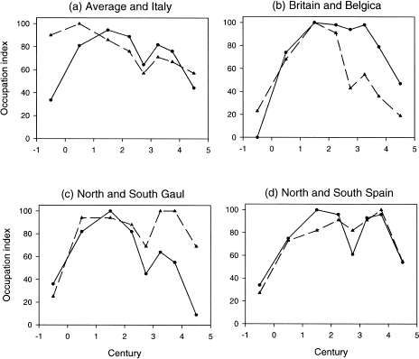

图 7.1 西罗马帝国乡村遗址的占领（Lewit 1991）。在每个面板中，第一个位置由实线指示，第二个位置由虚线指示。数据显示了两个世俗周期，即元首制和统治制。

Figure 7.1 Occupation of rural sites in the western Roman Empire (Lewit 1991). In each panel, the first location is indicated by a solid line, the second by a dashed line. The data indicate two secular cycles, those of the Principate and the Dominate.

三世纪下半叶的特点是所有七个地区的遗址都被废弃。然而，遗弃的程度各不相同，并且与内战或野蛮人入侵的严重程度相关（Lewit 1991）。这种对比在公元三世纪逃脱了野蛮人入侵的英国和被法兰克人彻底蹂躏的比利时高卢之间最为鲜明（见图7.1b ）。

The second half of the third century was characterized by site abandonment in all seven regions. However, the degree of abandonment varied and was correlated with the severity of civil war or barbarian invasions (Lewit 1991). The contrast is most vivid between Britain, which escaped barbarian invasions in the third century, and Gallia Belgica, which was completely overrun by the Franks (see figure 7.1b).

对区域曲线进行平均，我们发现拉丁西部地区的总体居住指数（假设北非也紧随其后）在公元一世纪期间大幅增长，随后在二世纪增长更为温和（图 7.1a，实线）。职业指数在二世纪达到顶峰后，在三世纪上半叶开始下降，并在下半叶达到最低点。在第四世纪（在下一个统治周期期间）出现了复苏，随后在第五世纪最终崩溃，当时西罗马帝国被日耳曼入侵者蹂躏。区域调查支持了这一观点。因此，阿尔贝尼亚山谷（伊特鲁里亚）调查发现了二十三个农场、别墅和村庄在第一世纪。这个数字在第二世纪下降到十四个，到第三世纪下降到八个。然后在四世纪增加到十一个，并在五世纪再次下降到六（来自 Cambi 和 Fentress 的数据，引自 Bintliff 和 Sbonias 1999:5）。这与勒维特为意大利发现的模式相同。因此，意大利农村人口的峰值很可能是在一世纪相当早的时候达到的，而帝国其他地区的人口直到二世纪中叶仍在持续增长。